# **Evolution of fecundity, survival, and body size in response to changing temperatures**

## **Changes in trait variance (lnVR)**

### **Overall model**

#### *Model specification*

```r
# Model specification
formula <- bf(lnVR ~ trait_type -1 + # Separate effects by trait type
                (trait_type-1|ref) + # Correlation between traits among studies
                (1|species) + # Species-level random effect
                (1|gr(phylogeny, cov = phylo_matrix)) + # Phylogenetic relatedness
                (1|experiment_ID) + # Experiment-level random effect
                (1|obs) + # Observation-level random effect
                fcor(VCV_lnVR)) # Variance covariance matix of correlated sampling variances

# Define priors
prior = c(
  prior(constant(1), class = "sigma")
) # Because the residual variance-covariance structure is specified in fcor, there is no need to estimate sigma so it is left as a constant

# Fit model
lnVR_model_overall <- brm(formula,
                           family = gaussian(),
                           data = data,
                           data2 = list(phylo_matrix = phylo_matrix,
                                        VCV_lnVR = VCV_lnVR),
                           prior = prior,
                           control = list(adapt_delta = 0.99, max_treedepth = 15),
                           iter = 4000,
                           warmup = 2000,
                           chains = 4,
                           cores = 4,
                           seed = 123)

# Save model
saveRDS(lnVR_model_overall, file = "RData/lnVR_model_overall.rds")
```

#### *Model output*

```r
# Load model
lnVR_model_overall <- readRDS("RData/lnVR_model_overall.rds")

# Display model output
summary(lnVR_model_overall)
```

```
##  Family: gaussian
##   Links: mu = identity; sigma = identity
## Formula: lnVR ~ trait_type - 1 + (trait_type - 1 | ref) + (1 | species) + (1 | gr(phylogeny, cov = phylo_matrix)) + (1 | experiment_ID) + (1 | obs) + fcor(VCV_lnVR)
##    Data: data (Number of observations: 476)
##   Draws: 4 chains, each with iter = 4000; warmup = 2000; thin = 1;
##          total post-warmup draws = 8000
##
## Multilevel Hyperparameters:
## ~experiment_ID (Number of levels: 88)
##               Estimate Est.Error l-95% CI u-95% CI Rhat Bulk_ESS Tail_ESS
## sd(Intercept)     0.09      0.06     0.00     0.22 1.01      562     1457
##
## ~obs (Number of levels: 476)
##               Estimate Est.Error l-95% CI u-95% CI Rhat Bulk_ESS Tail_ESS
## sd(Intercept)     0.69      0.03     0.62     0.76 1.00     2391     4360
##
## ~phylogeny (Number of levels: 25)
##               Estimate Est.Error l-95% CI u-95% CI Rhat Bulk_ESS Tail_ESS
## sd(Intercept)     0.09      0.07     0.00     0.27 1.00     1900     2946
##
## ~ref (Number of levels: 44)
##                                              Estimate Est.Error l-95% CI
## sd(trait_typebody_size)                          0.07      0.06     0.00
## sd(trait_typefecundity)                          0.07      0.06     0.00
## sd(trait_typesurvival)                           0.22      0.13     0.01
## cor(trait_typebody_size,trait_typefecundity)     0.02      0.50    -0.87
## cor(trait_typebody_size,trait_typesurvival)     -0.02      0.50    -0.88
## cor(trait_typefecundity,trait_typesurvival)     -0.03      0.49    -0.87
##                                              u-95% CI Rhat Bulk_ESS Tail_ESS
## sd(trait_typebody_size)                          0.21 1.00     1753     3140
## sd(trait_typefecundity)                          0.22 1.00     1755     2773
## sd(trait_typesurvival)                           0.50 1.00      958     2144
## cor(trait_typebody_size,trait_typefecundity)     0.88 1.00     4376     5091
## cor(trait_typebody_size,trait_typesurvival)      0.88 1.00     2072     3778
## cor(trait_typefecundity,trait_typesurvival)      0.86 1.00     2450     4728
##
## ~species (Number of levels: 25)
##               Estimate Est.Error l-95% CI u-95% CI Rhat Bulk_ESS Tail_ESS
## sd(Intercept)     0.06      0.05     0.00     0.18 1.00     2486     3626
##
## Regression Coefficients:
##                     Estimate Est.Error l-95% CI u-95% CI Rhat Bulk_ESS Tail_ESS
## trait_typebody_size     0.03      0.10    -0.17     0.24 1.00     2172     2851
## trait_typefecundity    -0.06      0.10    -0.25     0.14 1.00     2427     3216
## trait_typesurvival      0.11      0.13    -0.14     0.37 1.00     2994     3681
##
## Further Distributional Parameters:
##       Estimate Est.Error l-95% CI u-95% CI Rhat Bulk_ESS Tail_ESS
## sigma     1.00      0.00     1.00     1.00   NA       NA       NA
##
## Draws were sampled using sampling(NUTS). For each parameter, Bulk_ESS
## and Tail_ESS are effective sample size measures, and Rhat is the potential
## scale reduction factor on split chains (at convergence, Rhat = 1).
```

```r
# Cleaned model output
as.data.frame(fixef(lnVR_model_overall, summary = TRUE)) %>%
  # Rename categorical variables for cleaner display
  rownames_to_column(var = "Parameter") %>%
  mutate(
    Parameter = gsub("trait_type([a-z_]+)", "\\1", Parameter)
  ) %>%
  # Round numbers to 3 decimal points
  mutate(across(c(Estimate, Q2.5, Q97.5), ~ round(., 3))) %>%
  select(Parameter, Estimate, `Lower CI` = Q2.5, `Upper CI` = Q97.5) %>%
  kable() %>%
  kable_styling(full_width = FALSE, position = "center", fixed_thead = TRUE) %>%
  column_spec(1, bold = TRUE, border_right = TRUE) %>%
  row_spec(0, background = "white", color = "black", bold = TRUE) %>%
  kable_styling(fixed_thead = TRUE)
```

| Parameter | Estimate | Lower CI | Upper CI |
| --- | --- | --- | --- |
| body_size | 0.030 | -0.169 | 0.243 |
| fecundity | -0.057 | -0.251 | 0.143 |
| survival | 0.110 | -0.137 | 0.366 |

#### *Heterogeneity analysis*

```r
# Extracting the posterior distribution from the model
posterior <- posterior_samples(lnVR_model_overall)

# Calculate measurement error variance
sigma2_v <- sum(1/diag(VCV_lnVR)) * (length(diag(VCV_lnVR))- 1)/(sum(1/diag(VCV_lnVR))^2 - sum((1/diag(VCV_lnVR))^2))

# Calculate the total variance (including the measurement error variance)
var_total <- posterior$sd_experiment_ID__Intercept +
             posterior$sd_obs__Intercept +
             posterior$sd_phylogeny__Intercept +
             posterior$sd_ref__trait_typebody_size +
             posterior$sd_ref__trait_typefecundity +
             posterior$sd_ref__trait_typesurvival +
             posterior$sd_species__Intercept +
             sigma2_v

# Calculate heterogeneity (I2)
I2 <- list(
    I2_total = (var_total - sigma2_v) / var_total, # Total heterogeneity
    I2_study = (posterior$sd_ref__trait_typebody_size + # Heterogeneity explained by study differences
                posterior$sd_ref__trait_typefecundity +
                posterior$sd_ref__trait_typesurvival) / var_total,
    I2_exp = posterior$sd_experiment_ID__Intercept / var_total, # Heterogeneity explained by experiment differences
    I2_sp = posterior$sd_species__Intercept / var_total, # Heterogeneity explained by species differences
    I2_phylo = posterior$sd_phylogeny__Intercept / var_total, # Heterogeneity explained by phylogenetic relatedness
    I2_obs = posterior$sd_obs__Intercept / var_total # Heterogeneity explained by residual variation

)

# Calculate mean and credible intervals
summary_table <- t(sapply(I2, function(x) {
    c(Mean = 100*round(mean(x),4),
      ` ` = 100* round(quantile(x, 0.025),4),
      ` ` = 100*round(quantile(x, 0.975),4))
}))

# Customise table
summary_table <- summary_table %>%
    as.data.frame() %>%
    rownames_to_column("Variable") %>%
    mutate(
        Variable = recode(Variable,
                          "I2_total"  = "Total",
                          "I2_study"  = "Study",
                          "I2_exp"    = "Experiment",
                          "I2_sp"     = "Species",
                          "I2_phylo"  = "Phylogeny",
                          "I2_obs"    = "Residual")
    ) %>%
    rename(
        lower_HPD = ` .2.5%`,
        upper_HPD = ` .97.5%`
    ) %>%
  mutate(
    Variable = paste0("I<sup>2</sup><sub>", Variable)   # Create a new column with formatted I² and subscripts
  )


# Display table
kable(summary_table, "html", escape = FALSE,
      col.names = c("Heterogeneity (%)", "Mean", "Lower HPD", "Upper HPD"),
      align = c('l', 'r', 'r', 'r')) %>%
  kable_styling(full_width = FALSE, position = "center", fixed_thead = TRUE) %>%
  column_spec(1, width = "200px", bold = TRUE, border_right = TRUE) %>%
  row_spec(0, background = "white", color = "black", bold = TRUE) %>%
  kable_styling(fixed_thead = TRUE)
```

| Heterogeneity (%) | Mean | Lower HPD | Upper HPD |
| --- | --- | --- | --- |
| I<sup>2</sup><sub>Total</sub> | 93.16 | 91.17 | 94.79 |
| I<sup>2</sup><sub>Study</sub> | 25.53 | 9.36 | 41.12 |
| I<sup>2</sup><sub>Experiment</sub> | 6.51 | 0.33 | 14.52 |
| I<sup>2</sup><sub>Species</sub> | 4.35 | 0.18 | 11.94 |
| I<sup>2</sup><sub>Phylogeny</sub> | 6.57 | 0.27 | 17.79 |
| I<sup>2</sup><sub>Residual</sub> | 50.19 | 37.83 | 64.94 |

#### *Data visualisation*

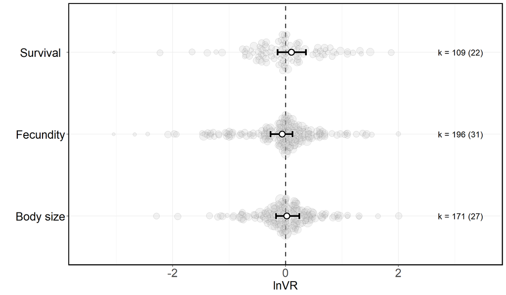

```r
# Generate predictions
emmeans_overall <- as.data.frame(emmeans(lnVR_model_overall, ~ trait_type))

emmeans_overall$trait_type <- factor(emmeans_overall$trait_type,
                          levels = c("body_size", "fecundity", "survival"),
                          labels = c("Body size", "Fecundity", "Survival"))
# Plot
ggplot() +
    geom_hline(yintercept = 0, # Horizontal line
               linetype = 2,
               colour = "black",
               alpha = 0.75,
               lwd=1) +
    geom_quasirandom(data = data, # Plot effect sizes, scaled by precision
                     aes(x = trait_type,
                         y = lnVR,
                         size = 1/sqrt(var_lnVR)),
                     fill = "gray75",
                     shape = 21,
                     width = 0.25,
                     alpha = 0.2) +
    geom_errorbar(data = emmeans_overall,   # Plot the point estimates in white for background
                  aes(ymin = lower.HPD,
                      ymax = upper.HPD,
                      x = trait_type),
                  size = 2,
                  width = 0.085,
                  color = "white") +
    geom_point(data = emmeans_overall, # Plot the credible intervals in white for background
               aes(x = trait_type,
                   y = emmean),
               size = 4.5,
               stroke = 1.5,
               shape = 21,
               color="white",
               fill = "white") +
    geom_errorbar(data = emmeans_overall,  # Plot the point estimates
                  aes(x = trait_type,
                      ymin = lower.HPD,
                      ymax = upper.HPD),
                  size = 1.5,
                  width = 0.075,
                  color = "black") +
    geom_point(data = emmeans_overall, # Plot the credible intervals
               aes(x = trait_type,
                   y = emmean),
               size = 4,
               shape = 21,
               stroke = 1.5,
               color="black",
               fill = "white") +
    geom_text(data = sample_sizes_traits,  # Sample size annotations
              aes(x = trait_type,
                  y = 3.5,
                  label = paste0("k = ", estimates, " (", studies, ")")),
              hjust = 1, size = 5, show.legend = FALSE) +
    theme_bw() +     # Customize the plot
    labs(y = "lnVR", x = "") +
    scale_size_continuous(range = c(2, 8))+
    theme(text = element_text(size = 20, color = "black"),
          legend.title = ggplot2::element_text(size = 16),
          legend.text = ggplot2::element_text(size = 14),
          axis.text.y = ggplot2::element_text(size = 20,
                colour = "black", hjust = 0.5),
          axis.text.x = ggplot2::element_text(size = 20),
          panel.border = element_rect(color = "black", size = 1.5)) +
    guides(color = "none", size = "none")+
    coord_flip() +
    ylim(-3.5, 3.5)
```

```r
# Save figure
ggsave(file = "fig/lnVR_overall.png", width = 12, height = 7, dpi = 500)
```

### **Temperature regime**

#### *Model specification*

```r
# Model specification
formula <- bf(lnVR ~ trait_type:warm_cold -1 + # Separate effects by trait type
                (trait_type-1|ref) + # Correlation between traits among studies
                (1|species) + # Species-level random effect
                (1|gr(phylogeny, cov = phylo_matrix)) + # Phylogenetic relatedness
                (1|experiment_ID) + # Experiment-level random effect
                (1|obs) + # Observation-level random effect
                fcor(VCV_lnVR)) # Variance covariance matix of correlated sampling variances

# Define priors
prior = c(
  prior(constant(1), class = "sigma")
) # Because the residual variance-covariance structure is specified in fcor, there is no need to estimate sigma so it is left as a constant

# Fit model
lnVR_model_warm_cold <- brm(formula,
                  family = gaussian(),
                  data = data,
                  data2 = list(phylo_matrix = phylo_matrix,
                               VCV_lnVR = VCV_lnVR),
                  prior = prior,
                  control = list(adapt_delta = 0.99, max_treedepth = 15),
                  iter = 4000,
                  warmup = 2000,
                  chains = 4,
                  cores = 4,
                  seed = 123)

# Save model
saveRDS(lnVR_model_warm_cold, file = "RData/lnVR_model_warm_cold.rds")
```

#### *Model output*

```r
# Load model
lnVR_model_warm_cold <- readRDS("RData/lnVR_model_warm_cold.rds")

# Display model output
summary(lnVR_model_warm_cold)
```

```
##  Family: gaussian
##   Links: mu = identity; sigma = identity
## Formula: lnVR ~ trait_type:warm_cold - 1 + (trait_type - 1 | ref) + (1 | species) + (1 | gr(phylogeny, cov = phylo_matrix)) + (1 | experiment_ID) + (1 | obs) + fcor(VCV_lnVR)
##    Data: data (Number of observations: 476)
##   Draws: 4 chains, each with iter = 4000; warmup = 2000; thin = 1;
##          total post-warmup draws = 8000
##
## Multilevel Hyperparameters:
## ~experiment_ID (Number of levels: 88)
##               Estimate Est.Error l-95% CI u-95% CI Rhat Bulk_ESS Tail_ESS
## sd(Intercept)     0.10      0.06     0.01     0.22 1.01      699     2066
##
## ~obs (Number of levels: 476)
##               Estimate Est.Error l-95% CI u-95% CI Rhat Bulk_ESS Tail_ESS
## sd(Intercept)     0.69      0.03     0.63     0.76 1.00     2392     4792
##
## ~phylogeny (Number of levels: 25)
##               Estimate Est.Error l-95% CI u-95% CI Rhat Bulk_ESS Tail_ESS
## sd(Intercept)     0.09      0.07     0.00     0.27 1.00     2421     3746
##
## ~ref (Number of levels: 44)
##                                              Estimate Est.Error l-95% CI
## sd(trait_typebody_size)                          0.07      0.06     0.00
## sd(trait_typefecundity)                          0.08      0.06     0.00
## sd(trait_typesurvival)                           0.23      0.14     0.01
## cor(trait_typebody_size,trait_typefecundity)     0.02      0.50    -0.87
## cor(trait_typebody_size,trait_typesurvival)     -0.03      0.49    -0.88
## cor(trait_typefecundity,trait_typesurvival)     -0.03      0.49    -0.87
##                                              u-95% CI Rhat Bulk_ESS Tail_ESS
## sd(trait_typebody_size)                          0.21 1.00     2325     4047
## sd(trait_typefecundity)                          0.22 1.00     2191     3451
## sd(trait_typesurvival)                           0.52 1.00     1452     2816
## cor(trait_typebody_size,trait_typefecundity)     0.88 1.00     4568     5550
## cor(trait_typebody_size,trait_typesurvival)      0.85 1.00     2186     4167
## cor(trait_typefecundity,trait_typesurvival)      0.86 1.00     2662     5481
##
## ~species (Number of levels: 25)
##               Estimate Est.Error l-95% CI u-95% CI Rhat Bulk_ESS Tail_ESS
## sd(Intercept)     0.06      0.05     0.00     0.17 1.00     2942     5016
##
```

[output cut: 8 more lines]

```
##                                   Bulk_ESS Tail_ESS
## trait_typebody_size:warm_coldcold     2592     3441
## trait_typefecundity:warm_coldcold     2897     4305
## trait_typesurvival:warm_coldcold      3848     4863
## trait_typebody_size:warm_coldwarm     2531     3095
## trait_typefecundity:warm_coldwarm     2686     3341
## trait_typesurvival:warm_coldwarm      3777     3791
##
## Further Distributional Parameters:
##       Estimate Est.Error l-95% CI u-95% CI Rhat Bulk_ESS Tail_ESS
## sigma     1.00      0.00     1.00     1.00   NA       NA       NA
##
## Draws were sampled using sampling(NUTS). For each parameter, Bulk_ESS
## and Tail_ESS are effective sample size measures, and Rhat is the potential
## scale reduction factor on split chains (at convergence, Rhat = 1).
```

```r
# R2
r2(lnVR_model_warm_cold)
```

```
## # Bayesian R2 with Compatibility Interval
##
##   Conditional R2: 0.596 (95% CI [0.542, 0.650])
##      Marginal R2: 0.016 (95% CI [0.001, 0.038])
```

```r
# Cleaned model output
as.data.frame(fixef(lnVR_model_warm_cold, summary = TRUE)) %>%
  # Rename categorical variables for cleaner display
  rownames_to_column(var = "Parameter") %>%
  mutate(
    # Simplify `trait_type` and `warm_cold` interactions
    Parameter = gsub("trait_type([a-z_]+):warm_cold(cold|warm)", "\\1(\\2)", Parameter)
  ) %>%
  # Round numbers to 3 decimal points
  mutate(across(c(Estimate, Q2.5, Q97.5), ~ round(., 3))) %>%
  select(Parameter, Estimate, `Lower CI` = Q2.5, `Upper CI` = Q97.5) %>%
  kable() %>%
  kable_styling(full_width = FALSE, position = "center", fixed_thead = TRUE) %>%
  column_spec(1, bold = TRUE, border_right = TRUE) %>%
  row_spec(0, background = "white", color = "black", bold = TRUE) %>%
  kable_styling(fixed_thead = TRUE)
```

| Parameter | Estimate | Lower CI | Upper CI |
| --- | --- | --- | --- |
| body_size(cold) | -0.010 | -0.280 | 0.264 |
| fecundity(cold) | -0.169 | -0.595 | 0.274 |
| survival(cold) | -0.006 | -0.485 | 0.458 |
| body_size(warm) | 0.034 | -0.173 | 0.255 |
| fecundity(warm) | -0.045 | -0.240 | 0.158 |
| survival(warm) | 0.132 | -0.133 | 0.407 |

#### *Contrasts*

```r
# Generate predictions
emms <- emmeans(lnVR_model_warm_cold,
                specs = ~ warm_cold | trait_type)

# Generate contrasts
contrast(emms, method = "pairwise")
```

```
## trait_type = body_size:
##  contrast    estimate lower.HPD upper.HPD
##  cold - warm  -0.0441    -0.296     0.214
##
## trait_type = fecundity:
##  contrast    estimate lower.HPD upper.HPD
##  cold - warm  -0.1252    -0.555     0.306
##
## trait_type = survival:
##  contrast    estimate lower.HPD upper.HPD
##  cold - warm  -0.1366    -0.621     0.347
##
## Point estimate displayed: median
## HPD interval probability: 0.95
```

#### *Data visualisation*

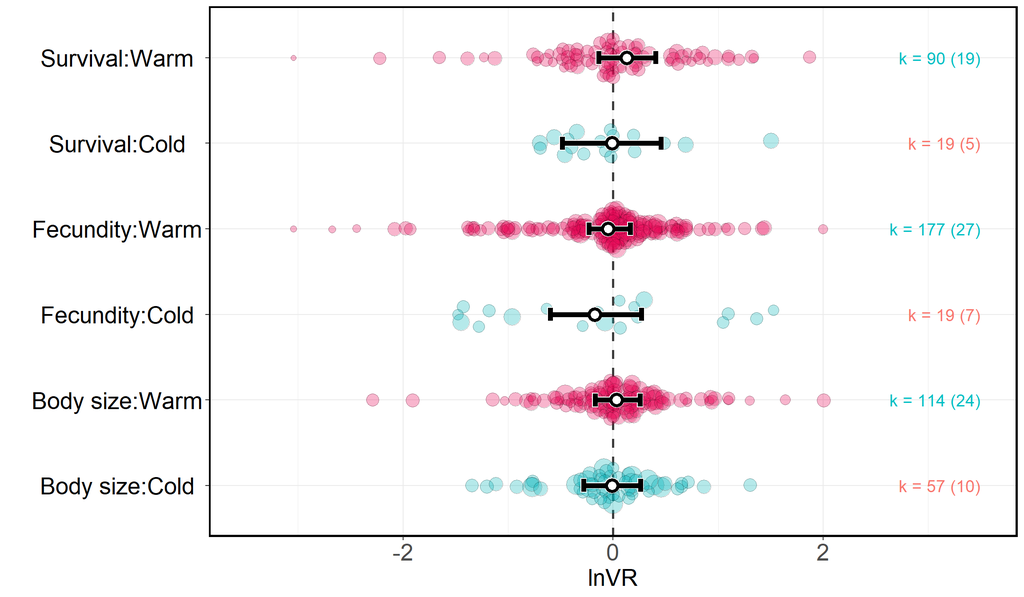

```r
# Generate predictions
emmeans_warm_cold <- as.data.frame(emmeans(lnVR_model_warm_cold,
                                           specs = ~ warm_cold | trait_type))

emmeans_warm_cold$trait_type <- factor(emmeans_warm_cold$trait_type,
                          levels = c("body_size", "fecundity", "survival"),
                          labels = c("Body size", "Fecundity", "Survival"))

emmeans_warm_cold$warm_cold <- factor(emmeans_warm_cold$warm_cold,
                          levels = c("cold", "warm"),
                          labels = c("Cold", "Warm"))
# Plot
ggplot() +
    geom_hline(yintercept = 0, # Horizontal line
               linetype = 2,
               colour = "black",
               alpha = 0.75,
               lwd=1) +
    geom_quasirandom(data = data,     # Plot effect sizes, scaled by precision
                     aes(x = trait_type:warm_cold,
                         y = lnVR,
                         fill = trait_type:warm_cold,
                         size = 1/sqrt(var_lnVR)),
                     color = "black",
                     shape = 21,
                     width = 0.25,
                     alpha = 0.3) +
    geom_errorbar(data = emmeans_warm_cold,  # Plot the point estimates in white for background
                  aes(x = trait_type:warm_cold,
                      ymin = lower.HPD,
                      ymax = upper.HPD),
                  color="white",
                  size = 2.5,
                  width = 0.17) +
    geom_point(data = emmeans_warm_cold,  # Plot the credible intervals in white for background
               aes(x = trait_type:warm_cold,
                   y = emmean),
               shape = 21,
               size = 4,
               stroke = 2,
               color="white",
               fill = "white") +
    geom_errorbar(data = emmeans_warm_cold, # Plot the point estimates
                  aes(x = trait_type:warm_cold,
                      ymin = lower.HPD,
                      ymax = upper.HPD),
                  color="black",
                  size = 2,
                  width = 0.15) +
    geom_point(data = emmeans_warm_cold, # Plot the credible intervals
               aes(x = trait_type:warm_cold,
                   y = emmean),
               shape = 21,
               size = 3.5,
               stroke = 2,
               color="black",
               fill = "white") +
    geom_text(data = sample_sizes,  # Sample size annotations
              aes(x = trait_type:warm_cold,
                  y = 3.5,
                  label = paste0("k = ", estimates, " (", studies, ")"),
                  color = warm_cold),
              hjust = 1, size = 5, show.legend = FALSE) +
    theme_bw() +     # Customize the plot
    labs(y = "lnVR", x = "") +
    scale_size_continuous(range = c(2, 8))+
#    scale_fill_manual(values = c("#A5F820", "#73B706",  "#9CEFFC", "#06A2BA",  "#FED2ED", "#B90674"))+
    scale_fill_manual(values = c("#06B4BA", "#E80756", "#06B4BA", "#E80756", "#06B4BA", "#E80756"))+
    theme(text = element_text(size = 20, color = "black"),
          legend.title = ggplot2::element_text(size = 16),
          legend.text = ggplot2::element_text(size = 14),
          axis.text.y = ggplot2::element_text(size = 20,
                colour = "black", hjust = 0.5),
          axis.text.x = ggplot2::element_text(size = 20),
          panel.border = element_rect(color = "black", size = 1.5)) +
    guides(fill = "none", size = "none")+
    coord_flip() +
    ylim(-3.5, 3.5)
```

```r
ggsave(file = "fig/lnVR_warm_cold.png", width = 12, height = 7, dpi = 500)
```

### **Assay temperature difference**

We calculated the difference between the assay temperature and control temperature (assay_temp_diff) to account for the fact that animals were tested to a different range of temperatures. We also predicted that effects will vary if traits are assayed at colder- or warmer-than-control conditions, depending on the temperature regime. Because the variation in assay temperature generates some nuisance heterogeneity (sensu Noble et al., 2017), the results of subsequent models were provided after controlling for assay temperature differences. In order words, the results of all moderators are conditional on assay temperature, meaning that results are interpretable as the difference between control and selected lines, when animals are tested at the control temperature.

#### *Model specification*

```r
# Model specification
formula <- bf(lnVR ~ 0 + trait_type:warm_cold + trait_type:warm_cold:assay_temp_diff + # Separate effects by trait type
                (trait_type-1|ref) + # Correlation between traits among studies
                (1|species) + # Species-level random effect
                (1|gr(phylogeny, cov = phylo_matrix)) + # Phylogenetic relatedness
                (1|experiment_ID) + # Experiment-level random effect
                (1|obs) + # Observation-level random effect
                fcor(VCV_lnVR)) # Variance covariance matix of correlated sampling variances

# Define priors
prior = c(
  prior(constant(1), class = "sigma")
) # Because the residual variance-covariance structure is specified in fcor, there is no need to estimate sigma so it is left as a constant

# Fit model
lnVR_model_assay_temp_diff <- brm(formula,
                                  family = gaussian(),
                                  data = data,
                                  data2 = list(phylo_matrix = phylo_matrix,
                                               VCV_lnVR = VCV_lnVR),
                                  prior = prior,
                                  control = list(adapt_delta = 0.99, max_treedepth = 15),
                                  iter = 4000,
                                  warmup = 2000,
                                  chains = 4,
                                  cores = 4,
                                  seed = 123)

# Save model
saveRDS(lnVR_model_assay_temp_diff, file = "RData/lnVR_model_assay_temp_diff.rds")
```

#### *Model output*

```r
# Load model
lnVR_model_assay_temp_diff <- readRDS("RData/lnVR_model_assay_temp_diff.rds")

# Display model output
summary(lnVR_model_assay_temp_diff)
```

```
##  Family: gaussian
##   Links: mu = identity; sigma = identity
## Formula: lnVR ~ 0 + trait_type:warm_cold + trait_type:warm_cold:assay_temp_diff + (trait_type - 1 | ref) + (1 | species) + (1 | gr(phylogeny, cov = phylo_matrix)) + (1 | experiment_ID) + (1 | obs) + fcor(VCV_lnVR)
##    Data: data (Number of observations: 476)
##   Draws: 4 chains, each with iter = 4000; warmup = 2000; thin = 1;
##          total post-warmup draws = 8000
##
## Multilevel Hyperparameters:
## ~experiment_ID (Number of levels: 88)
##               Estimate Est.Error l-95% CI u-95% CI Rhat Bulk_ESS Tail_ESS
## sd(Intercept)     0.09      0.06     0.01     0.21 1.01      634     1653
##
## ~obs (Number of levels: 476)
##               Estimate Est.Error l-95% CI u-95% CI Rhat Bulk_ESS Tail_ESS
## sd(Intercept)     0.68      0.03     0.61     0.75 1.00     2347     4647
##
## ~phylogeny (Number of levels: 25)
##               Estimate Est.Error l-95% CI u-95% CI Rhat Bulk_ESS Tail_ESS
## sd(Intercept)     0.09      0.07     0.00     0.27 1.00     1686     3045
##
## ~ref (Number of levels: 44)
##                                              Estimate Est.Error l-95% CI
## sd(trait_typebody_size)                          0.07      0.06     0.00
## sd(trait_typefecundity)                          0.08      0.06     0.00
## sd(trait_typesurvival)                           0.26      0.14     0.02
## cor(trait_typebody_size,trait_typefecundity)     0.02      0.50    -0.87
## cor(trait_typebody_size,trait_typesurvival)     -0.04      0.51    -0.90
## cor(trait_typefecundity,trait_typesurvival)     -0.02      0.50    -0.88
##                                              u-95% CI Rhat Bulk_ESS Tail_ESS
## sd(trait_typebody_size)                          0.21 1.00     1928     3376
## sd(trait_typefecundity)                          0.23 1.00     1683     2508
## sd(trait_typesurvival)                           0.55 1.00     1160     1944
## cor(trait_typebody_size,trait_typefecundity)     0.88 1.00     3664     4922
## cor(trait_typebody_size,trait_typesurvival)      0.88 1.00     1431     2740
## cor(trait_typefecundity,trait_typesurvival)      0.86 1.00     1714     3633
##
## ~species (Number of levels: 25)
##               Estimate Est.Error l-95% CI u-95% CI Rhat Bulk_ESS Tail_ESS
## sd(Intercept)     0.06      0.05     0.00     0.18 1.00     2446     2781
##
```

[output cut: 33 more lines]

```
## trait_typesurvival:warm_coldwarm                      3518
## trait_typebody_size:warm_coldcold:assay_temp_diff     2883
## trait_typefecundity:warm_coldcold:assay_temp_diff     4514
## trait_typesurvival:warm_coldcold:assay_temp_diff      4385
## trait_typebody_size:warm_coldwarm:assay_temp_diff     3656
## trait_typefecundity:warm_coldwarm:assay_temp_diff     4007
## trait_typesurvival:warm_coldwarm:assay_temp_diff      4607
##
## Further Distributional Parameters:
##       Estimate Est.Error l-95% CI u-95% CI Rhat Bulk_ESS Tail_ESS
## sigma     1.00      0.00     1.00     1.00   NA       NA       NA
##
## Draws were sampled using sampling(NUTS). For each parameter, Bulk_ESS
## and Tail_ESS are effective sample size measures, and Rhat is the potential
## scale reduction factor on split chains (at convergence, Rhat = 1).
```

```r
# R2
r2(lnVR_model_assay_temp_diff)
```

```
## # Bayesian R2 with Compatibility Interval
##
##   Conditional R2: 0.607 (95% CI [0.552, 0.657])
##      Marginal R2: 0.061 (95% CI [0.027, 0.100])
```

```r
# Cleaned model output
as.data.frame(fixef(lnVR_model_assay_temp_diff, summary = TRUE)) %>%
  # Rename categorical variables for cleaner display
  rownames_to_column(var = "Parameter") %>%
  mutate(
    Parameter = gsub("trait_type([a-z_]+):warm_cold(cold|warm)", "\\1(\\2)", Parameter),
    Parameter = gsub("trait_type([a-z_]+)\\(warm\\):assay_temp_diff", "\\1(warm): assay_temp_diff", Parameter)
  ) %>%
  # Round numbers to 3 decimal points
  mutate(across(c(Estimate, Q2.5, Q97.5), ~ round(., 3))) %>%
  select(Parameter, Estimate, `Lower CI` = Q2.5, `Upper CI` = Q97.5) %>%
  kable() %>%
  kable_styling(full_width = FALSE, position = "center", fixed_thead = TRUE) %>%
  column_spec(1, bold = TRUE, border_right = TRUE) %>%
  row_spec(0, background = "white", color = "black", bold = TRUE) %>%
  kable_styling(fixed_thead = TRUE)
```

| Parameter | Estimate | Lower CI | Upper CI |
| --- | --- | --- | --- |
| body_size(cold) | -0.020 | -0.298 | 0.274 |
| fecundity(cold) | -0.401 | -0.854 | 0.062 |
| survival(cold) | -0.022 | -0.567 | 0.525 |
| body_size(warm) | 0.037 | -0.202 | 0.282 |
| fecundity(warm) | -0.110 | -0.332 | 0.106 |
| survival(warm) | 0.196 | -0.108 | 0.517 |
| body_size(cold):assay_temp_diff | -0.016 | -0.072 | 0.042 |
| fecundity(cold):assay_temp_diff | -0.176 | -0.266 | -0.085 |
| survival(cold):assay_temp_diff | -0.013 | -0.097 | 0.073 |
| body_size(warm):assay_temp_diff | -0.001 | -0.040 | 0.039 |
| fecundity(warm):assay_temp_diff | 0.020 | -0.010 | 0.050 |
| survival(warm):assay_temp_diff | -0.021 | -0.068 | 0.026 |

#### *Data visualisation*

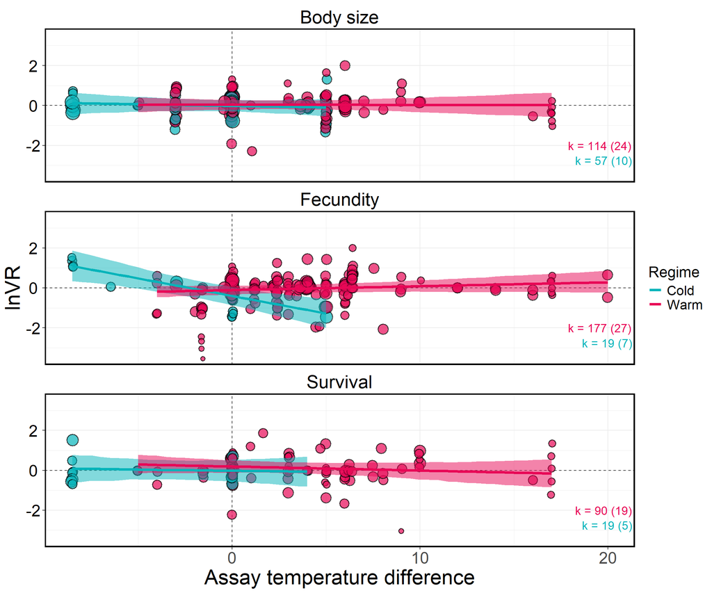

```r
# Generate predictions
emmeans_assay_temp_diff <- as.data.frame(emmeans(
  lnVR_model_assay_temp_diff,
  specs = ~ assay_temp_diff | trait_type * warm_cold,
  at = list(assay_temp_diff = seq(min(data$assay_temp_diff), max(data$assay_temp_diff), by = 0.5)))
  )

# Calculate range of values for each category
range_df <- data %>%
  group_by(trait_type, warm_cold) %>%
  summarize(
    min_assay_temp_diff = min(assay_temp_diff),
    max_assay_temp_diff = max(assay_temp_diff)
  )

emmeans_assay_temp_diff$trait_type <- factor(emmeans_assay_temp_diff$trait_type,
                          levels = c("body_size", "fecundity", "survival"),
                          labels = c("Body size", "Fecundity", "Survival"))

emmeans_assay_temp_diff$warm_cold <- factor(emmeans_assay_temp_diff$warm_cold,
                          levels = c("cold", "warm"),
                          labels = c("Cold", "Warm"))

# Tailor predictions to the range of the data
emmeans_assay_temp_diff <- emmeans_assay_temp_diff %>%
  left_join(range_df, by = c("trait_type", "warm_cold")) %>%
  filter(
    assay_temp_diff >= min_assay_temp_diff,
    assay_temp_diff <= max_assay_temp_diff
  )

# Plot
ggplot() +
    geom_hline(yintercept = 0, # Horizontal line
               linetype = 2,
               colour = "black",
               alpha = 0.75) +
    geom_vline(xintercept = 0, # Vertical line
               linetype = 2,
               colour = "black",
               alpha = 0.75) +
    geom_point(data = data, # Effect sizes, scaled by precision
                  aes(x = assay_temp_diff,
                      y = lnVR,
                      size = 1/sqrt(var_lnVR),
                      fill = warm_cold),
                  shape = 21,
                  alpha = 0.7,
                  stroke = 1,
                  position = position_jitter(width = 0.05)) +
     geom_ribbon(data = emmeans_assay_temp_diff, # Shaded area for credible intervals
                 aes(x = assay_temp_diff,
                     ymin = lower.HPD,
                     ymax = upper.HPD,
                     fill = warm_cold,
                     group = warm_cold),
                 alpha = .5) +
     geom_line(data = emmeans_assay_temp_diff,  # Predicted regression line
               aes(y = emmean,
                   x = assay_temp_diff,
                   color = warm_cold,
                   group = warm_cold),
               size = 1.5) +
    geom_text(data = sample_sizes,
              aes(x = Inf,
                  y = ifelse(warm_cold == "Warm", -2, -2.75),  # Sample sizes
                  label = paste0("k = ", estimates, " (", studies, ")"),
                  color = warm_cold),
              hjust = 1.05, size = 5, show.legend = FALSE) +

  facet_wrap(~ trait_type, ncol = 1) + # Different panels for each trait
  scale_fill_manual(values = c("#06B4BA", "#E80756"))+
  scale_color_manual(values = c("#06B4BA", "#E80756"))+
  labs(x = "Assay temperature difference", y = "lnVR",
       col = "Regime") +
  theme_bw() +
  scale_size_continuous(range = c(2, 8))+
  theme(text = element_text(size = 25, color = "black"),
          legend.title = ggplot2::element_text(size = 18),
          legend.text = ggplot2::element_text(size = 16),
          axis.text.y = ggplot2::element_text(size = 20,
                colour = "black", hjust = 0.5),
          axis.text.x = ggplot2::element_text(size = 20),
        panel.border = element_rect(color = "black", size = 1.5),
        strip.background = element_blank(),
        strip.text = element_text(color = "black", size = 22)) +
    guides(fill = "none", size = "none")+
    coord_cartesian(ylim = c(-3.5, 3.5))
```

```r
ggsave(file = "fig/lnVR_assay_temp_diff.png", width = 12, height = 10, dpi = 500)
```

### **Selection temperature**

#### *Model specification*

```r
# Model specification
formula <- bf(lnVR ~ 0 + trait_type:warm_cold +
                          trait_type:warm_cold:assay_temp_diff +
                          trait_type:warm_cold:select_temp_diff + # Separate effects by trait type
                (trait_type-1|ref) + # Correlation between traits among studies
                (1|species) + # Species-level random effect
                (1|gr(phylogeny, cov = phylo_matrix)) + # Phylogenetic relatedness
                (1|experiment_ID) + # Experiment-level random effect
                (1|obs) + # Observation-level random effect
                fcor(VCV_lnVR)) # Variance covariance matix of correlated sampling variances

# Define priors
prior = c(
  prior(constant(1), class = "sigma")
) # Because the residual variance-covariance structure is specified in fcor, there is no need to estimate sigma so it is left as a constant

# Fit model
lnVR_model_sel_temp_diff <- brm(formula,
                                family = gaussian(),
                                data = data,
                                data2 = list(phylo_matrix = phylo_matrix,
                                             VCV_lnVR = VCV_lnVR),
                                prior = prior,
                                control = list(adapt_delta = 0.99, max_treedepth = 15),
                                iter = 4000,
                                warmup = 2000,
                                chains = 4,
                                cores = 4,
                                seed = 123)

# Save model
saveRDS(lnVR_model_sel_temp_diff, file = "RData/lnVR_model_sel_temp_diff.rds")
```

#### *Model output*

```r
# Load model
lnVR_model_sel_temp_diff <- readRDS("RData/lnVR_model_sel_temp_diff.rds")

# Display model output
summary(lnVR_model_sel_temp_diff)
```

```
##  Family: gaussian
##   Links: mu = identity; sigma = identity
## Formula: lnVR ~ 0 + trait_type:warm_cold + trait_type:warm_cold:assay_temp_diff + trait_type:warm_cold:select_temp_diff + (trait_type - 1 | ref) + (1 | species) + (1 | gr(phylogeny, cov = phylo_matrix)) + (1 | experiment_ID) + (1 | obs) + fcor(VCV_lnVR)
##    Data: data (Number of observations: 476)
##   Draws: 4 chains, each with iter = 4000; warmup = 2000; thin = 1;
##          total post-warmup draws = 8000
##
## Multilevel Hyperparameters:
## ~experiment_ID (Number of levels: 88)
##               Estimate Est.Error l-95% CI u-95% CI Rhat Bulk_ESS Tail_ESS
## sd(Intercept)     0.09      0.06     0.00     0.21 1.00      711     1715
##
## ~obs (Number of levels: 476)
##               Estimate Est.Error l-95% CI u-95% CI Rhat Bulk_ESS Tail_ESS
## sd(Intercept)     0.68      0.03     0.61     0.74 1.00     2566     4622
##
## ~phylogeny (Number of levels: 25)
##               Estimate Est.Error l-95% CI u-95% CI Rhat Bulk_ESS Tail_ESS
## sd(Intercept)     0.10      0.08     0.00     0.28 1.00     1850     2895
##
## ~ref (Number of levels: 44)
##                                              Estimate Est.Error l-95% CI
## sd(trait_typebody_size)                          0.07      0.06     0.00
## sd(trait_typefecundity)                          0.08      0.06     0.00
## sd(trait_typesurvival)                           0.28      0.15     0.02
## cor(trait_typebody_size,trait_typefecundity)     0.00      0.50    -0.87
## cor(trait_typebody_size,trait_typesurvival)     -0.02      0.49    -0.89
## cor(trait_typefecundity,trait_typesurvival)      0.01      0.49    -0.87
##                                              u-95% CI Rhat Bulk_ESS Tail_ESS
## sd(trait_typebody_size)                          0.22 1.00     2447     4032
## sd(trait_typefecundity)                          0.23 1.00     2095     3177
## sd(trait_typesurvival)                           0.59 1.00     1183     2257
## cor(trait_typebody_size,trait_typefecundity)     0.88 1.00     3758     4692
## cor(trait_typebody_size,trait_typesurvival)      0.87 1.00     1905     3396
## cor(trait_typefecundity,trait_typesurvival)      0.87 1.00     2001     4219
##
## ~species (Number of levels: 25)
##               Estimate Est.Error l-95% CI u-95% CI Rhat Bulk_ESS Tail_ESS
## sd(Intercept)     0.06      0.05     0.00     0.18 1.00     2344     3544
##
```

[output cut: 51 more lines]

```
## trait_typesurvival:warm_coldwarm:assay_temp_diff       3933
## trait_typebody_size:warm_coldcold:select_temp_diff     2820
## trait_typefecundity:warm_coldcold:select_temp_diff     4803
## trait_typesurvival:warm_coldcold:select_temp_diff      4376
## trait_typebody_size:warm_coldwarm:select_temp_diff     3430
## trait_typefecundity:warm_coldwarm:select_temp_diff     3647
## trait_typesurvival:warm_coldwarm:select_temp_diff      3998
##
## Further Distributional Parameters:
##       Estimate Est.Error l-95% CI u-95% CI Rhat Bulk_ESS Tail_ESS
## sigma     1.00      0.00     1.00     1.00   NA       NA       NA
##
## Draws were sampled using sampling(NUTS). For each parameter, Bulk_ESS
## and Tail_ESS are effective sample size measures, and Rhat is the potential
## scale reduction factor on split chains (at convergence, Rhat = 1).
```

```r
# R2
r2(lnVR_model_sel_temp_diff)
```

```
## # Bayesian R2 with Compatibility Interval
##
##   Conditional R2: 0.609 (95% CI [0.556, 0.661])
##      Marginal R2: 0.085 (95% CI [0.045, 0.129])
```

```r
# Cleaned model output
as.data.frame(fixef(lnVR_model_sel_temp_diff, summary = TRUE)) %>%
  # Rename categorical variables for cleaner display
  rownames_to_column(var = "Parameter") %>%
  mutate(
    Parameter = gsub("trait_type([a-z_]+):warm_cold(cold|warm)", "\\1(\\2)", Parameter),
    Parameter = gsub("trait_type([a-z_]+)\\(warm\\):select_temp_diff", "\\1(warm): select_temp_diff", Parameter)
  ) %>%
  # Round numbers to 3 decimal points
  mutate(across(c(Estimate, Q2.5, Q97.5), ~ round(., 3))) %>%
  select(Parameter, Estimate, `Lower CI` = Q2.5, `Upper CI` = Q97.5) %>%
  kable() %>%
  kable_styling(full_width = FALSE, position = "center", fixed_thead = TRUE) %>%
  column_spec(1, bold = TRUE, border_right = TRUE) %>%
  row_spec(0, background = "white", color = "black", bold = TRUE) %>%
  kable_styling(fixed_thead = TRUE)
```

| Parameter | Estimate | Lower CI | Upper CI |
| --- | --- | --- | --- |
| body_size(cold) | -0.229 | -0.855 | 0.415 |
| fecundity(cold) | -0.137 | -1.404 | 1.133 |
| survival(cold) | 0.365 | -2.362 | 3.059 |
| body_size(warm) | 0.285 | -0.070 | 0.658 |
| fecundity(warm) | 0.076 | -0.233 | 0.406 |
| survival(warm) | 0.158 | -0.327 | 0.680 |
| body_size(cold):assay_temp_diff | -0.007 | -0.068 | 0.052 |
| fecundity(cold):assay_temp_diff | -0.185 | -0.285 | -0.087 |
| survival(cold):assay_temp_diff | -0.018 | -0.106 | 0.071 |
| body_size(warm):assay_temp_diff | 0.017 | -0.027 | 0.059 |
| fecundity(warm):assay_temp_diff | 0.032 | -0.003 | 0.066 |
| survival(warm):assay_temp_diff | -0.025 | -0.077 | 0.026 |
| body_size(cold):select_temp_diff | 0.035 | -0.062 | 0.130 |
| fecundity(cold):select_temp_diff | -0.040 | -0.216 | 0.137 |
| survival(cold):select_temp_diff | -0.052 | -0.403 | 0.294 |
| body_size(warm):select_temp_diff | -0.055 | -0.115 | 0.005 |
| fecundity(warm):select_temp_diff | -0.051 | -0.114 | 0.011 |
| survival(warm):select_temp_diff | 0.008 | -0.070 | 0.080 |

#### *Data visualisation*

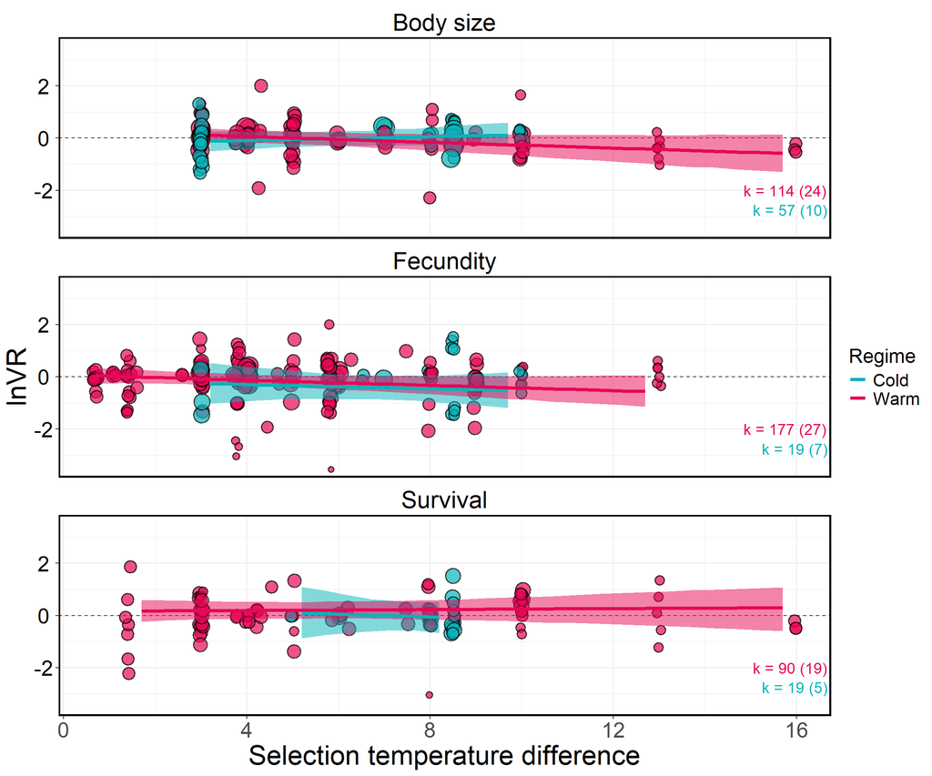

```r
# Generate predictions
emmeans_sel_temp_diff <- as.data.frame(emmeans(
  lnVR_model_sel_temp_diff,
  specs = ~ select_temp_diff | trait_type * warm_cold,
  at = list(select_temp_diff = seq(min(data$select_temp_diff), max(data$select_temp_diff), by = 0.5),
            assay_temp_diff = 0))
  ) # Conditional effects on assay_temp_diff = 0

# Calculate range of values for each category
range_df <- data %>%
  group_by(trait_type, warm_cold) %>%
  summarize(
    min_select_temp_diff = min(select_temp_diff),
    max_select_temp_diff = max(select_temp_diff)
  )

emmeans_sel_temp_diff$trait_type <- factor(emmeans_sel_temp_diff$trait_type,
                          levels = c("body_size", "fecundity", "survival"),
                          labels = c("Body size", "Fecundity", "Survival"))

emmeans_sel_temp_diff$warm_cold <- factor(emmeans_sel_temp_diff$warm_cold,
                          levels = c("cold", "warm"),
                          labels = c("Cold", "Warm"))

# Tailor predictions to the range of the data
emmeans_sel_temp_diff <- emmeans_sel_temp_diff %>%
  left_join(range_df, by = c("trait_type", "warm_cold")) %>%
  filter(
    select_temp_diff >= min_select_temp_diff,
    select_temp_diff <= max_select_temp_diff
  )

# Plot
ggplot() +
    geom_hline(yintercept = 0, # Horizontal line
               linetype = 2,
               colour = "black",
               alpha = 0.75) +
    geom_point(data = data,  # Effect sizes, scaled by precision
                  aes(x = select_temp_diff,
                      y = lnVR,
                      size = 1/sqrt(var_lnVR),
                      fill = warm_cold),
                  shape = 21,
                  alpha = 0.7,
                  stroke = 1,
                  position = position_jitter(width = 0.05)) +
     geom_ribbon(data = emmeans_sel_temp_diff, # Shaded area for credible intervals
                 aes(x = select_temp_diff,
                     ymin = lower.HPD,
                     ymax = upper.HPD,
                     fill = warm_cold,
                     group = warm_cold),
                 alpha = .5) +
     geom_line(data = emmeans_sel_temp_diff, # Predicted regression line
               aes(y = emmean,
                   x = select_temp_diff,
                   color = warm_cold,
                   group = warm_cold),
               size = 1.5) +
     geom_text(data = sample_sizes,
              aes(x = Inf,
                  y = ifelse(warm_cold == "Warm", -2, -2.75),  # Sample sizes
                  label = paste0("k = ", estimates, " (", studies, ")"),
                  color = warm_cold),
              hjust = 1.05, size = 5, show.legend = FALSE) +
  facet_wrap(~ trait_type, ncol = 1) +  # Different panels for each trait
  scale_fill_manual(values = c("#06B4BA", "#E80756"))+
  scale_color_manual(values = c("#06B4BA", "#E80756"))+
  labs(x = "Selection temperature difference", y = "lnVR", col = "Regime") +
  theme_bw() +
  scale_size_continuous(range = c(2, 8))+
  theme(text = element_text(size = 25, color = "black"),
          legend.title = ggplot2::element_text(size = 18),
          legend.text = ggplot2::element_text(size = 16),
          axis.text.y = ggplot2::element_text(size = 20,
                colour = "black", hjust = 0.5),
          axis.text.x = ggplot2::element_text(size = 20),
        panel.border = element_rect(color = "black", size = 1.5),
        strip.background = element_blank(),
        strip.text = element_text(color = "black", size = 22)) +
    guides(fill = "none", size = "none")+
    coord_cartesian(ylim = c(-3.5, 3.5))
```

```r
ggsave(file = "fig/lnVR_sel_temp_diff.png", width = 12, height = 7, dpi = 500)
```

### **Number of generations of selection**

#### *Model specification*

```r
# Model specification
formula <- bf(lnVR ~ 0 + trait_type:warm_cold +
                          trait_type:warm_cold:assay_temp_diff +
                          trait_type:warm_cold:scale(gen_selection) + # Separate effects by trait type
                (trait_type-1|ref) + # Correlation between traits among studies
                (1|species) + # Species-level random effect
                (1|gr(phylogeny, cov = phylo_matrix)) + # Phylogenetic relatedness
                (1|experiment_ID) + # Experiment-level random effect
                (1|obs) + # Observation-level random effect
                fcor(VCV_lnVR)) # Variance covariance matix of correlated sampling variances

# Define priors
prior = c(
  prior(constant(1), class = "sigma")
) # Because the residual variance-covariance structure is specified in fcor, there is no need to estimate sigma so it is left as a constant

# Fit model
lnVR_model_gen_selection <- brm(formula,
                                family = gaussian(),
                                data = data,
                                data2 = list(phylo_matrix = phylo_matrix,
                                             VCV_lnVR = VCV_lnVR),
                                prior = prior,
                                control = list(adapt_delta = 0.99, max_treedepth = 15),
                                iter = 4000,
                                warmup = 2000,
                                chains = 4,
                                cores = 4,
                                seed = 123)
# Save model
saveRDS(lnVR_model_gen_selection, file = "RData/lnVR_model_gen_selection.rds")
```

#### *Model output*

```r
# Load model
lnVR_model_gen_selection <- readRDS("RData/lnVR_model_gen_selection.rds")

# Display model output
summary(lnVR_model_gen_selection)
```

```
##  Family: gaussian
##   Links: mu = identity; sigma = identity
## Formula: lnVR ~ 0 + trait_type:warm_cold + trait_type:warm_cold:assay_temp_diff + trait_type:warm_cold:scale(gen_selection) + (trait_type - 1 | ref) + (1 | species) + (1 | gr(phylogeny, cov = phylo_matrix)) + (1 | experiment_ID) + (1 | obs) + fcor(VCV_lnVR)
##    Data: data (Number of observations: 476)
##   Draws: 4 chains, each with iter = 4000; warmup = 2000; thin = 1;
##          total post-warmup draws = 8000
##
## Multilevel Hyperparameters:
## ~experiment_ID (Number of levels: 88)
##               Estimate Est.Error l-95% CI u-95% CI Rhat Bulk_ESS Tail_ESS
## sd(Intercept)     0.09      0.06     0.00     0.21 1.01      903     2637
##
## ~obs (Number of levels: 476)
##               Estimate Est.Error l-95% CI u-95% CI Rhat Bulk_ESS Tail_ESS
## sd(Intercept)     0.68      0.03     0.61     0.75 1.00     3178     4871
##
## ~phylogeny (Number of levels: 25)
##               Estimate Est.Error l-95% CI u-95% CI Rhat Bulk_ESS Tail_ESS
## sd(Intercept)     0.09      0.07     0.00     0.27 1.00     3124     3917
##
## ~ref (Number of levels: 44)
##                                              Estimate Est.Error l-95% CI
## sd(trait_typebody_size)                          0.07      0.06     0.00
## sd(trait_typefecundity)                          0.08      0.06     0.00
## sd(trait_typesurvival)                           0.30      0.15     0.03
## cor(trait_typebody_size,trait_typefecundity)     0.01      0.50    -0.87
## cor(trait_typebody_size,trait_typesurvival)     -0.02      0.50    -0.88
## cor(trait_typefecundity,trait_typesurvival)     -0.04      0.49    -0.88
##                                              u-95% CI Rhat Bulk_ESS Tail_ESS
## sd(trait_typebody_size)                          0.22 1.00     2998     4012
## sd(trait_typefecundity)                          0.23 1.00     2675     4058
## sd(trait_typesurvival)                           0.61 1.00     1224     1341
## cor(trait_typebody_size,trait_typefecundity)     0.88 1.00     5312     5802
## cor(trait_typebody_size,trait_typesurvival)      0.88 1.00     2069     3948
## cor(trait_typefecundity,trait_typesurvival)      0.86 1.00     2585     4515
##
## ~species (Number of levels: 25)
##               Estimate Est.Error l-95% CI u-95% CI Rhat Bulk_ESS Tail_ESS
## sd(Intercept)     0.06      0.05     0.00     0.17 1.00     3260     4818
##
```

[output cut: 51 more lines]

```
## trait_typesurvival:warm_coldwarm:assay_temp_diff         5143     6729
## trait_typebody_size:warm_coldcold:scalegen_selection     3563     4687
## trait_typefecundity:warm_coldcold:scalegen_selection     5708     5582
## trait_typesurvival:warm_coldcold:scalegen_selection      4861     5581
## trait_typebody_size:warm_coldwarm:scalegen_selection     4280     5411
## trait_typefecundity:warm_coldwarm:scalegen_selection     3373     4641
## trait_typesurvival:warm_coldwarm:scalegen_selection      5155     5260
##
## Further Distributional Parameters:
##       Estimate Est.Error l-95% CI u-95% CI Rhat Bulk_ESS Tail_ESS
## sigma     1.00      0.00     1.00     1.00   NA       NA       NA
##
## Draws were sampled using sampling(NUTS). For each parameter, Bulk_ESS
## and Tail_ESS are effective sample size measures, and Rhat is the potential
## scale reduction factor on split chains (at convergence, Rhat = 1).
```

```r
# R2
r2(lnVR_model_gen_selection)
```

```
## # Bayesian R2 with Compatibility Interval
##
##   Conditional R2: 0.608 (95% CI [0.559, 0.661])
##      Marginal R2: 0.082 (95% CI [0.041, 0.124])
```

```r
# Cleaned model output
as.data.frame(fixef(lnVR_model_gen_selection, summary = TRUE)) %>%
  # Rename categorical variables for cleaner display
  rownames_to_column(var = "Parameter") %>%
  mutate(
    # Simplify `trait_type` and `warm_cold` interactions
    Parameter = gsub("trait_type([a-z_]+):warm_cold(cold|warm)", "\\1(\\2)", Parameter),
    # Adjust for assay_temp_diff
    Parameter = gsub("trait_type([a-z_]+)\\((cold|warm)\\):assay_temp_diff", "\\1(\\2): assay_temp_diff", Parameter),
    # Remove "scale" from gen_selection
    Parameter = gsub("scalegen_selection", "gen_selection", Parameter)
  ) %>%
  # Round numbers to 3 decimal points
  mutate(across(c(Estimate, Q2.5, Q97.5), ~ round(., 3))) %>%
  select(Parameter, Estimate, `Lower CI` = Q2.5, `Upper CI` = Q97.5) %>%
  kable() %>%
  kable_styling(full_width = FALSE, position = "center", fixed_thead = TRUE) %>%
  column_spec(1, bold = TRUE, border_right = TRUE) %>%
  row_spec(0, background = "white", color = "black", bold = TRUE) %>%
  kable_styling(fixed_thead = TRUE)
```

| Parameter | Estimate | Lower CI | Upper CI |
| --- | --- | --- | --- |
| body_size(cold) | -0.084 | -0.383 | 0.217 |
| fecundity(cold) | -0.307 | -0.856 | 0.238 |
| survival(cold) | 0.049 | -0.664 | 0.737 |
| body_size(warm) | 0.031 | -0.214 | 0.271 |
| fecundity(warm) | -0.182 | -0.413 | 0.051 |
| survival(warm) | 0.213 | -0.167 | 0.600 |
| body_size(cold):assay_temp_diff | -0.008 | -0.069 | 0.054 |
| fecundity(cold):assay_temp_diff | -0.188 | -0.283 | -0.089 |
| survival(cold):assay_temp_diff | -0.019 | -0.109 | 0.071 |
| body_size(warm):assay_temp_diff | -0.001 | -0.041 | 0.038 |
| fecundity(warm):assay_temp_diff | 0.026 | -0.006 | 0.058 |
| survival(warm):assay_temp_diff | -0.023 | -0.070 | 0.023 |
| body_size(cold):gen_selection | 0.088 | -0.119 | 0.303 |
| fecundity(cold):gen_selection | -0.127 | -0.427 | 0.186 |
| survival(cold):gen_selection | -0.088 | -0.474 | 0.301 |
| body_size(warm):gen_selection | -0.031 | -0.169 | 0.102 |
| fecundity(warm):gen_selection | -0.184 | -0.424 | 0.054 |
| survival(warm):gen_selection | 0.038 | -0.563 | 0.635 |

#### *Data visualisation*

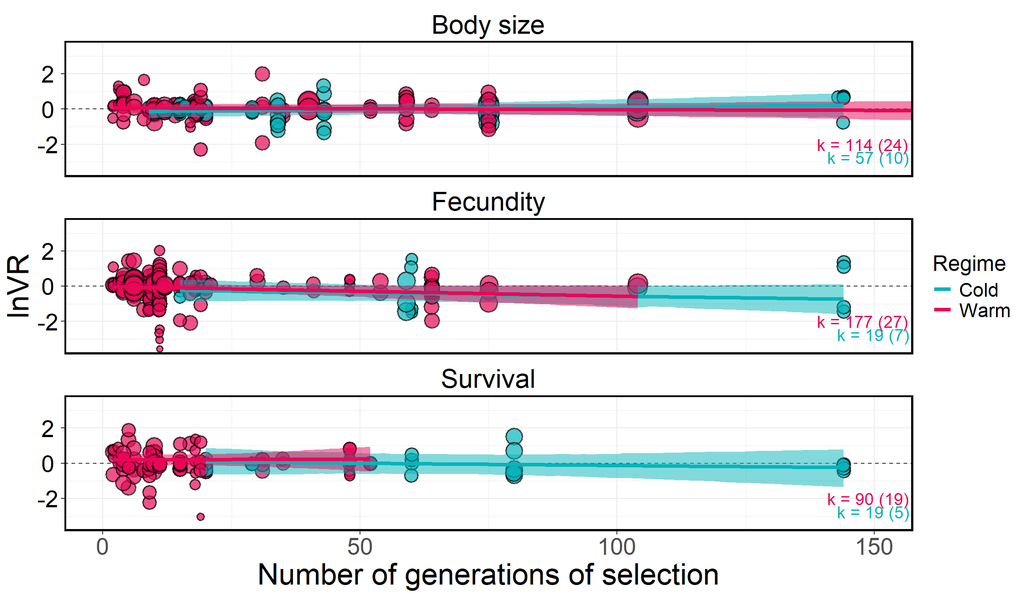

```r
# Generate predictions
emmeans_gen_selection <- as.data.frame(emmeans(
  lnVR_model_gen_selection,
  specs = ~ gen_selection | trait_type * warm_cold,
  at = list(gen_selection = seq(min(data$gen_selection), max(data$gen_selection), by = 1),
            assay_temp_diff = 0))
  ) # Conditional effects on assay_temp_diff = 0

# Calculate range of values for each category
range_df <- data %>%
  group_by(trait_type, warm_cold) %>%
  summarize(
    min_gen_selection = min(gen_selection),
    max_gen_selection = max(gen_selection)
  )

emmeans_gen_selection$trait_type <- factor(emmeans_gen_selection$trait_type,
                          levels = c("body_size", "fecundity", "survival"),
                          labels = c("Body size", "Fecundity", "Survival"))

emmeans_gen_selection$warm_cold <- factor(emmeans_gen_selection$warm_cold,
                          levels = c("cold", "warm"),
                          labels = c("Cold", "Warm"))

# Tailor predictions to the range of the data
emmeans_gen_selection <- emmeans_gen_selection %>%
  left_join(range_df, by = c("trait_type", "warm_cold")) %>%
  filter(
    gen_selection >= min_gen_selection,
    gen_selection <= max_gen_selection
  )

# Plot
ggplot() +
    geom_hline(yintercept = 0, # Horizontal line
               linetype = 2,
               colour = "black",
               alpha = 0.75) +
    geom_point(data = data,  # Effect sizes, scaled by precision
                  aes(x = gen_selection,
                      y = lnVR,
                      size = 1/sqrt(var_lnVR),
                      fill = warm_cold),
                  shape = 21,
                  alpha = 0.7,
                  stroke = 1,
                  position = position_jitter(width = 0.05)) +
     geom_ribbon(data = emmeans_gen_selection, # Shaded area for credible intervals
                 aes(x = gen_selection,
                     ymin = lower.HPD,
                     ymax = upper.HPD,
                     fill = warm_cold,
                     group = warm_cold),
                 alpha = .5) +
     geom_line(data = emmeans_gen_selection, # Predicted regression line
               aes(y = emmean,
                   x = gen_selection,
                   color = warm_cold,
                   group = warm_cold),
               size = 1.5) +
     geom_text(data = sample_sizes,
              aes(x = Inf,
                  y = ifelse(warm_cold == "Warm", -2, -2.75),  # Sample sizes
                  label = paste0("k = ", estimates, " (", studies, ")"),
                  color = warm_cold),
              hjust = 1.05, size = 5, show.legend = FALSE) +
  facet_wrap(~ trait_type, ncol = 1) +  # Different panels for each trait
  scale_fill_manual(values = c("#06B4BA", "#E80756"))+
  scale_color_manual(values = c("#06B4BA", "#E80756"))+
  labs(x = "Number of generations of selection", y = "lnVR", col = "Regime") +
  theme_bw() +
  scale_size_continuous(range = c(2, 8))+
  theme(text = element_text(size = 25, color = "black"),
          legend.title = ggplot2::element_text(size = 18),
          legend.text = ggplot2::element_text(size = 16),
          axis.text.y = ggplot2::element_text(size = 20,
                colour = "black", hjust = 0.5),
          axis.text.x = ggplot2::element_text(size = 20),
        panel.border = element_rect(color = "black", size = 1.5),
        strip.background = element_blank(),
        strip.text = element_text(color = "black", size = 22)) +
    guides(fill = "none", size = "none")+
    coord_cartesian(ylim = c(-3.5, 3.5),
                    xlim = c(0, 150))
```

```r
ggsave(file = "fig/lnVR_gen_selection.png", width = 12, height = 7, dpi = 500)
```

### **Number of generations of common garden**

#### *Model specification*

```r
# Model specification
formula <- bf(lnVR ~ 0 + trait_type:warm_cold +
                          trait_type:warm_cold:assay_temp_diff +
                          trait_type:warm_cold:scale(gen_common_garden) + # Separate effects by trait type
                (trait_type-1|ref) + # Correlation between traits among studies
                (1|species) + # Species-level random effect
                (1|gr(phylogeny, cov = phylo_matrix)) + # Phylogenetic relatedness
                (1|experiment_ID) + # Experiment-level random effect
                (1|obs) + # Observation-level random effect
                fcor(VCV_lnVR)) # Variance covariance matix of correlated sampling variances

# Define priors
prior = c(
  prior(constant(1), class = "sigma")
) # Because the residual variance-covariance structure is specified in fcor, there is no need to estimate sigma so it is left as a constant

# Fit model
lnVR_model_gen_common_garden <- brm(formula,
                                family = gaussian(),
                                data = data,
                                data2 = list(phylo_matrix = phylo_matrix,
                                             VCV_lnVR = VCV_lnVR),
                                prior = prior,
                                control = list(adapt_delta = 0.99, max_treedepth = 15),
                                iter = 4000,
                                warmup = 2000,
                                chains = 4,
                                cores = 4,
                                seed = 123)
# Save model
saveRDS(lnVR_model_gen_common_garden, file = "RData/lnVR_model_gen_common_garden.rds")
```

#### *Model output*

```r
# Load model
lnVR_model_gen_common_garden <- readRDS("RData/lnVR_model_gen_common_garden.rds")

# Display model output
summary(lnVR_model_gen_common_garden)
```

```
##  Family: gaussian
##   Links: mu = identity; sigma = identity
## Formula: lnVR ~ 0 + trait_type:warm_cold + trait_type:warm_cold:assay_temp_diff + trait_type:warm_cold:scale(gen_common_garden) + (trait_type - 1 | ref) + (1 | species) + (1 | gr(phylogeny, cov = phylo_matrix)) + (1 | experiment_ID) + (1 | obs) + fcor(VCV_lnVR)
##    Data: data (Number of observations: 476)
##   Draws: 4 chains, each with iter = 4000; warmup = 2000; thin = 1;
##          total post-warmup draws = 8000
##
## Multilevel Hyperparameters:
## ~experiment_ID (Number of levels: 88)
##               Estimate Est.Error l-95% CI u-95% CI Rhat Bulk_ESS Tail_ESS
## sd(Intercept)     0.09      0.06     0.00     0.22 1.00      734     2267
##
## ~obs (Number of levels: 476)
##               Estimate Est.Error l-95% CI u-95% CI Rhat Bulk_ESS Tail_ESS
## sd(Intercept)     0.68      0.03     0.62     0.75 1.00     2503     3863
##
## ~phylogeny (Number of levels: 25)
##               Estimate Est.Error l-95% CI u-95% CI Rhat Bulk_ESS Tail_ESS
## sd(Intercept)     0.10      0.08     0.00     0.30 1.00     1922     2831
##
## ~ref (Number of levels: 44)
##                                              Estimate Est.Error l-95% CI
## sd(trait_typebody_size)                          0.08      0.06     0.00
## sd(trait_typefecundity)                          0.08      0.07     0.00
## sd(trait_typesurvival)                           0.29      0.15     0.03
## cor(trait_typebody_size,trait_typefecundity)     0.01      0.50    -0.86
## cor(trait_typebody_size,trait_typesurvival)     -0.04      0.50    -0.90
## cor(trait_typefecundity,trait_typesurvival)     -0.03      0.49    -0.89
##                                              u-95% CI Rhat Bulk_ESS Tail_ESS
## sd(trait_typebody_size)                          0.23 1.00     1856     2694
## sd(trait_typefecundity)                          0.24 1.00     1538     2748
## sd(trait_typesurvival)                           0.61 1.01     1068     1667
## cor(trait_typebody_size,trait_typefecundity)     0.87 1.00     3422     5458
## cor(trait_typebody_size,trait_typesurvival)      0.87 1.00     1339     2732
## cor(trait_typefecundity,trait_typesurvival)      0.85 1.00     1742     4248
##
## ~species (Number of levels: 25)
##               Estimate Est.Error l-95% CI u-95% CI Rhat Bulk_ESS Tail_ESS
## sd(Intercept)     0.06      0.05     0.00     0.18 1.00     2330     3367
##
```

[output cut: 51 more lines]

```
## trait_typesurvival:warm_coldwarm:assay_temp_diff             3059     4817
## trait_typebody_size:warm_coldcold:scalegen_common_garden     2614     4742
## trait_typefecundity:warm_coldcold:scalegen_common_garden     4186     5157
## trait_typesurvival:warm_coldcold:scalegen_common_garden      3684     4803
## trait_typebody_size:warm_coldwarm:scalegen_common_garden     2435     4001
## trait_typefecundity:warm_coldwarm:scalegen_common_garden     2949     4546
## trait_typesurvival:warm_coldwarm:scalegen_common_garden      3369     4401
##
## Further Distributional Parameters:
##       Estimate Est.Error l-95% CI u-95% CI Rhat Bulk_ESS Tail_ESS
## sigma     1.00      0.00     1.00     1.00   NA       NA       NA
##
## Draws were sampled using sampling(NUTS). For each parameter, Bulk_ESS
## and Tail_ESS are effective sample size measures, and Rhat is the potential
## scale reduction factor on split chains (at convergence, Rhat = 1).
```

```r
# R2
r2(lnVR_model_gen_common_garden)
```

```
## # Bayesian R2 with Compatibility Interval
##
##   Conditional R2: 0.610 (95% CI [0.556, 0.660])
##      Marginal R2: 0.074 (95% CI [0.036, 0.115])
```

```r
# Cleaned model output
as.data.frame(fixef(lnVR_model_gen_common_garden, summary = TRUE)) %>%
  # Rename categorical variables for cleaner display
  rownames_to_column(var = "Parameter") %>%
  mutate(
    # Simplify `trait_type` and `warm_cold` interactions
    Parameter = gsub("trait_type([a-z_]+):warm_cold(cold|warm)", "\\1(\\2)", Parameter),
    # Adjust for assay_temp_diff
    Parameter = gsub("trait_type([a-z_]+)\\((cold|warm)\\):assay_temp_diff", "\\1(\\2): assay_temp_diff", Parameter),
    # Remove "scale" from gen_selection
    Parameter = gsub("scalegen_common_garden", "gen_common_garden", Parameter)
  ) %>%
  # Round numbers to 3 decimal points
  mutate(across(c(Estimate, Q2.5, Q97.5), ~ round(., 3))) %>%
  select(Parameter, Estimate, `Lower CI` = Q2.5, `Upper CI` = Q97.5) %>%
  kable() %>%
  kable_styling(full_width = FALSE, position = "center", fixed_thead = TRUE) %>%
  column_spec(1, bold = TRUE, border_right = TRUE) %>%
  row_spec(0, background = "white", color = "black", bold = TRUE) %>%
  kable_styling(fixed_thead = TRUE)
```

| Parameter | Estimate | Lower CI | Upper CI |
| --- | --- | --- | --- |
| body_size(cold) | -0.014 | -0.295 | 0.286 |
| fecundity(cold) | -0.371 | -0.833 | 0.087 |
| survival(cold) | -0.026 | -0.598 | 0.566 |
| body_size(warm) | 0.025 | -0.215 | 0.274 |
| fecundity(warm) | -0.108 | -0.334 | 0.121 |
| survival(warm) | 0.204 | -0.119 | 0.545 |
| body_size(cold):assay_temp_diff | -0.015 | -0.073 | 0.041 |
| fecundity(cold):assay_temp_diff | -0.181 | -0.273 | -0.087 |
| survival(cold):assay_temp_diff | -0.013 | -0.102 | 0.077 |
| body_size(warm):assay_temp_diff | -0.002 | -0.042 | 0.036 |
| fecundity(warm):assay_temp_diff | 0.020 | -0.011 | 0.051 |
| survival(warm):assay_temp_diff | -0.021 | -0.069 | 0.027 |
| body_size(cold):gen_common_garden | -0.064 | -1.182 | 1.067 |
| fecundity(cold):gen_common_garden | 0.954 | -0.918 | 2.804 |
| survival(cold):gen_common_garden | 0.063 | -1.566 | 1.701 |
| body_size(warm):gen_common_garden | -0.285 | -1.152 | 0.585 |
| fecundity(warm):gen_common_garden | -0.001 | -0.073 | 0.069 |
| survival(warm):gen_common_garden | 0.083 | -1.248 | 1.418 |

#### *Data visualisation*

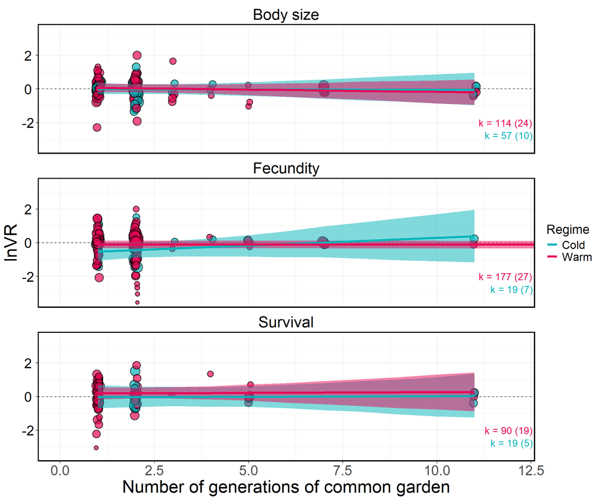

```r
# Generate predictions
emmeans_gen_common_garden <- as.data.frame(emmeans(
  lnVR_model_gen_common_garden,
  specs = ~ gen_common_garden | trait_type * warm_cold,
  at = list(gen_common_garden = seq(min(data$gen_common_garden), max(data$gen_common_garden), by = 1),
            assay_temp_diff = 0))
  ) # Conditional effects on assay_temp_diff = 0

# Calculate range of values for each category
range_df <- data %>%
  group_by(trait_type, warm_cold) %>%
  summarize(
    min_gen_common_garden = min(gen_common_garden),
    max_gen_common_garden = max(gen_common_garden)
  )

emmeans_gen_common_garden$trait_type <- factor(emmeans_gen_common_garden$trait_type,
                          levels = c("body_size", "fecundity", "survival"),
                          labels = c("Body size", "Fecundity", "Survival"))

emmeans_gen_common_garden$warm_cold <- factor(emmeans_gen_common_garden$warm_cold,
                          levels = c("cold", "warm"),
                          labels = c("Cold", "Warm"))

# Tailor predictions to the range of the data
emmeans_gen_common_garden <- emmeans_gen_common_garden %>%
  left_join(range_df, by = c("trait_type", "warm_cold")) %>%
  filter(
    gen_common_garden >= min_gen_common_garden,
    gen_common_garden <= max_gen_common_garden
  )

# Plot
ggplot() +
    geom_hline(yintercept = 0, # Horizontal line
               linetype = 2,
               colour = "black",
               alpha = 0.75) +
    geom_point(data = data,  # Effect sizes, scaled by precision
                  aes(x = gen_common_garden,
                      y = lnVR,
                      size = 1/sqrt(var_lnVR),
                      fill = warm_cold),
                  shape = 21,
                  alpha = 0.7,
                  stroke = 1,
                  position = position_jitter(width = 0.05)) +
     geom_ribbon(data = emmeans_gen_common_garden, # Shaded area for credible intervals
                 aes(x = gen_common_garden,
                     ymin = lower.HPD,
                     ymax = upper.HPD,
                     fill = warm_cold,
                     group = warm_cold),
                 alpha = .5) +
     geom_line(data = emmeans_gen_common_garden, # Predicted regression line
               aes(y = emmean,
                   x = gen_common_garden,
                   color = warm_cold,
                   group = warm_cold),
               size = 1.5) +
     geom_text(data = sample_sizes,
              aes(x = Inf,
                  y = ifelse(warm_cold == "Warm", -2, -2.75),  # Sample sizes
                  label = paste0("k = ", estimates, " (", studies, ")"),
                  color = warm_cold),
              hjust = 1.05, size = 5, show.legend = FALSE) +
  facet_wrap(~ trait_type, ncol = 1) +  # Different panels for each trait
  scale_fill_manual(values = c("#06B4BA", "#E80756"))+
  scale_color_manual(values = c("#06B4BA", "#E80756"))+
  labs(x = "Number of generations of common garden", y = "lnVR", col = "Regime") +
  theme_bw() +
  scale_size_continuous(range = c(2, 8))+
  theme(text = element_text(size = 25, color = "black"),
          legend.title = ggplot2::element_text(size = 18),
          legend.text = ggplot2::element_text(size = 16),
          axis.text.y = ggplot2::element_text(size = 20,
                colour = "black", hjust = 0.5),
          axis.text.x = ggplot2::element_text(size = 20),
        panel.border = element_rect(color = "black", size = 1.5),
        strip.background = element_blank(),
        strip.text = element_text(color = "black", size = 22)) +
    guides(fill = "none", size = "none")+
    coord_cartesian(ylim = c(-3.5, 3.5),
                    xlim = c(0, 12))
```

```r
ggsave(file = "fig/lnVR_gen_common_garden.png", width = 12, height = 7, dpi = 500)
```

### **Population size**

#### *Model specification*

```r
# Model specification
formula <- bf(lnVR ~ 0 + trait_type:warm_cold +
                          trait_type:warm_cold:assay_temp_diff +
                          trait_type:warm_cold:scale(pop_size) + # Separate effects by trait type
                (trait_type-1|ref) + # Correlation between traits among studies
                (1|species) + # Species-level random effect
                (1|gr(phylogeny, cov = phylo_matrix)) + # Phylogenetic relatedness
                (1|experiment_ID) + # Experiment-level random effect
                (1|obs) + # Observation-level random effect
                fcor(VCV_lnVR)) # Variance covariance matix of correlated sampling variances

# Define priors
prior = c(
  prior(constant(1), class = "sigma")
) # Because the residual variance-covariance structure is specified in fcor, there is no need to estimate sigma so it is left as a constant

# Fit model
lnVR_model_pop_size <- brm(formula,
                                family = gaussian(),
                                data = data,
                                data2 = list(phylo_matrix = phylo_matrix,
                                             VCV_lnVR = VCV_lnVR),
                                prior = prior,
                                control = list(adapt_delta = 0.99, max_treedepth = 15),
                                iter = 4000,
                                warmup = 2000,
                                chains = 4,
                                cores = 4,
                                seed = 123)
# Save model
saveRDS(lnVR_model_pop_size, file = "RData/lnVR_model_pop_size.rds")
```

#### *Model output*

```r
# Load model
lnVR_model_pop_size <- readRDS("RData/lnVR_model_pop_size.rds")

# Display model output
summary(lnVR_model_pop_size)
```

```
##  Family: gaussian
##   Links: mu = identity; sigma = identity
## Formula: lnVR ~ 0 + trait_type:warm_cold + trait_type:warm_cold:assay_temp_diff + trait_type:warm_cold:scale(pop_size) + (trait_type - 1 | ref) + (1 | species) + (1 | gr(phylogeny, cov = phylo_matrix)) + (1 | experiment_ID) + (1 | obs) + fcor(VCV_lnVR)
##    Data: data (Number of observations: 426)
##   Draws: 4 chains, each with iter = 4000; warmup = 2000; thin = 1;
##          total post-warmup draws = 8000
##
## Multilevel Hyperparameters:
## ~experiment_ID (Number of levels: 79)
##               Estimate Est.Error l-95% CI u-95% CI Rhat Bulk_ESS Tail_ESS
## sd(Intercept)     0.07      0.05     0.00     0.18 1.00      952     2315
##
## ~obs (Number of levels: 426)
##               Estimate Est.Error l-95% CI u-95% CI Rhat Bulk_ESS Tail_ESS
## sd(Intercept)     0.36      0.03     0.31     0.42 1.00     2535     4161
##
## ~phylogeny (Number of levels: 22)
##               Estimate Est.Error l-95% CI u-95% CI Rhat Bulk_ESS Tail_ESS
## sd(Intercept)     0.08      0.06     0.00     0.24 1.00     2431     3797
##
## ~ref (Number of levels: 41)
##                                              Estimate Est.Error l-95% CI
## sd(trait_typebody_size)                          0.07      0.06     0.00
## sd(trait_typefecundity)                          0.10      0.07     0.00
## sd(trait_typesurvival)                           0.25      0.12     0.03
## cor(trait_typebody_size,trait_typefecundity)     0.05      0.50    -0.87
## cor(trait_typebody_size,trait_typesurvival)     -0.10      0.50    -0.90
## cor(trait_typefecundity,trait_typesurvival)      0.02      0.49    -0.87
##                                              u-95% CI Rhat Bulk_ESS Tail_ESS
## sd(trait_typebody_size)                          0.21 1.00     1826     2849
## sd(trait_typefecundity)                          0.25 1.00     1356     2414
## sd(trait_typesurvival)                           0.50 1.00     1478     1451
## cor(trait_typebody_size,trait_typefecundity)     0.89 1.00     2645     4060
## cor(trait_typebody_size,trait_typesurvival)      0.84 1.00     1484     2835
## cor(trait_typefecundity,trait_typesurvival)      0.87 1.00     1913     3967
##
## ~species (Number of levels: 22)
##               Estimate Est.Error l-95% CI u-95% CI Rhat Bulk_ESS Tail_ESS
## sd(Intercept)     0.06      0.05     0.00     0.17 1.00     2499     3232
##
```

[output cut: 51 more lines]

```
## trait_typesurvival:warm_coldwarm:assay_temp_diff      5544
## trait_typebody_size:warm_coldcold:scalepop_size       4168
## trait_typefecundity:warm_coldcold:scalepop_size       4757
## trait_typesurvival:warm_coldcold:scalepop_size        4857
## trait_typebody_size:warm_coldwarm:scalepop_size       4325
## trait_typefecundity:warm_coldwarm:scalepop_size       4563
## trait_typesurvival:warm_coldwarm:scalepop_size        4889
##
## Further Distributional Parameters:
##       Estimate Est.Error l-95% CI u-95% CI Rhat Bulk_ESS Tail_ESS
## sigma     1.00      0.00     1.00     1.00   NA       NA       NA
##
## Draws were sampled using sampling(NUTS). For each parameter, Bulk_ESS
## and Tail_ESS are effective sample size measures, and Rhat is the potential
## scale reduction factor on split chains (at convergence, Rhat = 1).
```

```r
# R2
r2(lnVR_model_pop_size)
```

```
## # Bayesian R2 with Compatibility Interval
##
##   Conditional R2: 0.444 (95% CI [0.378, 0.510])
##      Marginal R2: 0.109 (95% CI [0.062, 0.161])
```

```r
# Cleaned model output
as.data.frame(fixef(lnVR_model_pop_size, summary = TRUE)) %>%
  # Rename categorical variables for cleaner display
  rownames_to_column(var = "Parameter") %>%
  mutate(
    # Simplify `trait_type` and `warm_cold` interactions
    Parameter = gsub("trait_type([a-z_]+):warm_cold(cold|warm)", "\\1(\\2)", Parameter),
    # Adjust for assay_temp_diff
    Parameter = gsub("trait_type([a-z_]+)\\((cold|warm)\\):assay_temp_diff", "\\1(\\2): assay_temp_diff", Parameter),
    # Remove "scale" from pop_size
    Parameter = gsub("scalepop_size", "pop_size", Parameter)
  ) %>%
  # Round numbers to 3 decimal points
  mutate(across(c(Estimate, Q2.5, Q97.5), ~ round(., 3))) %>%
  select(Parameter, Estimate, `Lower CI` = Q2.5, `Upper CI` = Q97.5) %>%
  kable() %>%
  kable_styling(full_width = FALSE, position = "center", fixed_thead = TRUE) %>%
  column_spec(1, bold = TRUE, border_right = TRUE) %>%
  row_spec(0, background = "white", color = "black", bold = TRUE) %>%
  kable_styling(fixed_thead = TRUE)
```

| Parameter | Estimate | Lower CI | Upper CI |
| --- | --- | --- | --- |
| body_size(cold) | 0.037 | -0.193 | 0.274 |
| fecundity(cold) | -0.371 | -0.702 | -0.030 |
| survival(cold) | -0.093 | -0.513 | 0.328 |
| body_size(warm) | -0.005 | -0.197 | 0.187 |
| fecundity(warm) | -0.062 | -0.239 | 0.119 |
| survival(warm) | 0.031 | -0.214 | 0.295 |
| body_size(cold):assay_temp_diff | 0.000 | -0.040 | 0.039 |
| fecundity(cold):assay_temp_diff | -0.171 | -0.240 | -0.103 |
| survival(cold):assay_temp_diff | -0.019 | -0.080 | 0.042 |
| body_size(warm):assay_temp_diff | 0.005 | -0.024 | 0.033 |
| fecundity(warm):assay_temp_diff | 0.004 | -0.018 | 0.027 |
| survival(warm):assay_temp_diff | 0.003 | -0.033 | 0.038 |
| body_size(cold):pop_size | -0.113 | -0.268 | 0.041 |
| fecundity(cold):pop_size | 0.043 | -0.244 | 0.329 |
| survival(cold):pop_size | 0.056 | -0.350 | 0.462 |
| body_size(warm):pop_size | -0.016 | -0.115 | 0.083 |
| fecundity(warm):pop_size | -0.060 | -0.187 | 0.060 |
| survival(warm):pop_size | -0.030 | -0.230 | 0.160 |

#### *Data visualisation*

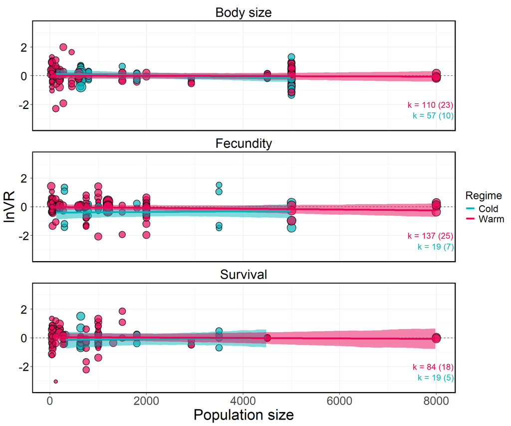

```r
# Generate predictions
emmeans_pop_size <- as.data.frame(emmeans(
  lnVR_model_pop_size,
  specs = ~ pop_size | trait_type * warm_cold,
  at = list(pop_size = seq(min(data$pop_size, na.rm=T), max(data$pop_size, na.rm=T), by = 50),
            assay_temp_diff = 0))
  ) # Conditional effects on assay_temp_diff = 0

# Calculate range of values for each category
range_df <- data %>%
  group_by(trait_type, warm_cold) %>%
  summarize(
    min_pop_size = min(pop_size, na.rm=T),
    max_pop_size = max(pop_size, na.rm=T)
  )

emmeans_pop_size$trait_type <- factor(emmeans_pop_size$trait_type,
                          levels = c("body_size", "fecundity", "survival"),
                          labels = c("Body size", "Fecundity", "Survival"))

emmeans_pop_size$warm_cold <- factor(emmeans_pop_size$warm_cold,
                          levels = c("cold", "warm"),
                          labels = c("Cold", "Warm"))

# Tailor predictions to the range of the data
emmeans_pop_size <- emmeans_pop_size %>%
  left_join(range_df, by = c("trait_type", "warm_cold")) %>%
  filter(
    pop_size >= min_pop_size,
    pop_size <= max_pop_size
  )

# Calculate sample sizes and study counts for population size
sample_sizes_pop_size <- data %>%
  filter(is.na(pop_size)==FALSE) %>%
  group_by(trait_type, warm_cold) %>%
  summarise(
    estimates = n(),
    studies = n_distinct(ref)
  )

# Plot
ggplot() +
    geom_hline(yintercept = 0, # Horizontal line
               linetype = 2,
               colour = "black",
               alpha = 0.75) +
    geom_point(data = data,  # Effect sizes, scaled by precision
                  aes(x = pop_size,
                      y = lnVR,
                      size = 1/sqrt(var_lnVR),
                      fill = warm_cold),
                  shape = 21,
                  alpha = 0.7,
                  stroke = 1,
                  position = position_jitter(width = 0.05)) +
     geom_ribbon(data = emmeans_pop_size, # Shaded area for credible intervals
                 aes(x = pop_size,
                     ymin = lower.HPD,
                     ymax = upper.HPD,
                     fill = warm_cold,
                     group = warm_cold),
                 alpha = .5) +
     geom_line(data = emmeans_pop_size, # Predicted regression line
               aes(y = emmean,
                   x = pop_size,
                   color = warm_cold,
                   group = warm_cold),
               size = 1.5) +
     geom_text(data = sample_sizes_pop_size,
              aes(x = Inf,
                  y = ifelse(warm_cold == "Warm", -2, -2.75),  # Sample sizes
                  label = paste0("k = ", estimates, " (", studies, ")"),
                  color = warm_cold),
              hjust = 1.05, size = 5, show.legend = FALSE) +
  facet_wrap(~ trait_type, ncol = 1) +  # Different panels for each trait
  scale_fill_manual(values = c("#06B4BA", "#E80756"))+
  scale_color_manual(values = c("#06B4BA", "#E80756"))+
  labs(x = "Population size", y = "lnVR", col = "Regime") +
  theme_bw() +
  scale_size_continuous(range = c(2, 8))+
  theme(text = element_text(size = 25, color = "black"),
          legend.title = ggplot2::element_text(size = 18),
          legend.text = ggplot2::element_text(size = 16),
          axis.text.y = ggplot2::element_text(size = 20,
                colour = "black", hjust = 0.5),
          axis.text.x = ggplot2::element_text(size = 20),
        panel.border = element_rect(color = "black", size = 1.5),
        strip.background = element_blank(),
        strip.text = element_text(color = "black", size = 22)) +
    guides(fill = "none", size = "none")+
    ylim(-3.5, 3.5)
```

```r
ggsave(file = "fig/lnVR_pop_size.png", width = 12, height = 7, dpi = 500)
```

### **All moderators**

#### *Model specification*

```r
# Model specification
formula <- bf(lnVR ~ 0 + trait_type:warm_cold +
                trait_type:warm_cold:assay_temp_diff +
                trait_type:warm_cold:scale(select_temp_diff) +
                trait_type:warm_cold:scale(gen_selection) +
                trait_type:warm_cold:scale(gen_common_garden) + # Separate effects by trait type
                (trait_type-1|ref) + # Correlation between traits among studies
                (1|species) + # Species-level random effect
                (1|gr(phylogeny, cov = phylo_matrix)) + # Phylogenetic relatedness
                (1|experiment_ID) + # Experiment-level random effect
                (1|obs) + # Observation-level random effect
                fcor(VCV_lnVR)) # Variance covariance matix of correlated sampling variances

# Define priors
prior = c(
  prior(constant(1), class = "sigma")
) # Because the residual variance-covariance structure is specified in fcor, there is no need to estimate sigma so it is left as a constant

# Fit model
lnVR_model_all_moderators <- brm(formula,
                                  family = gaussian(),
                                  data = data,
                                  data2 = list(phylo_matrix = phylo_matrix,
                                               VCV_lnVR = VCV_lnVR),
                                  prior = prior,
                                  control = list(adapt_delta = 0.99, max_treedepth = 15),
                                  iter = 4000,
                                  warmup = 2000,
                                  chains = 4,
                                  cores = 4,
                                  seed = 123)

# Save model
saveRDS(lnVR_model_all_moderators, file = "RData/lnVR_model_all_moderators.rds")
```

#### *Model output*

```r
# Load model
lnVR_model_all_moderators <- readRDS("RData/lnVR_model_all_moderators.rds")

# Display model output
summary(lnVR_model_all_moderators)
```

```
##  Family: gaussian
##   Links: mu = identity; sigma = identity
## Formula: lnVR ~ 0 + trait_type:warm_cold + trait_type:warm_cold:assay_temp_diff + trait_type:warm_cold:scale(select_temp_diff) + trait_type:warm_cold:scale(gen_selection) + trait_type:warm_cold:scale(gen_common_garden) + (trait_type - 1 | ref) + (1 | species) + (1 | gr(phylogeny, cov = phylo_matr…
##    Data: data (Number of observations: 476)
##   Draws: 4 chains, each with iter = 4000; warmup = 2000; thin = 1;
##          total post-warmup draws = 8000
##
## Multilevel Hyperparameters:
## ~experiment_ID (Number of levels: 88)
##               Estimate Est.Error l-95% CI u-95% CI Rhat Bulk_ESS Tail_ESS
## sd(Intercept)     0.10      0.06     0.01     0.23 1.01      897     2200
##
## ~obs (Number of levels: 476)
##               Estimate Est.Error l-95% CI u-95% CI Rhat Bulk_ESS Tail_ESS
## sd(Intercept)     0.68      0.03     0.62     0.75 1.00     3468     5446
##
## ~phylogeny (Number of levels: 25)
##               Estimate Est.Error l-95% CI u-95% CI Rhat Bulk_ESS Tail_ESS
## sd(Intercept)     0.10      0.08     0.00     0.29 1.00     2518     3463
##
## ~ref (Number of levels: 44)
##                                              Estimate Est.Error l-95% CI
## sd(trait_typebody_size)                          0.08      0.06     0.00
## sd(trait_typefecundity)                          0.08      0.07     0.00
## sd(trait_typesurvival)                           0.35      0.18     0.03
## cor(trait_typebody_size,trait_typefecundity)    -0.01      0.51    -0.88
## cor(trait_typebody_size,trait_typesurvival)     -0.02      0.50    -0.88
## cor(trait_typefecundity,trait_typesurvival)     -0.01      0.49    -0.87
##                                              u-95% CI Rhat Bulk_ESS Tail_ESS
## sd(trait_typebody_size)                          0.24 1.00     2879     3802
## sd(trait_typefecundity)                          0.25 1.00     2273     3743
## sd(trait_typesurvival)                           0.72 1.00     1272     1684
## cor(trait_typebody_size,trait_typefecundity)     0.89 1.00     5698     5658
## cor(trait_typebody_size,trait_typesurvival)      0.87 1.00     1652     3796
## cor(trait_typefecundity,trait_typesurvival)      0.86 1.00     2195     4761
##
## ~species (Number of levels: 25)
##               Estimate Est.Error l-95% CI u-95% CI Rhat Bulk_ESS Tail_ESS
## sd(Intercept)     0.06      0.05     0.00     0.19 1.00     3341     4704
##
```

[output cut: 87 more lines]

```
## trait_typesurvival:warm_coldwarm:scalegen_selection          4376     4436
## trait_typebody_size:warm_coldcold:scalegen_common_garden     4993     5306
## trait_typefecundity:warm_coldcold:scalegen_common_garden     6715     5756
## trait_typesurvival:warm_coldcold:scalegen_common_garden      4269     5049
## trait_typebody_size:warm_coldwarm:scalegen_common_garden     4005     5288
## trait_typefecundity:warm_coldwarm:scalegen_common_garden     5139     5533
## trait_typesurvival:warm_coldwarm:scalegen_common_garden      5471     5371
##
## Further Distributional Parameters:
##       Estimate Est.Error l-95% CI u-95% CI Rhat Bulk_ESS Tail_ESS
## sigma     1.00      0.00     1.00     1.00   NA       NA       NA
##
## Draws were sampled using sampling(NUTS). For each parameter, Bulk_ESS
## and Tail_ESS are effective sample size measures, and Rhat is the potential
## scale reduction factor on split chains (at convergence, Rhat = 1).
```

```r
# R2
r2(lnVR_model_all_moderators)
```

```
## # Bayesian R2 with Compatibility Interval
##
##   Conditional R2: 0.615 (95% CI [0.562, 0.664])
##      Marginal R2: 0.116 (95% CI [0.073, 0.167])
```

```r
# Cleaned model output
as.data.frame(fixef(lnVR_model_all_moderators, summary = TRUE)) %>%
  # Rename categorical variables for cleaner display
  rownames_to_column(var = "Parameter") %>%
  mutate(
    # Simplify `trait_type` and `warm_cold` interactions
    Parameter = gsub("trait_type([a-z_]+):warm_cold(cold|warm)", "\\1(\\2)", Parameter),
    # Adjust for assay_temp_diff
    Parameter = gsub("trait_type([a-z_]+)\\((cold|warm)\\):assay_temp_diff", "\\1(\\2): assay_temp_diff", Parameter),
    # Remove "scale" from all moderator variables
    Parameter = gsub("scale", "", Parameter)
  ) %>%
  # Round numbers to 3 decimal points
  mutate(across(c(Estimate, Q2.5, Q97.5), ~ round(., 3))) %>%
  select(Parameter, Estimate, `Lower CI` = Q2.5, `Upper CI` = Q97.5) %>%
  kable() %>%
  kable_styling(full_width = FALSE, position = "center", fixed_thead = TRUE) %>%
  column_spec(1, bold = TRUE, border_right = TRUE) %>%
  row_spec(0, background = "white", color = "black", bold = TRUE) %>%
  kable_styling(fixed_thead = TRUE)
```

| Parameter | Estimate | Lower CI | Upper CI |
| --- | --- | --- | --- |
| body_size(cold) | -0.083 | -0.381 | 0.231 |
| fecundity(cold) | -0.281 | -0.882 | 0.314 |
| survival(cold) | 0.112 | -0.845 | 1.094 |
| body_size(warm) | -0.036 | -0.288 | 0.230 |
| fecundity(warm) | -0.228 | -0.491 | 0.028 |
| survival(warm) | 0.222 | -0.189 | 0.669 |
| body_size(cold):assay_temp_diff | 0.000 | -0.062 | 0.062 |
| fecundity(cold):assay_temp_diff | -0.198 | -0.300 | -0.093 |
| survival(cold):assay_temp_diff | -0.018 | -0.113 | 0.080 |
| body_size(warm):assay_temp_diff | 0.016 | -0.028 | 0.061 |
| fecundity(warm):assay_temp_diff | 0.033 | -0.002 | 0.069 |
| survival(warm):assay_temp_diff | -0.026 | -0.079 | 0.029 |
| body_size(cold):select_temp_diff | 0.092 | -0.251 | 0.435 |
| fecundity(cold):select_temp_diff | -0.149 | -0.716 | 0.438 |
| survival(cold):select_temp_diff | -0.033 | -1.761 | 1.613 |
| body_size(warm):select_temp_diff | -0.175 | -0.377 | 0.028 |
| fecundity(warm):select_temp_diff | -0.108 | -0.334 | 0.114 |
| survival(warm):select_temp_diff | 0.008 | -0.290 | 0.276 |
| body_size(cold):gen_selection | 0.070 | -0.172 | 0.307 |
| fecundity(cold):gen_selection | -0.075 | -0.415 | 0.264 |
| survival(cold):gen_selection | -0.112 | -0.800 | 0.589 |
| body_size(warm):gen_selection | -0.041 | -0.179 | 0.104 |
| fecundity(warm):gen_selection | -0.131 | -0.413 | 0.146 |
| survival(warm):gen_selection | 0.033 | -0.663 | 0.756 |
| body_size(cold):gen_common_garden | -0.048 | -1.269 | 1.184 |
| fecundity(cold):gen_common_garden | 0.781 | -1.271 | 2.883 |
| survival(cold):gen_common_garden | -0.181 | -2.627 | 2.330 |
| body_size(warm):gen_common_garden | -0.167 | -1.056 | 0.735 |
| fecundity(warm):gen_common_garden | 0.009 | -0.065 | 0.083 |
| survival(warm):gen_common_garden | 0.008 | -1.465 | 1.478 |

```r
# Generate predicted values at different assay temperatures
emmeans_full_model <- as.data.frame(emmeans(
  lnVR_model_all_moderators,
  specs = ~ assay_temp_diff * select_temp_diff * gen_selection * gen_common_garden | trait_type * warm_cold,
  at = list(assay_temp_diff = c(-8.5, -4, 0, 4, 5, -5, 17, 20)) # Predict at unique min, control, max values
))

# Calculate range of values for each category
range_df <- data %>%
  group_by(trait_type, warm_cold) %>%
  summarize(
    min_assay = min(assay_temp_diff),
    max_assay = max(assay_temp_diff),
    control_assay = 0
  )

emmeans_full_model$trait_type <- factor(emmeans_full_model$trait_type,
                          levels = c("body_size", "fecundity", "survival"),
                          labels = c("Body size", "Fecundity", "Survival"))

emmeans_full_model$warm_cold <- factor(emmeans_full_model$warm_cold,
                          levels = c("cold", "warm"),
                          labels = c("Cold", "Warm"))

# Tailor predictions to the range of the data
emmeans_full_model %>%
  left_join(range_df, by = c("trait_type", "warm_cold")) %>%
  filter(
    assay_temp_diff == min_assay |
    assay_temp_diff == max_assay |
    assay_temp_diff == control_assay) %>%
    dplyr::select(-min_assay, -max_assay, -control_assay) %>%
    mutate(percentage_change = (exp(emmean) - 1) * 100,
           percentage_lower_HPD = (exp(lower.HPD) - 1) * 100,
           percentage_upper_HPD = (exp(upper.HPD) - 1) * 100) %>%
  mutate(across(c(emmean,
                  lower.HPD,
                  upper.HPD,
                  percentage_change,
                  percentage_lower_HPD,
                  percentage_upper_HPD), ~ round(., 3))) %>%   # Round numbers to 3 decimal points
  kable() %>%
  kable_styling(full_width = FALSE, position = "center", fixed_thead = TRUE) %>%
  column_spec(1, bold = TRUE, border_right = TRUE) %>%
  row_spec(0, background = "white", color = "black", bold = TRUE) %>%
  kable_styling(fixed_thead = TRUE)
```

| assay_temp_diff | select_temp_diff | gen_selection | gen_common_garden | trait_type | warm_cold | emmean | lower.HPD | upper.HPD | percentage_change | percentage_lower_HPD | percentage_upper_HPD |
| --- | --- | --- | --- | --- | --- | --- | --- | --- | --- | --- | --- |
| -8.5 | 5.64645 | 29.0084 | 2.710084 | Body size | Cold | -0.078 | -0.650 | 0.552 | -7.491 | -47.773 | 73.668 |
| 0.0 | 5.64645 | 29.0084 | 2.710084 | Body size | Cold | -0.085 | -0.392 | 0.216 | -8.108 | -32.460 | 24.050 |
| 5.0 | 5.64645 | 29.0084 | 2.710084 | Body size | Cold | -0.087 | -0.536 | 0.345 | -8.315 | -41.511 | 41.148 |
| -8.5 | 5.64645 | 29.0084 | 2.710084 | Fecundity | Cold | 1.413 | 0.302 | 2.480 | 310.635 | 35.251 | 1094.609 |
| 0.0 | 5.64645 | 29.0084 | 2.710084 | Fecundity | Cold | -0.280 | -0.865 | 0.324 | -24.434 | -57.915 | 38.311 |
| 5.0 | 5.64645 | 29.0084 | 2.710084 | Fecundity | Cold | -1.275 | -2.009 | -0.482 | -72.052 | -86.592 | -38.222 |
| -8.5 | 5.64645 | 29.0084 | 2.710084 | Survival | Cold | 0.258 | -1.001 | 1.374 | 29.383 | -63.251 | 294.925 |
| 0.0 | 5.64645 | 29.0084 | 2.710084 | Survival | Cold | 0.108 | -0.818 | 1.107 | 11.434 | -55.875 | 202.606 |
| 4.0 | 5.64645 | 29.0084 | 2.710084 | Survival | Cold | 0.034 | -1.058 | 1.090 | 3.435 | -65.279 | 197.415 |
| 0.0 | 5.64645 | 29.0084 | 2.710084 | Body size | Warm | -0.038 | -0.288 | 0.230 | -3.732 | -25.040 | 25.816 |
| -5.0 | 5.64645 | 29.0084 | 2.710084 | Body size | Warm | -0.116 | -0.524 | 0.296 | -10.944 | -40.778 | 34.449 |
| 17.0 | 5.64645 | 29.0084 | 2.710084 | Body size | Warm | 0.232 | -0.426 | 0.930 | 26.127 | -34.677 | 153.410 |
| -4.0 | 5.64645 | 29.0084 | 2.710084 | Fecundity | Warm | -0.359 | -0.706 | 0.002 | -30.160 | -50.615 | 0.224 |
| 0.0 | 5.64645 | 29.0084 | 2.710084 | Fecundity | Warm | -0.227 | -0.494 | 0.024 | -20.270 | -38.967 | 2.465 |
| 20.0 | 5.64645 | 29.0084 | 2.710084 | Fecundity | Warm | 0.429 | -0.198 | 0.999 | 53.496 | -17.938 | 171.680 |
| 0.0 | 5.64645 | 29.0084 | 2.710084 | Survival | Warm | 0.216 | -0.216 | 0.639 | 24.172 | -19.460 | 89.382 |
| -5.0 | 5.64645 | 29.0084 | 2.710084 | Survival | Warm | 0.348 | -0.204 | 0.907 | 41.687 | -18.484 | 147.766 |
| 17.0 | 5.64645 | 29.0084 | 2.710084 | Survival | Warm | -0.230 | -1.087 | 0.704 | -20.537 | -66.292 | 102.194 |

#### *Data visualisation*

**Marginal means**

```r
# Generate predictions at assay_temp_diff = 0, or 5 degrees below or above the control temperatures
emmeans_full_model <- as.data.frame(emmeans(
  lnVR_model_all_moderators,
  specs = ~ assay_temp_diff * select_temp_diff * gen_selection * gen_common_garden | trait_type * warm_cold,
  at = list(assay_temp_diff = c(-5, 0, 5) # Re-acclimated to control, or 5 degrees above/below the contol
  ))) # 2 generations of common garden

# Rename variable levels
emmeans_full_model$trait_type <- factor(emmeans_full_model$trait_type,
                          levels = c("body_size", "fecundity", "survival"),
                          labels = c("Body size", "Fecundity", "Survival"))

emmeans_full_model$warm_cold <- factor(emmeans_full_model$warm_cold,
                          levels = c("cold", "warm"),
                          labels = c("Cold", "Warm"))
emmeans_full_model
```

```
## trait_type = Body size, warm_cold = Cold:
##  assay_temp_diff select_temp_diff gen_selection gen_common_garden     emmean
##               -5          5.64645       29.0084          2.710084 -0.0806424
##                0          5.64645       29.0084          2.710084 -0.0845538
##                5          5.64645       29.0084          2.710084 -0.0868069
##   lower.HPD  upper.HPD
##  -0.4995174  0.3563673
##  -0.3924526  0.2155139
##  -0.5363397  0.3446380
##
## trait_type = Fecundity, warm_cold = Cold:
##  assay_temp_diff select_temp_diff gen_selection gen_common_garden     emmean
##               -5          5.64645       29.0084          2.710084  0.7168089
##                0          5.64645       29.0084          2.710084 -0.2801673
##                5          5.64645       29.0084          2.710084 -1.2748079
##   lower.HPD  upper.HPD
##  -0.1019656  1.5318757
##  -0.8654796  0.3243317
##  -2.0093152 -0.4816184
##
## trait_type = Survival, warm_cold = Cold:
##  assay_temp_diff select_temp_diff gen_selection gen_common_garden     emmean
##               -5          5.64645       29.0084          2.710084  0.1970046
##                0          5.64645       29.0084          2.710084  0.1082650
##                5          5.64645       29.0084          2.710084  0.0165216
##   lower.HPD  upper.HPD
##  -0.8468015  1.1983768
##  -0.8181482  1.1072615
##  -1.0856681  1.1506323
##
## trait_type = Body size, warm_cold = Warm:
##  assay_temp_diff select_temp_diff gen_selection gen_common_garden     emmean
##               -5          5.64645       29.0084          2.710084 -0.1159085
##                0          5.64645       29.0084          2.710084 -0.0380355
##                5          5.64645       29.0084          2.710084  0.0430821
##   lower.HPD  upper.HPD
##  -0.5238690  0.2960160
##  -0.2882221  0.2296495
##  -0.1989313  0.3060412
##
## trait_type = Fecundity, warm_cold = Warm:
##  assay_temp_diff select_temp_diff gen_selection gen_common_garden     emmean
##               -5          5.64645       29.0084          2.710084 -0.3919848
##                0          5.64645       29.0084          2.710084 -0.2265204
##                5          5.64645       29.0084          2.710084 -0.0649023
##   lower.HPD  upper.HPD
##  -0.7850204 -0.0203015
##  -0.4937523  0.0243536
##  -0.2884375  0.1623880
##
## trait_type = Survival, warm_cold = Warm:
##  assay_temp_diff select_temp_diff gen_selection gen_common_garden     emmean
##               -5          5.64645       29.0084          2.710084  0.3484527
##                0          5.64645       29.0084          2.710084  0.2164946
##                5          5.64645       29.0084          2.710084  0.0860855
##   lower.HPD  upper.HPD
##  -0.2043654  0.9073138
##  -0.2164120  0.6385966
##  -0.3347825  0.5339769
##
## Point estimate displayed: median
## HPD interval probability: 0.95
```

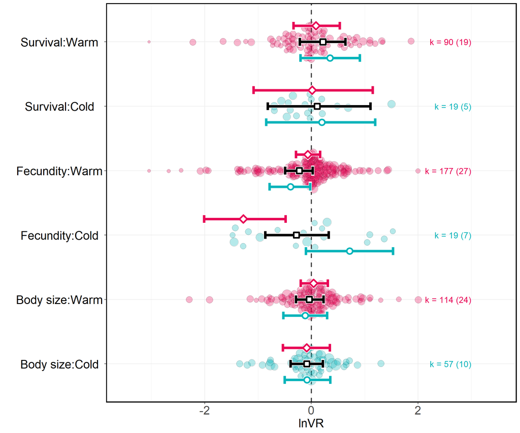

```r
# Plot
ggplot() +
    geom_hline(yintercept = 0, # Horizontal line
               linetype = 2,
               colour = "black",
               alpha = 0.75,
               lwd=1) +
    geom_quasirandom(data = data,     # Plot effect sizes, scaled by precision
                     aes(x = trait_type:warm_cold,
                         y = lnVR,
                         fill = trait_type:warm_cold,
                         size = 1/sqrt(var_lnVR)),
                     color = "black",
                     shape = 21,
                     width = 0.3,
                     alpha = 0.3) +
    geom_errorbar(data = filter(emmeans_full_model,
                                assay_temp_diff == "-5"),  # 5 degrees below control (background)
                  aes(x = trait_type:warm_cold,
                      ymin = lower.HPD,
                      ymax = upper.HPD),
                  color="white",
                  size = 2.75,
                  width = 0.16,
               position = position_nudge(x=-0.25)) +
    geom_point(data = filter(emmeans_full_model,
                             assay_temp_diff == "-5"),  # 5 degrees below control (background)
               aes(x = trait_type:warm_cold,
                   y = emmean),
               shape = 21,
               size = 4.5,
               stroke = 2,
               color="white",
               fill = "white",
               position = position_nudge(x=-0.25)) +
    geom_errorbar(data = filter(emmeans_full_model,
                             assay_temp_diff == "-5"), # 5 degrees below control (credible intervals)
                  aes(x = trait_type:warm_cold,
                      ymin = lower.HPD,
                      ymax = upper.HPD),
                  color="#06B4BA",
                  size = 2,
                  width = 0.12,
               position = position_nudge(x=-0.25)) +
    geom_point(data = filter(emmeans_full_model,
                             assay_temp_diff == "-5"), # 5 degrees below control  (point estimates)
               aes(x = trait_type:warm_cold,
                   y = emmean),
               shape = 21,
               size = 3.5,
               stroke = 2,
               color="#06B4BA",
               fill = "white",
               position = position_nudge(x=-0.25)) +

      geom_errorbar(data = filter(emmeans_full_model,
                                assay_temp_diff == "0"),  # control temperature (background)
                  aes(x = trait_type:warm_cold,
                      ymin = lower.HPD,
                      ymax = upper.HPD),
                  color="white",
                  size = 2.75,
                  width = 0.16,
               position = position_nudge(x=0)) +
    geom_point(data = filter(emmeans_full_model,
                             assay_temp_diff == "0"),  # control temperature (background)
               aes(x = trait_type:warm_cold,
                   y = emmean),
               shape = 22,
               size = 4.5,
               stroke = 2,
               color="white",
               fill = "white",
               position = position_nudge(x=0)) +
    geom_errorbar(data = filter(emmeans_full_model,
                             assay_temp_diff == "0"), # control temperature (credible intervals)
                  aes(x = trait_type:warm_cold,
                      ymin = lower.HPD,
                      ymax = upper.HPD),
                  color="black",
                  size = 2,
                  width = 0.12,
               position = position_nudge(x=0)) +
    geom_point(data = filter(emmeans_full_model,
                             assay_temp_diff == "0"), # control temperature (point estimates)
               aes(x = trait_type:warm_cold,
                   y = emmean),
               shape = 22,
               size = 3.5,
               stroke = 2,
               color="black",
               fill = "white",
               position = position_nudge(x=0)) +

      geom_errorbar(data = filter(emmeans_full_model,
                                assay_temp_diff == "5"),  # 5 degrees above control (background)
                  aes(x = trait_type:warm_cold,
                      ymin = lower.HPD,
                      ymax = upper.HPD),
                  color="white",
                  size = 2.75,
                  width = 0.16,
               position = position_nudge(x=0.25)) +
    geom_point(data = filter(emmeans_full_model,
                             assay_temp_diff == "5"),  # 5 degrees above control (background)
               aes(x = trait_type:warm_cold,
                   y = emmean),
               shape = 23,
               size = 4.5,
               stroke = 2,
               color="white",
               fill = "white",
               position = position_nudge(x=0.25)) +
    geom_errorbar(data = filter(emmeans_full_model,
                             assay_temp_diff == "5"), # 5 degrees above control (credible intervals)
                  aes(x = trait_type:warm_cold,
                      ymin = lower.HPD,
                      ymax = upper.HPD),
                  color="#E80756",
                  size = 2,
                  width = 0.12,
               position = position_nudge(x=0.25)) +
    geom_point(data = filter(emmeans_full_model,
                             assay_temp_diff == "5"), # 5 degrees above control (point estimates)
               aes(x = trait_type:warm_cold,
                   y = emmean),
               shape = 23,
               size = 3.5,
               stroke = 2,
               color="#E80756",
               fill = "white",
               position = position_nudge(x=0.25)) +

    geom_text(data = sample_sizes,  # Sample size annotations
              aes(x = trait_type:warm_cold,
                  y = 3,
                  label = paste0("k = ", estimates, " (", studies, ")"),
                  color = warm_cold),
              hjust = 1, size = 5, show.legend = FALSE) +

    theme_bw() +     # Customize the plot
    labs(y = "lnVR", x = "") +
    scale_size_continuous(range = c(2, 8))+
    scale_fill_manual(values = c("#06B4BA", "#E80756", "#06B4BA", "#E80756", "#06B4BA", "#E80756"))+
    scale_color_manual(values = c("Cold" = "#06B4BA", "Warm" = "#E80756")) +  # Text colour
    theme(text = element_text(size = 20, color = "black"),
          legend.title = ggplot2::element_text(size = 16),
          legend.text = ggplot2::element_text(size = 14),
          axis.text.y = ggplot2::element_text(size = 20,
                colour = "black", hjust = 0.5),
          axis.text.x = ggplot2::element_text(size = 20),
          panel.border = element_rect(color = "black", size = 1.5)) +
    guides(fill = "none", size = "none")+
    coord_flip() +
    ylim(-3.5, 3.5)
```

```r
ggsave(file = "fig/lnVR_all_moderators_marginal_means.png", width = 12, height = 8, dpi = 500)
```

**Overall trend with assay temperature**

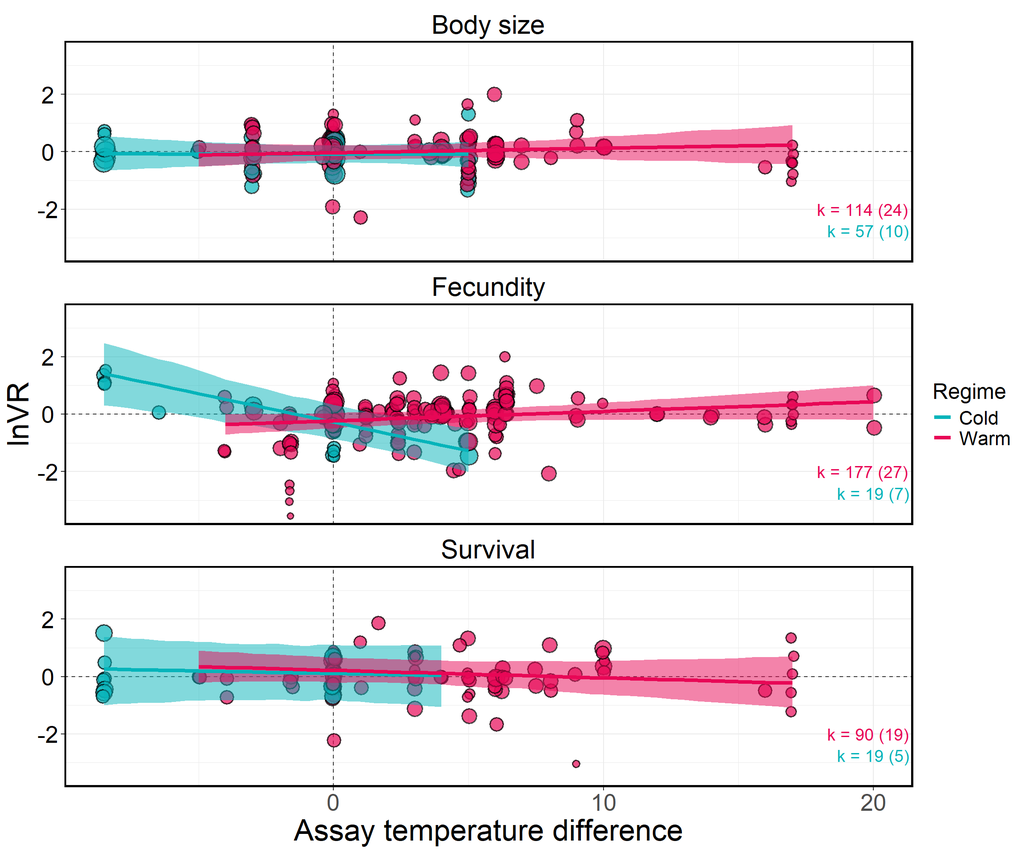

```r
# Generate predictions for all assay temperatures
emmeans_full_model_assay <- as.data.frame(emmeans(
  lnVR_model_all_moderators,
  specs = ~ assay_temp_diff * select_temp_diff * gen_selection * gen_common_garden | trait_type * warm_cold,
  at = list(assay_temp_diff = seq(min(data$assay_temp_diff), max(data$assay_temp_diff), by = 0.5) # Re-acclimated to control, or 5 degrees above/below the contol
  )))


# Calculate range of values for each category
range_df <- data %>%
  group_by(trait_type, warm_cold) %>%
  summarize(
    min_assay_temp_diff = min(assay_temp_diff),
    max_assay_temp_diff = max(assay_temp_diff)
  )

# Rename variable levels
emmeans_full_model_assay$trait_type <- factor(emmeans_full_model_assay$trait_type,
                          levels = c("body_size", "fecundity", "survival"),
                          labels = c("Body size", "Fecundity", "Survival"))

emmeans_full_model_assay$warm_cold <- factor(emmeans_full_model_assay$warm_cold,
                          levels = c("cold", "warm"),
                          labels = c("Cold", "Warm"))

# Tailor predictions to the range of the data
emmeans_full_model_assay <- emmeans_full_model_assay %>%
  left_join(range_df, by = c("trait_type", "warm_cold")) %>%
  filter(
    assay_temp_diff >= min_assay_temp_diff,
    assay_temp_diff <= max_assay_temp_diff
  )


# Plot
ggplot() +
    geom_hline(yintercept = 0, # Horizontal line
               linetype = 2,
               colour = "black",
               alpha = 0.75) +
    geom_vline(xintercept = 0, # Vertical line
               linetype = 2,
               colour = "black",
               alpha = 0.75) +
    geom_point(data = data, # Effect sizes, scaled by precision
                  aes(x = assay_temp_diff,
                      y = lnVR,
                      size = 1/sqrt(var_lnVR),
                      fill = warm_cold),
                  shape = 21,
                  alpha = 0.7,
                  stroke = 1,
                  position = position_jitter(width = 0.05)) +
     geom_ribbon(data = emmeans_full_model_assay, # Shaded area for credible intervals
                 aes(x = assay_temp_diff,
                     ymin = lower.HPD,
                     ymax = upper.HPD,
                     fill = warm_cold,
                     group = warm_cold),
                 alpha = .5) +
     geom_line(data = emmeans_full_model_assay,  # Predicted regression line
               aes(y = emmean,
                   x = assay_temp_diff,
                   color = warm_cold,
                   group = warm_cold),
               size = 1.5) +

    geom_text(data = sample_sizes,
              aes(x = Inf,
                  y = ifelse(warm_cold == "Warm", -2, -2.75),  # Sample sizes
                  label = paste0("k = ", estimates, " (", studies, ")"),
                  color = warm_cold),
              hjust = 1.05, size = 5, show.legend = FALSE) +

  facet_wrap(~ trait_type, ncol = 1) + # Different panels for each trait
  scale_fill_manual(values = c("#06B4BA", "#E80756"))+
  scale_color_manual(values = c("#06B4BA", "#E80756"))+
  labs(x = "Assay temperature difference", y = "lnVR",
       col = "Regime") +
  theme_bw() +
  scale_size_continuous(range = c(2, 8))+
  theme(text = element_text(size = 25, color = "black"),
          legend.title = ggplot2::element_text(size = 18),
          legend.text = ggplot2::element_text(size = 16),
          axis.text.y = ggplot2::element_text(size = 20,
                colour = "black", hjust = 0.5),
          axis.text.x = ggplot2::element_text(size = 20),
        panel.border = element_rect(color = "black", size = 1.5),
        strip.background = element_blank(),
        strip.text = element_text(color = "black", size = 22)) +
    guides(fill = "none", size = "none")+
    coord_cartesian(ylim = c(-3.5, 3.5))
```

```r
ggsave(file = "fig/lnVR_all_moderators_assay_temp_diff.png", width = 12, height = 10, dpi = 500)
```

# **Publication bias**

## **Changes in mean responses (lnRR)**

### **Egger’s regression**

#### *Model specification*

```r
# Model specification
formula <- bf(lnRR ~ 0 + trait_type:warm_cold +
                         trait_type:warm_cold:assay_temp_diff +
                         trait_type:warm_cold:var_lnRR + # Separate effects by trait type
                (trait_type-1|ref) + # Correlation between traits among studies
                (1|species) + # Species-level random effect
                (1|gr(phylogeny, cov = phylo_matrix)) + # Phylogenetic relatedness
                (1|experiment_ID) + # Experiment-level random effect
                (1|obs) + # Observation-level random effect
                fcor(VCV_lnRR)) # Variance covariance matix of correlated sampling variances

# Define priors
prior = c(
  prior(constant(1), class = "sigma")
) # Because the residual variance-covariance structure is specified in fcor, there is no need to estimate sigma so it is left as a constant

# Fit model
lnRR_model_pub_bias_var <- brm(formula,
                                            family = gaussian(),
                                            data = data,
                                            data2 = list(phylo_matrix = phylo_matrix,
                                                         VCV_lnRR = VCV_lnRR),
                                            prior = prior,
                                            control = list(adapt_delta = 0.99, max_treedepth = 15),
                                            iter = 4000,
                                            warmup = 2000,
                                            chains = 4,
                                            cores = 4,
                                            seed = 123)
# Save model
saveRDS(lnRR_model_pub_bias_var, file = "RData/lnRR_model_pub_bias_var.rds")
```

#### *Model output*

```r
# Load model
lnRR_model_pub_bias_var <- readRDS("RData/lnRR_model_pub_bias_var.rds")

# Display model output
summary(lnRR_model_pub_bias_var)
```

```
##  Family: gaussian
##   Links: mu = identity; sigma = identity
## Formula: lnRR ~ 0 + trait_type:warm_cold + trait_type:warm_cold:assay_temp_diff + trait_type:warm_cold:var_lnRR + (trait_type - 1 | ref) + (1 | species) + (1 | gr(phylogeny, cov = phylo_matrix)) + (1 | experiment_ID) + (1 | obs) + fcor(VCV_lnRR)
##    Data: data (Number of observations: 476)
##   Draws: 4 chains, each with iter = 4000; warmup = 2000; thin = 1;
##          total post-warmup draws = 8000
##
## Multilevel Hyperparameters:
## ~experiment_ID (Number of levels: 88)
##               Estimate Est.Error l-95% CI u-95% CI Rhat Bulk_ESS Tail_ESS
## sd(Intercept)     0.02      0.01     0.00     0.04 1.01      625      928
##
## ~obs (Number of levels: 476)
##               Estimate Est.Error l-95% CI u-95% CI Rhat Bulk_ESS Tail_ESS
## sd(Intercept)     0.05      0.00     0.04     0.06 1.00     1762     3592
##
## ~phylogeny (Number of levels: 25)
##               Estimate Est.Error l-95% CI u-95% CI Rhat Bulk_ESS Tail_ESS
## sd(Intercept)     0.03      0.02     0.00     0.07 1.00     1805     3058
##
## ~ref (Number of levels: 44)
##                                              Estimate Est.Error l-95% CI
## sd(trait_typebody_size)                          0.01      0.01     0.00
## sd(trait_typefecundity)                          0.21      0.04     0.15
## sd(trait_typesurvival)                           0.13      0.03     0.07
## cor(trait_typebody_size,trait_typefecundity)    -0.18      0.46    -0.92
## cor(trait_typebody_size,trait_typesurvival)      0.02      0.49    -0.86
## cor(trait_typefecundity,trait_typesurvival)     -0.23      0.50    -0.94
##                                              u-95% CI Rhat Bulk_ESS Tail_ESS
## sd(trait_typebody_size)                          0.03 1.00     1307     2565
## sd(trait_typefecundity)                          0.29 1.00     3203     5556
## sd(trait_typesurvival)                           0.20 1.00     3705     5525
## cor(trait_typebody_size,trait_typefecundity)     0.77 1.02      244      684
## cor(trait_typebody_size,trait_typesurvival)      0.88 1.01      789     2165
## cor(trait_typefecundity,trait_typesurvival)      0.77 1.00      970     2410
##
## ~species (Number of levels: 25)
##               Estimate Est.Error l-95% CI u-95% CI Rhat Bulk_ESS Tail_ESS
## sd(Intercept)     0.02      0.01     0.00     0.05 1.00     1987     3132
##
```

[output cut: 51 more lines]

```
## trait_typesurvival:warm_coldwarm:assay_temp_diff      5221
## trait_typebody_size:warm_coldcold:var_lnRR            5560
## trait_typefecundity:warm_coldcold:var_lnRR            6420
## trait_typesurvival:warm_coldcold:var_lnRR             5414
## trait_typebody_size:warm_coldwarm:var_lnRR            6098
## trait_typefecundity:warm_coldwarm:var_lnRR            6408
## trait_typesurvival:warm_coldwarm:var_lnRR             6471
##
## Further Distributional Parameters:
##       Estimate Est.Error l-95% CI u-95% CI Rhat Bulk_ESS Tail_ESS
## sigma     1.00      0.00     1.00     1.00   NA       NA       NA
##
## Draws were sampled using sampling(NUTS). For each parameter, Bulk_ESS
## and Tail_ESS are effective sample size measures, and Rhat is the potential
## scale reduction factor on split chains (at convergence, Rhat = 1).
```

```r
# R2
r2(lnRR_model_pub_bias_var)
```

```
## # Bayesian R2 with Compatibility Interval
##
##   Conditional R2: 0.333 (95% CI [0.258, 0.412])
##      Marginal R2: 0.194 (95% CI [0.068, 0.340])
```

```r
# Cleaned model output
as.data.frame(fixef(lnRR_model_pub_bias_var, summary = TRUE)) %>%
  # Rename categorical variables for cleaner display
  rownames_to_column(var = "Parameter") %>%
  mutate(
    Parameter = gsub("trait_type([a-z_]+):warm_cold(cold|warm)", "\\1(\\2)", Parameter),
    Parameter = gsub("trait_type([a-z_]+)\\(warm\\):assay_temp_diff", "\\1(warm): assay_temp_diff", Parameter)
  ) %>%
  # Round numbers to 3 decimal points
  mutate(across(c(Estimate, Q2.5, Q97.5), ~ round(., 3))) %>%
  select(Parameter, Estimate, `Lower CI` = Q2.5, `Upper CI` = Q97.5) %>%
  kable() %>%
  kable_styling(full_width = FALSE, position = "center", fixed_thead = TRUE) %>%
  column_spec(1, bold = TRUE, border_right = TRUE) %>%
  row_spec(0, background = "white", color = "black", bold = TRUE) %>%
  kable_styling(fixed_thead = TRUE)
```

| Parameter | Estimate | Lower CI | Upper CI |
| --- | --- | --- | --- |
| body_size(cold) | 0.034 | -0.013 | 0.082 |
| fecundity(cold) | -0.298 | -0.456 | -0.143 |
| survival(cold) | -0.087 | -0.222 | 0.058 |
| body_size(warm) | 0.003 | -0.043 | 0.048 |
| fecundity(warm) | -0.040 | -0.133 | 0.055 |
| survival(warm) | -0.019 | -0.096 | 0.058 |
| body_size(cold):assay_temp_diff | 0.001 | -0.003 | 0.006 |
| fecundity(cold):assay_temp_diff | -0.066 | -0.076 | -0.055 |
| survival(cold):assay_temp_diff | -0.045 | -0.054 | -0.035 |
| body_size(warm):assay_temp_diff | -0.001 | -0.004 | 0.003 |
| fecundity(warm):assay_temp_diff | 0.004 | -0.003 | 0.012 |
| survival(warm):assay_temp_diff | 0.005 | -0.002 | 0.011 |
| body_size(cold):var_lnRR | -37.450 | -69.801 | -6.116 |
| fecundity(cold):var_lnRR | 9.258 | 2.897 | 15.765 |
| survival(cold):var_lnRR | 2.893 | -6.477 | 12.231 |
| body_size(warm):var_lnRR | -6.010 | -12.925 | 0.805 |
| fecundity(warm):var_lnRR | 0.204 | -0.161 | 0.562 |
| survival(warm):var_lnRR | 0.575 | -0.330 | 1.468 |

#### *Data visualisation*

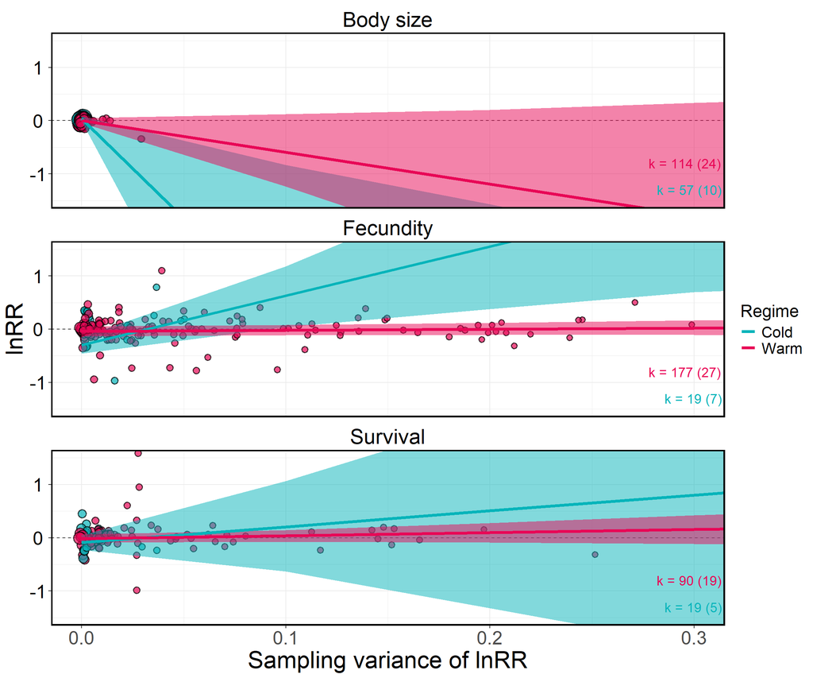

```r
# Generate predictions
emmeans_pub_bias_var <- as.data.frame(emmeans(
  lnRR_model_pub_bias_var,
  specs = ~ var_lnRR | trait_type * warm_cold,
  at = list(var_lnRR = seq(0, max(data$var_lnRR), by = 0.1),
            assay_temp_diff = 0))
  ) # Conditional effects on assay_temp_diff = 0

emmeans_pub_bias_var$trait_type <- factor(emmeans_pub_bias_var$trait_type,
                          levels = c("body_size", "fecundity", "survival"),
                          labels = c("Body size", "Fecundity", "Survival"))

emmeans_pub_bias_var$warm_cold <- factor(emmeans_pub_bias_var$warm_cold,
                          levels = c("cold", "warm"),
                          labels = c("Cold", "Warm"))

# Plot
ggplot() +
    geom_hline(yintercept = 0, # Horizontal line
               linetype = 2,
               colour = "black",
               alpha = 0.75) +
    geom_point(data = data,  # Effect sizes, scaled by precision
                  aes(x = var_lnRR,
                      y = lnRR,
                      size = 1/sqrt(var_lnRR),
                      fill = warm_cold),
                  shape = 21,
                  alpha = 0.7,
                  stroke = 1,
                  position = position_jitter(width = 0.001)) +
     geom_ribbon(data = emmeans_pub_bias_var, # Shaded area for credible intervals
                 aes(x = var_lnRR,
                     ymin = lower.HPD,
                     ymax = upper.HPD,
                     fill = warm_cold,
                     group = warm_cold),
                 alpha = .5) +
     geom_line(data = emmeans_pub_bias_var, # Predicted regression line
               aes(y = emmean,
                   x = var_lnRR,
                   color = warm_cold,
                   group = warm_cold),
               size = 1.5) +
     geom_text(data = sample_sizes,
              aes(x = Inf,
                  y = ifelse(warm_cold == "Warm", -0.8, -1.3),  # Sample sizes
                  label = paste0("k = ", estimates, " (", studies, ")"),
                  color = warm_cold),
              hjust = 1.05, size = 5, show.legend = FALSE) +
  facet_wrap(~ trait_type, ncol = 1) +  # Different panels for each trait
  scale_fill_manual(values = c("#06B4BA", "#E80756"))+
  scale_color_manual(values = c("#06B4BA", "#E80756"))+
  labs(x = "Sampling variance of lnRR", y = "lnRR", col = "Regime") +
  theme_bw() +
  scale_size_continuous(range = c(2, 8))+
  theme(text = element_text(size = 25, color = "black"),
          legend.title = ggplot2::element_text(size = 18),
          legend.text = ggplot2::element_text(size = 16),
          axis.text.y = ggplot2::element_text(size = 20,
                colour = "black", hjust = 0.5),
          axis.text.x = ggplot2::element_text(size = 20),
        panel.border = element_rect(color = "black", size = 1.5),
        strip.background = element_blank(),
        strip.text = element_text(color = "black", size = 22)) +
    guides(fill = "none", size = "none")+
    coord_cartesian(ylim = c(-1.5, 1.5), xlim = c(0, 0.3))
```

```r
ggsave(file = "fig/lnRR_pub_bias_var.png", width = 12, height = 7, dpi = 500)
```

### **Publication year**

#### *Model specification*

```r
# Model specification
formula <- bf(lnRR ~ 0 + trait_type:warm_cold +
                         trait_type:warm_cold:assay_temp_diff +
                         trait_type:warm_cold:scale(pub_year) + # Separate effects by trait type
                (trait_type-1|ref) + # Correlation between traits among studies
                (1|species) + # Species-level random effect
                (1|gr(phylogeny, cov = phylo_matrix)) + # Phylogenetic relatedness
                (1|experiment_ID) + # Experiment-level random effect
                (1|obs) + # Observation-level random effect
                fcor(VCV_lnRR)) # Variance covariance matix of correlated sampling variances

# Define priors
prior = c(
  prior(constant(1), class = "sigma")
) # Because the residual variance-covariance structure is specified in fcor, there is no need to estimate sigma so it is left as a constant

# Fit model
lnRR_model_pub_bias_year <- brm(formula,
                                            family = gaussian(),
                                            data = data,
                                            data2 = list(phylo_matrix = phylo_matrix,
                                                         VCV_lnRR = VCV_lnRR),
                                            prior = prior,
                                            control = list(adapt_delta = 0.99, max_treedepth = 15),
                                            iter = 4000,
                                            warmup = 2000,
                                            chains = 4,
                                            cores = 4,
                                            seed = 123)
# Save model
saveRDS(lnRR_model_pub_bias_year, file = "RData/lnRR_model_pub_bias_year.rds")
```

#### *Model output*

```r
# Load model
lnRR_model_pub_bias_year <- readRDS("RData/lnRR_model_pub_bias_year.rds")

# Display model output
summary(lnRR_model_pub_bias_year)
```

```
##  Family: gaussian
##   Links: mu = identity; sigma = identity
## Formula: lnRR ~ 0 + trait_type:warm_cold + trait_type:warm_cold:assay_temp_diff + trait_type:warm_cold:scale(pub_year) + (trait_type - 1 | ref) + (1 | species) + (1 | gr(phylogeny, cov = phylo_matrix)) + (1 | experiment_ID) + (1 | obs) + fcor(VCV_lnRR)
##    Data: data (Number of observations: 476)
##   Draws: 4 chains, each with iter = 4000; warmup = 2000; thin = 1;
##          total post-warmup draws = 8000
##
## Multilevel Hyperparameters:
## ~experiment_ID (Number of levels: 88)
##               Estimate Est.Error l-95% CI u-95% CI Rhat Bulk_ESS Tail_ESS
## sd(Intercept)     0.02      0.01     0.00     0.04 1.01      636      935
##
## ~obs (Number of levels: 476)
##               Estimate Est.Error l-95% CI u-95% CI Rhat Bulk_ESS Tail_ESS
## sd(Intercept)     0.05      0.00     0.04     0.06 1.00     1762     2828
##
## ~phylogeny (Number of levels: 25)
##               Estimate Est.Error l-95% CI u-95% CI Rhat Bulk_ESS Tail_ESS
## sd(Intercept)     0.02      0.02     0.00     0.06 1.00     2547     3963
##
## ~ref (Number of levels: 44)
##                                              Estimate Est.Error l-95% CI
## sd(trait_typebody_size)                          0.01      0.01     0.00
## sd(trait_typefecundity)                          0.20      0.04     0.14
## sd(trait_typesurvival)                           0.12      0.03     0.07
## cor(trait_typebody_size,trait_typefecundity)    -0.09      0.48    -0.88
## cor(trait_typebody_size,trait_typesurvival)      0.09      0.49    -0.83
## cor(trait_typefecundity,trait_typesurvival)     -0.17      0.48    -0.93
##                                              u-95% CI Rhat Bulk_ESS Tail_ESS
## sd(trait_typebody_size)                          0.03 1.00     1842     3407
## sd(trait_typefecundity)                          0.28 1.00     3405     5116
## sd(trait_typesurvival)                           0.19 1.00     3689     5281
## cor(trait_typebody_size,trait_typefecundity)     0.82 1.01      457     1387
## cor(trait_typebody_size,trait_typesurvival)      0.89 1.01      928     2233
## cor(trait_typefecundity,trait_typesurvival)      0.73 1.00     1472     3245
##
## ~species (Number of levels: 25)
##               Estimate Est.Error l-95% CI u-95% CI Rhat Bulk_ESS Tail_ESS
## sd(Intercept)     0.02      0.01     0.00     0.04 1.00     2734     4675
##
```

[output cut: 51 more lines]

```
## trait_typesurvival:warm_coldwarm:assay_temp_diff      5181
## trait_typebody_size:warm_coldcold:scalepub_year       3673
## trait_typefecundity:warm_coldcold:scalepub_year       5820
## trait_typesurvival:warm_coldcold:scalepub_year        5389
## trait_typebody_size:warm_coldwarm:scalepub_year       4412
## trait_typefecundity:warm_coldwarm:scalepub_year       4828
## trait_typesurvival:warm_coldwarm:scalepub_year        5519
##
## Further Distributional Parameters:
##       Estimate Est.Error l-95% CI u-95% CI Rhat Bulk_ESS Tail_ESS
## sigma     1.00      0.00     1.00     1.00   NA       NA       NA
##
## Draws were sampled using sampling(NUTS). For each parameter, Bulk_ESS
## and Tail_ESS are effective sample size measures, and Rhat is the potential
## scale reduction factor on split chains (at convergence, Rhat = 1).
```

```r
# R2
r2(lnRR_model_pub_bias_year)
```

```
## # Bayesian R2 with Compatibility Interval
##
##   Conditional R2: 0.276 (95% CI [0.225, 0.326])
##      Marginal R2: 0.082 (95% CI [0.050, 0.125])
```

```r
# Cleaned model output
as.data.frame(fixef(lnRR_model_pub_bias_year, summary = TRUE)) %>%
  # Rename categorical variables for cleaner display
  rownames_to_column(var = "Parameter") %>%
  mutate(
    # Simplify `trait_type` and `warm_cold` interactions
    Parameter = gsub("trait_type([a-z_]+):warm_cold(cold|warm)", "\\1(\\2)", Parameter),
    # Adjust for assay_temp_diff
    Parameter = gsub("trait_type([a-z_]+)\\((cold|warm)\\):assay_temp_diff", "\\1(\\2): assay_temp_diff", Parameter),
    # Remove "scale" from pub_year
    Parameter = gsub("scalepub_year", "pub_year", Parameter)
  ) %>%
  # Round numbers to 3 decimal points
  mutate(across(c(Estimate, Q2.5, Q97.5), ~ round(., 3))) %>%
  select(Parameter, Estimate, `Lower CI` = Q2.5, `Upper CI` = Q97.5) %>%
  kable() %>%
  kable_styling(full_width = FALSE, position = "center", fixed_thead = TRUE) %>%
  column_spec(1, bold = TRUE, border_right = TRUE) %>%
  row_spec(0, background = "white", color = "black", bold = TRUE) %>%
  kable_styling(fixed_thead = TRUE)
```

| Parameter | Estimate | Lower CI | Upper CI |
| --- | --- | --- | --- |
| body_size(cold) | 0.011 | -0.035 | 0.056 |
| fecundity(cold) | -0.096 | -0.231 | 0.032 |
| survival(cold) | -0.007 | -0.164 | 0.152 |
| body_size(warm) | -0.005 | -0.049 | 0.036 |
| fecundity(warm) | -0.032 | -0.124 | 0.059 |
| survival(warm) | -0.016 | -0.093 | 0.066 |
| body_size(cold):assay_temp_diff | 0.002 | -0.003 | 0.007 |
| fecundity(cold):assay_temp_diff | -0.063 | -0.074 | -0.053 |
| survival(cold):assay_temp_diff | -0.045 | -0.054 | -0.035 |
| body_size(warm):assay_temp_diff | -0.001 | -0.004 | 0.002 |
| fecundity(warm):assay_temp_diff | 0.004 | -0.003 | 0.011 |
| survival(warm):assay_temp_diff | 0.005 | -0.002 | 0.011 |
| body_size(cold):pub_year | -0.008 | -0.030 | 0.013 |
| fecundity(cold):pub_year | 0.157 | 0.062 | 0.256 |
| survival(cold):pub_year | 0.063 | -0.054 | 0.175 |
| body_size(warm):pub_year | 0.006 | -0.015 | 0.026 |
| fecundity(warm):pub_year | 0.038 | -0.039 | 0.119 |
| survival(warm):pub_year | 0.042 | -0.033 | 0.117 |

#### *Data visualisation*

[figure not shown]

```r
# Generate predictions
emmeans_pub_bias_year <- as.data.frame(emmeans(
  lnRR_model_pub_bias_year,
  specs = ~ pub_year | trait_type * warm_cold,
  at = list(pub_year = seq(min(data$pub_year), max(data$pub_year), by = 1),
            assay_temp_diff = 0))
  ) # Conditional effects on assay_temp_diff = 0

# Calculate range of values for each category
range_df <- data %>%
  group_by(trait_type, warm_cold) %>%
  summarize(
    min_pub_year = min(pub_year),
    max_pub_year = max(pub_year)
  )

emmeans_pub_bias_year$trait_type <- factor(emmeans_pub_bias_year$trait_type,
                          levels = c("body_size", "fecundity", "survival"),
                          labels = c("Body size", "Fecundity", "Survival"))

emmeans_pub_bias_year$warm_cold <- factor(emmeans_pub_bias_year$warm_cold,
                          levels = c("cold", "warm"),
                          labels = c("Cold", "Warm"))

# Tailor predictions to the range of the data
emmeans_pub_bias_year <- emmeans_pub_bias_year %>%
  left_join(range_df, by = c("trait_type", "warm_cold")) %>%
  filter(
    pub_year >= min_pub_year,
    pub_year <= max_pub_year
  )

# Plot
ggplot() +
    geom_hline(yintercept = 0, # Horizontal line
               linetype = 2,
               colour = "black",
               alpha = 0.75) +
    geom_point(data = data,  # Effect sizes, scaled by precision
                  aes(x = pub_year,
                      y = lnRR,
                      size = 1/sqrt(var_lnRR),
                      fill = warm_cold),
                  shape = 21,
                  alpha = 0.7,
                  stroke = 1,
                  position = position_jitter(width = 0.05)) +
     geom_ribbon(data = emmeans_pub_bias_year, # Shaded area for credible intervals
                 aes(x = pub_year,
                     ymin = lower.HPD,
                     ymax = upper.HPD,
                     fill = warm_cold,
                     group = warm_cold),
                 alpha = .5) +
     geom_line(data = emmeans_pub_bias_year, # Predicted regression line
               aes(y = emmean,
                   x = pub_year,
                   color = warm_cold,
                   group = warm_cold),
               size = 1.5) +
     geom_text(data = sample_sizes,
              aes(x = Inf,
                  y = ifelse(warm_cold == "Warm", -0.9, -1.3),  # Sample sizes
                  label = paste0("k = ", estimates, " (", studies, ")"),
                  color = warm_cold),
              hjust = 1.05, size = 5, show.legend = FALSE) +
  facet_wrap(~ trait_type, ncol = 1) +  # Different panels for each trait
  scale_fill_manual(values = c("#06B4BA", "#E80756"))+
  scale_color_manual(values = c("#06B4BA", "#E80756"))+
  labs(x = "Sampling variance of lnRR", y = "lnRR", col = "Regime") +
  theme_bw() +
  scale_size_continuous(range = c(2, 8))+
  theme(text = element_text(size = 25, color = "black"),
          legend.title = ggplot2::element_text(size = 18),
          legend.text = ggplot2::element_text(size = 16),
          axis.text.y = ggplot2::element_text(size = 20,
                colour = "black", hjust = 0.5),
          axis.text.x = ggplot2::element_text(size = 20),
        panel.border = element_rect(color = "black", size = 1.5),
        strip.background = element_blank(),
        strip.text = element_text(color = "black", size = 22)) +
    guides(fill = "none", size = "none") +
    coord_cartesian(ylim = c(-1.5, 1.5))
```

```r
ggsave(file = "fig/lnRR_pub_bias_year.png", width = 12, height = 7, dpi = 500)
```

## **Changes in relative trait variance (lnCVR)**

### **Egger’s regression**

#### *Model specification*

```r
# Model specification
formula <- bf(lnCVR ~ 0 + trait_type:warm_cold +
                         trait_type:warm_cold:assay_temp_diff +
                         trait_type:warm_cold:var_lnCVR + # Separate effects by trait type
                (trait_type-1|ref) + # Correlation between traits among studies
                (1|species) + # Species-level random effect
                (1|gr(phylogeny, cov = phylo_matrix)) + # Phylogenetic relatedness
                (1|experiment_ID) + # Experiment-level random effect
                (1|obs) + # Observation-level random effect
                fcor(VCV_lnCVR)) # Variance covariance matix of correlated sampling variances

# Define priors
prior = c(
  prior(constant(1), class = "sigma")
) # Because the residual variance-covariance structure is specified in fcor, there is no need to estimate sigma so it is left as a constant

# Fit model
lnCVR_model_pub_bias_var <- brm(formula,
                                            family = gaussian(),
                                            data = data,
                                            data2 = list(phylo_matrix = phylo_matrix,
                                                         VCV_lnCVR = VCV_lnCVR),
                                            prior = prior,
                                            control = list(adapt_delta = 0.99, max_treedepth = 15),
                                            iter = 4000,
                                            warmup = 2000,
                                            chains = 4,
                                            cores = 4,
                                            seed = 123)
# Save model
saveRDS(lnCVR_model_pub_bias_var, file = "RData/lnCVR_model_pub_bias_var.rds")
```

#### *Model output*

```r
# Load model
lnCVR_model_pub_bias_var <- readRDS("RData/lnCVR_model_pub_bias_var.rds")

# Display model output
summary(lnCVR_model_pub_bias_var)
```

```
##  Family: gaussian
##   Links: mu = identity; sigma = identity
## Formula: lnCVR ~ 0 + trait_type:warm_cold + trait_type:warm_cold:assay_temp_diff + trait_type:warm_cold:var_lnCVR + (trait_type - 1 | ref) + (1 | species) + (1 | gr(phylogeny, cov = phylo_matrix)) + (1 | experiment_ID) + (1 | obs) + fcor(VCV_lnCVR)
##    Data: data (Number of observations: 476)
##   Draws: 4 chains, each with iter = 4000; warmup = 2000; thin = 1;
##          total post-warmup draws = 8000
##
## Multilevel Hyperparameters:
## ~experiment_ID (Number of levels: 88)
##               Estimate Est.Error l-95% CI u-95% CI Rhat Bulk_ESS Tail_ESS
## sd(Intercept)     0.10      0.05     0.01     0.20 1.00     1063     2440
##
## ~obs (Number of levels: 476)
##               Estimate Est.Error l-95% CI u-95% CI Rhat Bulk_ESS Tail_ESS
## sd(Intercept)     0.39      0.04     0.32     0.47 1.00     1981     3628
##
## ~phylogeny (Number of levels: 25)
##               Estimate Est.Error l-95% CI u-95% CI Rhat Bulk_ESS Tail_ESS
## sd(Intercept)     0.09      0.07     0.00     0.27 1.00     2920     3914
##
## ~ref (Number of levels: 44)
##                                              Estimate Est.Error l-95% CI
## sd(trait_typebody_size)                          0.06      0.05     0.00
## sd(trait_typefecundity)                          0.11      0.09     0.00
## sd(trait_typesurvival)                           0.56      0.16     0.28
## cor(trait_typebody_size,trait_typefecundity)     0.06      0.49    -0.85
## cor(trait_typebody_size,trait_typesurvival)     -0.01      0.50    -0.86
## cor(trait_typefecundity,trait_typesurvival)     -0.01      0.44    -0.83
##                                              u-95% CI Rhat Bulk_ESS Tail_ESS
## sd(trait_typebody_size)                          0.18 1.00     3284     3493
## sd(trait_typefecundity)                          0.31 1.00     1690     3775
## sd(trait_typesurvival)                           0.92 1.00     2562     3420
## cor(trait_typebody_size,trait_typefecundity)     0.89 1.00     3344     4650
## cor(trait_typebody_size,trait_typesurvival)      0.88 1.00      962     2589
## cor(trait_typefecundity,trait_typesurvival)      0.82 1.00     1421     3139
##
## ~species (Number of levels: 25)
##               Estimate Est.Error l-95% CI u-95% CI Rhat Bulk_ESS Tail_ESS
## sd(Intercept)     0.06      0.05     0.00     0.19 1.00     2752     4177
##
```

[output cut: 51 more lines]

```
## trait_typesurvival:warm_coldwarm:assay_temp_diff      5976
## trait_typebody_size:warm_coldcold:var_lnCVR           5437
## trait_typefecundity:warm_coldcold:var_lnCVR           5453
## trait_typesurvival:warm_coldcold:var_lnCVR            3062
## trait_typebody_size:warm_coldwarm:var_lnCVR           5782
## trait_typefecundity:warm_coldwarm:var_lnCVR           5876
## trait_typesurvival:warm_coldwarm:var_lnCVR            5871
##
## Further Distributional Parameters:
##       Estimate Est.Error l-95% CI u-95% CI Rhat Bulk_ESS Tail_ESS
## sigma     1.00      0.00     1.00     1.00   NA       NA       NA
##
## Draws were sampled using sampling(NUTS). For each parameter, Bulk_ESS
## and Tail_ESS are effective sample size measures, and Rhat is the potential
## scale reduction factor on split chains (at convergence, Rhat = 1).
```

```r
# R2
r2(lnCVR_model_pub_bias_var)
```

```
## # Bayesian R2 with Compatibility Interval
##
##   Conditional R2: 0.451 (95% CI [0.323, 0.543])
##      Marginal R2: 0.392 (95% CI [0.142, 0.515])
```

```r
# Cleaned model output
as.data.frame(fixef(lnCVR_model_pub_bias_var, summary = TRUE)) %>%
  # Rename categorical variables for cleaner display
  rownames_to_column(var = "Parameter") %>%
  mutate(
    Parameter = gsub("trait_type([a-z_]+):warm_cold(cold|warm)", "\\1(\\2)", Parameter),
    Parameter = gsub("trait_type([a-z_]+)\\(warm\\):assay_temp_diff", "\\1(warm): assay_temp_diff", Parameter)
  ) %>%
  # Round numbers to 3 decimal points
  mutate(across(c(Estimate, Q2.5, Q97.5), ~ round(., 3))) %>%
  select(Parameter, Estimate, `Lower CI` = Q2.5, `Upper CI` = Q97.5) %>%
  kable() %>%
  kable_styling(full_width = FALSE, position = "center", fixed_thead = TRUE) %>%
  column_spec(1, bold = TRUE, border_right = TRUE) %>%
  row_spec(0, background = "white", color = "black", bold = TRUE) %>%
  kable_styling(fixed_thead = TRUE)
```

| Parameter | Estimate | Lower CI | Upper CI |
| --- | --- | --- | --- |
| body_size(cold) | -0.068 | -0.363 | 0.238 |
| fecundity(cold) | -0.062 | -0.628 | 0.510 |
| survival(cold) | 0.283 | -1.368 | 1.937 |
| body_size(warm) | 0.062 | -0.146 | 0.293 |
| fecundity(warm) | -0.048 | -0.255 | 0.168 |
| survival(warm) | 0.250 | -0.132 | 0.652 |
| body_size(cold):assay_temp_diff | -0.009 | -0.050 | 0.032 |
| fecundity(cold):assay_temp_diff | -0.151 | -0.230 | -0.071 |
| survival(cold):assay_temp_diff | 0.028 | -0.049 | 0.102 |
| body_size(warm):assay_temp_diff | 0.002 | -0.031 | 0.035 |
| fecundity(warm):assay_temp_diff | 0.017 | -0.013 | 0.048 |
| survival(warm):assay_temp_diff | -0.025 | -0.073 | 0.022 |
| body_size(cold):var_lnCVR | 0.286 | -0.630 | 1.222 |
| fecundity(cold):var_lnCVR | -0.606 | -1.744 | 0.543 |
| survival(cold):var_lnCVR | -0.393 | -3.976 | 3.152 |
| body_size(warm):var_lnCVR | -0.008 | -0.247 | 0.233 |
| fecundity(warm):var_lnCVR | 0.006 | -0.046 | 0.059 |
| survival(warm):var_lnCVR | -0.030 | -0.143 | 0.082 |

#### *Data visualisation*

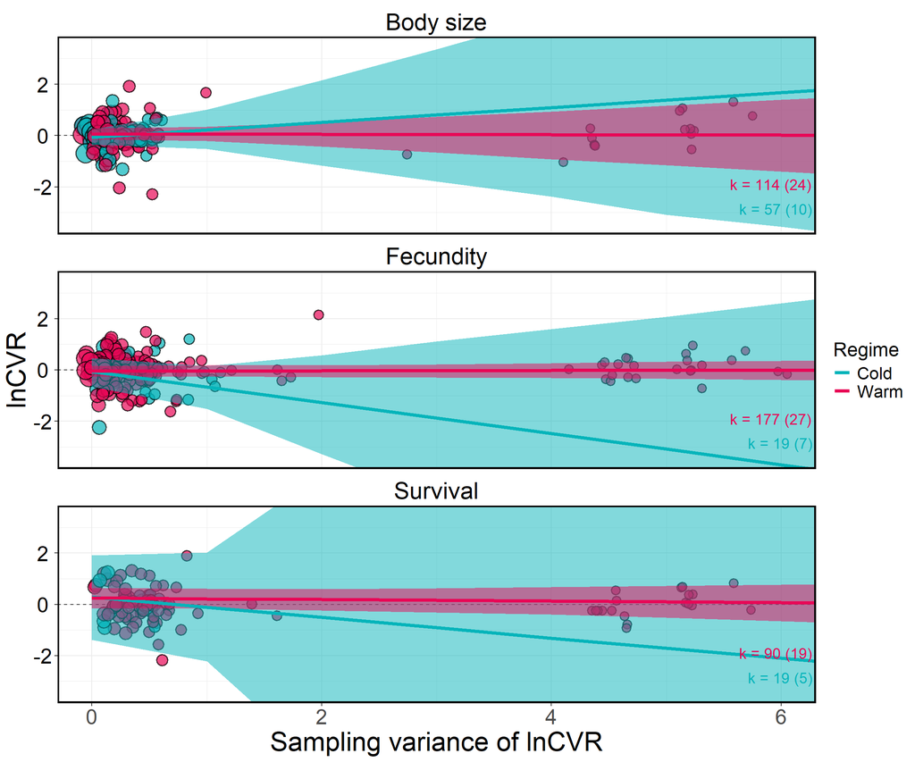

```r
# Generate predictions
emmeans_pub_bias_var <- as.data.frame(emmeans(
  lnCVR_model_pub_bias_var,
  specs = ~ var_lnCVR | trait_type * warm_cold,
  at = list(var_lnCVR = seq(0, max(data$var_lnCVR), by = 1),
            assay_temp_diff = 0))
  ) # Conditional effects on assay_temp_diff = 0

emmeans_pub_bias_var$trait_type <- factor(emmeans_pub_bias_var$trait_type,
                          levels = c("body_size", "fecundity", "survival"),
                          labels = c("Body size", "Fecundity", "Survival"))

emmeans_pub_bias_var$warm_cold <- factor(emmeans_pub_bias_var$warm_cold,
                          levels = c("cold", "warm"),
                          labels = c("Cold", "Warm"))

# Plot
ggplot() +
    geom_hline(yintercept = 0, # Horizontal line
               linetype = 2,
               colour = "black",
               alpha = 0.75) +
    geom_point(data = data,  # Effect sizes, scaled by precision
                  aes(x = var_lnCVR,
                      y = lnCVR,
                      size = 1/sqrt(var_lnCVR),
                      fill = warm_cold),
                  shape = 21,
                  alpha = 0.7,
                  stroke = 1,
                  position = position_jitter(width = 0.1)) +
     geom_ribbon(data = emmeans_pub_bias_var, # Shaded area for credible intervals
                 aes(x = var_lnCVR,
                     ymin = lower.HPD,
                     ymax = upper.HPD,
                     fill = warm_cold,
                     group = warm_cold),
                 alpha = .5) +
     geom_line(data = emmeans_pub_bias_var, # Predicted regression line
               aes(y = emmean,
                   x = var_lnCVR,
                   color = warm_cold,
                   group = warm_cold),
               size = 1.5) +
     geom_text(data = sample_sizes,
              aes(x = Inf,
                  y = ifelse(warm_cold == "Warm", -1.9, -2.85),  # Sample sizes
                  label = paste0("k = ", estimates, " (", studies, ")"),
                  color = warm_cold),
              hjust = 1.05, size = 5, show.legend = FALSE) +
  facet_wrap(~ trait_type, ncol = 1) +  # Different panels for each trait
  scale_fill_manual(values = c("#06B4BA", "#E80756"))+
  scale_color_manual(values = c("#06B4BA", "#E80756"))+
  labs(x = "Sampling variance of lnCVR", y = "lnCVR", col = "Regime") +
  theme_bw() +
  scale_size_continuous(range = c(2, 8))+
  theme(text = element_text(size = 25, color = "black"),
          legend.title = ggplot2::element_text(size = 18),
          legend.text = ggplot2::element_text(size = 16),
          axis.text.y = ggplot2::element_text(size = 20,
                colour = "black", hjust = 0.5),
          axis.text.x = ggplot2::element_text(size = 20),
        panel.border = element_rect(color = "black", size = 1.5),
        strip.background = element_blank(),
        strip.text = element_text(color = "black", size = 22)) +
    guides(fill = "none", size = "none") +
    coord_cartesian(ylim = c(-3.5, 3.5), xlim = c(0, 6))
```

```r
ggsave(file = "fig/lnCVR_pub_bias_var.png", width = 12, height = 7, dpi = 500)
```

### **Publication year**

#### *Model specification*

```r
# Model specification
formula <- bf(lnCVR ~ 0 + trait_type:warm_cold +
                         trait_type:warm_cold:assay_temp_diff +
                         trait_type:warm_cold:scale(pub_year) + # Separate effects by trait type
                (trait_type-1|ref) + # Correlation between traits among studies
                (1|species) + # Species-level random effect
                (1|gr(phylogeny, cov = phylo_matrix)) + # Phylogenetic relatedness
                (1|experiment_ID) + # Experiment-level random effect
                (1|obs) + # Observation-level random effect
                fcor(VCV_lnCVR)) # Variance covariance matix of correlated sampling variances

# Define priors
prior = c(
  prior(constant(1), class = "sigma")
) # Because the residual variance-covariance structure is specified in fcor, there is no need to estimate sigma so it is left as a constant

# Fit model
lnCVR_model_pub_bias_year <- brm(formula,
                                            family = gaussian(),
                                            data = data,
                                            data2 = list(phylo_matrix = phylo_matrix,
                                                         VCV_lnCVR = VCV_lnCVR),
                                            prior = prior,
                                            control = list(adapt_delta = 0.99, max_treedepth = 15),
                                            iter = 4000,
                                            warmup = 2000,
                                            chains = 4,
                                            cores = 4,
                                            seed = 123)
# Save model
saveRDS(lnCVR_model_pub_bias_year, file = "RData/lnCVR_model_pub_bias_year.rds")
```

#### *Model output*

```r
# Load model
lnCVR_model_pub_bias_year <- readRDS("RData/lnCVR_model_pub_bias_year.rds")

# Display model output
summary(lnCVR_model_pub_bias_year)
```

```
##  Family: gaussian
##   Links: mu = identity; sigma = identity
## Formula: lnCVR ~ 0 + trait_type:warm_cold + trait_type:warm_cold:assay_temp_diff + trait_type:warm_cold:scale(pub_year) + (trait_type - 1 | ref) + (1 | species) + (1 | gr(phylogeny, cov = phylo_matrix)) + (1 | experiment_ID) + (1 | obs) + fcor(VCV_lnCVR)
##    Data: data (Number of observations: 476)
##   Draws: 4 chains, each with iter = 4000; warmup = 2000; thin = 1;
##          total post-warmup draws = 8000
##
## Multilevel Hyperparameters:
## ~experiment_ID (Number of levels: 88)
##               Estimate Est.Error l-95% CI u-95% CI Rhat Bulk_ESS Tail_ESS
## sd(Intercept)     0.10      0.06     0.01     0.21 1.01     1181     2260
##
## ~obs (Number of levels: 476)
##               Estimate Est.Error l-95% CI u-95% CI Rhat Bulk_ESS Tail_ESS
## sd(Intercept)     0.40      0.04     0.32     0.48 1.00     2052     4112
##
## ~phylogeny (Number of levels: 25)
##               Estimate Est.Error l-95% CI u-95% CI Rhat Bulk_ESS Tail_ESS
## sd(Intercept)     0.10      0.08     0.00     0.29 1.00     2668     3221
##
## ~ref (Number of levels: 44)
##                                              Estimate Est.Error l-95% CI
## sd(trait_typebody_size)                          0.07      0.05     0.00
## sd(trait_typefecundity)                          0.10      0.08     0.00
## sd(trait_typesurvival)                           0.45      0.17     0.11
## cor(trait_typebody_size,trait_typefecundity)     0.02      0.50    -0.87
## cor(trait_typebody_size,trait_typesurvival)     -0.02      0.50    -0.89
## cor(trait_typefecundity,trait_typesurvival)     -0.04      0.47    -0.87
##                                              u-95% CI Rhat Bulk_ESS Tail_ESS
## sd(trait_typebody_size)                          0.20 1.00     3678     4215
## sd(trait_typefecundity)                          0.30 1.00     1983     3752
## sd(trait_typesurvival)                           0.79 1.00     2046     1896
## cor(trait_typebody_size,trait_typefecundity)     0.88 1.00     3875     5140
## cor(trait_typebody_size,trait_typesurvival)      0.87 1.00     1267     2796
## cor(trait_typefecundity,trait_typesurvival)      0.83 1.00     1635     4130
##
## ~species (Number of levels: 25)
##               Estimate Est.Error l-95% CI u-95% CI Rhat Bulk_ESS Tail_ESS
## sd(Intercept)     0.07      0.05     0.00     0.20 1.00     3106     4276
##
```

[output cut: 51 more lines]

```
## trait_typesurvival:warm_coldwarm:assay_temp_diff      5578
## trait_typebody_size:warm_coldcold:scalepub_year       4846
## trait_typefecundity:warm_coldcold:scalepub_year       4912
## trait_typesurvival:warm_coldcold:scalepub_year        5491
## trait_typebody_size:warm_coldwarm:scalepub_year       4728
## trait_typefecundity:warm_coldwarm:scalepub_year       5889
## trait_typesurvival:warm_coldwarm:scalepub_year        5242
##
## Further Distributional Parameters:
##       Estimate Est.Error l-95% CI u-95% CI Rhat Bulk_ESS Tail_ESS
## sigma     1.00      0.00     1.00     1.00   NA       NA       NA
##
## Draws were sampled using sampling(NUTS). For each parameter, Bulk_ESS
## and Tail_ESS are effective sample size measures, and Rhat is the potential
## scale reduction factor on split chains (at convergence, Rhat = 1).
```

```r
# R2
r2(lnCVR_model_pub_bias_year)
```

```
## # Bayesian R2 with Compatibility Interval
##
##   Conditional R2: 0.302 (95% CI [0.236, 0.368])
##      Marginal R2: 0.082 (95% CI [0.039, 0.137])
```

```r
# Cleaned model output
as.data.frame(fixef(lnCVR_model_pub_bias_year, summary = TRUE)) %>%
  # Rename categorical variables for cleaner display
  rownames_to_column(var = "Parameter") %>%
  mutate(
    # Simplify `trait_type` and `warm_cold` interactions
    Parameter = gsub("trait_type([a-z_]+):warm_cold(cold|warm)", "\\1(\\2)", Parameter),
    # Adjust for assay_temp_diff
    Parameter = gsub("trait_type([a-z_]+)\\((cold|warm)\\):assay_temp_diff", "\\1(\\2): assay_temp_diff", Parameter),
    # Remove "scale" from pub_year
    Parameter = gsub("scalepub_year", "pub_year", Parameter)
  ) %>%
  # Round numbers to 3 decimal points
  mutate(across(c(Estimate, Q2.5, Q97.5), ~ round(., 3))) %>%
  select(Parameter, Estimate, `Lower CI` = Q2.5, `Upper CI` = Q97.5) %>%
  kable() %>%
  kable_styling(full_width = FALSE, position = "center", fixed_thead = TRUE) %>%
  column_spec(1, bold = TRUE, border_right = TRUE) %>%
  row_spec(0, background = "white", color = "black", bold = TRUE) %>%
  kable_styling(fixed_thead = TRUE)
```

| Parameter | Estimate | Lower CI | Upper CI |
| --- | --- | --- | --- |
| body_size(cold) | -0.060 | -0.308 | 0.212 |
| fecundity(cold) | -0.337 | -0.781 | 0.121 |
| survival(cold) | 0.158 | -0.621 | 0.935 |
| body_size(warm) | 0.058 | -0.151 | 0.280 |
| fecundity(warm) | -0.044 | -0.265 | 0.182 |
| survival(warm) | 0.306 | -0.052 | 0.672 |
| body_size(cold):assay_temp_diff | 0.001 | -0.043 | 0.044 |
| fecundity(cold):assay_temp_diff | -0.125 | -0.209 | -0.039 |
| survival(cold):assay_temp_diff | 0.030 | -0.049 | 0.108 |
| body_size(warm):assay_temp_diff | 0.002 | -0.030 | 0.037 |
| fecundity(warm):assay_temp_diff | 0.018 | -0.013 | 0.049 |
| survival(warm):assay_temp_diff | -0.026 | -0.074 | 0.021 |
| body_size(cold):pub_year | -0.083 | -0.242 | 0.073 |
| fecundity(cold):pub_year | -0.116 | -0.420 | 0.195 |
| survival(cold):pub_year | -0.015 | -0.536 | 0.508 |
| body_size(warm):pub_year | 0.038 | -0.119 | 0.193 |
| fecundity(warm):pub_year | -0.037 | -0.233 | 0.162 |
| survival(warm):pub_year | -0.315 | -0.629 | 0.013 |

#### *Data visualisation*

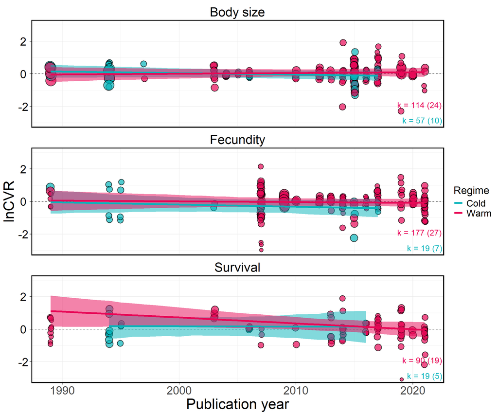

```r
# Generate predictions
emmeans_pub_bias_year <- as.data.frame(emmeans(
  lnCVR_model_pub_bias_year,
  specs = ~ pub_year | trait_type * warm_cold,
  at = list(pub_year = seq(min(data$pub_year), max(data$pub_year), by = 1),
            assay_temp_diff = 0))
  ) # Conditional effects on assay_temp_diff = 0

# Calculate range of values for each category
range_df <- data %>%
  group_by(trait_type, warm_cold) %>%
  summarize(
    min_pub_year = min(pub_year),
    max_pub_year = max(pub_year)
  )

emmeans_pub_bias_year$trait_type <- factor(emmeans_pub_bias_year$trait_type,
                          levels = c("body_size", "fecundity", "survival"),
                          labels = c("Body size", "Fecundity", "Survival"))

emmeans_pub_bias_year$warm_cold <- factor(emmeans_pub_bias_year$warm_cold,
                          levels = c("cold", "warm"),
                          labels = c("Cold", "Warm"))

# Tailor predictions to the range of the data
emmeans_pub_bias_year <- emmeans_pub_bias_year %>%
  left_join(range_df, by = c("trait_type", "warm_cold")) %>%
  filter(
    pub_year >= min_pub_year,
    pub_year <= max_pub_year
  )

# Plot
ggplot() +
    geom_hline(yintercept = 0, # Horizontal line
               linetype = 2,
               colour = "black",
               alpha = 0.75) +
    geom_point(data = data,  # Effect sizes, scaled by precision
                  aes(x = pub_year,
                      y = lnCVR,
                      size = 1/sqrt(var_lnCVR),
                      fill = warm_cold),
                  shape = 21,
                  alpha = 0.7,
                  stroke = 1,
                  position = position_jitter(width = 0.05)) +
     geom_ribbon(data = emmeans_pub_bias_year, # Shaded area for credible intervals
                 aes(x = pub_year,
                     ymin = lower.HPD,
                     ymax = upper.HPD,
                     fill = warm_cold,
                     group = warm_cold),
                 alpha = .5) +
     geom_line(data = emmeans_pub_bias_year, # Predicted regression line
               aes(y = emmean,
                   x = pub_year,
                   color = warm_cold,
                   group = warm_cold),
               size = 1.5) +
     geom_text(data = sample_sizes,
              aes(x = Inf,
                  y = ifelse(warm_cold == "Warm", -1.9, -2.85),  # Sample sizes
                  label = paste0("k = ", estimates, " (", studies, ")"),
                  color = warm_cold),
              hjust = 1.05, size = 5, show.legend = FALSE) +
  facet_wrap(~ trait_type, ncol = 1) +  # Different panels for each trait
  scale_fill_manual(values = c("#06B4BA", "#E80756"))+
  scale_color_manual(values = c("#06B4BA", "#E80756"))+
  labs(x = "Publication year", y = "lnCVR", col = "Regime") +
  theme_bw() +
  scale_size_continuous(range = c(2, 8))+
  theme(text = element_text(size = 25, color = "black"),
          legend.title = ggplot2::element_text(size = 18),
          legend.text = ggplot2::element_text(size = 16),
          axis.text.y = ggplot2::element_text(size = 20,
                colour = "black", hjust = 0.5),
          axis.text.x = ggplot2::element_text(size = 20),
        panel.border = element_rect(color = "black", size = 1.5),
        strip.background = element_blank(),
        strip.text = element_text(color = "black", size = 22)) +
    guides(fill = "none", size = "none") +
    coord_cartesian(ylim = c(-3, 3))
```

```r
ggsave(file = "fig/lnCVR_pub_bias_year.png", width = 12, height = 7, dpi = 500)
```

## **Changes in trait variance (lnVR)**

### **Egger’s regression**

#### *Model specification*

```r
# Model specification
formula <- bf(lnVR ~ 0 + trait_type:warm_cold +
                         trait_type:warm_cold:assay_temp_diff +
                         trait_type:warm_cold:var_lnVR + # Separate effects by trait type
                (trait_type-1|ref) + # Correlation between traits among studies
                (1|species) + # Species-level random effect
                (1|gr(phylogeny, cov = phylo_matrix)) + # Phylogenetic relatedness
                (1|experiment_ID) + # Experiment-level random effect
                (1|obs) + # Observation-level random effect
                fcor(VCV_lnVR)) # Variance covariance matix of correlated sampling variances

# Define priors
prior = c(
  prior(constant(1), class = "sigma")
) # Because the residual variance-covariance structure is specified in fcor, there is no need to estimate sigma so it is left as a constant

# Fit model
lnVR_model_pub_bias_var <- brm(formula,
                                            family = gaussian(),
                                            data = data,
                                            data2 = list(phylo_matrix = phylo_matrix,
                                                         VCV_lnVR = VCV_lnVR),
                                            prior = prior,
                                            control = list(adapt_delta = 0.99, max_treedepth = 15),
                                            iter = 4000,
                                            warmup = 2000,
                                            chains = 4,
                                            cores = 4,
                                            seed = 123)
# Save model
saveRDS(lnVR_model_pub_bias_var, file = "RData/lnVR_model_pub_bias_var.rds")
```

#### *Model output*

```r
# Load model
lnVR_model_pub_bias_var <- readRDS("RData/lnVR_model_pub_bias_var.rds")

# Display model output
summary(lnVR_model_pub_bias_var)
```

```
##  Family: gaussian
##   Links: mu = identity; sigma = identity
## Formula: lnVR ~ 0 + trait_type:warm_cold + trait_type:warm_cold:assay_temp_diff + trait_type:warm_cold:var_lnVR + (trait_type - 1 | ref) + (1 | species) + (1 | gr(phylogeny, cov = phylo_matrix)) + (1 | experiment_ID) + (1 | obs) + fcor(VCV_lnVR)
##    Data: data (Number of observations: 476)
##   Draws: 4 chains, each with iter = 4000; warmup = 2000; thin = 1;
##          total post-warmup draws = 8000
##
## Multilevel Hyperparameters:
## ~experiment_ID (Number of levels: 88)
##               Estimate Est.Error l-95% CI u-95% CI Rhat Bulk_ESS Tail_ESS
## sd(Intercept)     0.09      0.06     0.00     0.21 1.01      737     2137
##
## ~obs (Number of levels: 476)
##               Estimate Est.Error l-95% CI u-95% CI Rhat Bulk_ESS Tail_ESS
## sd(Intercept)     0.68      0.03     0.62     0.75 1.00     2971     5048
##
## ~phylogeny (Number of levels: 25)
##               Estimate Est.Error l-95% CI u-95% CI Rhat Bulk_ESS Tail_ESS
## sd(Intercept)     0.09      0.07     0.00     0.28 1.00     2249     3881
##
## ~ref (Number of levels: 44)
##                                              Estimate Est.Error l-95% CI
## sd(trait_typebody_size)                          0.07      0.06     0.00
## sd(trait_typefecundity)                          0.08      0.06     0.00
## sd(trait_typesurvival)                           0.29      0.15     0.03
## cor(trait_typebody_size,trait_typefecundity)     0.02      0.50    -0.87
## cor(trait_typebody_size,trait_typesurvival)     -0.04      0.50    -0.89
## cor(trait_typefecundity,trait_typesurvival)     -0.04      0.49    -0.87
##                                              u-95% CI Rhat Bulk_ESS Tail_ESS
## sd(trait_typebody_size)                          0.22 1.00     1908     2981
## sd(trait_typefecundity)                          0.23 1.00     1728     3234
## sd(trait_typesurvival)                           0.60 1.00     1204     1704
## cor(trait_typebody_size,trait_typefecundity)     0.88 1.00     3597     4697
## cor(trait_typebody_size,trait_typesurvival)      0.86 1.00     1327     3062
## cor(trait_typefecundity,trait_typesurvival)      0.86 1.00     1729     3702
##
## ~species (Number of levels: 25)
##               Estimate Est.Error l-95% CI u-95% CI Rhat Bulk_ESS Tail_ESS
## sd(Intercept)     0.06      0.05     0.00     0.18 1.00     2962     4612
##
```

[output cut: 51 more lines]

```
## trait_typesurvival:warm_coldwarm:assay_temp_diff      4928
## trait_typebody_size:warm_coldcold:var_lnVR            3704
## trait_typefecundity:warm_coldcold:var_lnVR            4765
## trait_typesurvival:warm_coldcold:var_lnVR             3194
## trait_typebody_size:warm_coldwarm:var_lnVR            5165
## trait_typefecundity:warm_coldwarm:var_lnVR            6282
## trait_typesurvival:warm_coldwarm:var_lnVR             6344
##
## Further Distributional Parameters:
##       Estimate Est.Error l-95% CI u-95% CI Rhat Bulk_ESS Tail_ESS
## sigma     1.00      0.00     1.00     1.00   NA       NA       NA
##
## Draws were sampled using sampling(NUTS). For each parameter, Bulk_ESS
## and Tail_ESS are effective sample size measures, and Rhat is the potential
## scale reduction factor on split chains (at convergence, Rhat = 1).
```

```r
# R2
r2(lnVR_model_pub_bias_var)
```

```
## # Bayesian R2 with Compatibility Interval
##
##   Conditional R2: 0.533 (95% CI [0.452, 0.657])
##      Marginal R2: 0.395 (95% CI [0.151, 0.518])
```

```r
# Cleaned model output
as.data.frame(fixef(lnVR_model_pub_bias_var, summary = TRUE)) %>%
  # Rename categorical variables for cleaner display
  rownames_to_column(var = "Parameter") %>%
  mutate(
    Parameter = gsub("trait_type([a-z_]+):warm_cold(cold|warm)", "\\1(\\2)", Parameter),
    Parameter = gsub("trait_type([a-z_]+)\\(warm\\):assay_temp_diff", "\\1(warm): assay_temp_diff", Parameter)
  ) %>%
  # Round numbers to 3 decimal points
  mutate(across(c(Estimate, Q2.5, Q97.5), ~ round(., 3))) %>%
  select(Parameter, Estimate, `Lower CI` = Q2.5, `Upper CI` = Q97.5) %>%
  kable() %>%
  kable_styling(full_width = FALSE, position = "center", fixed_thead = TRUE) %>%
  column_spec(1, bold = TRUE, border_right = TRUE) %>%
  row_spec(0, background = "white", color = "black", bold = TRUE) %>%
  kable_styling(fixed_thead = TRUE)
```

| Parameter | Estimate | Lower CI | Upper CI |
| --- | --- | --- | --- |
| body_size(cold) | -0.077 | -0.506 | 0.353 |
| fecundity(cold) | -0.263 | -0.921 | 0.391 |
| survival(cold) | 0.023 | -1.224 | 1.190 |
| body_size(warm) | 0.041 | -0.206 | 0.296 |
| fecundity(warm) | -0.106 | -0.313 | 0.115 |
| survival(warm) | 0.202 | -0.099 | 0.523 |
| body_size(cold):assay_temp_diff | -0.019 | -0.076 | 0.039 |
| fecundity(cold):assay_temp_diff | -0.185 | -0.283 | -0.091 |
| survival(cold):assay_temp_diff | -0.014 | -0.103 | 0.074 |
| body_size(warm):assay_temp_diff | -0.001 | -0.043 | 0.039 |
| fecundity(warm):assay_temp_diff | 0.019 | -0.011 | 0.049 |
| survival(warm):assay_temp_diff | -0.022 | -0.070 | 0.026 |
| body_size(cold):var_lnVR | 0.395 | -1.410 | 2.278 |
| fecundity(cold):var_lnVR | -0.559 | -2.477 | 1.364 |
| survival(cold):var_lnVR | -0.249 | -5.589 | 5.301 |
| body_size(warm):var_lnVR | 0.016 | -0.365 | 0.396 |
| fecundity(warm):var_lnVR | 0.004 | -0.053 | 0.061 |
| survival(warm):var_lnVR | -0.011 | -0.126 | 0.107 |

#### *Data visualisation*

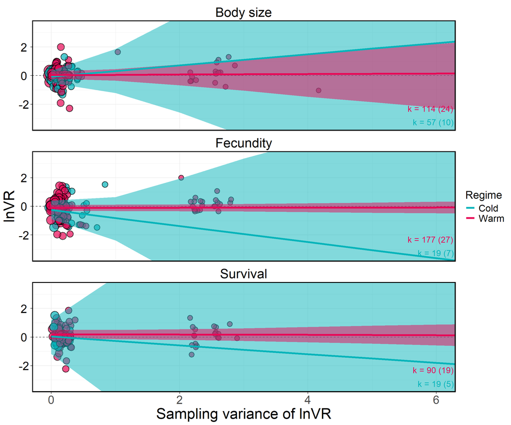

```r
# Generate predictions
emmeans_pub_bias_var <- as.data.frame(emmeans(
  lnVR_model_pub_bias_var,
  specs = ~ var_lnVR | trait_type * warm_cold,
  at = list(var_lnVR = seq(0, max(data$var_lnVR), by = 1),
            assay_temp_diff = 0))
  ) # Conditional effects on assay_temp_diff = 0

emmeans_pub_bias_var$trait_type <- factor(emmeans_pub_bias_var$trait_type,
                          levels = c("body_size", "fecundity", "survival"),
                          labels = c("Body size", "Fecundity", "Survival"))

emmeans_pub_bias_var$warm_cold <- factor(emmeans_pub_bias_var$warm_cold,
                          levels = c("cold", "warm"),
                          labels = c("Cold", "Warm"))

# Plot
ggplot() +
    geom_hline(yintercept = 0, # Horizontal line
               linetype = 2,
               colour = "black",
               alpha = 0.75) +
    geom_point(data = data,  # Effect sizes, scaled by precision
                  aes(x = var_lnVR,
                      y = lnVR,
                      size = 1/sqrt(var_lnVR),
                      fill = warm_cold),
                  shape = 21,
                  alpha = 0.7,
                  stroke = 1,
                  position = position_jitter(width = 0.05)) +
     geom_ribbon(data = emmeans_pub_bias_var, # Shaded area for credible intervals
                 aes(x = var_lnVR,
                     ymin = lower.HPD,
                     ymax = upper.HPD,
                     fill = warm_cold,
                     group = warm_cold),
                 alpha = .5) +
     geom_line(data = emmeans_pub_bias_var, # Predicted regression line
               aes(y = emmean,
                   x = var_lnVR,
                   color = warm_cold,
                   group = warm_cold),
               size = 1.5) +
     geom_text(data = sample_sizes,
              aes(x = Inf,
                  y = ifelse(warm_cold == "Warm", -2.3, -3.25),  # Sample sizes
                  label = paste0("k = ", estimates, " (", studies, ")"),
                  color = warm_cold),
              hjust = 1.05, size = 5, show.legend = FALSE) +
  facet_wrap(~ trait_type, ncol = 1) +  # Different panels for each trait
  scale_fill_manual(values = c("#06B4BA", "#E80756"))+
  scale_color_manual(values = c("#06B4BA", "#E80756"))+
  labs(x = "Sampling variance of lnVR", y = "lnVR", col = "Regime") +
  theme_bw() +
  scale_size_continuous(range = c(2, 8))+
  theme(text = element_text(size = 25, color = "black"),
          legend.title = ggplot2::element_text(size = 18),
          legend.text = ggplot2::element_text(size = 16),
          axis.text.y = ggplot2::element_text(size = 20,
                colour = "black", hjust = 0.5),
          axis.text.x = ggplot2::element_text(size = 20),
        panel.border = element_rect(color = "black", size = 1.5),
        strip.background = element_blank(),
        strip.text = element_text(color = "black", size = 22)) +
    guides(fill = "none", size = "none")+
    coord_cartesian(ylim = c(-3.5, 3.5), xlim = c(0, 6))
```

```r
ggsave(file = "fig/lnVR_pub_bias_var.png", width = 12, height = 7, dpi = 500)
```

### **Publication year**

#### *Model specification*

```r
# Model specification
formula <- bf(lnVR ~ 0 + trait_type:warm_cold +
                         trait_type:warm_cold:assay_temp_diff +
                         trait_type:warm_cold:scale(pub_year) + # Separate effects by trait type
                (trait_type-1|ref) + # Correlation between traits among studies
                (1|species) + # Species-level random effect
                (1|gr(phylogeny, cov = phylo_matrix)) + # Phylogenetic relatedness
                (1|experiment_ID) + # Experiment-level random effect
                (1|obs) + # Observation-level random effect
                fcor(VCV_lnVR)) # Variance covariance matix of correlated sampling variances

# Define priors
prior = c(
  prior(constant(1), class = "sigma")
) # Because the residual variance-covariance structure is specified in fcor, there is no need to estimate sigma so it is left as a constant

# Fit model
lnVR_model_pub_bias_year <- brm(formula,
                                            family = gaussian(),
                                            data = data,
                                            data2 = list(phylo_matrix = phylo_matrix,
                                                         VCV_lnVR = VCV_lnVR),
                                            prior = prior,
                                            control = list(adapt_delta = 0.99, max_treedepth = 15),
                                            iter = 4000,
                                            warmup = 2000,
                                            chains = 4,
                                            cores = 4,
                                            seed = 123)
# Save model
saveRDS(lnVR_model_pub_bias_year, file = "RData/lnVR_model_pub_bias_year.rds")
```

#### *Model output*

```r
# Load model
lnVR_model_pub_bias_year <- readRDS("RData/lnVR_model_pub_bias_year.rds")

# Display model output
summary(lnVR_model_pub_bias_year)
```

```
##  Family: gaussian
##   Links: mu = identity; sigma = identity
## Formula: lnVR ~ 0 + trait_type:warm_cold + trait_type:warm_cold:assay_temp_diff + trait_type:warm_cold:scale(pub_year) + (trait_type - 1 | ref) + (1 | species) + (1 | gr(phylogeny, cov = phylo_matrix)) + (1 | experiment_ID) + (1 | obs) + fcor(VCV_lnVR)
##    Data: data (Number of observations: 476)
##   Draws: 4 chains, each with iter = 4000; warmup = 2000; thin = 1;
##          total post-warmup draws = 8000
##
## Multilevel Hyperparameters:
## ~experiment_ID (Number of levels: 88)
##               Estimate Est.Error l-95% CI u-95% CI Rhat Bulk_ESS Tail_ESS
## sd(Intercept)     0.09      0.06     0.00     0.22 1.01      864     2034
##
## ~obs (Number of levels: 476)
##               Estimate Est.Error l-95% CI u-95% CI Rhat Bulk_ESS Tail_ESS
## sd(Intercept)     0.68      0.03     0.62     0.75 1.00     3134     5430
##
## ~phylogeny (Number of levels: 25)
##               Estimate Est.Error l-95% CI u-95% CI Rhat Bulk_ESS Tail_ESS
## sd(Intercept)     0.11      0.08     0.00     0.30 1.00     2255     3663
##
## ~ref (Number of levels: 44)
##                                              Estimate Est.Error l-95% CI
## sd(trait_typebody_size)                          0.08      0.06     0.00
## sd(trait_typefecundity)                          0.09      0.07     0.00
## sd(trait_typesurvival)                           0.20      0.13     0.01
## cor(trait_typebody_size,trait_typefecundity)     0.02      0.50    -0.87
## cor(trait_typebody_size,trait_typesurvival)     -0.02      0.51    -0.88
## cor(trait_typefecundity,trait_typesurvival)     -0.00      0.49    -0.88
##                                              u-95% CI Rhat Bulk_ESS Tail_ESS
## sd(trait_typebody_size)                          0.23 1.00     2885     4406
## sd(trait_typefecundity)                          0.24 1.00     2260     3630
## sd(trait_typesurvival)                           0.50 1.00     1241     3747
## cor(trait_typebody_size,trait_typefecundity)     0.88 1.00     4014     4855
## cor(trait_typebody_size,trait_typesurvival)      0.87 1.00     2156     4340
## cor(trait_typefecundity,trait_typesurvival)      0.87 1.00     3278     4983
##
## ~species (Number of levels: 25)
##               Estimate Est.Error l-95% CI u-95% CI Rhat Bulk_ESS Tail_ESS
## sd(Intercept)     0.06      0.05     0.00     0.19 1.00     2864     4175
##
```

[output cut: 51 more lines]

```
## trait_typesurvival:warm_coldwarm:assay_temp_diff      4994
## trait_typebody_size:warm_coldcold:scalepub_year       3645
## trait_typefecundity:warm_coldcold:scalepub_year       5647
## trait_typesurvival:warm_coldcold:scalepub_year        5028
## trait_typebody_size:warm_coldwarm:scalepub_year       3903
## trait_typefecundity:warm_coldwarm:scalepub_year       4683
## trait_typesurvival:warm_coldwarm:scalepub_year        5690
##
## Further Distributional Parameters:
##       Estimate Est.Error l-95% CI u-95% CI Rhat Bulk_ESS Tail_ESS
## sigma     1.00      0.00     1.00     1.00   NA       NA       NA
##
## Draws were sampled using sampling(NUTS). For each parameter, Bulk_ESS
## and Tail_ESS are effective sample size measures, and Rhat is the potential
## scale reduction factor on split chains (at convergence, Rhat = 1).
```

```r
# R2
r2(lnVR_model_pub_bias_year)
```

```
## # Bayesian R2 with Compatibility Interval
##
##   Conditional R2: 0.608 (95% CI [0.554, 0.658])
##      Marginal R2: 0.092 (95% CI [0.048, 0.139])
```

```r
# Cleaned model output
as.data.frame(fixef(lnVR_model_pub_bias_year, summary = TRUE)) %>%
  # Rename categorical variables for cleaner display
  rownames_to_column(var = "Parameter") %>%
  mutate(
    # Simplify `trait_type` and `warm_cold` interactions
    Parameter = gsub("trait_type([a-z_]+):warm_cold(cold|warm)", "\\1(\\2)", Parameter),
    # Adjust for assay_temp_diff
    Parameter = gsub("trait_type([a-z_]+)\\((cold|warm)\\):assay_temp_diff", "\\1(\\2): assay_temp_diff", Parameter),
    # Remove "scale" from pub_year
    Parameter = gsub("scalepub_year", "pub_year", Parameter)
  ) %>%
  # Round numbers to 3 decimal points
  mutate(across(c(Estimate, Q2.5, Q97.5), ~ round(., 3))) %>%
  select(Parameter, Estimate, `Lower CI` = Q2.5, `Upper CI` = Q97.5) %>%
  kable() %>%
  kable_styling(full_width = FALSE, position = "center", fixed_thead = TRUE) %>%
  column_spec(1, bold = TRUE, border_right = TRUE) %>%
  row_spec(0, background = "white", color = "black", bold = TRUE) %>%
  kable_styling(fixed_thead = TRUE)
```

| Parameter | Estimate | Lower CI | Upper CI |
| --- | --- | --- | --- |
| body_size(cold) | -0.044 | -0.349 | 0.276 |
| fecundity(cold) | -0.259 | -0.755 | 0.241 |
| survival(cold) | 0.049 | -0.766 | 0.858 |
| body_size(warm) | 0.045 | -0.190 | 0.302 |
| fecundity(warm) | -0.123 | -0.365 | 0.119 |
| survival(warm) | 0.266 | -0.037 | 0.594 |
| body_size(cold):assay_temp_diff | -0.007 | -0.066 | 0.053 |
| fecundity(cold):assay_temp_diff | -0.203 | -0.309 | -0.101 |
| survival(cold):assay_temp_diff | -0.015 | -0.107 | 0.079 |
| body_size(warm):assay_temp_diff | -0.002 | -0.041 | 0.039 |
| fecundity(warm):assay_temp_diff | 0.020 | -0.010 | 0.050 |
| survival(warm):assay_temp_diff | -0.024 | -0.071 | 0.022 |
| body_size(cold):pub_year | -0.089 | -0.303 | 0.131 |
| fecundity(cold):pub_year | 0.207 | -0.169 | 0.583 |
| survival(cold):pub_year | 0.035 | -0.468 | 0.539 |
| body_size(warm):pub_year | 0.042 | -0.172 | 0.256 |
| fecundity(warm):pub_year | 0.050 | -0.165 | 0.266 |
| survival(warm):pub_year | -0.258 | -0.496 | -0.012 |

#### *Data visualisation*

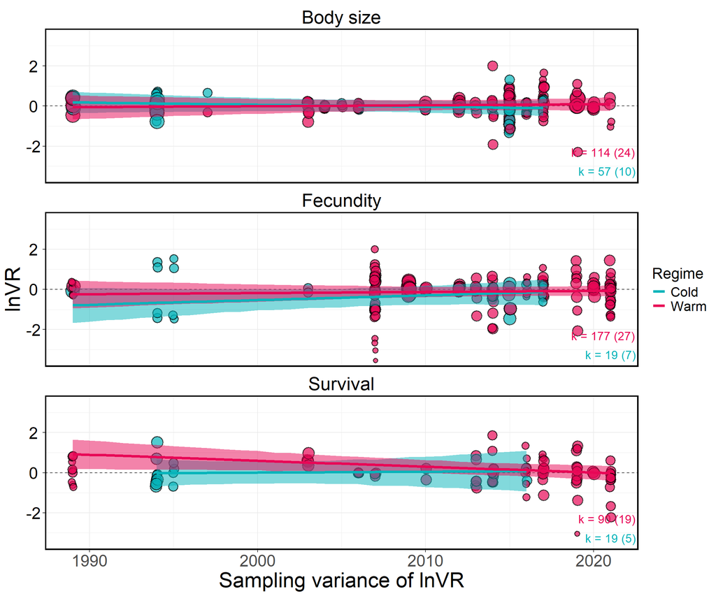

```r
# Generate predictions
emmeans_pub_bias_year <- as.data.frame(emmeans(
  lnVR_model_pub_bias_year,
  specs = ~ pub_year | trait_type * warm_cold,
  at = list(pub_year = seq(min(data$pub_year), max(data$pub_year), by = 1),
            assay_temp_diff = 0))
  ) # Conditional effects on assay_temp_diff = 0


# Calculate range of values for each category
range_df <- data %>%
  group_by(trait_type, warm_cold) %>%
  summarize(
    min_pub_year = min(pub_year),
    max_pub_year = max(pub_year)
  )

emmeans_pub_bias_year$trait_type <- factor(emmeans_pub_bias_year$trait_type,
                          levels = c("body_size", "fecundity", "survival"),
                          labels = c("Body size", "Fecundity", "Survival"))

emmeans_pub_bias_year$warm_cold <- factor(emmeans_pub_bias_year$warm_cold,
                          levels = c("cold", "warm"),
                          labels = c("Cold", "Warm"))

# Tailor predictions to the range of the data
emmeans_pub_bias_year <- emmeans_pub_bias_year %>%
  left_join(range_df, by = c("trait_type", "warm_cold")) %>%
  filter(
    pub_year >= min_pub_year,
    pub_year <= max_pub_year
  )

# Plot
ggplot() +
    geom_hline(yintercept = 0, # Horizontal line
               linetype = 2,
               colour = "black",
               alpha = 0.75) +
    geom_point(data = data,  # Effect sizes, scaled by precision
                  aes(x = pub_year,
                      y = lnVR,
                      size = 1/sqrt(var_lnVR),
                      fill = warm_cold),
                  shape = 21,
                  alpha = 0.7,
                  stroke = 1,
                  position = position_jitter(width = 0.05)) +
     geom_ribbon(data = emmeans_pub_bias_year, # Shaded area for credible intervals
                 aes(x = pub_year,
                     ymin = lower.HPD,
                     ymax = upper.HPD,
                     fill = warm_cold,
                     group = warm_cold),
                 alpha = .5) +
     geom_line(data = emmeans_pub_bias_year, # Predicted regression line
               aes(y = emmean,
                   x = pub_year,
                   color = warm_cold,
                   group = warm_cold),
               size = 1.5) +
     geom_text(data = sample_sizes,
              aes(x = Inf,
                  y = ifelse(warm_cold == "Warm", -2.3, -3.25),  # Sample sizes
                  label = paste0("k = ", estimates, " (", studies, ")"),
                  color = warm_cold),
              hjust = 1.05, size = 5, show.legend = FALSE) +
  facet_wrap(~ trait_type, ncol = 1) +  # Different panels for each trait
  scale_fill_manual(values = c("#06B4BA", "#E80756"))+
  scale_color_manual(values = c("#06B4BA", "#E80756"))+
  labs(x = "Sampling variance of lnVR", y = "lnVR", col = "Regime") +
  theme_bw() +
  scale_size_continuous(range = c(2, 8))+
  theme(text = element_text(size = 25, color = "black"),
          legend.title = ggplot2::element_text(size = 18),
          legend.text = ggplot2::element_text(size = 16),
          axis.text.y = ggplot2::element_text(size = 20,
                colour = "black", hjust = 0.5),
          axis.text.x = ggplot2::element_text(size = 20),
        panel.border = element_rect(color = "black", size = 1.5),
        strip.background = element_blank(),
        strip.text = element_text(color = "black", size = 22)) +
    guides(fill = "none", size = "none") +
    coord_cartesian(ylim = c(-3.5, 3.5))
```

```r
ggsave(file = "fig/lnVR_pub_bias_year.png", width = 12, height = 7, dpi = 500)
```

# **Sensitivity analyses**

Note that, although mentioned in our pre-registration, we did not compare estimates from peer-reviewed publications and academic theses. This is because only a single included study was a thesis.

Prepare dataset for subset analyses

```r
# Filter to only warm temperatures
data_warm <- filter(data, warm_cold == "Warm")

# Drop tips that are not in the warm dataset
tips_to_drop <- setdiff(phylo_tree$tip.label, data_warm$phylogeny)
phylo_tree_warm <- drop.tip(phylo_tree, tips_to_drop)

# Compute phylogenetic correlation matrix
phylo_matrix_warm <- vcv(phylo_tree_warm, cor = T)  # The vcv function returns a variance-covariance matrix

# Convert tibble to data frame
data_warm <- as.data.frame(data_warm)

# Calculate VCV matrix for all three responses
VCV_lnRR_warm <- vcalc(vi = var_lnRR,
                        cluster = shared_control_ID,
                        rho = 0.5,
                        obs = obs,
                        data = data_warm)

VCV_lnCVR_warm <- vcalc(vi = var_lnCVR,
                        cluster = shared_control_ID,
                        rho = 0.5,
                        obs = obs,
                        data = data_warm)

VCV_lnVR_warm <- vcalc(vi = var_lnVR,
                        cluster = shared_control_ID,
                        rho = 0.5,
                        obs = obs,
                        data = data_warm)
```

## **Changes in mean responses (lnRR)**

### **Constant vs. increasing temperatures**

#### *Model specification*

```r
# Model specification
formula <- bf(lnRR ~ 0 + trait_type:constant_increasing + trait_type:constant_increasing:assay_temp_diff + # Separate effects by trait type
                (trait_type-1|ref) + # Correlation between traits among studies
                (1|species) + # Species-level random effect
                (1|gr(phylogeny, cov = phylo_matrix_warm)) + # Phylogenetic relatedness
                (1|experiment_ID) + # Experiment-level random effect
                (1|obs) + # Observation-level random effect
                fcor(VCV_lnRR_warm)) # Variance covariance matix of correlated sampling variances

# Define priors
prior = c(
  prior(constant(1), class = "sigma")
) # Because the residual variance-covariance structure is specified in fcor, there is no need to estimate sigma so it is left as a constant

# Fit model
lnRR_model_constant_increasing <- brm(formula,
                                       family = gaussian(),
                                       data = data_warm,
                                       data2 = list(phylo_matrix_warm = phylo_matrix_warm,
                                                    VCV_lnRR_warm = VCV_lnRR_warm),
                                       prior = prior,
                                       control = list(adapt_delta = 0.99, max_treedepth = 15),
                                       iter = 4000,
                                       warmup = 2000,
                                       chains = 4,
                                       cores = 4,
                                       seed = 123)

# Save model
saveRDS(lnRR_model_constant_increasing, file = "RData/lnRR_model_constant_increasing.rds")
```

#### *Model output*

```r
# Load model
lnRR_model_constant_increasing <- readRDS("RData/lnRR_model_constant_increasing.rds")

# Display model output
summary(lnRR_model_constant_increasing)
```

```
##  Family: gaussian
##   Links: mu = identity; sigma = identity
## Formula: lnRR ~ 0 + trait_type:constant_increasing + trait_type:constant_increasing:assay_temp_diff + (trait_type - 1 | ref) + (1 | species) + (1 | gr(phylogeny, cov = phylo_matrix_warm)) + (1 | experiment_ID) + (1 | obs) + fcor(VCV_lnRR_warm)
##    Data: data_warm (Number of observations: 381)
##   Draws: 4 chains, each with iter = 4000; warmup = 2000; thin = 1;
##          total post-warmup draws = 8000
##
## Multilevel Hyperparameters:
## ~experiment_ID (Number of levels: 81)
##               Estimate Est.Error l-95% CI u-95% CI Rhat Bulk_ESS Tail_ESS
## sd(Intercept)     0.02      0.01     0.00     0.04 1.00     1181     1279
##
## ~obs (Number of levels: 381)
##               Estimate Est.Error l-95% CI u-95% CI Rhat Bulk_ESS Tail_ESS
## sd(Intercept)     0.05      0.01     0.04     0.06 1.01     1304     2710
##
## ~phylogeny (Number of levels: 23)
##               Estimate Est.Error l-95% CI u-95% CI Rhat Bulk_ESS Tail_ESS
## sd(Intercept)     0.02      0.02     0.00     0.06 1.00     2344     3808
##
## ~ref (Number of levels: 38)
##                                              Estimate Est.Error l-95% CI
## sd(trait_typebody_size)                          0.02      0.01     0.00
## sd(trait_typefecundity)                          0.22      0.04     0.15
## sd(trait_typesurvival)                           0.14      0.03     0.09
## cor(trait_typebody_size,trait_typefecundity)    -0.19      0.41    -0.88
## cor(trait_typebody_size,trait_typesurvival)      0.31      0.42    -0.66
## cor(trait_typefecundity,trait_typesurvival)     -0.34      0.47    -0.95
##                                              u-95% CI Rhat Bulk_ESS Tail_ESS
## sd(trait_typebody_size)                          0.04 1.00     1417     2639
## sd(trait_typefecundity)                          0.31 1.00     3306     4983
## sd(trait_typesurvival)                           0.22 1.00     4833     5595
## cor(trait_typebody_size,trait_typefecundity)     0.68 1.01      488      886
## cor(trait_typebody_size,trait_typesurvival)      0.93 1.00     1073     1756
## cor(trait_typefecundity,trait_typesurvival)      0.70 1.01     1070     2328
##
## ~species (Number of levels: 23)
##               Estimate Est.Error l-95% CI u-95% CI Rhat Bulk_ESS Tail_ESS
## sd(Intercept)     0.02      0.01     0.00     0.04 1.00     2742     4545
##
```

[output cut: 72 more lines]

```
## trait_typesurvival:constant_increasingincreasing                      5498
## trait_typebody_size:constant_increasingconstant:assay_temp_diff       5581
## trait_typefecundity:constant_increasingconstant:assay_temp_diff       6030
## trait_typesurvival:constant_increasingconstant:assay_temp_diff        5166
## trait_typebody_size:constant_increasingincreasing:assay_temp_diff     5335
## trait_typefecundity:constant_increasingincreasing:assay_temp_diff     6882
## trait_typesurvival:constant_increasingincreasing:assay_temp_diff      5784
##
## Further Distributional Parameters:
##       Estimate Est.Error l-95% CI u-95% CI Rhat Bulk_ESS Tail_ESS
## sigma     1.00      0.00     1.00     1.00   NA       NA       NA
##
## Draws were sampled using sampling(NUTS). For each parameter, Bulk_ESS
## and Tail_ESS are effective sample size measures, and Rhat is the potential
## scale reduction factor on split chains (at convergence, Rhat = 1).
```

```r
# R2
r2(lnRR_model_constant_increasing)
```

```
## # Bayesian R2 with Compatibility Interval
##
##   Conditional R2: 0.239 (95% CI [0.186, 0.297])
##      Marginal R2: 0.039 (95% CI [0.007, 0.095])
```

```r
# Cleaned model output
as.data.frame(fixef(lnRR_model_constant_increasing, summary = TRUE)) %>%
  # Rename categorical variables for cleaner display
  rownames_to_column(var = "Parameter") %>%
  mutate(
    # Simplify `trait_type` and `constant_increasing` interactions
    Parameter = gsub("trait_type([a-z_]+):constant_increasing(constant|increasing)", "\\1(\\2)", Parameter),
    # Adjust for assay_temp_diff
    Parameter = gsub("trait_type([a-z_]+)\\((constant|increasing)\\):assay_temp_diff", "\\1(\\2): assay_temp_diff", Parameter)
  ) %>%
  # Round numbers to 3 decimal points
  mutate(across(c(Estimate, Q2.5, Q97.5), ~ round(., 3))) %>%
  select(Parameter, Estimate, `Lower CI` = Q2.5, `Upper CI` = Q97.5) %>%
  kable() %>%
  kable_styling(full_width = FALSE, position = "center", fixed_thead = TRUE) %>%
  column_spec(1, bold = TRUE, border_right = TRUE) %>%
  row_spec(0, background = "white", color = "black", bold = TRUE) %>%
  kable_styling(fixed_thead = TRUE)
```

| Parameter | Estimate | Lower CI | Upper CI |
| --- | --- | --- | --- |
| body_size(constant) | -0.005 | -0.047 | 0.037 |
| fecundity(constant) | -0.050 | -0.160 | 0.059 |
| survival(constant) | 0.015 | -0.074 | 0.106 |
| body_size(increasing) | 0.026 | -0.057 | 0.102 |
| fecundity(increasing) | -0.042 | -0.251 | 0.170 |
| survival(increasing) | 0.003 | -0.162 | 0.168 |
| body_size(constant):assay_temp_diff | -0.001 | -0.005 | 0.002 |
| fecundity(constant):assay_temp_diff | 0.006 | -0.002 | 0.015 |
| survival(constant):assay_temp_diff | 0.005 | -0.001 | 0.012 |
| body_size(increasing):assay_temp_diff | 0.003 | -0.011 | 0.016 |
| fecundity(increasing):assay_temp_diff | -0.003 | -0.019 | 0.013 |
| survival(increasing):assay_temp_diff | -0.007 | -0.026 | 0.012 |

#### *Contrasts*

```r
# Generate predictions
emms <- emmeans(lnRR_model_constant_increasing,
                specs = ~ constant_increasing | trait_type,
                at = list(assay_temp_diff = 0))

# Generate contrasts
contrast(emms, method = "pairwise")
```

```
## trait_type = body_size:
##  contrast              estimate lower.HPD upper.HPD
##  constant - increasing -0.03191    -0.106    0.0427
##
## trait_type = fecundity:
##  contrast              estimate lower.HPD upper.HPD
##  constant - increasing -0.00587    -0.236    0.2302
##
## trait_type = survival:
##  contrast              estimate lower.HPD upper.HPD
##  constant - increasing  0.01147    -0.160    0.2028
##
## Point estimate displayed: median
## HPD interval probability: 0.95
```

#### *Data visualisation*

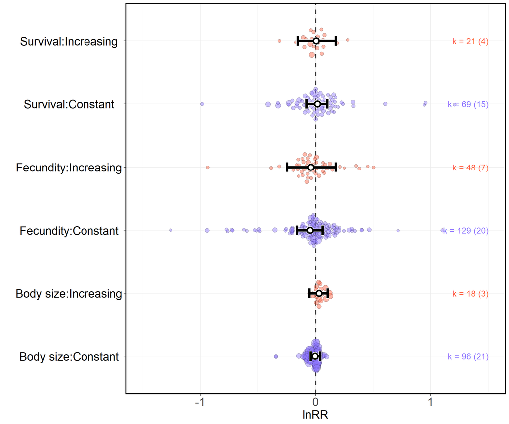

```r
# Generate predictions
emmeans_constant_increasing <- as.data.frame(emmeans(lnRR_model_constant_increasing,
                                                     specs = ~ constant_increasing | trait_type,
                                                     at = list(assay_temp_diff = 0)))

emmeans_constant_increasing$trait_type <- factor(emmeans_constant_increasing$trait_type,
                          levels = c("body_size", "fecundity", "survival"),
                          labels = c("Body size", "Fecundity", "Survival"))

emmeans_constant_increasing$constant_increasing <- factor(emmeans_constant_increasing$constant_increasing,
                          levels = c("constant", "increasing"),
                          labels = c("Constant", "Increasing"))

data_warm$constant_increasing <- factor(data_warm$constant_increasing,
                          levels = c("constant", "increasing"),
                          labels = c("Constant", "Increasing"))


# Calculate sample sizes and study counts
sample_sizes_warm <- data_warm %>%
  group_by(trait_type, constant_increasing) %>%
  summarise(
    estimates = n(),
    studies = n_distinct(ref)
  )

# Plot
ggplot() +
    geom_hline(yintercept = 0, # Horizontal line
               linetype = 2,
               colour = "black",
               alpha = 0.75,
               lwd=1) +
    geom_quasirandom(data = data_warm,     # Plot effect sizes, scaled by precision
                     aes(x = trait_type:constant_increasing,
                         y = lnRR,
                         fill = trait_type:constant_increasing,
                         size = 1/sqrt(var_lnRR)),
                     color = "black",
                     shape = 21,
                     width = 0.25,
                     alpha = 0.45) +
    geom_errorbar(data = emmeans_constant_increasing,  # Plot the point estimates in white for background
                  aes(x = trait_type:constant_increasing,
                      ymin = lower.HPD,
                      ymax = upper.HPD),
                  color="white",
                  size = 2.5,
                  width = 0.17) +
    geom_point(data = emmeans_constant_increasing,  # Plot the credible intervals in white for background
               aes(x = trait_type:constant_increasing,
                   y = emmean),
               shape = 21,
               size = 4,
               stroke = 2,
               color="white",
               fill = "white") +
    geom_errorbar(data = emmeans_constant_increasing, # Plot the point estimates
                  aes(x = trait_type:constant_increasing,
                      ymin = lower.HPD,
                      ymax = upper.HPD),
                  color="black",
                  size = 2,
                  width = 0.15) +
    geom_point(data = emmeans_constant_increasing, # Plot the credible intervals
               aes(x = trait_type:constant_increasing,
                   y = emmean),
               shape = 21,
               size = 3.5,
               stroke = 2,
               color="black",
               fill = "white") +
    geom_text(data = sample_sizes_warm,  # Sample size annotations
              aes(x = trait_type:constant_increasing,
                  y = 1.5,
                  label = paste0("k = ", estimates, " (", studies, ")"),
                  color = constant_increasing),
              hjust = 1, size = 5, show.legend = FALSE) +
    theme_bw() +     # Customize the plot
    labs(y = "lnRR", x = "") +
    scale_size_continuous(range = c(2, 8))+
    scale_fill_manual(values = c("#8E77FF", "#FF6040", "#8E77FF", "#FF6040", "#8E77FF", "#FF6040"))+
    scale_color_manual(values = c("Constant" = "#8E77FF", "Increasing" = "#FF6040")) +  # Text colour
    theme(text = element_text(size = 20, color = "black"),
          legend.title = ggplot2::element_text(size = 16),
          legend.text = ggplot2::element_text(size = 14),
          axis.text.y = ggplot2::element_text(size = 20,
                colour = "black", hjust = 0.5),
          axis.text.x = ggplot2::element_text(size = 20),
          panel.border = element_rect(color = "black", size = 1.5)) +
    guides(fill = "none", size = "none")+
    coord_flip() +
    ylim(-1.5, 1.5)
```

```r
ggsave(file = "fig/lnRR_constant_increasing.png", width = 12, height = 7, dpi = 500)
```

### **Leave-one-out analysis**

#### *Model specification*

```r
# Get a list of study IDs for the LOO
study_ids <- unique(data$ref)
num_studies <- length(study_ids)

# Initialize a list to store the results
loo_results <- vector("list", num_studies)
names(loo_results) <- study_ids

# Set up parallel processing (16 models at a time)
plan(multisession, workers = 16)

# Model specification
formula <- bf(lnRR ~ trait_type -1 + # Separate effects by trait type
                (trait_type-1|ref) + # Correlation between traits among studies
                (1|species) + # Species-level random effect
                (1|gr(phylogeny, cov = phylo_matrix)) + # Phylogenetic relatedness
                (1|experiment_ID) + # Experiment-level random effect
                (1|obs) + # Observation-level random effect
                fcor(VCV_lnRR)) # Variance covariance matix of correlated sampling variances

# Define priors
prior = c(
  prior(constant(1), class = "sigma")
) # Because the residual variance-covariance structure is specified in fcor, there is no need to estimate sigma so it is left as a constant


# Function to fit the model after iteratively removing one study
leave_one_out <- function(study_id) {
  # Subset the data
  data_subset <- subset(data, ref != study_id)

  # Recalculate VCV matrix
  VCV_lnRR_subset <- vcalc(
    vi = var_lnRR,
    cluster = shared_control_ID,
    rho = 0.5,
    obs = obs,
    data = data_subset
  )

  # Fit the model
  model_subset <- brm(
    formula,
    family = gaussian(),
    data = data_subset,
    data2 = list(
      phylo_matrix = phylo_matrix,
      VCV_lnRR = VCV_lnRR_subset
    ),
    prior = prior,
    control = list(adapt_delta = 0.99, max_treedepth = 15),
    iter = 2000, # Reduce to 2000 iterations to reduce computational demands
    warmup = 1000,
    chains = 2, # Only two chains to reduce computational demands
    cores = 1,   # Set cores to 1 inside the function
    seed = 123
  )

  # Extract the fixed effects
  fixed_effects <- fixef(model_subset)

  # Return the fixed effects
  return(list(study_id = study_id, fixed_effects = fixed_effects))
}

# Run the function in parallel over the studies
loo_results <- future_lapply(study_ids, leave_one_out)

# Save results
saveRDS(loo_results, file = "RData/lnRR_LOO_results.rds")
```

#### *Model summary*

```r
# Load the list of all model outputs
loo_lnRR <- readRDS(file = "RData/lnRR_LOO_results.rds")

# Extract data on fixed effects from each model

loo_results_lnRR <- do.call(rbind, lapply(loo_lnRR, function(x) {
  # Extract study_id and fixed_effects data
  study_id <- x$study_id
  fixed_effects <- x$fixed_effects

  # Convert row names (trait_type) to a column, remove prefix, and add study_id
  fixed_effects <- data.frame(trait_type = sub("trait_type", "", rownames(fixed_effects)), fixed_effects)
  fixed_effects$study_id <- study_id

  # Remove row names
  rownames(fixed_effects) <- NULL

  return(fixed_effects)
}))

loo_results_lnRR$trait_type <- factor(loo_results_lnRR$trait_type,
                          levels = c("body_size", "fecundity", "survival"),
                          labels = c("Body size", "Fecundity", "Survival"))

# Summarise the data
loo_results_lnRR %>%
  group_by(trait_type) %>%
  summarise(Estimate = mean(Estimate),
            SE = mean(Est.Error),
            lower_CI = mean(Q2.5),
            upper_CI = mean(Q97.5)) # Mean across all models
```

```
## # A tibble: 3 × 5
##   trait_type Estimate     SE lower_CI upper_CI
##   <fct>         <dbl>  <dbl>    <dbl>    <dbl>
## 1 Body size  -0.00139 0.0206  -0.0436   0.0396
## 2 Fecundity  -0.0220  0.0438  -0.109    0.0635
## 3 Survival    0.0220  0.0337  -0.0435   0.0906
```

#### *Data visualisation*

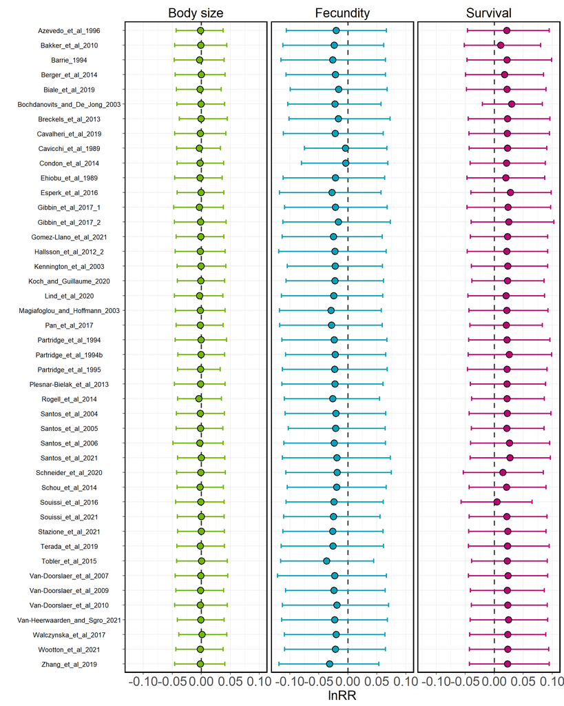

```r
# Plot
ggplot() +
    geom_hline(yintercept = 0, # Horizontal line
               linetype = 2,
               colour = "black",
               alpha = 0.75,
               lwd=1) +
    geom_errorbar(data = loo_results_lnRR,  # Plot the credible intervals in white for background
               aes(x = study_id,
                   y = Estimate,
                   ymin = Q2.5,
                   ymax = Q97.5,
                   color = trait_type),
               shape = 21,
               size = 1,
               width = 0.3) +
    geom_point(data = loo_results_lnRR,
               aes(x = study_id,
                   y = Estimate,
                   fill = trait_type),
               shape = 21,
               size = 4,
               stroke = 1,
               color="black") +
    theme_bw() +     # Customize the plot
    labs(y = "lnRR", x = "") +
    scale_fill_manual(values = c("#73B706", "#06A2BA", "#B90674"))+
    scale_color_manual(values = c("#73B706", "#06A2BA", "#B90674")) +
    theme(text = element_text(size = 20, color = "black"),
          legend.title = ggplot2::element_text(size = 16),
          legend.text = ggplot2::element_text(size = 14),
          axis.text.y = ggplot2::element_text(size = 10,
                colour = "black", hjust = 0.5),
          axis.text.x = ggplot2::element_text(size = 20),
          panel.border = element_rect(color = "black", size = 1.5),
          strip.background = element_blank(),
        strip.text = element_text(color = "black", size = 20)) +
    guides(fill = "none", color = "none")+
    coord_flip()+
    xlim(-0.15, 0.15) +
    facet_wrap(~trait_type, ncol = 3)+
    scale_x_discrete(limits = rev(levels(as.factor(loo_results_lnRR$study_id)))) # Alphabetical order
```

```r
ggsave(file = "fig/lnRR_LOO.png", width = 12, height = 12, dpi = 500)
```

### **Unusual study designs**

#### *Model specification*

```r
# Discard observations flagged because the number of generations of selection was unclear, as this would only affect the results of meta-regressions
data <- mutate(data, minor_concerns2 = ifelse(minor_concerns == "gen_selection approximate" |
                                               minor_concerns == "gen_selection underestimated",
                     NA, minor_concerns))

# Filter to data without sources of procedural  concerns.
data_concerns <- filter(data, is.na(major_concerns)==T & is.na(minor_concerns2)==T)

# Drop tips that are not in the warm dataset
tips_to_drop <- setdiff(phylo_tree$tip.label, data_concerns$phylogeny)
phylo_tree_concerns <- drop.tip(phylo_tree, tips_to_drop)

# Compute phylogenetic correlation matrix
phylo_matrix_concerns <- vcv(phylo_tree_concerns, cor = T)  # The vcv function returns a variance-covariance matrix

# Convert tibble to data frame
data_concerns <- as.data.frame(data_concerns)

# Calculate VCV matrix
VCV_lnRR_concerns <- vcalc(vi = var_lnRR,
                       cluster = shared_control_ID,
                       rho = 0.5,
                       obs = obs,
                       data = data_concerns)

# Model specification
formula <- bf(lnRR ~ 0 + trait_type:warm_cold + trait_type:warm_cold:assay_temp_diff + # Separate effects by trait type
                (trait_type-1|ref) + # Correlation between traits among studies
                (1|species) + # Species-level random effect
                (1|gr(phylogeny, cov = phylo_matrix_concerns)) + # Phylogenetic relatedness
                (1|experiment_ID) + # Experiment-level random effect
                (1|obs) + # Observation-level random effect
                fcor(VCV_lnRR_concerns)) # Variance covariance matix of correlated sampling variances

# Define priors
prior = c(
  prior(constant(1), class = "sigma")
) # Because the residual variance-covariance structure is specified in fcor, there is no need to estimate sigma so it is left as a constant

# Fit model
lnRR_model_concerns <- brm(formula,
                                      family = gaussian(),
                                      data = data_concerns,
                                      data2 = list(phylo_matrix_concerns = phylo_matrix_concerns,
                                                   VCV_lnRR_concerns = VCV_lnRR_concerns),
                                      prior = prior,
                                      control = list(adapt_delta = 0.99, max_treedepth = 15),
                                      iter = 4000,
                                      warmup = 2000,
                                      chains = 4,
                                      cores = 4,
                                      seed = 123)
# Save model
saveRDS(lnRR_model_concerns, file = "RData/lnRR_model_concerns.rds")
```

#### *Model summary*

```r
# Load model
lnRR_model_concerns <- readRDS("RData/lnRR_model_concerns.rds")

# Display model output
summary(lnRR_model_concerns)
```

```
##  Family: gaussian
##   Links: mu = identity; sigma = identity
## Formula: lnRR ~ 0 + trait_type:warm_cold + trait_type:warm_cold:assay_temp_diff + (trait_type - 1 | ref) + (1 | species) + (1 | gr(phylogeny, cov = phylo_matrix_concerns)) + (1 | experiment_ID) + (1 | obs) + fcor(VCV_lnRR_concerns)
##    Data: data_concerns (Number of observations: 321)
##   Draws: 4 chains, each with iter = 4000; warmup = 2000; thin = 1;
##          total post-warmup draws = 8000
##
## Multilevel Hyperparameters:
## ~experiment_ID (Number of levels: 72)
##               Estimate Est.Error l-95% CI u-95% CI Rhat Bulk_ESS Tail_ESS
## sd(Intercept)     0.02      0.01     0.00     0.04 1.00     1174     1392
##
## ~obs (Number of levels: 321)
##               Estimate Est.Error l-95% CI u-95% CI Rhat Bulk_ESS Tail_ESS
## sd(Intercept)     0.04      0.00     0.03     0.04 1.00     2135     3894
##
## ~phylogeny (Number of levels: 22)
##               Estimate Est.Error l-95% CI u-95% CI Rhat Bulk_ESS Tail_ESS
## sd(Intercept)     0.03      0.02     0.00     0.07 1.00     2060     2542
##
## ~ref (Number of levels: 33)
##                                              Estimate Est.Error l-95% CI
## sd(trait_typebody_size)                          0.02      0.01     0.00
## sd(trait_typefecundity)                          0.25      0.06     0.16
## sd(trait_typesurvival)                           0.12      0.03     0.07
## cor(trait_typebody_size,trait_typefecundity)    -0.05      0.45    -0.88
## cor(trait_typebody_size,trait_typesurvival)      0.16      0.44    -0.77
## cor(trait_typefecundity,trait_typesurvival)     -0.10      0.59    -0.94
##                                              u-95% CI Rhat Bulk_ESS Tail_ESS
## sd(trait_typebody_size)                          0.04 1.00     1269     2073
## sd(trait_typefecundity)                          0.38 1.00     2829     4738
## sd(trait_typesurvival)                           0.20 1.00     4415     5524
## cor(trait_typebody_size,trait_typefecundity)     0.81 1.01      494      944
## cor(trait_typebody_size,trait_typesurvival)      0.90 1.00     1371     2002
## cor(trait_typefecundity,trait_typesurvival)      0.89 1.00      984     3114
##
## ~species (Number of levels: 22)
##               Estimate Est.Error l-95% CI u-95% CI Rhat Bulk_ESS Tail_ESS
## sd(Intercept)     0.02      0.01     0.00     0.05 1.00     2688     3110
##
```

[output cut: 33 more lines]

```
## trait_typesurvival:warm_coldwarm                      3671
## trait_typebody_size:warm_coldcold:assay_temp_diff     4414
## trait_typefecundity:warm_coldcold:assay_temp_diff     6434
## trait_typesurvival:warm_coldcold:assay_temp_diff      6100
## trait_typebody_size:warm_coldwarm:assay_temp_diff     5621
## trait_typefecundity:warm_coldwarm:assay_temp_diff     5238
## trait_typesurvival:warm_coldwarm:assay_temp_diff      5722
##
## Further Distributional Parameters:
##       Estimate Est.Error l-95% CI u-95% CI Rhat Bulk_ESS Tail_ESS
## sigma     1.00      0.00     1.00     1.00   NA       NA       NA
##
## Draws were sampled using sampling(NUTS). For each parameter, Bulk_ESS
## and Tail_ESS are effective sample size measures, and Rhat is the potential
## scale reduction factor on split chains (at convergence, Rhat = 1).
```

```r
# R2
r2(lnRR_model_concerns)
```

```
## # Bayesian R2 with Compatibility Interval
##
##   Conditional R2: 0.290 (95% CI [0.228, 0.354])
##      Marginal R2: 0.079 (95% CI [0.044, 0.136])
```

```r
# Cleaned model output
as.data.frame(fixef(lnRR_model_concerns, summary = TRUE)) %>%
  # Rename categorical variables for cleaner display
  rownames_to_column(var = "Parameter") %>%
  mutate(
    Parameter = gsub("trait_type([a-z_]+):warm_cold(cold|warm)", "\\1(\\2)", Parameter),
    Parameter = gsub("trait_type([a-z_]+)\\(warm\\):assay_temp_diff", "\\1(warm): assay_temp_diff", Parameter)
  ) %>%
  # Round numbers to 3 decimal points
  mutate(across(c(Estimate, Q2.5, Q97.5), ~ round(., 3))) %>%
  select(Parameter, Estimate, `Lower CI` = Q2.5, `Upper CI` = Q97.5) %>%
  kable() %>%
  kable_styling(full_width = FALSE, position = "center", fixed_thead = TRUE) %>%
  column_spec(1, bold = TRUE, border_right = TRUE) %>%
  row_spec(0, background = "white", color = "black", bold = TRUE) %>%
  kable_styling(fixed_thead = TRUE)
```

| Parameter | Estimate | Lower CI | Upper CI |
| --- | --- | --- | --- |
| body_size(cold) | 0.038 | -0.012 | 0.086 |
| fecundity(cold) | -0.406 | -0.619 | -0.206 |
| survival(cold) | 0.063 | -0.076 | 0.203 |
| body_size(warm) | -0.008 | -0.055 | 0.038 |
| fecundity(warm) | -0.062 | -0.188 | 0.066 |
| survival(warm) | -0.009 | -0.089 | 0.074 |
| body_size(cold):assay_temp_diff | 0.000 | -0.006 | 0.007 |
| fecundity(cold):assay_temp_diff | -0.077 | -0.087 | -0.067 |
| survival(cold):assay_temp_diff | -0.010 | -0.038 | 0.018 |
| body_size(warm):assay_temp_diff | 0.000 | -0.004 | 0.004 |
| fecundity(warm):assay_temp_diff | 0.001 | -0.007 | 0.010 |
| survival(warm):assay_temp_diff | 0.002 | -0.004 | 0.007 |

#### *Data visualisation*

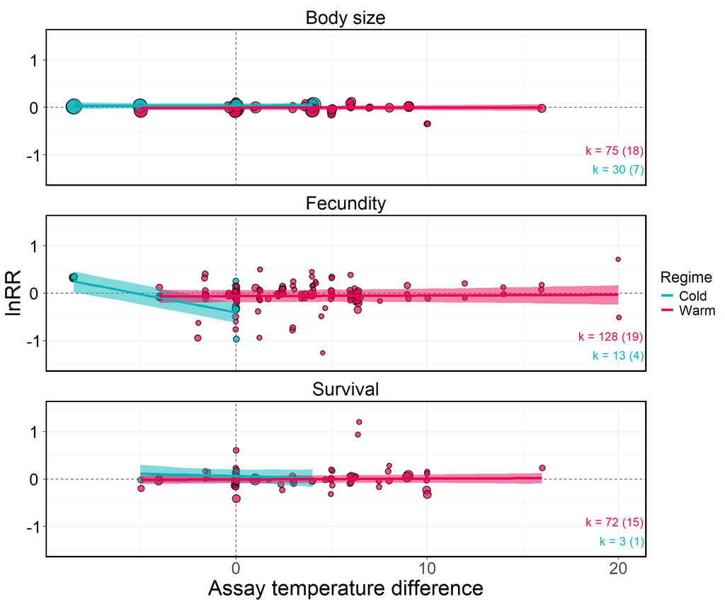

```r
# Discard observations flagged because the number of generations of selection was unclear, as this would only affect the results of meta-regressions
data <- mutate(data, minor_concerns2 = ifelse(minor_concerns == "gen_selection approximate" |
                                               minor_concerns == "gen_selection underestimated",
                     NA, minor_concerns))

# Filter to data without sources of procedural  concerns.
data_concerns <- filter(data, is.na(major_concerns)==T & is.na(minor_concerns2)==T)

# Calculate sample sizes and study counts
sample_sizes_concerns <- data_concerns %>%
  group_by(trait_type, warm_cold) %>%
  summarise(
    estimates = n(),
    studies = n_distinct(ref)
  )

# Generate predictions
emmeans_concerns <- as.data.frame(emmeans(
  lnRR_model_concerns,
  specs = ~ assay_temp_diff | trait_type * warm_cold,
  at = list(assay_temp_diff = seq(min(data_concerns$assay_temp_diff), max(data_concerns$assay_temp_diff), by = 0.5)))
  )

# Calculate range of values for each category
range_df_concerns <- data_concerns %>%
  group_by(trait_type, warm_cold) %>%
  summarize(
    min_assay_temp_diff = min(assay_temp_diff),
    max_assay_temp_diff = max(assay_temp_diff)
  )

emmeans_concerns$trait_type <- factor(emmeans_concerns$trait_type,
                          levels = c("body_size", "fecundity", "survival"),
                          labels = c("Body size", "Fecundity", "Survival"))

emmeans_concerns$warm_cold <- factor(emmeans_concerns$warm_cold,
                          levels = c("cold", "warm"),
                          labels = c("Cold", "Warm"))

# Tailor predictions to the range of the data
emmeans_concerns <- emmeans_concerns %>%
  left_join(range_df_concerns, by = c("trait_type", "warm_cold")) %>%
  filter(
    assay_temp_diff >= min_assay_temp_diff,
    assay_temp_diff <= max_assay_temp_diff
  )

# Plot
ggplot() +
    geom_hline(yintercept = 0, # Horizontal line
               linetype = 2,
               colour = "black",
               alpha = 0.75) +
    geom_vline(xintercept = 0, # Vertical line
               linetype = 2,
               colour = "black",
               alpha = 0.75) +
    geom_point(data = data_concerns, # Effect sizes, scaled by precision
                  aes(x = assay_temp_diff,
                      y = lnRR,
                      size = 1/sqrt(var_lnRR),
                      fill = warm_cold),
                  shape = 21,
                  alpha = 0.7,
                  stroke = 1,
                  position = position_jitter(width = 0.05)) +
     geom_ribbon(data = emmeans_concerns, # Shaded area for credible intervals
                 aes(x = assay_temp_diff,
                     ymin = lower.HPD,
                     ymax = upper.HPD,
                     fill = warm_cold,
                     group = warm_cold),
                 alpha = .5) +
     geom_line(data = emmeans_concerns,  # Predicted regression line
               aes(y = emmean,
                   x = assay_temp_diff,
                   color = warm_cold,
                   group = warm_cold),
               size = 1.5) +
    geom_text(data = sample_sizes_concerns,
              aes(x = Inf,
                  y = ifelse(warm_cold == "Warm", -0.9, -1.3),  # Sample sizes
                  label = paste0("k = ", estimates, " (", studies, ")"),
                  color = warm_cold),
              hjust = 1.05, size = 5, show.legend = FALSE) +

  facet_wrap(~ trait_type, ncol = 1) + # Different panels for each trait
  scale_fill_manual(values = c("#06B4BA", "#E80756"))+
  scale_color_manual(values = c("#06B4BA", "#E80756"))+
  labs(x = "Assay temperature difference", y = "lnRR",
       col = "Regime") +
  theme_bw() +
  scale_size_continuous(range = c(2, 8))+
  theme(text = element_text(size = 25, color = "black"),
          legend.title = ggplot2::element_text(size = 18),
          legend.text = ggplot2::element_text(size = 16),
          axis.text.y = ggplot2::element_text(size = 20,
                colour = "black", hjust = 0.5),
          axis.text.x = ggplot2::element_text(size = 20),
        panel.border = element_rect(color = "black", size = 1.5),
        strip.background = element_blank(),
        strip.text = element_text(color = "black", size = 22)) +
    guides(fill = "none", size = "none")+
    coord_cartesian(ylim = c(-1.5, 1.5))
```

```r
ggsave(file = "fig/lnRR_concerns.png", width = 12, height = 7, dpi = 500)
```

## **Changes in relative trait variance (lnCVR)**

### **Constant vs. increasing temperatures**

#### *Model specification*

```r
# Model specification
formula <- bf(lnCVR ~ 0 + trait_type:constant_increasing + trait_type:constant_increasing:assay_temp_diff + # Separate effects by trait type
                (trait_type-1|ref) + # Correlation between traits among studies
                (1|species) + # Species-level random effect
                (1|gr(phylogeny, cov = phylo_matrix_warm)) + # Phylogenetic relatedness
                (1|experiment_ID) + # Experiment-level random effect
                (1|obs) + # Observation-level random effect
                fcor(VCV_lnCVR_warm)) # Variance covariance matix of correlated sampling variances

# Define priors
prior = c(
  prior(constant(1), class = "sigma")
) # Because the residual variance-covariance structure is specified in fcor, there is no need to estimate sigma so it is left as a constant

# Fit model
lnCVR_model_constant_increasing <- brm(formula,
                                       family = gaussian(),
                                       data = data_warm,
                                       data2 = list(phylo_matrix_warm = phylo_matrix_warm,
                                                    VCV_lnCVR_warm = VCV_lnCVR_warm),
                                       prior = prior,
                                       control = list(adapt_delta = 0.99, max_treedepth = 15),
                                       iter = 4000,
                                       warmup = 2000,
                                       chains = 4,
                                       cores = 4,
                                       seed = 123)

# Save model
saveRDS(lnCVR_model_constant_increasing, file = "RData/lnCVR_model_constant_increasing.rds")
```

#### *Model output*

```r
# Load model
lnCVR_model_constant_increasing <- readRDS("RData/lnCVR_model_constant_increasing.rds")

# Display model output
summary(lnCVR_model_constant_increasing)
```

```
##  Family: gaussian
##   Links: mu = identity; sigma = identity
## Formula: lnCVR ~ 0 + trait_type:constant_increasing + trait_type:constant_increasing:assay_temp_diff + (trait_type - 1 | ref) + (1 | species) + (1 | gr(phylogeny, cov = phylo_matrix_warm)) + (1 | experiment_ID) + (1 | obs) + fcor(VCV_lnCVR_warm)
##    Data: data_warm (Number of observations: 381)
##   Draws: 4 chains, each with iter = 4000; warmup = 2000; thin = 1;
##          total post-warmup draws = 8000
##
## Multilevel Hyperparameters:
## ~experiment_ID (Number of levels: 81)
##               Estimate Est.Error l-95% CI u-95% CI Rhat Bulk_ESS Tail_ESS
## sd(Intercept)     0.09      0.06     0.00     0.21 1.00     1159     2902
##
## ~obs (Number of levels: 381)
##               Estimate Est.Error l-95% CI u-95% CI Rhat Bulk_ESS Tail_ESS
## sd(Intercept)     0.44      0.05     0.34     0.54 1.00     2072     3235
##
## ~phylogeny (Number of levels: 23)
##               Estimate Est.Error l-95% CI u-95% CI Rhat Bulk_ESS Tail_ESS
## sd(Intercept)     0.11      0.09     0.00     0.32 1.00     2872     4272
##
## ~ref (Number of levels: 38)
##                                              Estimate Est.Error l-95% CI
## sd(trait_typebody_size)                          0.08      0.06     0.00
## sd(trait_typefecundity)                          0.10      0.08     0.00
## sd(trait_typesurvival)                           0.62      0.19     0.31
## cor(trait_typebody_size,trait_typefecundity)     0.00      0.50    -0.87
## cor(trait_typebody_size,trait_typesurvival)     -0.03      0.49    -0.87
## cor(trait_typefecundity,trait_typesurvival)     -0.03      0.47    -0.86
##                                              u-95% CI Rhat Bulk_ESS Tail_ESS
## sd(trait_typebody_size)                          0.23 1.00     3107     3994
## sd(trait_typefecundity)                          0.31 1.00     2207     3874
## sd(trait_typesurvival)                           1.05 1.00     3297     3717
## cor(trait_typebody_size,trait_typefecundity)     0.88 1.00     4662     5294
## cor(trait_typebody_size,trait_typesurvival)      0.87 1.00     1110     2641
## cor(trait_typefecundity,trait_typesurvival)      0.84 1.00     1504     2867
##
## ~species (Number of levels: 23)
##               Estimate Est.Error l-95% CI u-95% CI Rhat Bulk_ESS Tail_ESS
## sd(Intercept)     0.08      0.06     0.00     0.23 1.00     3018     4221
##
```

[output cut: 72 more lines]

```
## trait_typesurvival:constant_increasingincreasing                      5028
## trait_typebody_size:constant_increasingconstant:assay_temp_diff       5921
## trait_typefecundity:constant_increasingconstant:assay_temp_diff       5730
## trait_typesurvival:constant_increasingconstant:assay_temp_diff        6127
## trait_typebody_size:constant_increasingincreasing:assay_temp_diff     5816
## trait_typefecundity:constant_increasingincreasing:assay_temp_diff     5587
## trait_typesurvival:constant_increasingincreasing:assay_temp_diff      6404
##
## Further Distributional Parameters:
##       Estimate Est.Error l-95% CI u-95% CI Rhat Bulk_ESS Tail_ESS
## sigma     1.00      0.00     1.00     1.00   NA       NA       NA
##
## Draws were sampled using sampling(NUTS). For each parameter, Bulk_ESS
## and Tail_ESS are effective sample size measures, and Rhat is the potential
## scale reduction factor on split chains (at convergence, Rhat = 1).
```

```r
# R2
r2(lnCVR_model_constant_increasing)
```

```
## # Bayesian R2 with Compatibility Interval
##
##   Conditional R2: 0.304 (95% CI [0.228, 0.379])
##      Marginal R2: 0.046 (95% CI [0.014, 0.094])
```

```r
# Cleaned model output
as.data.frame(fixef(lnCVR_model_constant_increasing, summary = TRUE)) %>%
  # Rename categorical variables for cleaner display
  rownames_to_column(var = "Parameter") %>%
  mutate(
    # Simplify `trait_type` and `constant_increasing` interactions
    Parameter = gsub("trait_type([a-z_]+):constant_increasing(constant|increasing)", "\\1(\\2)", Parameter),
    # Adjust for assay_temp_diff
    Parameter = gsub("trait_type([a-z_]+)\\((constant|increasing)\\):assay_temp_diff", "\\1(\\2): assay_temp_diff", Parameter)
  ) %>%
  # Round numbers to 3 decimal points
  mutate(across(c(Estimate, Q2.5, Q97.5), ~ round(., 3))) %>%
  select(Parameter, Estimate, `Lower CI` = Q2.5, `Upper CI` = Q97.5) %>%
  kable() %>%
  kable_styling(full_width = FALSE, position = "center", fixed_thead = TRUE) %>%
  column_spec(1, bold = TRUE, border_right = TRUE) %>%
  row_spec(0, background = "white", color = "black", bold = TRUE) %>%
  kable_styling(fixed_thead = TRUE)
```

| Parameter | Estimate | Lower CI | Upper CI |
| --- | --- | --- | --- |
| body_size(constant) | 0.061 | -0.175 | 0.330 |
| fecundity(constant) | -0.063 | -0.314 | 0.184 |
| survival(constant) | 0.280 | -0.178 | 0.757 |
| body_size(increasing) | -0.076 | -0.632 | 0.490 |
| fecundity(increasing) | 0.019 | -0.342 | 0.415 |
| survival(increasing) | 0.185 | -0.712 | 1.122 |
| body_size(constant):assay_temp_diff | -0.004 | -0.041 | 0.033 |
| fecundity(constant):assay_temp_diff | 0.020 | -0.016 | 0.056 |
| survival(constant):assay_temp_diff | -0.028 | -0.082 | 0.027 |
| body_size(increasing):assay_temp_diff | 0.066 | -0.052 | 0.181 |
| fecundity(increasing):assay_temp_diff | 0.007 | -0.068 | 0.083 |
| survival(increasing):assay_temp_diff | -0.031 | -0.157 | 0.094 |

#### *Contrasts*

```r
# Generate predictions
emms <- emmeans(lnCVR_model_constant_increasing,
                specs = ~ constant_increasing | trait_type,
                at = list(assay_temp_diff = 0))

# Generate contrasts
contrast(emms, method = "pairwise")
```

```
## trait_type = body_size:
##  contrast              estimate lower.HPD upper.HPD
##  constant - increasing   0.1337    -0.400     0.717
##
## trait_type = fecundity:
##  contrast              estimate lower.HPD upper.HPD
##  constant - increasing  -0.0765    -0.483     0.326
##
## trait_type = survival:
##  contrast              estimate lower.HPD upper.HPD
##  constant - increasing   0.1066    -0.870     1.087
##
## Point estimate displayed: median
## HPD interval probability: 0.95
```

#### *Data visualisation*

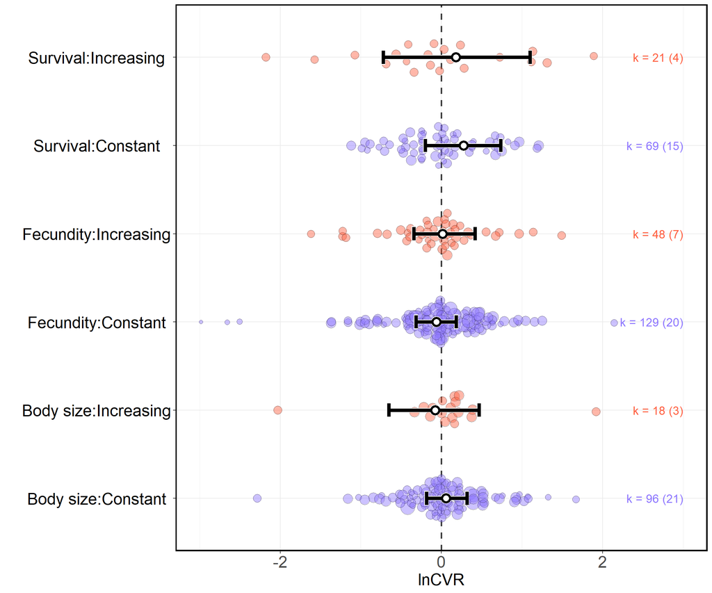

```r
# Generate predictions
emmeans_constant_increasing <- as.data.frame(emmeans(lnCVR_model_constant_increasing,
                                                     specs = ~ constant_increasing | trait_type,
                                                     at = list(assay_temp_diff = 0)))

emmeans_constant_increasing$trait_type <- factor(emmeans_constant_increasing$trait_type,
                          levels = c("body_size", "fecundity", "survival"),
                          labels = c("Body size", "Fecundity", "Survival"))

emmeans_constant_increasing$constant_increasing <- factor(emmeans_constant_increasing$constant_increasing,
                          levels = c("constant", "increasing"),
                          labels = c("Constant", "Increasing"))

# Plot
ggplot() +
    geom_hline(yintercept = 0, # Horizontal line
               linetype = 2,
               colour = "black",
               alpha = 0.75,
               lwd=1) +
    geom_quasirandom(data = data_warm,     # Plot effect sizes, scaled by precision
                     aes(x = trait_type:constant_increasing,
                         y = lnCVR,
                         fill = trait_type:constant_increasing,
                         size = 1/sqrt(var_lnCVR)),
                     color = "black",
                     shape = 21,
                     width = 0.25,
                     alpha = 0.45) +
    geom_errorbar(data = emmeans_constant_increasing,  # Plot the point estimates in white for background
                  aes(x = trait_type:constant_increasing,
                      ymin = lower.HPD,
                      ymax = upper.HPD),
                  color="white",
                  size = 2.5,
                  width = 0.17) +
    geom_point(data = emmeans_constant_increasing,  # Plot the credible intervals in white for background
               aes(x = trait_type:constant_increasing,
                   y = emmean),
               shape = 21,
               size = 4,
               stroke = 2,
               color="white",
               fill = "white") +
    geom_errorbar(data = emmeans_constant_increasing, # Plot the point estimates
                  aes(x = trait_type:constant_increasing,
                      ymin = lower.HPD,
                      ymax = upper.HPD),
                  color="black",
                  size = 2,
                  width = 0.15) +
    geom_point(data = emmeans_constant_increasing, # Plot the credible intervals
               aes(x = trait_type:constant_increasing,
                   y = emmean),
               shape = 21,
               size = 3.5,
               stroke = 2,
               color="black",
               fill = "white") +
    geom_text(data = sample_sizes_warm,  # Sample size annotations
              aes(x = trait_type:constant_increasing,
                  y = 3,
                  label = paste0("k = ", estimates, " (", studies, ")"),
                  color = constant_increasing),
              hjust = 1, size = 5, show.legend = FALSE) +
    theme_bw() +     # Customize the plot
    labs(y = "lnCVR", x = "") +
    scale_size_continuous(range = c(2, 8))+
    scale_fill_manual(values = c("#8E77FF", "#FF6040", "#8E77FF", "#FF6040", "#8E77FF", "#FF6040"))+
    scale_color_manual(values = c("Constant" = "#8E77FF", "Increasing" = "#FF6040")) +  # Text colour
    theme(text = element_text(size = 20, color = "black"),
          legend.title = ggplot2::element_text(size = 16),
          legend.text = ggplot2::element_text(size = 14),
          axis.text.y = ggplot2::element_text(size = 20,
                colour = "black", hjust = 0.5),
          axis.text.x = ggplot2::element_text(size = 20),
          panel.border = element_rect(color = "black", size = 1.5)) +
    guides(fill = "none", size = "none")+
    coord_flip() +
    ylim(-3, 3)
```

```r
ggsave(file = "fig/lnCVR_constant_increasing.png", width = 12, height = 7, dpi = 500)
```

### **Leave-one-out analysis**

#### *Model specification*

```r
# Get a list of study IDs for the LOO
study_ids <- unique(data$ref)
num_studies <- length(study_ids)

# Initialize a list to store the results
loo_results <- vector("list", num_studies)
names(loo_results) <- study_ids

# Set up parallel processing (16 models at a time)
plan(multisession, workers = 16)

# Model specification
formula <- bf(lnCVR ~ trait_type -1 + # Separate effects by trait type
                (trait_type-1|ref) + # Correlation between traits among studies
                (1|species) + # Species-level random effect
                (1|gr(phylogeny, cov = phylo_matrix)) + # Phylogenetic relatedness
                (1|experiment_ID) + # Experiment-level random effect
                (1|obs) + # Observation-level random effect
                fcor(VCV_lnCVR)) # Variance covariance matix of correlated sampling variances

# Define priors
prior = c(
  prior(constant(1), class = "sigma")
) # Because the residual variance-covariance structure is specified in fcor, there is no need to estimate sigma so it is left as a constant


# Function to fit the model after iteratively removing one study
leave_one_out <- function(study_id) {
  # Subset the data
  data_subset <- subset(data, ref != study_id)

  # Recalculate VCV matrix
  VCV_lnCVR_subset <- vcalc(
    vi = var_lnCVR,
    cluster = shared_control_ID,
    rho = 0.5,
    obs = obs,
    data = data_subset
  )

  # Fit the model
  model_subset <- brm(
    formula,
    family = gaussian(),
    data = data_subset,
    data2 = list(
      phylo_matrix = phylo_matrix,
      VCV_lnCVR = VCV_lnCVR_subset
    ),
    prior = prior,
    control = list(adapt_delta = 0.99, max_treedepth = 15),
    iter = 2000, # Reduce to 2000 iterations to reduce computational demands
    warmup = 1000,
    chains = 2, # Only two chains to reduce computational demands
    cores = 1,   # Set cores to 1 inside the function
    seed = 123
  )

  # Extract the fixed effects
  fixed_effects <- fixef(model_subset)

  # Return the fixed effects
  return(list(study_id = study_id, fixed_effects = fixed_effects))
}

# Run the function in parallel over the studies
loo_results <- future_lapply(study_ids, leave_one_out)

# Save results
saveRDS(loo_results, file = "RData/lnCVR_LOO_results.rds")
```

#### *Model summary*

```r
# Load the list of all model outputs
loo_lnCVR <- readRDS(file = "RData/lnCVR_LOO_results.rds")

# Extract data on fixed effects from each model

loo_results_lnCVR <- do.call(rbind, lapply(loo_lnCVR, function(x) {
  # Extract study_id and fixed_effects data
  study_id <- x$study_id
  fixed_effects <- x$fixed_effects

  # Convert row names (trait_type) to a column, remove prefix, and add study_id
  fixed_effects <- data.frame(trait_type = sub("trait_type", "", rownames(fixed_effects)), fixed_effects)
  fixed_effects$study_id <- study_id

  # Remove row names
  rownames(fixed_effects) <- NULL

  return(fixed_effects)
}))

loo_results_lnCVR$trait_type <- factor(loo_results_lnCVR$trait_type,
                          levels = c("body_size", "fecundity", "survival"),
                          labels = c("Body size", "Fecundity", "Survival"))

# Summarise the data
loo_results_lnCVR %>%
  group_by(trait_type) %>%
  summarise(Estimate = mean(Estimate),
            SE = mean(Est.Error),
            lower_CI = mean(Q2.5),
            upper_CI = mean(Q97.5)) # Mean across all models
```

```
## # A tibble: 3 × 5
##   trait_type Estimate     SE lower_CI upper_CI
##   <fct>         <dbl>  <dbl>    <dbl>    <dbl>
## 1 Body size    0.0443 0.0985   -0.139    0.254
## 2 Fecundity   -0.0115 0.101    -0.204    0.197
## 3 Survival     0.129  0.159    -0.181    0.448
```

#### *Data visualisation*

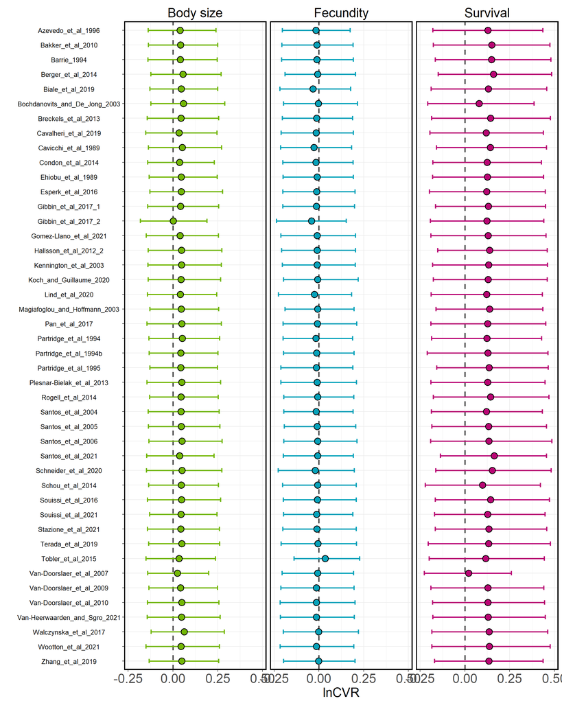

```r
# Plot
ggplot() +
    geom_hline(yintercept = 0, # Horizontal line
               linetype = 2,
               colour = "black",
               alpha = 0.75,
               lwd=1) +
    geom_errorbar(data = loo_results_lnCVR,  # Plot the credible intervals in white for background
               aes(x = study_id,
                   y = Estimate,
                   ymin = Q2.5,
                   ymax = Q97.5,
                   color = trait_type),
               shape = 21,
               size = 1,
               width = 0.3) +
    geom_point(data = loo_results_lnCVR,
               aes(x = study_id,
                   y = Estimate,
                   fill = trait_type),
               shape = 21,
               size = 4,
               stroke = 1,
               color="black") +
    theme_bw() +     # Customize the plot
    labs(y = "lnCVR", x = "") +
    scale_fill_manual(values = c("#73B706", "#06A2BA", "#B90674"))+
    scale_color_manual(values = c("#73B706", "#06A2BA", "#B90674")) +
    theme(text = element_text(size = 20, color = "black"),
          legend.title = ggplot2::element_text(size = 16),
          legend.text = ggplot2::element_text(size = 14),
          axis.text.y = ggplot2::element_text(size = 10,
                colour = "black", hjust = 0.5),
          axis.text.x = ggplot2::element_text(size = 20),
          panel.border = element_rect(color = "black", size = 1.5),
          strip.background = element_blank(),
        strip.text = element_text(color = "black", size = 20)) +
    guides(fill = "none", color = "none")+
    coord_flip()+
    xlim(-0.4, 0.4)+
    facet_wrap(~trait_type, ncol = 3)+
   scale_x_discrete(limits = rev(levels(as.factor(loo_results_lnCVR$study_id)))) # Alphabetical order
```

```r
ggsave(file = "fig/lnCVR_LOO.png", width = 12, height = 12, dpi = 500)
```

### **Unusual study designs**

#### *Model specification*

```r
# Discard observations flagged because the number of generations of selection was unclear, as this would only affect the results of meta-regressions
data <- mutate(data, minor_concerns2 = ifelse(minor_concerns == "gen_selection approximate" |
                                               minor_concerns == "gen_selection underestimated",
                     NA, minor_concerns))

# Filter to data without sources of procedural  concerns.
data_concerns <- filter(data, is.na(major_concerns)==T & is.na(minor_concerns2)==T)

# Drop tips that are not in the warm dataset
tips_to_drop <- setdiff(phylo_tree$tip.label, data_concerns$phylogeny)
phylo_tree_concerns <- drop.tip(phylo_tree, tips_to_drop)

# Compute phylogenetic correlation matrix
phylo_matrix_concerns <- vcv(phylo_tree_concerns, cor = T)  # The vcv function returns a variance-covariance matrix

# Convert tibble to data frame
data_concerns <- as.data.frame(data_concerns)

# Calculate VCV matrix
VCV_lnCVR_concerns <- vcalc(vi = var_lnCVR,
                       cluster = shared_control_ID,
                       rho = 0.5,
                       obs = obs,
                       data = data_concerns)

# Model specification
formula <- bf(lnCVR ~ 0 + trait_type:warm_cold + trait_type:warm_cold:assay_temp_diff + # Separate effects by trait type
                (trait_type-1|ref) + # Correlation between traits among studies
                (1|species) + # Species-level random effect
                (1|gr(phylogeny, cov = phylo_matrix_concerns)) + # Phylogenetic relatedness
                (1|experiment_ID) + # Experiment-level random effect
                (1|obs) + # Observation-level random effect
                fcor(VCV_lnCVR_concerns)) # Variance covariance matix of correlated sampling variances

# Define priors
prior = c(
  prior(constant(1), class = "sigma")
) # Because the residual variance-covariance structure is specified in fcor, there is no need to estimate sigma so it is left as a constant

# Fit model
lnCVR_model_concerns <- brm(formula,
                                      family = gaussian(),
                                      data = data_concerns,
                                      data2 = list(phylo_matrix_concerns = phylo_matrix_concerns,
                                                   VCV_lnCVR_concerns = VCV_lnCVR_concerns),
                                      prior = prior,
                                      control = list(adapt_delta = 0.99, max_treedepth = 15),
                                      iter = 4000,
                                      warmup = 2000,
                                      chains = 4,
                                      cores = 4,
                                      seed = 123)
# Save model
saveRDS(lnCVR_model_concerns, file = "RData/lnCVR_model_concerns.rds")
```

#### *Model summary*

```r
# Load model
lnCVR_model_concerns <- readRDS("RData/lnCVR_model_concerns.rds")

# Display model output
summary(lnCVR_model_concerns)
```

```
##  Family: gaussian
##   Links: mu = identity; sigma = identity
## Formula: lnCVR ~ 0 + trait_type:warm_cold + trait_type:warm_cold:assay_temp_diff + (trait_type - 1 | ref) + (1 | species) + (1 | gr(phylogeny, cov = phylo_matrix_concerns)) + (1 | experiment_ID) + (1 | obs) + fcor(VCV_lnCVR_concerns)
##    Data: data_concerns (Number of observations: 321)
##   Draws: 4 chains, each with iter = 4000; warmup = 2000; thin = 1;
##          total post-warmup draws = 8000
##
## Multilevel Hyperparameters:
## ~experiment_ID (Number of levels: 72)
##               Estimate Est.Error l-95% CI u-95% CI Rhat Bulk_ESS Tail_ESS
## sd(Intercept)     0.13      0.07     0.01     0.26 1.00     1347     2050
##
## ~obs (Number of levels: 321)
##               Estimate Est.Error l-95% CI u-95% CI Rhat Bulk_ESS Tail_ESS
## sd(Intercept)     0.41      0.06     0.29     0.53 1.00     1660     3010
##
## ~phylogeny (Number of levels: 22)
##               Estimate Est.Error l-95% CI u-95% CI Rhat Bulk_ESS Tail_ESS
## sd(Intercept)     0.10      0.09     0.00     0.32 1.00     3339     4425
##
## ~ref (Number of levels: 33)
##                                              Estimate Est.Error l-95% CI
## sd(trait_typebody_size)                          0.08      0.07     0.00
## sd(trait_typefecundity)                          0.11      0.09     0.00
## sd(trait_typesurvival)                           0.68      0.21     0.33
## cor(trait_typebody_size,trait_typefecundity)     0.04      0.49    -0.86
## cor(trait_typebody_size,trait_typesurvival)     -0.06      0.50    -0.90
## cor(trait_typefecundity,trait_typesurvival)     -0.07      0.47    -0.87
##                                              u-95% CI Rhat Bulk_ESS Tail_ESS
## sd(trait_typebody_size)                          0.24 1.00     3827     4841
## sd(trait_typefecundity)                          0.33 1.00     2626     3833
## sd(trait_typesurvival)                           1.17 1.00     3113     4527
## cor(trait_typebody_size,trait_typefecundity)     0.88 1.00     5647     5687
## cor(trait_typebody_size,trait_typesurvival)      0.87 1.00     1193     2127
## cor(trait_typefecundity,trait_typesurvival)      0.83 1.00     1742     3608
##
## ~species (Number of levels: 22)
##               Estimate Est.Error l-95% CI u-95% CI Rhat Bulk_ESS Tail_ESS
## sd(Intercept)     0.08      0.06     0.00     0.25 1.00     3552     4619
##
```

[output cut: 33 more lines]

```
## trait_typesurvival:warm_coldwarm                      4079
## trait_typebody_size:warm_coldcold:assay_temp_diff     6553
## trait_typefecundity:warm_coldcold:assay_temp_diff     6530
## trait_typesurvival:warm_coldcold:assay_temp_diff      6783
## trait_typebody_size:warm_coldwarm:assay_temp_diff     6069
## trait_typefecundity:warm_coldwarm:assay_temp_diff     6018
## trait_typesurvival:warm_coldwarm:assay_temp_diff      6417
##
## Further Distributional Parameters:
##       Estimate Est.Error l-95% CI u-95% CI Rhat Bulk_ESS Tail_ESS
## sigma     1.00      0.00     1.00     1.00   NA       NA       NA
##
## Draws were sampled using sampling(NUTS). For each parameter, Bulk_ESS
## and Tail_ESS are effective sample size measures, and Rhat is the potential
## scale reduction factor on split chains (at convergence, Rhat = 1).
```

```r
# R2
r2(lnCVR_model_concerns)
```

```
## # Bayesian R2 with Compatibility Interval
##
##   Conditional R2: 0.297 (95% CI [0.208, 0.384])
##      Marginal R2: 0.047 (95% CI [0.015, 0.088])
```

```r
# Cleaned model output
as.data.frame(fixef(lnCVR_model_concerns, summary = TRUE)) %>%
  # Rename categorical variables for cleaner display
  rownames_to_column(var = "Parameter") %>%
  mutate(
    Parameter = gsub("trait_type([a-z_]+):warm_cold(cold|warm)", "\\1(\\2)", Parameter),
    Parameter = gsub("trait_type([a-z_]+)\\(warm\\):assay_temp_diff", "\\1(warm): assay_temp_diff", Parameter)
  ) %>%
  # Round numbers to 3 decimal points
  mutate(across(c(Estimate, Q2.5, Q97.5), ~ round(., 3))) %>%
  select(Parameter, Estimate, `Lower CI` = Q2.5, `Upper CI` = Q97.5) %>%
  kable() %>%
  kable_styling(full_width = FALSE, position = "center", fixed_thead = TRUE) %>%
  column_spec(1, bold = TRUE, border_right = TRUE) %>%
  row_spec(0, background = "white", color = "black", bold = TRUE) %>%
  kable_styling(fixed_thead = TRUE)
```

| Parameter | Estimate | Lower CI | Upper CI |
| --- | --- | --- | --- |
| body_size(cold) | 0.068 | -0.251 | 0.393 |
| fecundity(cold) | -0.214 | -0.831 | 0.384 |
| survival(cold) | 0.155 | -0.897 | 1.244 |
| body_size(warm) | 0.002 | -0.250 | 0.263 |
| fecundity(warm) | -0.031 | -0.266 | 0.220 |
| survival(warm) | 0.260 | -0.198 | 0.749 |
| body_size(cold):assay_temp_diff | -0.042 | -0.152 | 0.071 |
| fecundity(cold):assay_temp_diff | -0.135 | -0.256 | -0.016 |
| survival(cold):assay_temp_diff | -0.004 | -0.243 | 0.236 |
| body_size(warm):assay_temp_diff | 0.020 | -0.024 | 0.065 |
| fecundity(warm):assay_temp_diff | 0.020 | -0.015 | 0.056 |
| survival(warm):assay_temp_diff | -0.029 | -0.083 | 0.026 |

#### *Data visualisation*

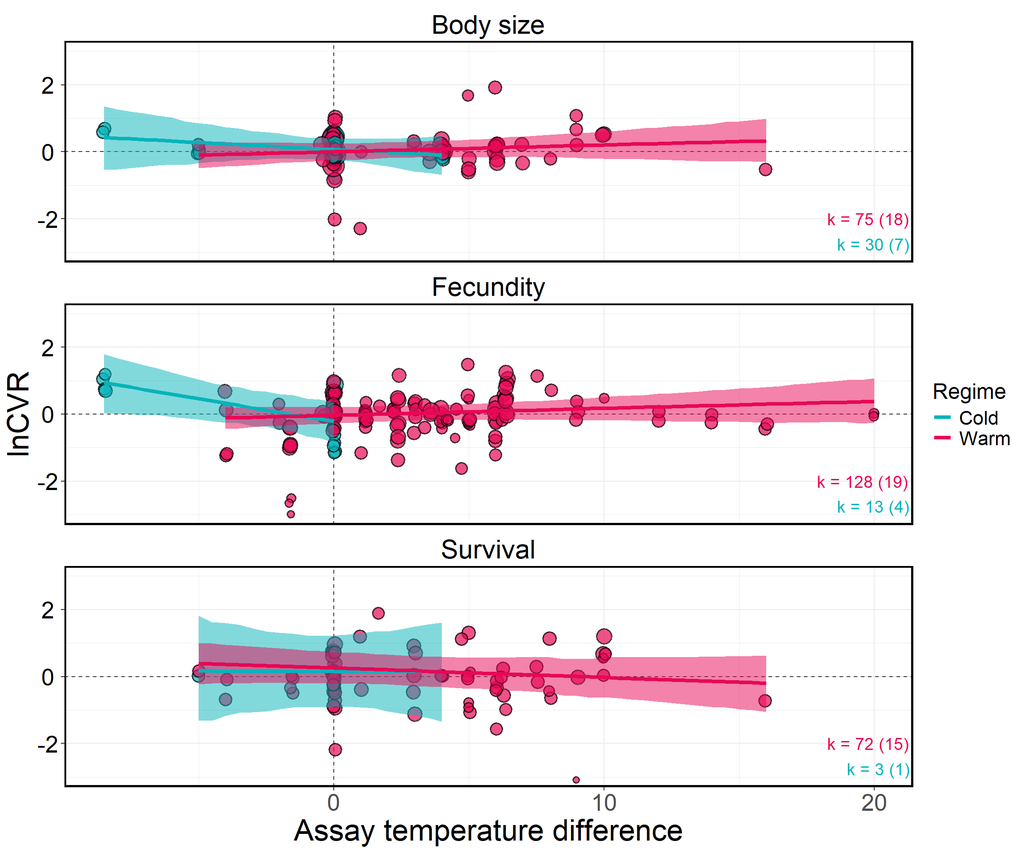

```r
# Discard observations flagged because the number of generations of selection was unclear, as this would only affect the results of meta-regressions
data <- mutate(data, minor_concerns2 = ifelse(minor_concerns == "gen_selection approximate" |
                                               minor_concerns == "gen_selection underestimated",
                     NA, minor_concerns))

# Filter to data without sources of procedural  concerns.
data_concerns <- filter(data, is.na(major_concerns)==T & is.na(minor_concerns2)==T)

# Calculate sample sizes and study counts
sample_sizes_concerns <- data_concerns %>%
  group_by(trait_type, warm_cold) %>%
  summarise(
    estimates = n(),
    studies = n_distinct(ref)
  )

# Generate predictions
emmeans_concerns <- as.data.frame(emmeans(
  lnCVR_model_concerns,
  specs = ~ assay_temp_diff | trait_type * warm_cold,
  at = list(assay_temp_diff = seq(min(data_concerns$assay_temp_diff), max(data_concerns$assay_temp_diff), by = 0.5))))

# Calculate range of values for each category
range_df_concerns <- data_concerns %>%
  group_by(trait_type, warm_cold) %>%
  summarize(
    min_assay_temp_diff = min(assay_temp_diff),
    max_assay_temp_diff = max(assay_temp_diff)
  )

emmeans_concerns$trait_type <- factor(emmeans_concerns$trait_type,
                          levels = c("body_size", "fecundity", "survival"),
                          labels = c("Body size", "Fecundity", "Survival"))

emmeans_concerns$warm_cold <- factor(emmeans_concerns$warm_cold,
                          levels = c("cold", "warm"),
                          labels = c("Cold", "Warm"))

# Tailor predictions to the range of the data
emmeans_concerns <- emmeans_concerns %>%
  left_join(range_df_concerns, by = c("trait_type", "warm_cold")) %>%
  filter(
    assay_temp_diff >= min_assay_temp_diff,
    assay_temp_diff <= max_assay_temp_diff
  )

# Plot
ggplot() +
    geom_hline(yintercept = 0, # Horizontal line
               linetype = 2,
               colour = "black",
               alpha = 0.75) +
    geom_vline(xintercept = 0, # Vertical line
               linetype = 2,
               colour = "black",
               alpha = 0.75) +
    geom_point(data = data_concerns, # Effect sizes, scaled by precision
                  aes(x = assay_temp_diff,
                      y = lnCVR,
                      size = 1/sqrt(var_lnCVR),
                      fill = warm_cold),
                  shape = 21,
                  alpha = 0.7,
                  stroke = 1,
                  position = position_jitter(width = 0.05)) +
     geom_ribbon(data = emmeans_concerns, # Shaded area for credible intervals
                 aes(x = assay_temp_diff,
                     ymin = lower.HPD,
                     ymax = upper.HPD,
                     fill = warm_cold,
                     group = warm_cold),
                 alpha = .5) +
     geom_line(data = emmeans_concerns,  # Predicted regression line
               aes(y = emmean,
                   x = assay_temp_diff,
                   color = warm_cold,
                   group = warm_cold),
               size = 1.5) +
    geom_text(data = sample_sizes_concerns,
              aes(x = Inf,
                  y = ifelse(warm_cold == "Warm", -2, -2.75),  # Sample sizes
                  label = paste0("k = ", estimates, " (", studies, ")"),
                  color = warm_cold),
              hjust = 1.05, size = 5, show.legend = FALSE) +

  facet_wrap(~ trait_type, ncol = 1) + # Different panels for each trait
  scale_fill_manual(values = c("#06B4BA", "#E80756"))+
  scale_color_manual(values = c("#06B4BA", "#E80756"))+
  labs(x = "Assay temperature difference", y = "lnCVR",
       col = "Regime") +
  theme_bw() +
  scale_size_continuous(range = c(2, 8))+
  theme(text = element_text(size = 25, color = "black"),
          legend.title = ggplot2::element_text(size = 18),
          legend.text = ggplot2::element_text(size = 16),
          axis.text.y = ggplot2::element_text(size = 20,
                colour = "black", hjust = 0.5),
          axis.text.x = ggplot2::element_text(size = 20),
        panel.border = element_rect(color = "black", size = 1.5),
        strip.background = element_blank(),
        strip.text = element_text(color = "black", size = 22)) +
    guides(fill = "none", size = "none")+
    coord_cartesian(ylim = c(-3, 3))
```

```r
ggsave(file = "fig/lnCVR_concerns.png", width = 12, height = 7, dpi = 500)
```

## **Changes in trait variance (lnVR)**

### **Constant vs. increasing temperatures**

#### *Model specification*

```r
# Model specification
formula <- bf(lnVR ~ 0 + trait_type:constant_increasing + trait_type:constant_increasing:assay_temp_diff + # Separate effects by trait type
                (trait_type-1|ref) + # Correlation between traits among studies
                (1|species) + # Species-level random effect
                (1|gr(phylogeny, cov = phylo_matrix_warm)) + # Phylogenetic relatedness
                (1|experiment_ID) + # Experiment-level random effect
                (1|obs) + # Observation-level random effect
                fcor(VCV_lnVR_warm)) # Variance covariance matix of correlated sampling variances

# Define priors
prior = c(
  prior(constant(1), class = "sigma")
) # Because the residual variance-covariance structure is specified in fcor, there is no need to estimate sigma so it is left as a constant

# Fit model
lnVR_model_constant_increasing <- brm(formula,
                                       family = gaussian(),
                                       data = data_warm,
                                       data2 = list(phylo_matrix_warm = phylo_matrix_warm,
                                                    VCV_lnVR_warm = VCV_lnVR_warm),
                                       prior = prior,
                                       control = list(adapt_delta = 0.99, max_treedepth = 15),
                                       iter = 4000,
                                       warmup = 2000,
                                       chains = 4,
                                       cores = 4,
                                       seed = 123)

# Save model
saveRDS(lnVR_model_constant_increasing, file = "RData/lnVR_model_constant_increasing.rds")
```

#### *Model output*

```r
# Load model
lnVR_model_constant_increasing <- readRDS("RData/lnVR_model_constant_increasing.rds")

# Display model output
summary(lnVR_model_constant_increasing)
```

```
##  Family: gaussian
##   Links: mu = identity; sigma = identity
## Formula: lnVR ~ 0 + trait_type:constant_increasing + trait_type:constant_increasing:assay_temp_diff + (trait_type - 1 | ref) + (1 | species) + (1 | gr(phylogeny, cov = phylo_matrix_warm)) + (1 | experiment_ID) + (1 | obs) + fcor(VCV_lnVR_warm)
##    Data: data_warm (Number of observations: 381)
##   Draws: 4 chains, each with iter = 4000; warmup = 2000; thin = 1;
##          total post-warmup draws = 8000
##
## Multilevel Hyperparameters:
## ~experiment_ID (Number of levels: 81)
##               Estimate Est.Error l-95% CI u-95% CI Rhat Bulk_ESS Tail_ESS
## sd(Intercept)     0.10      0.06     0.00     0.24 1.01      590     1729
##
## ~obs (Number of levels: 381)
##               Estimate Est.Error l-95% CI u-95% CI Rhat Bulk_ESS Tail_ESS
## sd(Intercept)     0.76      0.04     0.68     0.84 1.00     2368     4730
##
## ~phylogeny (Number of levels: 23)
##               Estimate Est.Error l-95% CI u-95% CI Rhat Bulk_ESS Tail_ESS
## sd(Intercept)     0.12      0.09     0.01     0.35 1.00     1683     3203
##
## ~ref (Number of levels: 38)
##                                              Estimate Est.Error l-95% CI
## sd(trait_typebody_size)                          0.09      0.08     0.00
## sd(trait_typefecundity)                          0.10      0.08     0.00
## sd(trait_typesurvival)                           0.31      0.18     0.02
## cor(trait_typebody_size,trait_typefecundity)     0.02      0.50    -0.88
## cor(trait_typebody_size,trait_typesurvival)     -0.02      0.49    -0.89
## cor(trait_typefecundity,trait_typesurvival)     -0.02      0.49    -0.88
##                                              u-95% CI Rhat Bulk_ESS Tail_ESS
## sd(trait_typebody_size)                          0.28 1.00     1982     3248
## sd(trait_typefecundity)                          0.29 1.00     1449     2442
## sd(trait_typesurvival)                           0.68 1.00      994     1772
## cor(trait_typebody_size,trait_typefecundity)     0.89 1.00     3136     4437
## cor(trait_typebody_size,trait_typesurvival)      0.85 1.00     1634     3846
## cor(trait_typefecundity,trait_typesurvival)      0.86 1.00     1835     3569
##
## ~species (Number of levels: 23)
##               Estimate Est.Error l-95% CI u-95% CI Rhat Bulk_ESS Tail_ESS
## sd(Intercept)     0.08      0.06     0.00     0.23 1.00     1989     3398
##
```

[output cut: 72 more lines]

```
## trait_typesurvival:constant_increasingincreasing                      3335
## trait_typebody_size:constant_increasingconstant:assay_temp_diff       3923
## trait_typefecundity:constant_increasingconstant:assay_temp_diff       3832
## trait_typesurvival:constant_increasingconstant:assay_temp_diff        4642
## trait_typebody_size:constant_increasingincreasing:assay_temp_diff     3380
## trait_typefecundity:constant_increasingincreasing:assay_temp_diff     3799
## trait_typesurvival:constant_increasingincreasing:assay_temp_diff      4030
##
## Further Distributional Parameters:
##       Estimate Est.Error l-95% CI u-95% CI Rhat Bulk_ESS Tail_ESS
## sigma     1.00      0.00     1.00     1.00   NA       NA       NA
##
## Draws were sampled using sampling(NUTS). For each parameter, Bulk_ESS
## and Tail_ESS are effective sample size measures, and Rhat is the potential
## scale reduction factor on split chains (at convergence, Rhat = 1).
```

```r
# R2
r2(lnVR_model_constant_increasing)
```

```
## # Bayesian R2 with Compatibility Interval
##
##   Conditional R2: 0.622 (95% CI [0.564, 0.676])
##      Marginal R2: 0.051 (95% CI [0.017, 0.094])
```

```r
# Cleaned model output
as.data.frame(fixef(lnVR_model_constant_increasing, summary = TRUE)) %>%
  # Rename categorical variables for cleaner display
  rownames_to_column(var = "Parameter") %>%
  mutate(
    # Simplify `trait_type` and `constant_increasing` interactions
    Parameter = gsub("trait_type([a-z_]+):constant_increasing(constant|increasing)", "\\1(\\2)", Parameter),
    # Adjust for assay_temp_diff
    Parameter = gsub("trait_type([a-z_]+)\\((constant|increasing)\\):assay_temp_diff", "\\1(\\2): assay_temp_diff", Parameter)
  ) %>%
  # Round numbers to 3 decimal points
  mutate(across(c(Estimate, Q2.5, Q97.5), ~ round(., 3))) %>%
  select(Parameter, Estimate, `Lower CI` = Q2.5, `Upper CI` = Q97.5) %>%
  kable() %>%
  kable_styling(full_width = FALSE, position = "center", fixed_thead = TRUE) %>%
  column_spec(1, bold = TRUE, border_right = TRUE) %>%
  row_spec(0, background = "white", color = "black", bold = TRUE) %>%
  kable_styling(fixed_thead = TRUE)
```

| Parameter | Estimate | Lower CI | Upper CI |
| --- | --- | --- | --- |
| body_size(constant) | 0.045 | -0.237 | 0.343 |
| fecundity(constant) | -0.146 | -0.418 | 0.124 |
| survival(constant) | 0.253 | -0.117 | 0.646 |
| body_size(increasing) | -0.114 | -0.777 | 0.550 |
| fecundity(increasing) | 0.014 | -0.394 | 0.445 |
| survival(increasing) | 0.065 | -0.646 | 0.855 |
| body_size(constant):assay_temp_diff | -0.009 | -0.054 | 0.034 |
| fecundity(constant):assay_temp_diff | 0.025 | -0.010 | 0.061 |
| survival(constant):assay_temp_diff | -0.024 | -0.079 | 0.031 |
| body_size(increasing):assay_temp_diff | 0.076 | -0.063 | 0.213 |
| fecundity(increasing):assay_temp_diff | -0.009 | -0.096 | 0.078 |
| survival(increasing):assay_temp_diff | -0.009 | -0.133 | 0.109 |

#### *Contrasts*

```r
# Generate predictions
emms <- emmeans(lnVR_model_constant_increasing,
                specs = ~ constant_increasing | trait_type,
                at = list(assay_temp_diff = 0))

# Generate contrasts
contrast(emms, method = "pairwise")
```

```
## trait_type = body_size:
##  contrast              estimate lower.HPD upper.HPD
##  constant - increasing    0.156    -0.541     0.824
##
## trait_type = fecundity:
##  contrast              estimate lower.HPD upper.HPD
##  constant - increasing   -0.157    -0.620     0.277
##
## trait_type = survival:
##  contrast              estimate lower.HPD upper.HPD
##  constant - increasing    0.205    -0.610     0.969
##
## Point estimate displayed: median
## HPD interval probability: 0.95
```

#### *Data visualisation*

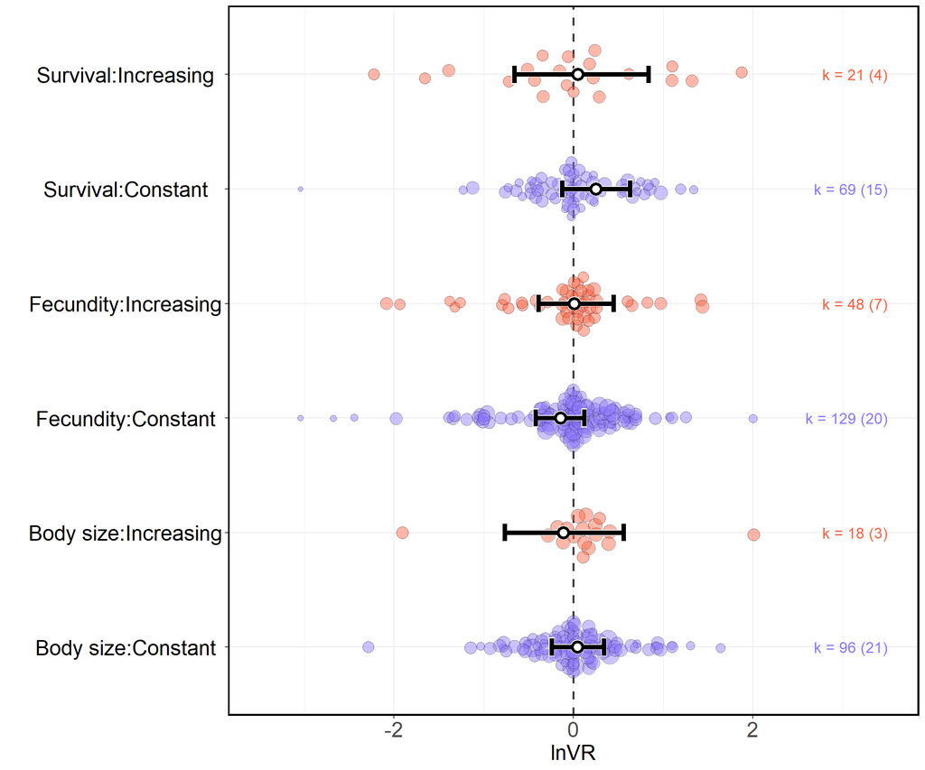

```r
# Generate predictions
emmeans_constant_increasing <- as.data.frame(emmeans(lnVR_model_constant_increasing,
                                                     specs = ~ constant_increasing | trait_type,
                                                     at = list(assay_temp_diff = 0)))

emmeans_constant_increasing$trait_type <- factor(emmeans_constant_increasing$trait_type,
                          levels = c("body_size", "fecundity", "survival"),
                          labels = c("Body size", "Fecundity", "Survival"))

emmeans_constant_increasing$constant_increasing <- factor(emmeans_constant_increasing$constant_increasing,
                          levels = c("constant", "increasing"),
                          labels = c("Constant", "Increasing"))

# Plot
ggplot() +
    geom_hline(yintercept = 0, # Horizontal line
               linetype = 2,
               colour = "black",
               alpha = 0.75,
               lwd=1) +
    geom_quasirandom(data = data_warm,     # Plot effect sizes, scaled by precision
                     aes(x = trait_type:constant_increasing,
                         y = lnVR,
                         fill = trait_type:constant_increasing,
                         size = 1/sqrt(var_lnVR)),
                     color = "black",
                     shape = 21,
                     width = 0.25,
                     alpha = 0.45) +
    geom_errorbar(data = emmeans_constant_increasing,  # Plot the point estimates in white for background
                  aes(x = trait_type:constant_increasing,
                      ymin = lower.HPD,
                      ymax = upper.HPD),
                  color="white",
                  size = 2.5,
                  width = 0.17) +
    geom_point(data = emmeans_constant_increasing,  # Plot the credible intervals in white for background
               aes(x = trait_type:constant_increasing,
                   y = emmean),
               shape = 21,
               size = 4,
               stroke = 2,
               color="white",
               fill = "white") +
    geom_errorbar(data = emmeans_constant_increasing, # Plot the point estimates
                  aes(x = trait_type:constant_increasing,
                      ymin = lower.HPD,
                      ymax = upper.HPD),
                  color="black",
                  size = 2,
                  width = 0.15) +
    geom_point(data = emmeans_constant_increasing, # Plot the credible intervals
               aes(x = trait_type:constant_increasing,
                   y = emmean),
               shape = 21,
               size = 3.5,
               stroke = 2,
               color="black",
               fill = "white") +
    geom_text(data = sample_sizes_warm,  # Sample size annotations
              aes(x = trait_type:constant_increasing,
                  y = 3.5,
                  label = paste0("k = ", estimates, " (", studies, ")"),
                  color = constant_increasing),
              hjust = 1, size = 5, show.legend = FALSE) +
    theme_bw() +     # Customize the plot
    labs(y = "lnVR", x = "") +
    scale_size_continuous(range = c(2, 8))+
    scale_fill_manual(values = c("#8E77FF", "#FF6040", "#8E77FF", "#FF6040", "#8E77FF", "#FF6040"))+
    scale_color_manual(values = c("Constant" = "#8E77FF", "Increasing" = "#FF6040")) +
    theme(text = element_text(size = 20, color = "black"),
          legend.title = ggplot2::element_text(size = 16),
          legend.text = ggplot2::element_text(size = 14),
          axis.text.y = ggplot2::element_text(size = 20,
                colour = "black", hjust = 0.5),
          axis.text.x = ggplot2::element_text(size = 20),
          panel.border = element_rect(color = "black", size = 1.5)) +
    guides(fill = "none", size = "none")+
    coord_flip() +
    ylim(-3.5, 3.5)
```

```r
ggsave(file = "fig/lnVR_constant_increasing.png", width = 12, height = 7, dpi = 500)
```

### **Leave-one-out analysis**

#### *Model specification*

```r
# Get a list of study IDs for the LOO
study_ids <- unique(data$ref)
num_studies <- length(study_ids)

# Initialize a list to store the results
loo_results <- vector("list", num_studies)
names(loo_results) <- study_ids

# Set up parallel processing (16 models at a time)
plan(multisession, workers = 16)

# Model specification
formula <- bf(lnVR ~ trait_type -1 + # Separate effects by trait type
                (trait_type-1|ref) + # Correlation between traits among studies
                (1|species) + # Species-level random effect
                (1|gr(phylogeny, cov = phylo_matrix)) + # Phylogenetic relatedness
                (1|experiment_ID) + # Experiment-level random effect
                (1|obs) + # Observation-level random effect
                fcor(VCV_lnVR)) # Variance covariance matix of correlated sampling variances

# Define priors
prior = c(
  prior(constant(1), class = "sigma")
) # Because the residual variance-covariance structure is specified in fcor, there is no need to estimate sigma so it is left as a constant


# Function to fit the model after iteratively removing one study
leave_one_out <- function(study_id) {
  # Subset the data
  data_subset <- subset(data, ref != study_id)

  # Recalculate VCV matrix
  VCV_lnVR_subset <- vcalc(
    vi = var_lnVR,
    cluster = shared_control_ID,
    rho = 0.5,
    obs = obs,
    data = data_subset
  )

  # Fit the model
  model_subset <- brm(
    formula,
    family = gaussian(),
    data = data_subset,
    data2 = list(
      phylo_matrix = phylo_matrix,
      VCV_lnVR = VCV_lnVR_subset
    ),
    prior = prior,
    control = list(adapt_delta = 0.99, max_treedepth = 15),
    iter = 2000, # Reduce to 2000 iterations to reduce computational demands
    warmup = 1000,
    chains = 2, # Only two chains to reduce computational demands
    cores = 1,   # Set cores to 1 inside the function
    seed = 123
  )

  # Extract the fixed effects
  fixed_effects <- fixef(model_subset)

  # Return the fixed effects
  return(list(study_id = study_id, fixed_effects = fixed_effects))
}

# Run the function in parallel over the studies
loo_results <- future_lapply(study_ids, leave_one_out)

# Save results
saveRDS(loo_results, file = "RData/lnVR_LOO_results.rds")
```

#### *Model summary*

```r
# Load the list of all model outputs
loo_lnVR <- readRDS(file = "RData/lnVR_LOO_results.rds")

# Extract data on fixed effects from each model

loo_results_lnVR <- do.call(rbind, lapply(loo_lnVR, function(x) {
  # Extract study_id and fixed_effects data
  study_id <- x$study_id
  fixed_effects <- x$fixed_effects

  # Convert row names (trait_type) to a column, remove prefix, and add study_id
  fixed_effects <- data.frame(trait_type = sub("trait_type", "", rownames(fixed_effects)), fixed_effects)
  fixed_effects$study_id <- study_id

  # Remove row names
  rownames(fixed_effects) <- NULL

  return(fixed_effects)
}))

loo_results_lnVR$trait_type <- factor(loo_results_lnVR$trait_type,
                          levels = c("body_size", "fecundity", "survival"),
                          labels = c("Body size", "Fecundity", "Survival"))

# Summarise the data
loo_results_lnVR %>%
  group_by(trait_type) %>%
  summarise(Estimate = mean(Estimate),
            SE = mean(Est.Error),
            lower_CI = mean(Q2.5),
            upper_CI = mean(Q97.5)) # Mean across all models
```

```
## # A tibble: 3 × 5
##   trait_type Estimate     SE lower_CI upper_CI
##   <fct>         <dbl>  <dbl>    <dbl>    <dbl>
## 1 Body size    0.0272 0.104    -0.172    0.242
## 2 Fecundity   -0.0576 0.0994   -0.254    0.143
## 3 Survival     0.105  0.129    -0.144    0.364
```

#### *Data visualisation*

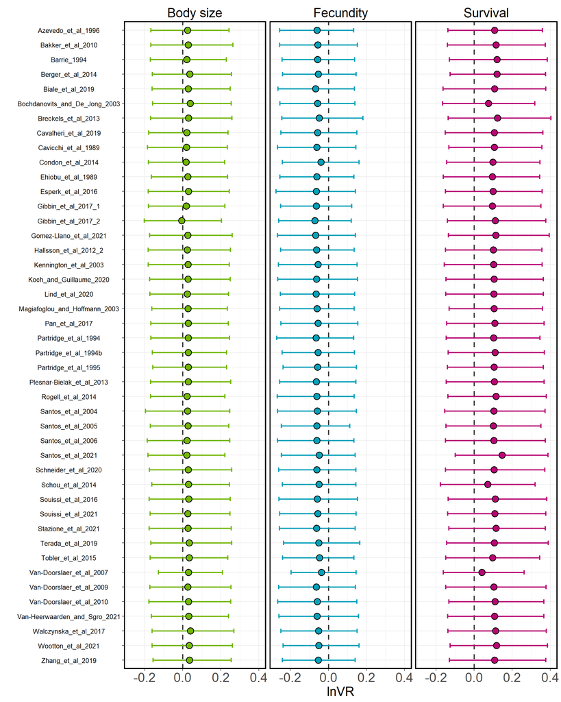

```r
# Plot
ggplot() +
    geom_hline(yintercept = 0, # Horizontal line
               linetype = 2,
               colour = "black",
               alpha = 0.75,
               lwd=1) +
    geom_errorbar(data = loo_results_lnVR,  # Plot the credible intervals in white for background
               aes(x = study_id,
                   y = Estimate,
                   ymin = Q2.5,
                   ymax = Q97.5,
                   color = trait_type),
               shape = 21,
               size = 1,
               width = 0.3) +
    geom_point(data = loo_results_lnVR,
               aes(x = study_id,
                   y = Estimate,
                   fill = trait_type),
               shape = 21,
               size = 4,
               stroke = 1,
               color="black") +
    theme_bw() +     # Customize the plot
    labs(y = "lnVR", x = "") +
    scale_fill_manual(values = c("#73B706", "#06A2BA", "#B90674"))+
    scale_color_manual(values = c("#73B706", "#06A2BA", "#B90674")) +
    theme(text = element_text(size = 20, color = "black"),
          legend.title = ggplot2::element_text(size = 16),
          legend.text = ggplot2::element_text(size = 14),
          axis.text.y = ggplot2::element_text(size = 10,
                colour = "black", hjust = 0.5),
          axis.text.x = ggplot2::element_text(size = 20),
          panel.border = element_rect(color = "black", size = 1.5),
          strip.background = element_blank(),
        strip.text = element_text(color = "black", size = 20)) +
    guides(fill = "none", color = "none")+
    coord_flip()+
    xlim(-0.45, 0.45) +
    facet_wrap(~trait_type, ncol = 3)+
   scale_x_discrete(limits = rev(levels(as.factor(loo_results_lnVR$study_id)))) # Alphabetical order
```

```r
ggsave(file = "fig/lnVR_LOO.png", width = 12, height = 12, dpi = 500)
```

### **Unusual study designs**

#### *Model specification*

```r
# Discard observations flagged because the number of generations of selection was unclear, as this would only affect the results of meta-regressions
data <- mutate(data, minor_concerns2 = ifelse(minor_concerns == "gen_selection approximate" |
                                               minor_concerns == "gen_selection underestimated",
                     NA, minor_concerns))

# Filter to data without sources of procedural  concerns.
data_concerns <- filter(data, is.na(major_concerns)==T & is.na(minor_concerns2)==T)

# Drop tips that are not in the warm dataset
tips_to_drop <- setdiff(phylo_tree$tip.label, data_concerns$phylogeny)
phylo_tree_concerns <- drop.tip(phylo_tree, tips_to_drop)

# Compute phylogenetic correlation matrix
phylo_matrix_concerns <- vcv(phylo_tree_concerns, cor = T)  # The vcv function returns a variance-covariance matrix

# Convert tibble to data frame
data_concerns <- as.data.frame(data_concerns)

# Calculate VCV matrix
VCV_lnVR_concerns <- vcalc(vi = var_lnVR,
                       cluster = shared_control_ID,
                       rho = 0.5,
                       obs = obs,
                       data = data_concerns)

# Model specification
formula <- bf(lnVR ~ 0 + trait_type:warm_cold + trait_type:warm_cold:assay_temp_diff + # Separate effects by trait type
                (trait_type-1|ref) + # Correlation between traits among studies
                (1|species) + # Species-level random effect
                (1|gr(phylogeny, cov = phylo_matrix_concerns)) + # Phylogenetic relatedness
                (1|experiment_ID) + # Experiment-level random effect
                (1|obs) + # Observation-level random effect
                fcor(VCV_lnVR_concerns)) # Variance covariance matix of correlated sampling variances

# Define priors
prior = c(
  prior(constant(1), class = "sigma")
) # Because the residual variance-covariance structure is specified in fcor, there is no need to estimate sigma so it is left as a constant

# Fit model
lnVR_model_concerns <- brm(formula,
                                      family = gaussian(),
                                      data = data_concerns,
                                      data2 = list(phylo_matrix_concerns = phylo_matrix_concerns,
                                                   VCV_lnVR_concerns = VCV_lnVR_concerns),
                                      prior = prior,
                                      control = list(adapt_delta = 0.99, max_treedepth = 15),
                                      iter = 4000,
                                      warmup = 2000,
                                      chains = 4,
                                      cores = 4,
                                      seed = 123)
# Save model
saveRDS(lnVR_model_concerns, file = "RData/lnVR_model_concerns.rds")
```

#### *Model summary*

```r
# Load model
lnVR_model_concerns <- readRDS("RData/lnVR_model_concerns.rds")

# Display model output
summary(lnVR_model_concerns)
```

```
##  Family: gaussian
##   Links: mu = identity; sigma = identity
## Formula: lnVR ~ 0 + trait_type:warm_cold + trait_type:warm_cold:assay_temp_diff + (trait_type - 1 | ref) + (1 | species) + (1 | gr(phylogeny, cov = phylo_matrix_concerns)) + (1 | experiment_ID) + (1 | obs) + fcor(VCV_lnVR_concerns)
##    Data: data_concerns (Number of observations: 321)
##   Draws: 4 chains, each with iter = 4000; warmup = 2000; thin = 1;
##          total post-warmup draws = 8000
##
## Multilevel Hyperparameters:
## ~experiment_ID (Number of levels: 72)
##               Estimate Est.Error l-95% CI u-95% CI Rhat Bulk_ESS Tail_ESS
## sd(Intercept)     0.16      0.08     0.01     0.33 1.00      878     2212
##
## ~obs (Number of levels: 321)
##               Estimate Est.Error l-95% CI u-95% CI Rhat Bulk_ESS Tail_ESS
## sd(Intercept)     0.78      0.05     0.70     0.88 1.00     2869     5068
##
## ~phylogeny (Number of levels: 22)
##               Estimate Est.Error l-95% CI u-95% CI Rhat Bulk_ESS Tail_ESS
## sd(Intercept)     0.12      0.10     0.00     0.36 1.00     3156     4492
##
## ~ref (Number of levels: 33)
##                                              Estimate Est.Error l-95% CI
## sd(trait_typebody_size)                          0.10      0.08     0.00
## sd(trait_typefecundity)                          0.11      0.09     0.00
## sd(trait_typesurvival)                           0.35      0.19     0.03
## cor(trait_typebody_size,trait_typefecundity)     0.03      0.50    -0.87
## cor(trait_typebody_size,trait_typesurvival)     -0.04      0.50    -0.89
## cor(trait_typefecundity,trait_typesurvival)     -0.02      0.49    -0.87
##                                              u-95% CI Rhat Bulk_ESS Tail_ESS
## sd(trait_typebody_size)                          0.31 1.00     2375     4175
## sd(trait_typefecundity)                          0.33 1.00     2540     4109
## sd(trait_typesurvival)                           0.77 1.00     1561     2855
## cor(trait_typebody_size,trait_typefecundity)     0.89 1.00     5445     5433
## cor(trait_typebody_size,trait_typesurvival)      0.87 1.00     2578     4513
## cor(trait_typefecundity,trait_typesurvival)      0.87 1.00     3091     5346
##
## ~species (Number of levels: 22)
##               Estimate Est.Error l-95% CI u-95% CI Rhat Bulk_ESS Tail_ESS
## sd(Intercept)     0.08      0.06     0.00     0.24 1.00     3266     4264
##
```

[output cut: 33 more lines]

```
## trait_typesurvival:warm_coldwarm                      4377
## trait_typebody_size:warm_coldcold:assay_temp_diff     5687
## trait_typefecundity:warm_coldcold:assay_temp_diff     5867
## trait_typesurvival:warm_coldcold:assay_temp_diff      6624
## trait_typebody_size:warm_coldwarm:assay_temp_diff     4646
## trait_typefecundity:warm_coldwarm:assay_temp_diff     4575
## trait_typesurvival:warm_coldwarm:assay_temp_diff      5704
##
## Further Distributional Parameters:
##       Estimate Est.Error l-95% CI u-95% CI Rhat Bulk_ESS Tail_ESS
## sigma     1.00      0.00     1.00     1.00   NA       NA       NA
##
## Draws were sampled using sampling(NUTS). For each parameter, Bulk_ESS
## and Tail_ESS are effective sample size measures, and Rhat is the potential
## scale reduction factor on split chains (at convergence, Rhat = 1).
```

```r
# R2
r2(lnVR_model_concerns)
```

```
## # Bayesian R2 with Compatibility Interval
##
##   Conditional R2: 0.695 (95% CI [0.637, 0.754])
##      Marginal R2: 0.076 (95% CI [0.032, 0.130])
```

```r
# Cleaned model output
as.data.frame(fixef(lnVR_model_concerns, summary = TRUE)) %>%
  # Rename categorical variables for cleaner display
  rownames_to_column(var = "Parameter") %>%
  mutate(
    Parameter = gsub("trait_type([a-z_]+):warm_cold(cold|warm)", "\\1(\\2)", Parameter),
    Parameter = gsub("trait_type([a-z_]+)\\(warm\\):assay_temp_diff", "\\1(warm): assay_temp_diff", Parameter)
  ) %>%
  # Round numbers to 3 decimal points
  mutate(across(c(Estimate, Q2.5, Q97.5), ~ round(., 3))) %>%
  select(Parameter, Estimate, `Lower CI` = Q2.5, `Upper CI` = Q97.5) %>%
  kable() %>%
  kable_styling(full_width = FALSE, position = "center", fixed_thead = TRUE) %>%
  column_spec(1, bold = TRUE, border_right = TRUE) %>%
  row_spec(0, background = "white", color = "black", bold = TRUE) %>%
  kable_styling(fixed_thead = TRUE)
```

| Parameter | Estimate | Lower CI | Upper CI |
| --- | --- | --- | --- |
| body_size(cold) | 0.081 | -0.346 | 0.518 |
| fecundity(cold) | -0.649 | -1.378 | 0.069 |
| survival(cold) | 0.118 | -1.058 | 1.292 |
| body_size(warm) | -0.007 | -0.321 | 0.320 |
| fecundity(warm) | -0.116 | -0.401 | 0.171 |
| survival(warm) | 0.215 | -0.176 | 0.625 |
| body_size(cold):assay_temp_diff | -0.047 | -0.179 | 0.084 |
| fecundity(cold):assay_temp_diff | -0.227 | -0.370 | -0.081 |
| survival(cold):assay_temp_diff | -0.009 | -0.300 | 0.273 |
| body_size(warm):assay_temp_diff | 0.018 | -0.040 | 0.075 |
| fecundity(warm):assay_temp_diff | 0.020 | -0.019 | 0.059 |
| survival(warm):assay_temp_diff | -0.028 | -0.090 | 0.034 |

#### *Data visualisation*

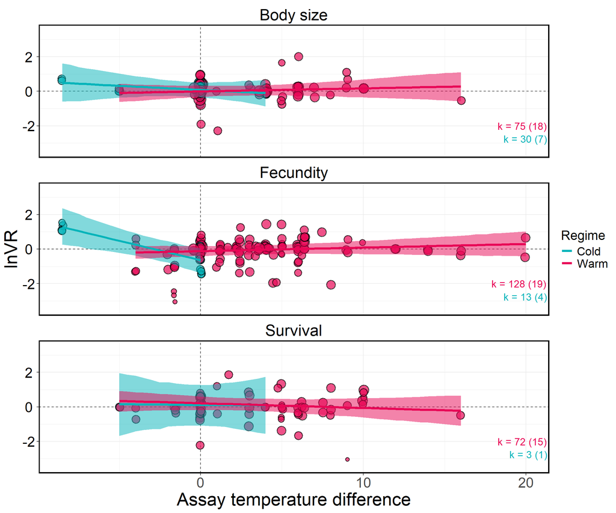

```r
# Discard observations flagged because the number of generations of selection was unclear, as this would only affect the results of meta-regressions
data <- mutate(data, minor_concerns2 = ifelse(minor_concerns == "gen_selection approximate" |
                                               minor_concerns == "gen_selection underestimated",
                     NA, minor_concerns))

# Filter to data without sources of procedural  concerns.
data_concerns <- filter(data, is.na(major_concerns)==T & is.na(minor_concerns2)==T)

# Calculate sample sizes and study counts
sample_sizes_concerns <- data_concerns %>%
  group_by(trait_type, warm_cold) %>%
  summarise(
    estimates = n(),
    studies = n_distinct(ref)
  )

# Generate predictions
emmeans_concerns <- as.data.frame(emmeans(
  lnVR_model_concerns,
  specs = ~ assay_temp_diff | trait_type * warm_cold,
  at = list(assay_temp_diff = seq(min(data_concerns$assay_temp_diff), max(data_concerns$assay_temp_diff), by = 0.5))))

# Calculate range of values for each category
range_df_concerns <- data_concerns %>%
  group_by(trait_type, warm_cold) %>%
  summarize(
    min_assay_temp_diff = min(assay_temp_diff),
    max_assay_temp_diff = max(assay_temp_diff)
  )

emmeans_concerns$trait_type <- factor(emmeans_concerns$trait_type,
                          levels = c("body_size", "fecundity", "survival"),
                          labels = c("Body size", "Fecundity", "Survival"))

emmeans_concerns$warm_cold <- factor(emmeans_concerns$warm_cold,
                          levels = c("cold", "warm"),
                          labels = c("Cold", "Warm"))

# Tailor predictions to the range of the data
emmeans_concerns <- emmeans_concerns %>%
  left_join(range_df_concerns, by = c("trait_type", "warm_cold")) %>%
  filter(
    assay_temp_diff >= min_assay_temp_diff,
    assay_temp_diff <= max_assay_temp_diff
  )

# Plot
ggplot() +
    geom_hline(yintercept = 0, # Horizontal line
               linetype = 2,
               colour = "black",
               alpha = 0.75) +
    geom_vline(xintercept = 0, # Vertical line
               linetype = 2,
               colour = "black",
               alpha = 0.75) +
    geom_point(data = data_concerns, # Effect sizes, scaled by precision
                  aes(x = assay_temp_diff,
                      y = lnVR,
                      size = 1/sqrt(var_lnVR),
                      fill = warm_cold),
                  shape = 21,
                  alpha = 0.7,
                  stroke = 1,
                  position = position_jitter(width = 0.05)) +
     geom_ribbon(data = emmeans_concerns, # Shaded area for credible intervals
                 aes(x = assay_temp_diff,
                     ymin = lower.HPD,
                     ymax = upper.HPD,
                     fill = warm_cold,
                     group = warm_cold),
                 alpha = .5) +
     geom_line(data = emmeans_concerns,  # Predicted regression line
               aes(y = emmean,
                   x = assay_temp_diff,
                   color = warm_cold,
                   group = warm_cold),
               size = 1.5) +
    geom_text(data = sample_sizes_concerns,
              aes(x = Inf,
                  y = ifelse(warm_cold == "Warm", -2, -2.75),  # Sample sizes
                  label = paste0("k = ", estimates, " (", studies, ")"),
                  color = warm_cold),
              hjust = 1.05, size = 5, show.legend = FALSE) +

  facet_wrap(~ trait_type, ncol = 1) + # Different panels for each trait
  scale_fill_manual(values = c("#06B4BA", "#E80756"))+
  scale_color_manual(values = c("#06B4BA", "#E80756"))+
  labs(x = "Assay temperature difference", y = "lnVR",
       col = "Regime") +
  theme_bw() +
  scale_size_continuous(range = c(2, 8))+
  theme(text = element_text(size = 25, color = "black"),
          legend.title = ggplot2::element_text(size = 18),
          legend.text = ggplot2::element_text(size = 16),
          axis.text.y = ggplot2::element_text(size = 20,
                colour = "black", hjust = 0.5),
          axis.text.x = ggplot2::element_text(size = 20),
        panel.border = element_rect(color = "black", size = 1.5),
        strip.background = element_blank(),
        strip.text = element_text(color = "black", size = 22)) +
    guides(fill = "none", size = "none")+
    coord_cartesian(ylim = c(-3.5, 3.5))
```

```r
ggsave(file = "fig/lnVR_concerns.png", width = 12, height = 7, dpi = 500)
```

# **Main figures**

Note that Figure 1 was created without code.

## **Helper functions**

```r
# Helper functions to clip y axis differently for each trait
make_facet_limits <- function(data_points, data_preds, trait_var = "trait_type",
                              y_point = "lnRR", y_lower = "lower.HPD", y_upper = "upper.HPD",
                              buffer = 0.05, cap = 1.6) {

  y_all <- bind_rows(
    data.frame(
      trait_type = data_points[[trait_var]],
      y = data_points[[y_point]]
    ),
    data.frame(
      trait_type = data_preds[[trait_var]],
      y = data_preds[[y_lower]]
    ),
    data.frame(
      trait_type = data_preds[[trait_var]],
      y = data_preds[[y_upper]]
    )
  ) %>%
    dplyr::group_by(trait_type) %>%
    dplyr::summarise(
      lim = pmin(max(abs(y), na.rm = TRUE) + buffer, cap),
      ymin = -lim,
      ymax = lim,
      .groups = "drop"
    )

  y_all
}

clip_plot_data <- function(data_points, data_preds, facet_limits,
                           trait_var = "trait_type",
                           y_point = "lnRR", y_mean = "emmean",
                           y_lower = "lower.HPD", y_upper = "upper.HPD") {

  # POINTS: remove values outside limits
  data_points_plot <- data_points %>%
    dplyr::left_join(facet_limits, by = setNames("trait_type", trait_var)) %>%
    dplyr::filter(.data[[y_point]] >= ymin, .data[[y_point]] <= ymax)

  # PREDICTIONS: clip to limits
  data_preds_plot <- data_preds %>%
    dplyr::left_join(facet_limits, by = setNames("trait_type", trait_var)) %>%
    dplyr::mutate(
      y_mean_plot  = pmax(pmin(.data[[y_mean]],  ymax), ymin),
      y_lower_plot = pmax(pmin(.data[[y_lower]], ymax), ymin),
      y_upper_plot = pmax(pmin(.data[[y_upper]], ymax), ymin)
    )

  list(points = data_points_plot, preds = data_preds_plot)
}

make_sample_size_positions <- function(sample_sizes_df, facet_limits,
                                       warm_var = "warm_cold",
                                       trait_var = "trait_type") {

  sample_sizes_df %>%
    dplyr::left_join(facet_limits, by = setNames("trait_type", trait_var)) %>%
    dplyr::mutate(
      y = ifelse(
        .data[[warm_var]] == "Warm" | .data[[warm_var]] == "warm",
        ymin + 0.18 * (ymax - ymin),
        ymin + 0.05 * (ymax - ymin)
      )
    )
}
```

## **Figure 2**

```r
# Match species to the OTL database
resolved_names <- tnrs_match_names(unique(data$species), context_name = "Animals")

# Create tree
tree <- tol_induced_subtree(ott_ids = resolved_names$ott_id)
```

```
## Progress [---------------------------------] 0/316 (  0%) ?sProgress [==============================] 316/316 (100%)  0s
```

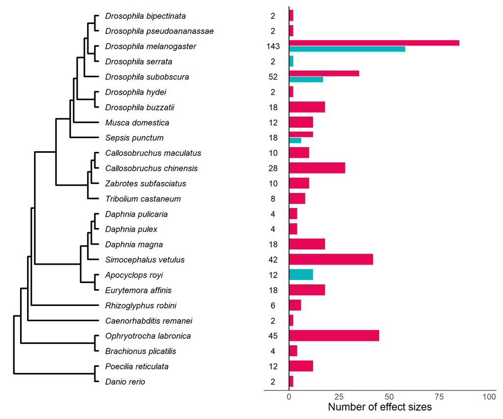

```r
tree$tip.label <- strip_ott_ids(tree$tip.label) # Remove ott IDs for presentation

tree <- multi2di(tree, random = TRUE) # Resolve polytomy at random, but it matches classification from Cornetti et al. 2019. Molecular Phylogenetics and Evolution; with D. pulex and D. pulicaria being more closely related to eachother than D. magna
phylo_tree <- compute.brlen(tree, method = "Grafen", power = 1) # Compute branch lengths

# Remove underscore for species names
phylo_tree$tip.label <- gsub("_", " ", phylo_tree$tip.label) # Add underscore between species names

# Create a data summary for each species
species_summary <- data %>%
  group_by(tip.label = species, warm_cold) %>%
  summarise(n_effect_sizes = n(), .groups = "drop")

species_totals <- species_summary %>%
  group_by(tip.label) %>%
  summarise(total_effect_sizes = sum(n_effect_sizes), .groups = "drop")

# Order species
species_order <- rev(c(
  "Drosophila bipectinata",
  "Drosophila pseudoananassae",
  "Drosophila melanogaster",
  "Drosophila serrata",
  "Drosophila subobscura",
  "Drosophila hydei",
  "Drosophila buzzatii",
  "Musca domestica",
  "Sepsis punctum",
  "Callosobruchus chinensis",
  "Callosobruchus maculatus",
  "Zabrotes subfasciatus",
  "Tribolium castaneum",
  "Daphnia pulicaria",
  "Daphnia pulex",
  "Daphnia magna",
  "Simocephalus vetulus",
  "Apocyclops royi",
  "Eurytemora affinis",
  "Rhizoglyphus robini",
  "Caenorhabditis remanei",
  "Ophryotrocha labronica",
  "Brachionus plicatilis",
  "Poecilia reticulata",
  "Danio rerio"
))

species_summary <- species_summary %>%
  mutate(tip.label = factor(tip.label, levels = species_order))

# Plot tree
tree_plot <- ggtree(phylo_tree, lwd = 1.25) +
  geom_tiplab(size = 5,
              offset = 0.075,
              fontface = "italic") +
  xlim(0, 2.5) +
  theme(plot.margin = unit(c(0, 1.5, 0, 0), "cm"))

barplot <- ggplot(species_summary, aes(x = tip.label,
                                       y = n_effect_sizes,
                                       fill = warm_cold)) +
  geom_bar(stat = "identity",
           position = position_dodge2(),
           width = 0.8) +
  geom_hline(yintercept = 0,
             color = "black",
             size = 0.75) +  # Add vertical line
  geom_vline(xintercept = 0.4,
             color = "black",
             size = 0.5) +  # Add horizontal line
  geom_text(data = species_totals,
            aes(x = tip.label,
                y = -8,
                label = total_effect_sizes),
            inherit.aes = FALSE,
            size = 5) +  # Add total count annotation
  scale_fill_manual(values = c("Cold" = "#06B4BA", "Warm" = "#E80756")) +
  coord_flip() +
  scale_y_continuous(expand = expansion(mult = c(0.05, 0.2))) +  # Add space on the right
  theme_minimal() +
  labs(x = NULL, y = "Number of effect sizes") +
  theme(axis.text.y = element_blank(),  # Remove y-axis text for alignment
        axis.ticks.y = element_blank(),
        panel.grid = element_blank(),  # Remove grid
        plot.background = element_rect(fill = "white", color = NA),  # White background
        legend.position = "none",
        axis.text = element_text (size = 14), col = "black",
        axis.title = element_text(size = 18))


tree_plot | barplot
```

```r
ggsave(file = "fig/figure_2.svg", width = 12, height = 10, dpi = 500)
```

## **Figure 3**

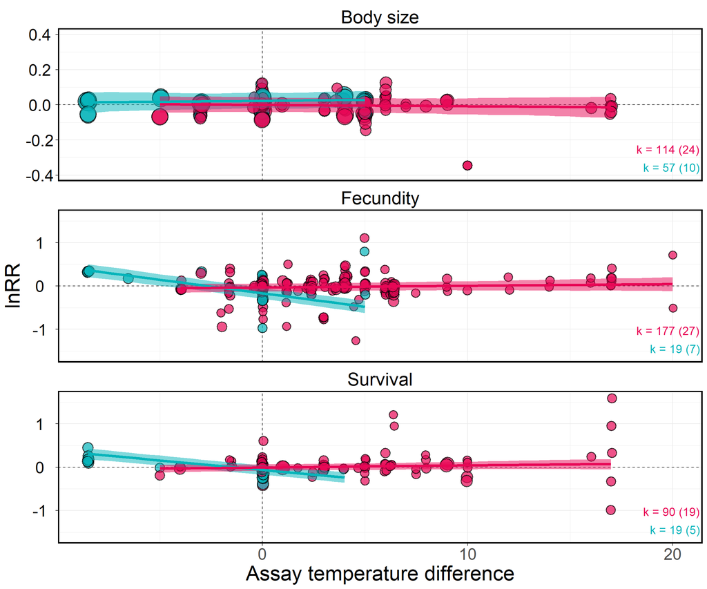

```r
# Load model
lnRR_model_assay_temp_diff <- readRDS("RData/lnRR_model_assay_temp_diff.rds")

# Generate predictions
emmeans_assay_temp_diff <- as.data.frame(
  emmeans(
    lnRR_model_assay_temp_diff,
    specs = ~ assay_temp_diff | trait_type * warm_cold,
    at = list(
      assay_temp_diff = seq(
        min(data$assay_temp_diff, na.rm = TRUE),
        max(data$assay_temp_diff, na.rm = TRUE),
        by = 0.5
      )
    )
  )
)

# Calculate range of values for each category
range_df <- data %>%
  group_by(trait_type, warm_cold) %>%
  summarize(
    min_assay_temp_diff = min(assay_temp_diff, na.rm = TRUE),
    max_assay_temp_diff = max(assay_temp_diff, na.rm = TRUE),
    .groups = "drop"
  )

# Match emmeans coding to whatever is already in data
emmeans_assay_temp_diff$trait_type <- factor(
  emmeans_assay_temp_diff$trait_type,
  levels = c("body_size", "fecundity", "survival"),
  labels = c("Body size", "Fecundity", "Survival")
)

emmeans_assay_temp_diff$warm_cold <- factor(
  emmeans_assay_temp_diff$warm_cold,
  levels = c("cold", "warm"),
  labels = c("Cold", "Warm")
)

# Tailor predictions to the range of the data
emmeans_assay_temp_diff <- emmeans_assay_temp_diff %>%
  left_join(range_df, by = c("trait_type", "warm_cold")) %>%
  filter(
    assay_temp_diff >= min_assay_temp_diff,
    assay_temp_diff <= max_assay_temp_diff
  )

# Plot objects using helper functions
facet_limits_rr <- make_facet_limits(
  data_points = data,
  data_preds = emmeans_assay_temp_diff,
  y_point = "lnRR",
  y_lower = "lower.HPD",
  y_upper = "upper.HPD",
  buffer = 0.05,
  cap = 1.6
)

plot_data_rr <- clip_plot_data(
  data_points = data,
  data_preds = emmeans_assay_temp_diff,
  facet_limits = facet_limits_rr,
  y_point = "lnRR",
  y_mean = "emmean",
  y_lower = "lower.HPD",
  y_upper = "upper.HPD"
)

sample_sizes_rr <- make_sample_size_positions(
  sample_sizes_df = sample_sizes,
  facet_limits = facet_limits_rr
)

ggplot() +
  geom_blank(data = facet_limits_rr, aes(x = 0, y = ymin)) +
  geom_blank(data = facet_limits_rr, aes(x = 0, y = ymax)) +
  geom_hline(yintercept = 0, linetype = 2, colour = "black", alpha = 0.75) +
  geom_vline(xintercept = 0, linetype = 2, colour = "black", alpha = 0.75) +
  geom_point(
    data = plot_data_rr$points,
    aes(
      x = assay_temp_diff,
      y = lnRR,
      size = 1 / sqrt(var_lnRR),
      fill = warm_cold
    ),
    shape = 21,
    alpha = 0.7,
    stroke = 1,
    position = position_jitter(width = 0.05)
  ) +
  geom_ribbon(
    data = plot_data_rr$preds,
    aes(
      x = assay_temp_diff,
      ymin = y_lower_plot,
      ymax = y_upper_plot,
      fill = warm_cold,
      group = warm_cold
    ),
    alpha = .5
  ) +
  geom_line(
    data = plot_data_rr$preds,
    aes(
      y = y_mean_plot,
      x = assay_temp_diff,
      color = warm_cold,
      group = warm_cold
    ),
    size = 1.5
  ) +
  geom_text(
    data = sample_sizes_rr,
    aes(
      x = Inf,
      y = y,
      label = paste0("k = ", estimates, " (", studies, ")"),
      color = warm_cold
    ),
    hjust = 1.05,
    size = 5,
    show.legend = FALSE
  ) +
  facet_wrap(~ trait_type, ncol = 1, scales = "free_y") +
  scale_fill_manual(values = c("#06B4BA", "#E80756")) +
  scale_color_manual(values = c("#06B4BA", "#E80756")) +
  labs(
    x = "Assay temperature difference",
    y = "lnRR",
    col = "Regime"
  ) +
  theme_bw() +
  scale_size_continuous(range = c(4, 10)) +
  theme(
    text = element_text(size = 25, color = "black"),
    legend.title = ggplot2::element_text(size = 18),
    legend.text = ggplot2::element_text(size = 16),
    axis.text.y = ggplot2::element_text(size = 20, colour = "black", hjust = 0.5),
    axis.text.x = ggplot2::element_text(size = 20),
    panel.border = element_rect(color = "black", size = 1.5),
    strip.background = element_blank(),
    strip.text = element_text(color = "black", size = 22)
  ) +
  guides(fill = "none", col = "none", size = "none")
```

```r
ggsave(file = "fig/figure_3.svg", width = 10, height = 10, dpi = 500)
```

## **Figure 4**

```r
# Load models
lnRR_model_sel_temp_diff <- readRDS("RData/lnRR_model_sel_temp_diff.rds")
lnRR_model_gen_selection <- readRDS("RData/lnRR_model_gen_selection.rds")
lnRR_model_gen_common_garden <- readRDS("RData/lnRR_model_gen_common_garden.rds")
lnRR_model_pop_size <- readRDS("RData/lnRR_model_pop_size.rds")

##################### Selection temperature ################################

# Generate predictions
emmeans_sel_temp_diff <- as.data.frame(emmeans(
  lnRR_model_sel_temp_diff,
  specs = ~ select_temp_diff | trait_type * warm_cold,
  at = list(select_temp_diff = seq(min(data$select_temp_diff), max(data$select_temp_diff), by = 0.1),
            assay_temp_diff = 0))
  ) # Conditional effects on assay_temp_diff = 0

# Calculate range of values for each category
range_df <- data %>%
  group_by(trait_type, warm_cold) %>%
  summarize(
    min_select_temp_diff = min(select_temp_diff),
    max_select_temp_diff = max(select_temp_diff)
  )

emmeans_sel_temp_diff$trait_type <- factor(emmeans_sel_temp_diff$trait_type,
                          levels = c("body_size", "fecundity", "survival"),
                          labels = c("Body size", "Fecundity", "Survival"))

emmeans_sel_temp_diff$warm_cold <- factor(emmeans_sel_temp_diff$warm_cold,
                          levels = c("cold", "warm"),
                          labels = c("Cold", "Warm"))

# Tailor predictions to the range of the data
emmeans_sel_temp_diff <- emmeans_sel_temp_diff %>%
  left_join(range_df, by = c("trait_type", "warm_cold")) %>%
  filter(
    select_temp_diff >= min_select_temp_diff,
    select_temp_diff <= max_select_temp_diff
  )


facet_limits_sel <- make_facet_limits(
  data_points = data,
  data_preds = emmeans_sel_temp_diff,
  buffer = 0.05,
  cap = 1.6
)

plot_data_sel <- clip_plot_data(
  data_points = data,
  data_preds = emmeans_sel_temp_diff,
  facet_limits = facet_limits_sel
)

sample_sizes_sel <- make_sample_size_positions(
  sample_sizes_df = sample_sizes,
  facet_limits = facet_limits_sel
)

# Plot
sel_temp_diff <-
ggplot() +
  geom_blank(data = facet_limits_sel, aes(x = 0, y = ymin)) +
  geom_blank(data = facet_limits_sel, aes(x = 0, y = ymax)) +
  geom_hline(yintercept = 0, linetype = 2, colour = "black", alpha = 0.75) +
  geom_point(
    data = plot_data_sel$points,
    aes(
      x = select_temp_diff,
      y = lnRR,
      size = 1/sqrt(var_lnRR),
      fill = warm_cold
    ),
    shape = 21,
    alpha = 0.7,
    stroke = 1,
    position = position_jitter(width = 0.05)
  ) +
  geom_ribbon(
    data = plot_data_sel$preds,
    aes(
      x = select_temp_diff,
      ymin = y_lower_plot,
      ymax = y_upper_plot,
      fill = warm_cold,
      group = warm_cold
    ),
    alpha = .5
  ) +
  geom_line(
    data = plot_data_sel$preds,
    aes(
      y = y_mean_plot,
      x = select_temp_diff,
      color = warm_cold,
      group = warm_cold
    ),
    size = 1.5
  ) +
  geom_text(
    data = sample_sizes_sel,
    aes(
      x = Inf,
      y = y,
      label = paste0("k = ", estimates, " (", studies, ")"),
      color = warm_cold
    ),
    hjust = 1.05, size = 7, show.legend = FALSE
  ) +
  facet_wrap(~ trait_type, ncol = 1, scales = "free_y") +
  scale_fill_manual(values = c("#06B4BA", "#E80756")) +
  scale_color_manual(values = c("#06B4BA", "#E80756")) +
  labs(x = "Selection temperature difference", y = "lnRR", col = "Regime") +
  theme_bw() +
  scale_size_continuous(range = c(4, 10)) +
  theme(
    text = element_text(size = 30, color = "black"),
    legend.title = ggplot2::element_text(size = 18),
    legend.text = ggplot2::element_text(size = 16),
    axis.text.y = ggplot2::element_text(size = 20, colour = "black", hjust = 0.5),
    axis.text.x = ggplot2::element_text(size = 20),
    panel.border = element_rect(color = "black", size = 1.5),
    strip.background = element_blank(),
    strip.text = element_text(color = "black", size = 28),
    plot.margin = unit(c(1, 0, 0, 0), "cm")
  ) +
  guides(fill = "none", size = "none", color = "none")

############## Generations of selection ##################################

# Generate predictions
emmeans_gen_selection <- as.data.frame(emmeans(
  lnRR_model_gen_selection,
  specs = ~ gen_selection | trait_type * warm_cold,
  at = list(gen_selection = seq(min(data$gen_selection), max(data$gen_selection), by = 1),
            assay_temp_diff = 0))
  ) # Conditional effects on assay_temp_diff = 0

# Calculate range of values for each category
range_df <- data %>%
  group_by(trait_type, warm_cold) %>%
  summarize(
    min_gen_selection = min(gen_selection),
    max_gen_selection = max(gen_selection)
  )

emmeans_gen_selection$trait_type <- factor(emmeans_gen_selection$trait_type,
                          levels = c("body_size", "fecundity", "survival"),
                          labels = c("Body size", "Fecundity", "Survival"))

emmeans_gen_selection$warm_cold <- factor(emmeans_gen_selection$warm_cold,
                          levels = c("cold", "warm"),
                          labels = c("Cold", "Warm"))

# Tailor predictions to the range of the data
emmeans_gen_selection <- emmeans_gen_selection %>%
  left_join(range_df, by = c("trait_type", "warm_cold")) %>%
  filter(
    gen_selection >= min_gen_selection,
    gen_selection <= max_gen_selection
  )

# Plot
facet_limits_gen_sel <- make_facet_limits(
  data_points = data,
  data_preds = emmeans_gen_selection,
  buffer = 0.05,
  cap = 1.6
)

plot_data_gen_sel <- clip_plot_data(
  data_points = data,
  data_preds = emmeans_gen_selection,
  facet_limits = facet_limits_gen_sel
)

sample_sizes_gen_sel <- make_sample_size_positions(
  sample_sizes_df = sample_sizes,
  facet_limits = facet_limits_gen_sel
)

gen_selection <-
ggplot() +
  geom_blank(data = facet_limits_gen_sel, aes(x = 0, y = ymin)) +
  geom_blank(data = facet_limits_gen_sel, aes(x = 0, y = ymax)) +
  geom_hline(yintercept = 0, linetype = 2, colour = "black", alpha = 0.75) +
  geom_point(
    data = plot_data_gen_sel$points,
    aes(
      x = gen_selection,
      y = lnRR,
      size = 1 / sqrt(var_lnRR),
      fill = warm_cold
    ),
    shape = 21,
    alpha = 0.7,
    stroke = 1,
    position = position_jitter(width = 0.05)
  ) +
  geom_ribbon(
    data = plot_data_gen_sel$preds,
    aes(
      x = gen_selection,
      ymin = y_lower_plot,
      ymax = y_upper_plot,
      fill = warm_cold,
      group = warm_cold
    ),
    alpha = .5
  ) +
  geom_line(
    data = plot_data_gen_sel$preds,
    aes(
      y = y_mean_plot,
      x = gen_selection,
      color = warm_cold,
      group = warm_cold
    ),
    size = 1.5
  ) +
  geom_text(
    data = sample_sizes_gen_sel,
    aes(
      x = Inf,
      y = y,
      label = paste0("k = ", estimates, " (", studies, ")"),
      color = warm_cold
    ),
    hjust = 1.05, size = 7, show.legend = FALSE
  ) +
  facet_wrap(~ trait_type, ncol = 1, scales = "free_y") +
  scale_fill_manual(values = c("#06B4BA", "#E80756")) +
  scale_color_manual(values = c("#06B4BA", "#E80756")) +
  labs(x = "Number of generations of selection", y = "lnRR", col = "Regime") +
  theme_bw() +
  scale_size_continuous(range = c(4, 10)) +
  theme(
    text = element_text(size = 30, color = "black"),
    legend.title = ggplot2::element_text(size = 18),
    legend.text = ggplot2::element_text(size = 16),
    axis.text.y = ggplot2::element_text(size = 20, colour = "black", hjust = 0.5),
    axis.text.x = ggplot2::element_text(size = 20),
    panel.border = element_rect(color = "black", size = 1.5),
    strip.background = element_blank(),
    strip.text = element_text(color = "black", size = 28),
    plot.margin = unit(c(1.5, 0, 0, 0), "cm")
  ) +
  guides(fill = "none", size = "none", color = "none") +
  coord_cartesian(xlim = c(0, 150))
```

```r
################### Generations of common garden #################################

# Generate predictions
emmeans_gen_common_garden <- as.data.frame(emmeans(
  lnRR_model_gen_common_garden,
  specs = ~ gen_common_garden | trait_type * warm_cold,
  at = list(gen_common_garden = seq(min(data$gen_common_garden), max(data$gen_common_garden), by = 1),
            assay_temp_diff = 0))
  ) # Conditional effects on assay_temp_diff = 0

# Calculate range of values for each category
range_df <- data %>%
  group_by(trait_type, warm_cold) %>%
  summarize(
    min_gen_common_garden = min(gen_common_garden),
    max_gen_common_garden = max(gen_common_garden)
  )

emmeans_gen_common_garden$trait_type <- factor(emmeans_gen_common_garden$trait_type,
                          levels = c("body_size", "fecundity", "survival"),
                          labels = c("Body size", "Fecundity", "Survival"))

emmeans_gen_common_garden$warm_cold <- factor(emmeans_gen_common_garden$warm_cold,
                          levels = c("cold", "warm"),
                          labels = c("Cold", "Warm"))

# Tailor predictions to the range of the data
emmeans_gen_common_garden <- emmeans_gen_common_garden %>%
  left_join(range_df, by = c("trait_type", "warm_cold")) %>%
  filter(
    gen_common_garden >= min_gen_common_garden,
    gen_common_garden <= max_gen_common_garden
  )

facet_limits_gen_cg <- make_facet_limits(
  data_points = data,
  data_preds = emmeans_gen_common_garden,
  buffer = 0.05,
  cap = 1.6
)

plot_data_gen_cg <- clip_plot_data(
  data_points = data,
  data_preds = emmeans_gen_common_garden,
  facet_limits = facet_limits_gen_cg
)

sample_sizes_gen_cg <- make_sample_size_positions(
  sample_sizes_df = sample_sizes,
  facet_limits = facet_limits_gen_cg
)

gen_common_garden <-
ggplot() +
  geom_blank(data = facet_limits_gen_cg, aes(x = 0, y = ymin)) +
  geom_blank(data = facet_limits_gen_cg, aes(x = 0, y = ymax)) +
  geom_hline(yintercept = 0, linetype = 2, colour = "black", alpha = 0.75) +
  geom_point(
    data = plot_data_gen_cg$points,
    aes(
      x = gen_common_garden,
      y = lnRR,
      size = 1 / sqrt(var_lnRR),
      fill = warm_cold
    ),
    shape = 21,
    alpha = 0.7,
    stroke = 1,
    position = position_jitter(width = 0.05)
  ) +
  geom_ribbon(
    data = plot_data_gen_cg$preds,
    aes(
      x = gen_common_garden,
      ymin = y_lower_plot,
      ymax = y_upper_plot,
      fill = warm_cold,
      group = warm_cold
    ),
    alpha = .5
  ) +
  geom_line(
    data = plot_data_gen_cg$preds,
    aes(
      y = y_mean_plot,
      x = gen_common_garden,
      color = warm_cold,
      group = warm_cold
    ),
    size = 1.5
  ) +
  geom_text(
    data = sample_sizes_gen_cg,
    aes(
      x = Inf,
      y = y,
      label = paste0("k = ", estimates, " (", studies, ")"),
      color = warm_cold
    ),
    hjust = 1.05, size = 7, show.legend = FALSE
  ) +
  facet_wrap(~ trait_type, ncol = 1, scales = "free_y") +
  scale_fill_manual(values = c("#06B4BA", "#E80756")) +
  scale_color_manual(values = c("#06B4BA", "#E80756")) +
  labs(x = "Number of generations of common garden", y = "", col = "Regime") +
  theme_bw() +
  scale_size_continuous(range = c(4, 10)) +
  theme(
    text = element_text(size = 30, color = "black"),
    legend.title = ggplot2::element_text(size = 18),
    legend.text = ggplot2::element_text(size = 16),
    axis.text.y = ggplot2::element_text(size = 20, colour = "black", hjust = 0.5),
    axis.text.x = ggplot2::element_text(size = 20),
    panel.border = element_rect(color = "black", size = 1.5),
    strip.background = element_blank(),
    strip.text = element_text(color = "black", size = 28),
    plot.margin = unit(c(1.5, 1, 0, 0.5), "cm")
  ) +
  guides(fill = "none", size = "none", color = "none") +
  coord_cartesian(xlim = c(0, 11.5))

##################### Initial population size ##################################

# Generate predictions
emmeans_pop_size <- as.data.frame(emmeans(
  lnRR_model_pop_size,
  specs = ~ pop_size | trait_type * warm_cold,
  at = list(pop_size = seq(min(data$pop_size, na.rm=T), max(data$pop_size, na.rm=T), by = 50),
            assay_temp_diff = 0))
  ) # Conditional effects on assay_temp_diff = 0

# Calculate range of values for each category
range_df <- data %>%
  group_by(trait_type, warm_cold) %>%
  summarize(
    min_pop_size = min(pop_size, na.rm=T),
    max_pop_size = max(pop_size, na.rm=T)
  )

emmeans_pop_size$trait_type <- factor(emmeans_pop_size$trait_type,
                          levels = c("body_size", "fecundity", "survival"),
                          labels = c("Body size", "Fecundity", "Survival"))

emmeans_pop_size$warm_cold <- factor(emmeans_pop_size$warm_cold,
                          levels = c("cold", "warm"),
                          labels = c("Cold", "Warm"))

# Tailor predictions to the range of the data
emmeans_pop_size <- emmeans_pop_size %>%
  left_join(range_df, by = c("trait_type", "warm_cold")) %>%
  filter(
    pop_size >= min_pop_size,
    pop_size <= max_pop_size
  )

# Calculate sample sizes and study counts for population size
sample_sizes_pop_size <- data %>%
  filter(is.na(pop_size)==FALSE) %>%
  group_by(trait_type, warm_cold) %>%
  summarise(
    estimates = n(),
    studies = n_distinct(ref)
  )

# Plot
facet_limits_pop <- make_facet_limits(
  data_points = data %>% dplyr::filter(is.na(pop_size) == FALSE),
  data_preds = emmeans_pop_size,
  buffer = 0.05,
  cap = 1.6
)

plot_data_pop <- clip_plot_data(
  data_points = data %>% dplyr::filter(is.na(pop_size) == FALSE),
  data_preds = emmeans_pop_size,
  facet_limits = facet_limits_pop
)

sample_sizes_pop <- make_sample_size_positions(
  sample_sizes_df = sample_sizes_pop_size,
  facet_limits = facet_limits_pop
)

pop_size <-
ggplot() +
  geom_blank(data = facet_limits_pop, aes(x = 0, y = ymin)) +
  geom_blank(data = facet_limits_pop, aes(x = 0, y = ymax)) +
  geom_hline(yintercept = 0, linetype = 2, colour = "black", alpha = 0.75) +
  geom_point(
    data = plot_data_pop$points,
    aes(
      x = pop_size,
      y = lnRR,
      size = 1 / sqrt(var_lnRR),
      fill = warm_cold
    ),
    shape = 21,
    alpha = 0.7,
    stroke = 1,
    position = position_jitter(width = 0.05)
  ) +
  geom_ribbon(
    data = plot_data_pop$preds,
    aes(
      x = pop_size,
      ymin = y_lower_plot,
      ymax = y_upper_plot,
      fill = warm_cold,
      group = warm_cold
    ),
    alpha = .5
  ) +
  geom_line(
    data = plot_data_pop$preds,
    aes(
      y = y_mean_plot,
      x = pop_size,
      color = warm_cold,
      group = warm_cold
    ),
    size = 1.5
  ) +
  geom_text(
    data = sample_sizes_pop,
    aes(
      x = Inf,
      y = y,
      label = paste0("k = ", estimates, " (", studies, ")"),
      color = warm_cold
    ),
    hjust = 1.05, size = 7, show.legend = FALSE
  ) +
  facet_wrap(~ trait_type, ncol = 1, scales = "free_y") +
  scale_fill_manual(values = c("#06B4BA", "#E80756")) +
  scale_color_manual(values = c("#06B4BA", "#E80756")) +
  labs(x = "Population size", y = "", col = "Regime") +
  theme_bw() +
  scale_size_continuous(range = c(4, 10)) +
  theme(
    text = element_text(size = 30, color = "black"),
    legend.title = ggplot2::element_text(size = 18),
    legend.text = ggplot2::element_text(size = 16),
    axis.text.y = ggplot2::element_text(size = 20, colour = "black", hjust = 0.5),
    axis.text.x = ggplot2::element_text(size = 20),
    panel.border = element_rect(color = "black", size = 1.5),
    strip.background = element_blank(),
    strip.text = element_text(color = "black", size = 28),
    plot.margin = unit(c(0, 1, 0, 0.5), "cm")
  ) +
  guides(fill = "none", size = "none", color = "none")
```

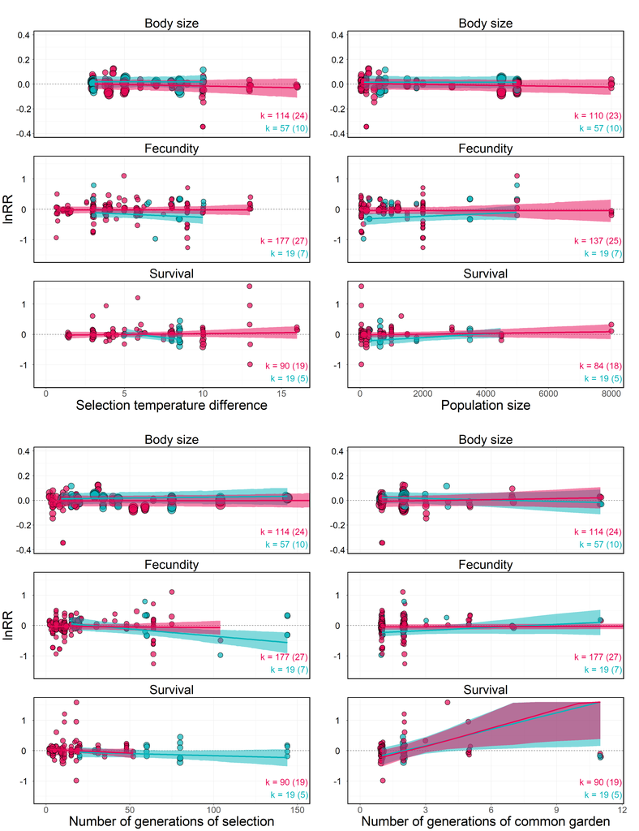

```r
(sel_temp_diff | pop_size) / (gen_selection | gen_common_garden)
```

```r
ggsave(file = "fig/figure_4.svg", width = 20, height = 26, dpi = 500)
```

## **Figure 5**

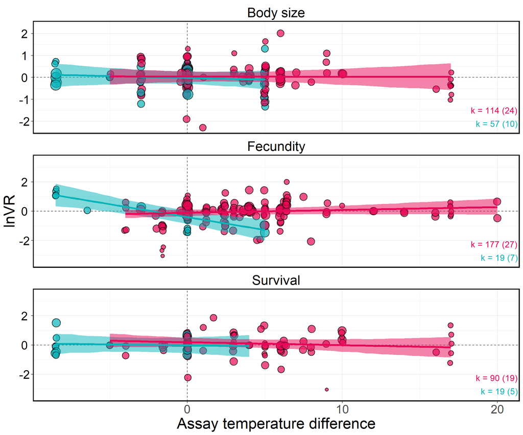

```r
# Load model
lnVR_model_assay_temp_diff <- readRDS("RData/lnVR_model_assay_temp_diff.rds")

# Generate predictions
emmeans_assay_temp_diff <- as.data.frame(emmeans(
  lnVR_model_assay_temp_diff,
  specs = ~ assay_temp_diff | trait_type * warm_cold,
  at = list(assay_temp_diff = seq(min(data$assay_temp_diff), max(data$assay_temp_diff), by = 0.5)))
  )

# Calculate range of values for each category
range_df <- data %>%
  group_by(trait_type, warm_cold) %>%
  summarize(
    min_assay_temp_diff = min(assay_temp_diff),
    max_assay_temp_diff = max(assay_temp_diff)
  )

emmeans_assay_temp_diff$trait_type <- factor(emmeans_assay_temp_diff$trait_type,
                          levels = c("body_size", "fecundity", "survival"),
                          labels = c("Body size", "Fecundity", "Survival"))

emmeans_assay_temp_diff$warm_cold <- factor(emmeans_assay_temp_diff$warm_cold,
                          levels = c("cold", "warm"),
                          labels = c("Cold", "Warm"))

# Tailor predictions to the range of the data
emmeans_assay_temp_diff <- emmeans_assay_temp_diff %>%
  left_join(range_df, by = c("trait_type", "warm_cold")) %>%
  filter(
    assay_temp_diff >= min_assay_temp_diff,
    assay_temp_diff <= max_assay_temp_diff
  )

# Plot
facet_limits_vr <- make_facet_limits(
  data_points = data,
  data_preds = emmeans_assay_temp_diff,
  y_point = "lnVR",
  y_lower = "lower.HPD",
  y_upper = "upper.HPD",
  buffer = 0.05,
  cap = 3.5
)

plot_data_vr <- clip_plot_data(
  data_points = data,
  data_preds = emmeans_assay_temp_diff,
  facet_limits = facet_limits_vr,
  y_point = "lnVR",
  y_mean = "emmean",
  y_lower = "lower.HPD",
  y_upper = "upper.HPD"
)

sample_sizes_vr <- make_sample_size_positions(
  sample_sizes_df = sample_sizes,
  facet_limits = facet_limits_vr
)

ggplot() +
  geom_blank(data = facet_limits_vr, aes(x = 0, y = ymin)) +
  geom_blank(data = facet_limits_vr, aes(x = 0, y = ymax)) +
  geom_hline(yintercept = 0, linetype = 2, colour = "black", alpha = 0.75) +
  geom_vline(xintercept = 0, linetype = 2, colour = "black", alpha = 0.75) +
  geom_point(
    data = plot_data_vr$points,
    aes(
      x = assay_temp_diff,
      y = lnVR,
      size = 1 / sqrt(var_lnVR),
      fill = warm_cold
    ),
    shape = 21,
    alpha = 0.7,
    stroke = 1,
    position = position_jitter(width = 0.05)
  ) +
  geom_ribbon(
    data = plot_data_vr$preds,
    aes(
      x = assay_temp_diff,
      ymin = y_lower_plot,
      ymax = y_upper_plot,
      fill = warm_cold,
      group = warm_cold
    ),
    alpha = .5
  ) +
  geom_line(
    data = plot_data_vr$preds,
    aes(
      y = y_mean_plot,
      x = assay_temp_diff,
      color = warm_cold,
      group = warm_cold
    ),
    size = 1.5
  ) +
  geom_text(
    data = sample_sizes_vr,
    aes(
      x = Inf,
      y = y,
      label = paste0("k = ", estimates, " (", studies, ")"),
      color = warm_cold
    ),
    hjust = 1.05,
    size = 5,
    show.legend = FALSE
  ) +
  facet_wrap(~ trait_type, ncol = 1, scales = "free_y") +
  scale_fill_manual(values = c("#06B4BA", "#E80756")) +
  scale_color_manual(values = c("#06B4BA", "#E80756")) +
  labs(
    x = "Assay temperature difference",
    y = "lnVR",
    col = "Regime"
  ) +
  theme_bw() +
  scale_size_continuous(range = c(2, 8)) +
  theme(
    text = element_text(size = 25, color = "black"),
    legend.title = ggplot2::element_text(size = 18),
    legend.text = ggplot2::element_text(size = 16),
    axis.text.y = ggplot2::element_text(size = 20, colour = "black", hjust = 0.5),
    axis.text.x = ggplot2::element_text(size = 20),
    panel.border = element_rect(color = "black", size = 1.5),
    strip.background = element_blank(),
    strip.text = element_text(color = "black", size = 22)
  ) +
  guides(fill = "none", col = "none", size = "none")
```

```r
ggsave(file = "fig/figure_5.svg", width = 10, height = 10, dpi = 500)
```

## **Figure 6**

```r
# Load models
lnVR_model_sel_temp_diff <- readRDS("RData/lnVR_model_sel_temp_diff.rds")
lnVR_model_gen_selection <- readRDS("RData/lnVR_model_gen_selection.rds")
lnVR_model_gen_common_garden <- readRDS("RData/lnVR_model_gen_common_garden.rds")
lnVR_model_pop_size <- readRDS("RData/lnVR_model_pop_size.rds")

# For figures
trait_levels_raw <- c("body_size", "fecundity", "survival")
trait_levels_lab <- c("Body size", "Fecundity", "Survival")

warm_levels_raw <- c("cold", "warm")
warm_levels_lab <- c("Cold", "Warm")

##################### Selection temperature ################################

data_plot <- data
sample_sizes_plot <- sample_sizes

# Generate predictions
emmeans_sel_temp_diff <- as.data.frame(
  emmeans(
    lnVR_model_sel_temp_diff,
    specs = ~ select_temp_diff | trait_type * warm_cold,
    at = list(
      select_temp_diff = seq(
        min(data$select_temp_diff, na.rm = TRUE),
        max(data$select_temp_diff, na.rm = TRUE),
        by = 0.1
      ),
      assay_temp_diff = 0
    )
  )
)

# Standardise labels in predictions
emmeans_sel_temp_diff <- emmeans_sel_temp_diff %>%
  dplyr::mutate(
    trait_type = factor(trait_type,
      levels = trait_levels_raw,
      labels = trait_levels_lab
    ),
    warm_cold = factor(warm_cold,
      levels = warm_levels_raw,
      labels = warm_levels_lab
    )
  )

# Calculate range of observed x values by facet/group
range_df_sel_temp_diff <- data_plot %>%
  dplyr::filter(!is.na(select_temp_diff)) %>%
  dplyr::group_by(trait_type, warm_cold) %>%
  dplyr::summarise(
    min_select_temp_diff = min(select_temp_diff, na.rm = TRUE),
    max_select_temp_diff = max(select_temp_diff, na.rm = TRUE),
    .groups = "drop"
  )

# Tailor predictions to observed x range
emmeans_sel_temp_diff <- emmeans_sel_temp_diff %>%
  dplyr::left_join(range_df_sel_temp_diff, by = c("trait_type", "warm_cold")) %>%
  dplyr::filter(
    select_temp_diff >= min_select_temp_diff,
    select_temp_diff <= max_select_temp_diff
  )

# Facet-specific y limits
facet_limits_sel_temp_diff <- make_facet_limits(
  data_points = data_plot %>% dplyr::filter(!is.na(select_temp_diff)),
  data_preds = emmeans_sel_temp_diff,
  y_point = "lnVR",
  y_lower = "lower.HPD",
  y_upper = "upper.HPD",
  buffer = 0.05,
  cap = 3.5
)

# Clip data to those limits
plot_data_sel_temp_diff <- clip_plot_data(
  data_points = data_plot %>% dplyr::filter(!is.na(select_temp_diff)),
  data_preds = emmeans_sel_temp_diff,
  facet_limits = facet_limits_sel_temp_diff,
  y_point = "lnVR",
  y_mean = "emmean",
  y_lower = "lower.HPD",
  y_upper = "upper.HPD"
)

# Sample size label positions
sample_sizes_sel_temp_diff <- make_sample_size_positions(
  sample_sizes_df = sample_sizes_plot,
  facet_limits = facet_limits_sel_temp_diff
)

sel_temp_diff <- ggplot() +
  geom_blank(data = facet_limits_sel_temp_diff, aes(x = 0, y = ymin)) +
  geom_blank(data = facet_limits_sel_temp_diff, aes(x = 0, y = ymax)) +
  geom_hline(yintercept = 0, linetype = 2, colour = "black", alpha = 0.75) +
  geom_point(
    data = plot_data_sel_temp_diff$points,
    aes(
      x = select_temp_diff,
      y = lnVR,
      size = 1 / sqrt(var_lnVR),
      fill = warm_cold
    ),
    shape = 21,
    alpha = 0.7,
    stroke = 1,
    position = position_jitter(width = 0.05)
  ) +
  geom_ribbon(
    data = plot_data_sel_temp_diff$preds,
    aes(
      x = select_temp_diff,
      ymin = y_lower_plot,
      ymax = y_upper_plot,
      fill = warm_cold,
      group = warm_cold
    ),
    alpha = 0.5
  ) +
  geom_line(
    data = plot_data_sel_temp_diff$preds,
    aes(
      x = select_temp_diff,
      y = y_mean_plot,
      colour = warm_cold,
      group = warm_cold
    ),
    size = 1.5
  ) +
  geom_text(
    data = sample_sizes_sel_temp_diff,
    aes(
      x = Inf,
      y = y,
      label = paste0("k = ", estimates, " (", studies, ")"),
      colour = warm_cold
    ),
    hjust = 1.05,
    size = 7,
    show.legend = FALSE
  ) +
  facet_wrap(~ trait_type, ncol = 1, scales = "free_y") +
  scale_fill_manual(values = c("#06B4BA", "#E80756")) +
  scale_color_manual(values = c("#06B4BA", "#E80756")) +
  labs(x = "Selection temperature difference", y = "lnVR", col = "Regime") +
  theme_bw() +
  scale_size_continuous(range = c(2, 8)) +
  theme(
    text = element_text(size = 30, color = "black"),
    legend.title = ggplot2::element_text(size = 18),
    legend.text = ggplot2::element_text(size = 16),
    axis.text.y = ggplot2::element_text(size = 20, colour = "black", hjust = 0.5),
    axis.text.x = ggplot2::element_text(size = 20),
    panel.border = element_rect(color = "black", size = 1.5),
    strip.background = element_blank(),
    strip.text = element_text(color = "black", size = 28),
    plot.margin = unit(c(1, 0, 0, 0), "cm")
  ) +
  guides(fill = "none", size = "none", color = "none")

############### Number of generations of selection ################

emmeans_gen_selection <- as.data.frame(
  emmeans(
    lnVR_model_gen_selection,
    specs = ~ gen_selection | trait_type * warm_cold,
    at = list(
      gen_selection = seq(
        min(data$gen_selection, na.rm = TRUE),
        max(data$gen_selection, na.rm = TRUE),
        by = 1
      ),
      assay_temp_diff = 0
    )
  )
)

emmeans_gen_selection <- emmeans_gen_selection %>%
  dplyr::mutate(
    trait_type = factor(trait_type,
      levels = trait_levels_raw,
      labels = trait_levels_lab
    ),
    warm_cold = factor(warm_cold,
      levels = warm_levels_raw,
      labels = warm_levels_lab
    )
  )

range_df_gen_selection <- data_plot %>%
  dplyr::filter(!is.na(gen_selection)) %>%
  dplyr::group_by(trait_type, warm_cold) %>%
  dplyr::summarise(
    min_gen_selection = min(gen_selection, na.rm = TRUE),
    max_gen_selection = max(gen_selection, na.rm = TRUE),
    .groups = "drop"
  )

emmeans_gen_selection <- emmeans_gen_selection %>%
  dplyr::left_join(range_df_gen_selection, by = c("trait_type", "warm_cold")) %>%
  dplyr::filter(
    gen_selection >= min_gen_selection,
    gen_selection <= max_gen_selection
  )
```

```r
facet_limits_gen_selection <- make_facet_limits(
  data_points = data_plot %>% dplyr::filter(!is.na(gen_selection)),
  data_preds = emmeans_gen_selection,
  y_point = "lnVR",
  y_lower = "lower.HPD",
  y_upper = "upper.HPD",
  buffer = 0.05,
  cap = 3.5
)

plot_data_gen_selection <- clip_plot_data(
  data_points = data_plot %>% dplyr::filter(!is.na(gen_selection)),
  data_preds = emmeans_gen_selection,
  facet_limits = facet_limits_gen_selection,
  y_point = "lnVR",
  y_mean = "emmean",
  y_lower = "lower.HPD",
  y_upper = "upper.HPD"
)

sample_sizes_gen_selection <- make_sample_size_positions(
  sample_sizes_df = sample_sizes_plot,
  facet_limits = facet_limits_gen_selection
)

gen_selection <- ggplot() +
  geom_blank(data = facet_limits_gen_selection, aes(x = 0, y = ymin)) +
  geom_blank(data = facet_limits_gen_selection, aes(x = 0, y = ymax)) +
  geom_hline(yintercept = 0, linetype = 2, colour = "black", alpha = 0.75) +
  geom_point(
    data = plot_data_gen_selection$points,
    aes(
      x = gen_selection,
      y = lnVR,
      size = 1 / sqrt(var_lnVR),
      fill = warm_cold
    ),
    shape = 21,
    alpha = 0.7,
    stroke = 1,
    position = position_jitter(width = 0.05)
  ) +
  geom_ribbon(
    data = plot_data_gen_selection$preds,
    aes(
      x = gen_selection,
      ymin = y_lower_plot,
      ymax = y_upper_plot,
      fill = warm_cold,
      group = warm_cold
    ),
    alpha = 0.5
  ) +
  geom_line(
    data = plot_data_gen_selection$preds,
    aes(
      x = gen_selection,
      y = y_mean_plot,
      colour = warm_cold,
      group = warm_cold
    ),
    size = 1.5
  ) +
  geom_text(
    data = sample_sizes_gen_selection,
    aes(
      x = Inf,
      y = y,
      label = paste0("k = ", estimates, " (", studies, ")"),
      colour = warm_cold
    ),
    hjust = 1.05,
    size = 7,
    show.legend = FALSE
  ) +
  facet_wrap(~ trait_type, ncol = 1, scales = "free_y") +
  scale_fill_manual(values = c("#06B4BA", "#E80756")) +
  scale_color_manual(values = c("#06B4BA", "#E80756")) +
  labs(x = "Number of generations of selection", y = "lnVR", col = "Regime") +
  theme_bw() +
  scale_size_continuous(range = c(2, 8)) +
  theme(
    text = element_text(size = 30, color = "black"),
    legend.title = ggplot2::element_text(size = 18),
    legend.text = ggplot2::element_text(size = 16),
    axis.text.y = ggplot2::element_text(size = 20, colour = "black", hjust = 0.5),
    axis.text.x = ggplot2::element_text(size = 20),
    panel.border = element_rect(color = "black", size = 1.5),
    strip.background = element_blank(),
    strip.text = element_text(color = "black", size = 28),
    plot.margin = unit(c(1.5, 0, 0, 0), "cm")
  ) +
  guides(fill = "none", size = "none", color = "none") +
  coord_cartesian(xlim = c(0, 150))


############# Number of generations of common garden ####################

emmeans_gen_common_garden <- as.data.frame(
  emmeans(
    lnVR_model_gen_common_garden,
    specs = ~ gen_common_garden | trait_type * warm_cold,
    at = list(
      gen_common_garden = seq(
        min(data$gen_common_garden, na.rm = TRUE),
        max(data$gen_common_garden, na.rm = TRUE),
        by = 1
      ),
      assay_temp_diff = 0
    )
  )
)

emmeans_gen_common_garden <- emmeans_gen_common_garden %>%
  dplyr::mutate(
    trait_type = factor(trait_type,
      levels = trait_levels_raw,
      labels = trait_levels_lab
    ),
    warm_cold = factor(warm_cold,
      levels = warm_levels_raw,
      labels = warm_levels_lab
    )
  )

range_df_gen_common_garden <- data_plot %>%
  dplyr::filter(!is.na(gen_common_garden)) %>%
  dplyr::group_by(trait_type, warm_cold) %>%
  dplyr::summarise(
    min_gen_common_garden = min(gen_common_garden, na.rm = TRUE),
    max_gen_common_garden = max(gen_common_garden, na.rm = TRUE),
    .groups = "drop"
  )

emmeans_gen_common_garden <- emmeans_gen_common_garden %>%
  dplyr::left_join(range_df_gen_common_garden, by = c("trait_type", "warm_cold")) %>%
  dplyr::filter(
    gen_common_garden >= min_gen_common_garden,
    gen_common_garden <= max_gen_common_garden
  )

facet_limits_gen_common_garden <- make_facet_limits(
  data_points = data_plot %>% dplyr::filter(!is.na(gen_common_garden)),
  data_preds = emmeans_gen_common_garden,
  y_point = "lnVR",
  y_lower = "lower.HPD",
  y_upper = "upper.HPD",
  buffer = 0.05,
  cap = 3.5
)

plot_data_gen_common_garden <- clip_plot_data(
  data_points = data_plot %>% dplyr::filter(!is.na(gen_common_garden)),
  data_preds = emmeans_gen_common_garden,
  facet_limits = facet_limits_gen_common_garden,
  y_point = "lnVR",
  y_mean = "emmean",
  y_lower = "lower.HPD",
  y_upper = "upper.HPD"
)

sample_sizes_gen_common_garden <- make_sample_size_positions(
  sample_sizes_df = sample_sizes_plot,
  facet_limits = facet_limits_gen_common_garden
)

gen_common_garden <- ggplot() +
  geom_blank(data = facet_limits_gen_common_garden, aes(x = 0, y = ymin)) +
  geom_blank(data = facet_limits_gen_common_garden, aes(x = 0, y = ymax)) +
  geom_hline(yintercept = 0, linetype = 2, colour = "black", alpha = 0.75) +
  geom_point(
    data = plot_data_gen_common_garden$points,
    aes(
      x = gen_common_garden,
      y = lnVR,
      size = 1 / sqrt(var_lnVR),
      fill = warm_cold
    ),
    shape = 21,
    alpha = 0.7,
    stroke = 1,
    position = position_jitter(width = 0.05)
  ) +
  geom_ribbon(
    data = plot_data_gen_common_garden$preds,
    aes(
      x = gen_common_garden,
      ymin = y_lower_plot,
      ymax = y_upper_plot,
      fill = warm_cold,
      group = warm_cold
    ),
    alpha = 0.5
  ) +
  geom_line(
    data = plot_data_gen_common_garden$preds,
    aes(
      x = gen_common_garden,
      y = y_mean_plot,
      colour = warm_cold,
      group = warm_cold
    ),
    size = 1.5
  ) +
  geom_text(
    data = sample_sizes_gen_common_garden,
    aes(
      x = Inf,
      y = y,
      label = paste0("k = ", estimates, " (", studies, ")"),
      colour = warm_cold
    ),
    hjust = 1.05,
    size = 7,
    show.legend = FALSE
  ) +
  facet_wrap(~ trait_type, ncol = 1, scales = "free_y") +
  scale_fill_manual(values = c("#06B4BA", "#E80756")) +
  scale_color_manual(values = c("#06B4BA", "#E80756")) +
  labs(x = "Number of generations of common garden", y = "", col = "Regime") +
  theme_bw() +
  scale_size_continuous(range = c(2, 8)) +
  theme(
    text = element_text(size = 30, color = "black"),
    legend.title = ggplot2::element_text(size = 18),
    legend.text = ggplot2::element_text(size = 16),
    axis.text.y = ggplot2::element_text(size = 20, colour = "black", hjust = 0.5),
    axis.text.x = ggplot2::element_text(size = 20),
    panel.border = element_rect(color = "black", size = 1.5),
    strip.background = element_blank(),
    strip.text = element_text(color = "black", size = 28),
    plot.margin = unit(c(1.5, 1, 0, 0.5), "cm")
  ) +
  guides(fill = "none", size = "none", color = "none") +
  coord_cartesian(xlim = c(0, 11.5))
```

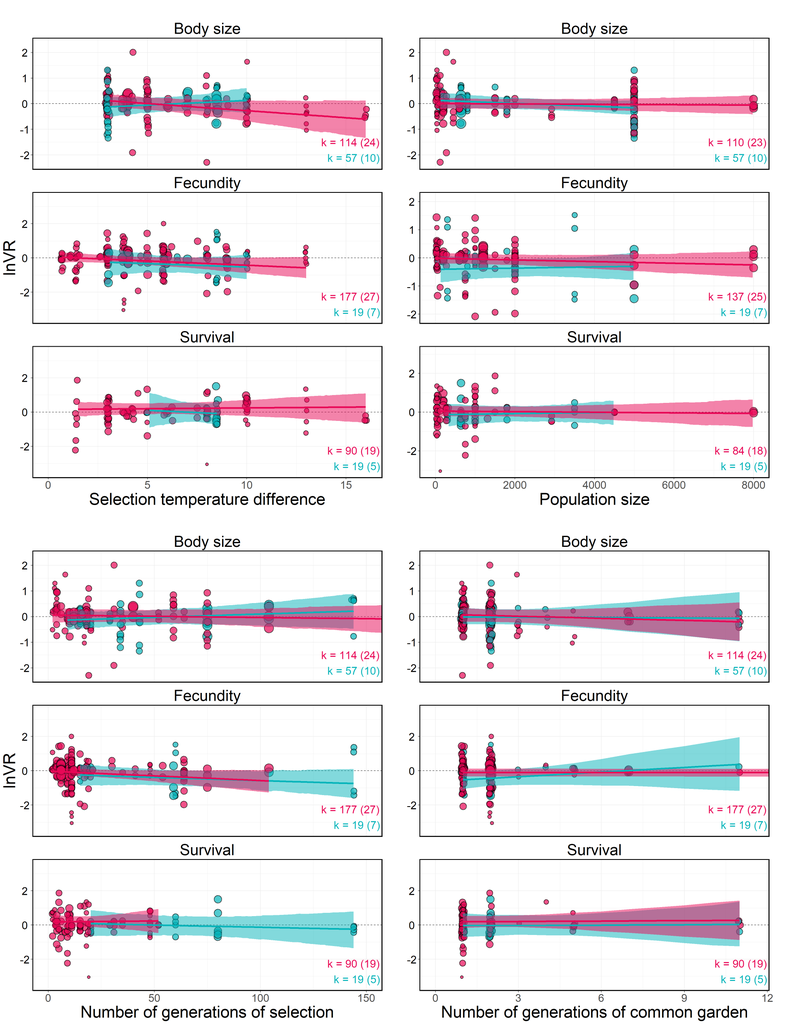

```r
############# Population size ####################

emmeans_pop_size <- as.data.frame(
  emmeans(
    lnVR_model_pop_size,
    specs = ~ pop_size | trait_type * warm_cold,
    at = list(
      pop_size = seq(
        min(data$pop_size, na.rm = TRUE),
        max(data$pop_size, na.rm = TRUE),
        by = 50
      ),
      assay_temp_diff = 0
    )
  )
)

emmeans_pop_size <- emmeans_pop_size %>%
  dplyr::mutate(
    trait_type = factor(trait_type,
      levels = trait_levels_raw,
      labels = trait_levels_lab
    ),
    warm_cold = factor(warm_cold,
      levels = warm_levels_raw,
      labels = warm_levels_lab
    )
  )

range_df_pop_size <- data_plot %>%
  dplyr::filter(!is.na(pop_size)) %>%
  dplyr::group_by(trait_type, warm_cold) %>%
  dplyr::summarise(
    min_pop_size = min(pop_size, na.rm = TRUE),
    max_pop_size = max(pop_size, na.rm = TRUE),
    .groups = "drop"
  )

emmeans_pop_size <- emmeans_pop_size %>%
  dplyr::left_join(range_df_pop_size, by = c("trait_type", "warm_cold")) %>%
  dplyr::filter(
    pop_size >= min_pop_size,
    pop_size <= max_pop_size
  )

sample_sizes_pop_size <- data_plot %>%
  dplyr::filter(!is.na(pop_size)) %>%
  dplyr::group_by(trait_type, warm_cold) %>%
  dplyr::summarise(
    estimates = dplyr::n(),
    studies = dplyr::n_distinct(ref),
    .groups = "drop"
  )

facet_limits_pop_size <- make_facet_limits(
  data_points = data_plot %>% dplyr::filter(!is.na(pop_size)),
  data_preds = emmeans_pop_size,
  y_point = "lnVR",
  y_lower = "lower.HPD",
  y_upper = "upper.HPD",
  buffer = 0.05,
  cap = 3.5
)

plot_data_pop_size <- clip_plot_data(
  data_points = data_plot %>% dplyr::filter(!is.na(pop_size)),
  data_preds = emmeans_pop_size,
  facet_limits = facet_limits_pop_size,
  y_point = "lnVR",
  y_mean = "emmean",
  y_lower = "lower.HPD",
  y_upper = "upper.HPD"
)

sample_sizes_pop_size_pos <- make_sample_size_positions(
  sample_sizes_df = sample_sizes_pop_size,
  facet_limits = facet_limits_pop_size
)

pop_size <- ggplot() +
  geom_blank(data = facet_limits_pop_size, aes(x = 0, y = ymin)) +
  geom_blank(data = facet_limits_pop_size, aes(x = 0, y = ymax)) +
  geom_hline(yintercept = 0, linetype = 2, colour = "black", alpha = 0.75) +
  geom_point(
    data = plot_data_pop_size$points,
    aes(
      x = pop_size,
      y = lnVR,
      size = 1 / sqrt(var_lnVR),
      fill = warm_cold
    ),
    shape = 21,
    alpha = 0.7,
    stroke = 1,
    position = position_jitter(width = 0.05)
  ) +
  geom_ribbon(
    data = plot_data_pop_size$preds,
    aes(
      x = pop_size,
      ymin = y_lower_plot,
      ymax = y_upper_plot,
      fill = warm_cold,
      group = warm_cold
    ),
    alpha = 0.5
  ) +
  geom_line(
    data = plot_data_pop_size$preds,
    aes(
      x = pop_size,
      y = y_mean_plot,
      colour = warm_cold,
      group = warm_cold
    ),
    size = 1.5
  ) +
  geom_text(
    data = sample_sizes_pop_size_pos,
    aes(
      x = Inf,
      y = y,
      label = paste0("k = ", estimates, " (", studies, ")"),
      colour = warm_cold
    ),
    hjust = 1.05,
    size = 7,
    show.legend = FALSE
  ) +
  facet_wrap(~ trait_type, ncol = 1, scales = "free_y") +
  scale_fill_manual(values = c("#06B4BA", "#E80756")) +
  scale_color_manual(values = c("#06B4BA", "#E80756")) +
  labs(x = "Population size", y = "", col = "Regime") +
  theme_bw() +
  scale_size_continuous(range = c(2, 8)) +
  theme(
    text = element_text(size = 30, color = "black"),
    legend.title = ggplot2::element_text(size = 18),
    legend.text = ggplot2::element_text(size = 16),
    axis.text.y = ggplot2::element_text(size = 20, colour = "black", hjust = 0.5),
    axis.text.x = ggplot2::element_text(size = 20),
    panel.border = element_rect(color = "black", size = 1.5),
    strip.background = element_blank(),
    strip.text = element_text(color = "black", size = 28),
    plot.margin = unit(c(0, 1, 0, 0.5), "cm")
  ) +
  guides(fill = "none", size = "none", color = "none")

(sel_temp_diff | pop_size) / (gen_selection | gen_common_garden)
```

```r
ggsave(file = "fig/figure_6.svg", width = 20, height = 26, dpi = 400)
```

# **Supplementary figures**

Figure S1 and S2 were made in Powerpoint.

## **Figure S3**

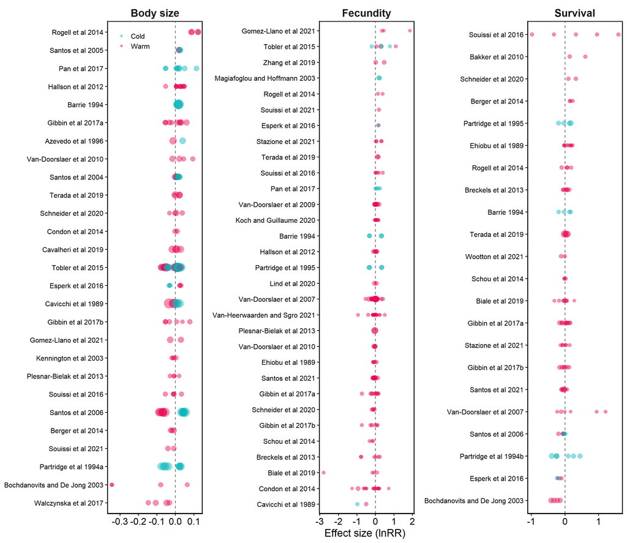

```r
# Prepare data
plot_dat <- data %>%
  dplyr::mutate(
    precision = 1 / sqrt(var_lnRR),
    weight = 1 / var_lnRR,
    warm_cold = factor(warm_cold, levels = c("Cold", "Warm")),
    trait_type = factor(trait_type, levels = c("Body size", "Fecundity", "Survival")),
    ref = gsub("_", " ", ref)
  )
# Calculate weighted mean lnRR and 95% CI
#   within each study, trait, and temperature regime
study_sum <- plot_dat %>%
  dplyr::group_by(trait_type, ref, warm_cold) %>%
  dplyr::summarise(
    mean_lnRR = sum(lnRR * weight) / sum(weight),
    se_lnRR   = sqrt(1 / sum(weight)),
    lower_CI  = mean_lnRR - 1.96 * se_lnRR,
    upper_CI  = mean_lnRR + 1.96 * se_lnRR,
    k         = dplyr::n(),
    .groups = "drop"
  ) %>%
  as.data.frame()

# Order studies within each trait
#    using the average study effect across warm/cold
study_order <- study_sum %>%
  dplyr::group_by(trait_type, ref) %>%
  dplyr::summarise(
    order_value = mean(mean_lnRR, na.rm = TRUE),
    .groups = "drop"
  ) %>%
  as.data.frame()

# Order studies by magnitude
study_sum <- study_sum %>%
  dplyr::left_join(study_order, by = c("trait_type", "ref")) %>%
  dplyr::mutate(
    ref_facet = tidytext::reorder_within(ref, order_value, trait_type)
  )

plot_dat <- plot_dat %>%
  dplyr::left_join(study_order, by = c("trait_type", "ref")) %>%
  dplyr::mutate(
    ref_facet = tidytext::reorder_within(ref, order_value, trait_type)
  )

# Plot
p <- ggplot() +
  geom_vline(xintercept = 0, linetype = "dashed", colour = "grey40") +
  ggbeeswarm::geom_quasirandom(
    data = plot_dat,
    aes(
      x = lnRR,
      y = ref_facet,
      colour = warm_cold,
      fill = warm_cold,
      size = precision
    ),
    groupOnX = FALSE,
    width = 0.22,
    alpha = 0.45,
    shape = 21,
    stroke = 0.2,
    orientation = "x"
  ) +
  facet_wrap(~trait_type, ncol = 3, scales = "free") +
  tidytext::scale_y_reordered() +
  scale_fill_manual(values = c("#06B4BA", "#E80756")) +
  scale_color_manual(values = c("#06B4BA", "#E80756")) +
  scale_size_continuous(range = c(2.5, 8), guide = "none") +
  labs(
    x = "Effect size (lnRR)",
    y = NULL,
    colour = NULL,
    fill = NULL
  ) +
theme_classic(base_size = 15) +
theme(
  strip.background = element_blank(),
  strip.text = element_text(face = "bold", size = 18),
  axis.text.x = element_text(size = 16),
  axis.text.y = element_text(size = 12,hjust = 1),
  axis.title.x = element_text(size = 18),
  panel.border = element_rect(colour = "black", fill = NA, linewidth = 1.2),
  legend.position = c(0.05,0.96),
  panel.spacing = unit(1.2, "lines")
)

p
```

```r
ggsave("fig/figure_S3.png", height = 13, width = 15, dpi = 500)
```

## **Figure S4**

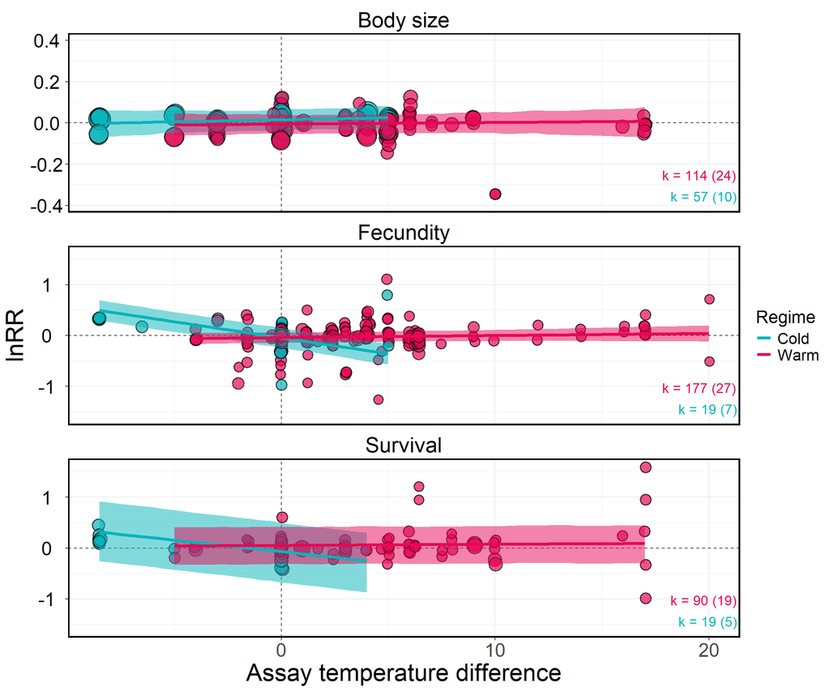

```r
# Load model
lnRR_model_all_moderators <- readRDS("RData/lnRR_model_all_moderators.rds")

# Generate predictions
emmeans_full_model <- as.data.frame(emmeans(
  lnRR_model_all_moderators,
  specs = ~ assay_temp_diff * select_temp_diff * gen_selection * gen_common_garden | trait_type * warm_cold,
   at = list(assay_temp_diff = seq(min(data$assay_temp_diff), max(data$assay_temp_diff), by = 0.5))))

# Calculate range of values for each category
range_df <- data %>%
  group_by(trait_type, warm_cold) %>%
  summarize(
    min_assay_temp_diff = min(assay_temp_diff, na.rm = TRUE),
    max_assay_temp_diff = max(assay_temp_diff, na.rm = TRUE),
    .groups = "drop"
  )

# Match emmeans coding to whatever is already in data
emmeans_full_model$trait_type <- factor(
  emmeans_full_model$trait_type,
  levels = c("body_size", "fecundity", "survival"),
  labels = c("Body size", "Fecundity", "Survival")
)

emmeans_full_model$warm_cold <- factor(
  emmeans_full_model$warm_cold,
  levels = c("cold", "warm"),
  labels = c("Cold", "Warm")
)

# Tailor predictions to the range of the data
emmeans_full_model<- emmeans_full_model %>%
  left_join(range_df, by = c("trait_type", "warm_cold")) %>%
  filter(
    assay_temp_diff >= min_assay_temp_diff,
    assay_temp_diff <= max_assay_temp_diff
  )

# Plot objects using helper functions
facet_limits_rr <- make_facet_limits(
  data_points = data,
  data_preds = emmeans_full_model,
  y_point = "lnRR",
  y_lower = "lower.HPD",
  y_upper = "upper.HPD",
  buffer = 0.05,
  cap = 1.6
)

plot_data_rr <- clip_plot_data(
  data_points = data,
  data_preds = emmeans_full_model,
  facet_limits = facet_limits_rr,
  y_point = "lnRR",
  y_mean = "emmean",
  y_lower = "lower.HPD",
  y_upper = "upper.HPD"
)

sample_sizes_rr <- make_sample_size_positions(
  sample_sizes_df = sample_sizes,
  facet_limits = facet_limits_rr
)

ggplot() +
  geom_blank(data = facet_limits_rr, aes(x = 0, y = ymin)) +
  geom_blank(data = facet_limits_rr, aes(x = 0, y = ymax)) +
  geom_hline(yintercept = 0, linetype = 2, colour = "black", alpha = 0.75) +
  geom_vline(xintercept = 0, linetype = 2, colour = "black", alpha = 0.75) +
  geom_point(
    data = plot_data_rr$points,
    aes(
      x = assay_temp_diff,
      y = lnRR,
      size = 1 / sqrt(var_lnRR),
      fill = warm_cold
    ),
    shape = 21,
    alpha = 0.7,
    stroke = 1,
    position = position_jitter(width = 0.05)
  ) +
  geom_ribbon(
    data = plot_data_rr$preds,
    aes(
      x = assay_temp_diff,
      ymin = y_lower_plot,
      ymax = y_upper_plot,
      fill = warm_cold,
      group = warm_cold
    ),
    alpha = .5
  ) +
  geom_line(
    data = plot_data_rr$preds,
    aes(
      y = y_mean_plot,
      x = assay_temp_diff,
      color = warm_cold,
      group = warm_cold
    ),
    size = 1.5
  ) +
  geom_text(
    data = sample_sizes_rr,
    aes(
      x = Inf,
      y = y,
      label = paste0("k = ", estimates, " (", studies, ")"),
      color = warm_cold
    ),
    hjust = 1.05,
    size = 5,
    show.legend = FALSE
  ) +
  facet_wrap(~ trait_type, ncol = 1, scales = "free_y") +
  scale_fill_manual(values = c("#06B4BA", "#E80756")) +
  scale_color_manual(values = c("#06B4BA", "#E80756")) +
  labs(
    x = "Assay temperature difference",
    y = "lnRR",
    col = "Regime"
  ) +
  theme_bw() +
  scale_size_continuous(range = c(4, 10)) +
  theme(
    text = element_text(size = 25, color = "black"),
    legend.title = ggplot2::element_text(size = 18),
    legend.text = ggplot2::element_text(size = 16),
    axis.text.y = ggplot2::element_text(size = 20, colour = "black", hjust = 0.5),
    axis.text.x = ggplot2::element_text(size = 20),
    panel.border = element_rect(color = "black", size = 1.5),
    strip.background = element_blank(),
    strip.text = element_text(color = "black", size = 22)
  ) +
  guides(fill = "none",  size = "none")
```

```r
ggsave(file = "fig/figure_S4.png", width = 12, height = 10, dpi = 500)
```

## **Figure S5**

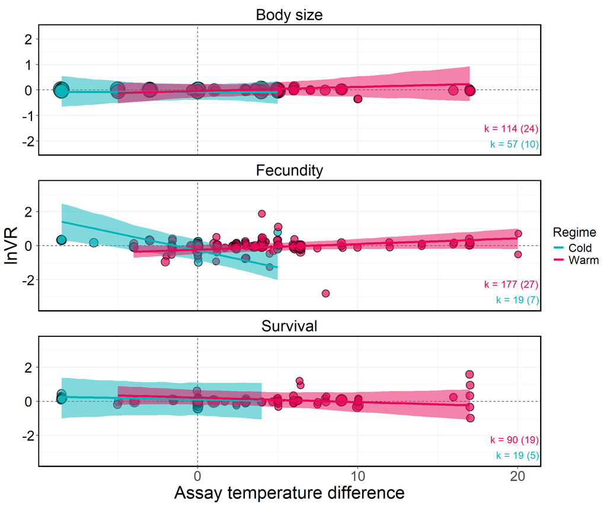

```r
# Load models
lnVR_model_all_moderators <- readRDS("RData/lnVR_model_all_moderators.rds")

# Generate predictions
emmeans_full_model <- as.data.frame(emmeans(
  lnVR_model_all_moderators,
  specs = ~ assay_temp_diff * select_temp_diff * gen_selection * gen_common_garden | trait_type * warm_cold,
   at = list(assay_temp_diff = seq(min(data$assay_temp_diff), max(data$assay_temp_diff), by = 0.5))))

# Calculate range of values for each category
range_df <- data %>%
  group_by(trait_type, warm_cold) %>%
  summarize(
    min_assay_temp_diff = min(assay_temp_diff, na.rm = TRUE),
    max_assay_temp_diff = max(assay_temp_diff, na.rm = TRUE),
    .groups = "drop"
  )

# Match emmeans coding to whatever is already in data
emmeans_full_model$trait_type <- factor(
  emmeans_full_model$trait_type,
  levels = c("body_size", "fecundity", "survival"),
  labels = c("Body size", "Fecundity", "Survival")
)

emmeans_full_model$warm_cold <- factor(
  emmeans_full_model$warm_cold,
  levels = c("cold", "warm"),
  labels = c("Cold", "Warm")
)

# Tailor predictions to the range of the data
emmeans_full_model<- emmeans_full_model %>%
  left_join(range_df, by = c("trait_type", "warm_cold")) %>%
  filter(
    assay_temp_diff >= min_assay_temp_diff,
    assay_temp_diff <= max_assay_temp_diff
  )

# Plot objects using helper functions
facet_limits_vr <- make_facet_limits(
  data_points = data,
  data_preds = emmeans_full_model,
  y_point = "lnVR",
  y_lower = "lower.HPD",
  y_upper = "upper.HPD",
  buffer = 0.05,
  cap = 3.5
)

plot_data_vr <- clip_plot_data(
  data_points = data,
  data_preds = emmeans_full_model,
  facet_limits = facet_limits_vr,
  y_point = "lnRR",
  y_mean = "emmean",
  y_lower = "lower.HPD",
  y_upper = "upper.HPD"
)

sample_sizes_vr <- make_sample_size_positions(
  sample_sizes_df = sample_sizes,
  facet_limits = facet_limits_vr
)

ggplot() +
  geom_blank(data = facet_limits_vr, aes(x = 0, y = ymin)) +
  geom_blank(data = facet_limits_vr, aes(x = 0, y = ymax)) +
  geom_hline(yintercept = 0, linetype = 2, colour = "black", alpha = 0.75) +
  geom_vline(xintercept = 0, linetype = 2, colour = "black", alpha = 0.75) +
  geom_point(
    data = plot_data_vr$points,
    aes(
      x = assay_temp_diff,
      y = lnRR,
      size = 1 / sqrt(var_lnRR),
      fill = warm_cold
    ),
    shape = 21,
    alpha = 0.7,
    stroke = 1,
    position = position_jitter(width = 0.05)
  ) +
  geom_ribbon(
    data = plot_data_vr$preds,
    aes(
      x = assay_temp_diff,
      ymin = y_lower_plot,
      ymax = y_upper_plot,
      fill = warm_cold,
      group = warm_cold
    ),
    alpha = .5
  ) +
  geom_line(
    data = plot_data_vr$preds,
    aes(
      y = y_mean_plot,
      x = assay_temp_diff,
      color = warm_cold,
      group = warm_cold
    ),
    size = 1.5
  ) +
  geom_text(
    data = sample_sizes_vr,
    aes(
      x = Inf,
      y = y,
      label = paste0("k = ", estimates, " (", studies, ")"),
      color = warm_cold
    ),
    hjust = 1.05,
    size = 5,
    show.legend = FALSE
  ) +
  facet_wrap(~ trait_type, ncol = 1, scales = "free_y") +
  scale_fill_manual(values = c("#06B4BA", "#E80756")) +
  scale_color_manual(values = c("#06B4BA", "#E80756")) +
  labs(
    x = "Assay temperature difference",
    y = "lnVR",
    col = "Regime"
  ) +
  theme_bw() +
  scale_size_continuous(range = c(4, 10)) +
  theme(
    text = element_text(size = 25, color = "black"),
    legend.title = ggplot2::element_text(size = 18),
    legend.text = ggplot2::element_text(size = 16),
    axis.text.y = ggplot2::element_text(size = 20, colour = "black", hjust = 0.5),
    axis.text.x = ggplot2::element_text(size = 20),
    panel.border = element_rect(color = "black", size = 1.5),
    strip.background = element_blank(),
    strip.text = element_text(color = "black", size = 22)
  ) +
  guides(fill = "none", size = "none")
```

```r
ggsave(file = "fig/figure_S5.png", width = 12, height = 10, dpi = 500)
```

## **Figure S6**

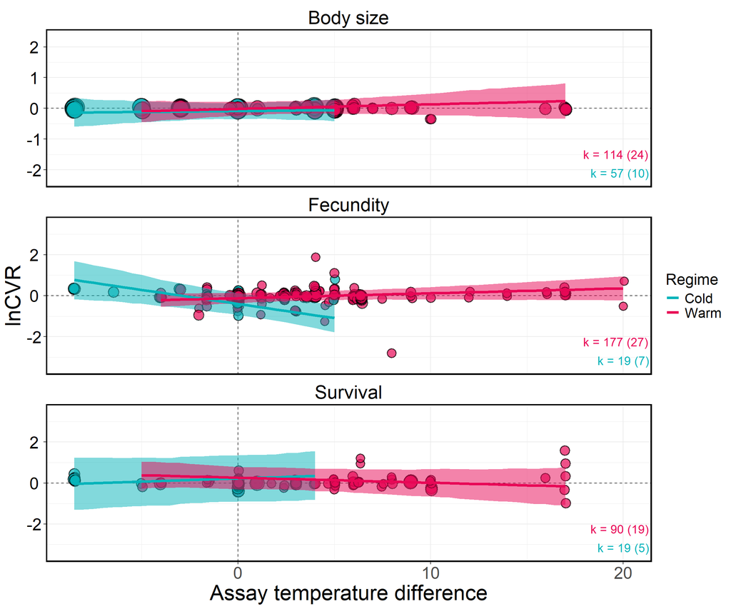

```r
# Load models
lnCVR_model_all_moderators <- readRDS("RData/lnCVR_model_all_moderators.rds")

# Generate predictions
emmeans_full_model <- as.data.frame(emmeans(
  lnCVR_model_all_moderators,
  specs = ~ assay_temp_diff * select_temp_diff * gen_selection * gen_common_garden | trait_type * warm_cold,
   at = list(assay_temp_diff = seq(min(data$assay_temp_diff), max(data$assay_temp_diff), by = 0.5))))

# Calculate range of values for each category
range_df <- data %>%
  group_by(trait_type, warm_cold) %>%
  summarize(
    min_assay_temp_diff = min(assay_temp_diff, na.rm = TRUE),
    max_assay_temp_diff = max(assay_temp_diff, na.rm = TRUE),
    .groups = "drop"
  )

# Match emmeans coding to whatever is already in data
emmeans_full_model$trait_type <- factor(
  emmeans_full_model$trait_type,
  levels = c("body_size", "fecundity", "survival"),
  labels = c("Body size", "Fecundity", "Survival")
)

emmeans_full_model$warm_cold <- factor(
  emmeans_full_model$warm_cold,
  levels = c("cold", "warm"),
  labels = c("Cold", "Warm")
)

# Tailor predictions to the range of the data
emmeans_full_model<- emmeans_full_model %>%
  left_join(range_df, by = c("trait_type", "warm_cold")) %>%
  filter(
    assay_temp_diff >= min_assay_temp_diff,
    assay_temp_diff <= max_assay_temp_diff
  )

# Plot objects using helper functions
facet_limits_cvr <- make_facet_limits(
  data_points = data,
  data_preds = emmeans_full_model,
  y_point = "lnCVR",
  y_lower = "lower.HPD",
  y_upper = "upper.HPD",
  buffer = 0.05,
  cap = 3.5
)

plot_data_cvr <- clip_plot_data(
  data_points = data,
  data_preds = emmeans_full_model,
  facet_limits = facet_limits_cvr,
  y_point = "lnRR",
  y_mean = "emmean",
  y_lower = "lower.HPD",
  y_upper = "upper.HPD"
)

sample_sizes_cvr <- make_sample_size_positions(
  sample_sizes_df = sample_sizes,
  facet_limits = facet_limits_cvr
)

ggplot() +
  geom_blank(data = facet_limits_cvr, aes(x = 0, y = ymin)) +
  geom_blank(data = facet_limits_cvr, aes(x = 0, y = ymax)) +
  geom_hline(yintercept = 0, linetype = 2, colour = "black", alpha = 0.75) +
  geom_vline(xintercept = 0, linetype = 2, colour = "black", alpha = 0.75) +
  geom_point(
    data = plot_data_cvr$points,
    aes(
      x = assay_temp_diff,
      y = lnRR,
      size = 1 / sqrt(var_lnRR),
      fill = warm_cold
    ),
    shape = 21,
    alpha = 0.7,
    stroke = 1,
    position = position_jitter(width = 0.05)
  ) +
  geom_ribbon(
    data = plot_data_cvr$preds,
    aes(
      x = assay_temp_diff,
      ymin = y_lower_plot,
      ymax = y_upper_plot,
      fill = warm_cold,
      group = warm_cold
    ),
    alpha = .5
  ) +
  geom_line(
    data = plot_data_cvr$preds,
    aes(
      y = y_mean_plot,
      x = assay_temp_diff,
      color = warm_cold,
      group = warm_cold
    ),
    size = 1.5
  ) +
  geom_text(
    data = sample_sizes_cvr,
    aes(
      x = Inf,
      y = y,
      label = paste0("k = ", estimates, " (", studies, ")"),
      color = warm_cold
    ),
    hjust = 1.05,
    size = 5,
    show.legend = FALSE
  ) +
  facet_wrap(~ trait_type, ncol = 1, scales = "free_y") +
  scale_fill_manual(values = c("#06B4BA", "#E80756")) +
  scale_color_manual(values = c("#06B4BA", "#E80756")) +
  labs(
    x = "Assay temperature difference",
    y = "lnCVR",
    col = "Regime"
  ) +
  theme_bw() +
  scale_size_continuous(range = c(4, 10)) +
  theme(
    text = element_text(size = 25, color = "black"),
    legend.title = ggplot2::element_text(size = 18),
    legend.text = ggplot2::element_text(size = 16),
    axis.text.y = ggplot2::element_text(size = 20, colour = "black", hjust = 0.5),
    axis.text.x = ggplot2::element_text(size = 20),
    panel.border = element_rect(color = "black", size = 1.5),
    strip.background = element_blank(),
    strip.text = element_text(color = "black", size = 22)
  ) +
  guides(fill = "none",  size = "none")
```

```r
ggsave(file = "fig/figure_S6.png", width = 12, height = 10, dpi = 500)
```

## **Figure S7**

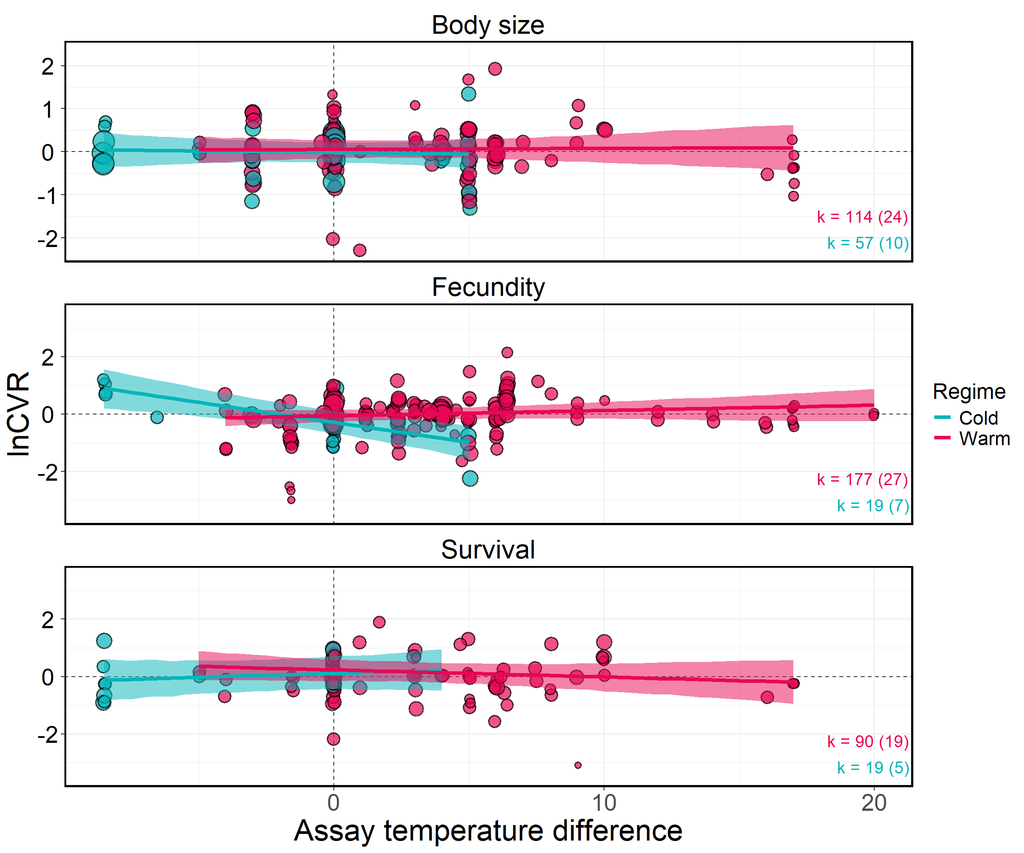

```r
# Load model
lnCVR_model_assay_temp_diff <- readRDS("RData/lnCVR_model_assay_temp_diff.rds")

# Generate predictions
emmeans_assay_temp_diff <- as.data.frame(emmeans(
  lnCVR_model_assay_temp_diff,
  specs = ~ assay_temp_diff | trait_type * warm_cold,
  at = list(assay_temp_diff = seq(min(data$assay_temp_diff), max(data$assay_temp_diff), by = 0.5)))
  )

# Calculate range of values for each category
range_df <- data %>%
  group_by(trait_type, warm_cold) %>%
  summarize(
    min_assay_temp_diff = min(assay_temp_diff),
    max_assay_temp_diff = max(assay_temp_diff)
  )

emmeans_assay_temp_diff$trait_type <- factor(emmeans_assay_temp_diff$trait_type,
                          levels = c("body_size", "fecundity", "survival"),
                          labels = c("Body size", "Fecundity", "Survival"))

emmeans_assay_temp_diff$warm_cold <- factor(emmeans_assay_temp_diff$warm_cold,
                          levels = c("cold", "warm"),
                          labels = c("Cold", "Warm"))

# Tailor predictions to the range of the data
emmeans_assay_temp_diff <- emmeans_assay_temp_diff %>%
  left_join(range_df, by = c("trait_type", "warm_cold")) %>%
  filter(
    assay_temp_diff >= min_assay_temp_diff,
    assay_temp_diff <= max_assay_temp_diff
  )

# Plot
facet_limits_cvr <- make_facet_limits(
  data_points = data,
  data_preds = emmeans_assay_temp_diff,
  y_point = "lnCVR",
  y_lower = "lower.HPD",
  y_upper = "upper.HPD",
  buffer = 0.05,
  cap = 3.5
)

plot_data_cvr <- clip_plot_data(
  data_points = data,
  data_preds = emmeans_assay_temp_diff,
  facet_limits = facet_limits_cvr,
  y_point = "lnCVR",
  y_mean = "emmean",
  y_lower = "lower.HPD",
  y_upper = "upper.HPD"
)

sample_sizes_cvr <- make_sample_size_positions(
  sample_sizes_df = sample_sizes,
  facet_limits = facet_limits_cvr
)

ggplot() +
  geom_blank(data = facet_limits_cvr, aes(x = 0, y = ymin)) +
  geom_blank(data = facet_limits_cvr, aes(x = 0, y = ymax)) +
  geom_hline(yintercept = 0, linetype = 2, colour = "black", alpha = 0.75) +
  geom_vline(xintercept = 0, linetype = 2, colour = "black", alpha = 0.75) +
  geom_point(
    data = plot_data_cvr$points,
    aes(
      x = assay_temp_diff,
      y = lnCVR,
      size = 1 / sqrt(var_lnCVR),
      fill = warm_cold
    ),
    shape = 21,
    alpha = 0.7,
    stroke = 1,
    position = position_jitter(width = 0.05)
  ) +
  geom_ribbon(
    data = plot_data_cvr$preds,
    aes(
      x = assay_temp_diff,
      ymin = y_lower_plot,
      ymax = y_upper_plot,
      fill = warm_cold,
      group = warm_cold
    ),
    alpha = .5
  ) +
  geom_line(
    data = plot_data_cvr$preds,
    aes(
      y = y_mean_plot,
      x = assay_temp_diff,
      color = warm_cold,
      group = warm_cold
    ),
    size = 1.5
  ) +
  geom_text(
    data = sample_sizes_cvr,
    aes(
      x = Inf,
      y = y,
      label = paste0("k = ", estimates, " (", studies, ")"),
      color = warm_cold
    ),
    hjust = 1.05,
    size = 5,
    show.legend = FALSE
  ) +
  facet_wrap(~ trait_type, ncol = 1, scales = "free_y") +
  scale_fill_manual(values = c("#06B4BA", "#E80756")) +
  scale_color_manual(values = c("#06B4BA", "#E80756")) +
  labs(
    x = "Assay temperature difference",
    y = "lnCVR",
    col = "Regime"
  ) +
  theme_bw() +
  scale_size_continuous(range = c(2, 8)) +
  theme(
    text = element_text(size = 25, color = "black"),
    legend.title = ggplot2::element_text(size = 18),
    legend.text = ggplot2::element_text(size = 16),
    axis.text.y = ggplot2::element_text(size = 20, colour = "black", hjust = 0.5),
    axis.text.x = ggplot2::element_text(size = 20),
    panel.border = element_rect(color = "black", size = 1.5),
    strip.background = element_blank(),
    strip.text = element_text(color = "black", size = 22)
  ) +
  guides(fill = "none",  size = "none")
```

```r
ggsave(file = "fig/figure_S7.png", width = 12, height = 10, dpi = 500)
```

## **Figure S8**

```r
# Load models
lnCVR_model_sel_temp_diff <- readRDS("RData/lnCVR_model_sel_temp_diff.rds")
lnCVR_model_gen_selection <- readRDS("RData/lnCVR_model_gen_selection.rds")
lnCVR_model_gen_common_garden <- readRDS("RData/lnCVR_model_gen_common_garden.rds")
lnCVR_model_pop_size <- readRDS("RData/lnCVR_model_pop_size.rds")

# For figures
trait_levels_raw <- c("body_size", "fecundity", "survival")
trait_levels_lab <- c("Body size", "Fecundity", "Survival")

warm_levels_raw <- c("cold", "warm")
warm_levels_lab <- c("Cold", "Warm")

##################### Selection temperature ################################

data_plot <- data
sample_sizes_plot <- sample_sizes

# Generate predictions
emmeans_sel_temp_diff <- as.data.frame(
  emmeans(
    lnCVR_model_sel_temp_diff,
    specs = ~ select_temp_diff | trait_type * warm_cold,
    at = list(
      select_temp_diff = seq(
        min(data$select_temp_diff, na.rm = TRUE),
        max(data$select_temp_diff, na.rm = TRUE),
        by = 0.1
      ),
      assay_temp_diff = 0
    )
  )
)

# Standardise labels in predictions
emmeans_sel_temp_diff <- emmeans_sel_temp_diff %>%
  dplyr::mutate(
    trait_type = factor(trait_type,
      levels = trait_levels_raw,
      labels = trait_levels_lab
    ),
    warm_cold = factor(warm_cold,
      levels = warm_levels_raw,
      labels = warm_levels_lab
    )
  )

# Calculate range of observed x values by facet/group
range_df_sel_temp_diff <- data_plot %>%
  dplyr::filter(!is.na(select_temp_diff)) %>%
  dplyr::group_by(trait_type, warm_cold) %>%
  dplyr::summarise(
    min_select_temp_diff = min(select_temp_diff, na.rm = TRUE),
    max_select_temp_diff = max(select_temp_diff, na.rm = TRUE),
    .groups = "drop"
  )

# Tailor predictions to observed x range
emmeans_sel_temp_diff <- emmeans_sel_temp_diff %>%
  dplyr::left_join(range_df_sel_temp_diff, by = c("trait_type", "warm_cold")) %>%
  dplyr::filter(
    select_temp_diff >= min_select_temp_diff,
    select_temp_diff <= max_select_temp_diff
  )

# Facet-specific y limits
facet_limits_sel_temp_diff <- make_facet_limits(
  data_points = data_plot %>% dplyr::filter(!is.na(select_temp_diff)),
  data_preds = emmeans_sel_temp_diff,
  y_point = "lnCVR",
  y_lower = "lower.HPD",
  y_upper = "upper.HPD",
  buffer = 0.05,
  cap = 3.5
)

# Clip data to those limits
plot_data_sel_temp_diff <- clip_plot_data(
  data_points = data_plot %>% dplyr::filter(!is.na(select_temp_diff)),
  data_preds = emmeans_sel_temp_diff,
  facet_limits = facet_limits_sel_temp_diff,
  y_point = "lnCVR",
  y_mean = "emmean",
  y_lower = "lower.HPD",
  y_upper = "upper.HPD"
)

# Sample size label positions
sample_sizes_sel_temp_diff <- make_sample_size_positions(
  sample_sizes_df = sample_sizes_plot,
  facet_limits = facet_limits_sel_temp_diff
)

sel_temp_diff <- ggplot() +
  geom_blank(data = facet_limits_sel_temp_diff, aes(x = 0, y = ymin)) +
  geom_blank(data = facet_limits_sel_temp_diff, aes(x = 0, y = ymax)) +
  geom_hline(yintercept = 0, linetype = 2, colour = "black", alpha = 0.75) +
  geom_point(
    data = plot_data_sel_temp_diff$points,
    aes(
      x = select_temp_diff,
      y = lnCVR,
      size = 1 / sqrt(var_lnCVR),
      fill = warm_cold
    ),
    shape = 21,
    alpha = 0.7,
    stroke = 1,
    position = position_jitter(width = 0.05)
  ) +
  geom_ribbon(
    data = plot_data_sel_temp_diff$preds,
    aes(
      x = select_temp_diff,
      ymin = y_lower_plot,
      ymax = y_upper_plot,
      fill = warm_cold,
      group = warm_cold
    ),
    alpha = 0.5
  ) +
  geom_line(
    data = plot_data_sel_temp_diff$preds,
    aes(
      x = select_temp_diff,
      y = y_mean_plot,
      colour = warm_cold,
      group = warm_cold
    ),
    size = 1.5
  ) +
  geom_text(
    data = sample_sizes_sel_temp_diff,
    aes(
      x = Inf,
      y = y,
      label = paste0("k = ", estimates, " (", studies, ")"),
      colour = warm_cold
    ),
    hjust = 1.05,
    size = 7,
    show.legend = FALSE
  ) +
  facet_wrap(~ trait_type, ncol = 1, scales = "free_y") +
  scale_fill_manual(values = c("#06B4BA", "#E80756")) +
  scale_color_manual(values = c("#06B4BA", "#E80756")) +
  labs(x = "Selection temperature difference", y = "lnCVR", col = "Regime") +
  theme_bw() +
  scale_size_continuous(range = c(2, 8)) +
  theme(
    text = element_text(size = 30, color = "black"),
    legend.title = ggplot2::element_text(size = 18),
    legend.text = ggplot2::element_text(size = 16),
    axis.text.y = ggplot2::element_text(size = 20, colour = "black", hjust = 0.5),
    axis.text.x = ggplot2::element_text(size = 20),
    panel.border = element_rect(color = "black", size = 1.5),
    strip.background = element_blank(),
    strip.text = element_text(color = "black", size = 28),
    plot.margin = unit(c(1, 0, 0, 0), "cm")
  ) +
  guides(fill = "none", size = "none", color = "none")

############### Number of generations of selection ################

emmeans_gen_selection <- as.data.frame(
  emmeans(
    lnCVR_model_gen_selection,
    specs = ~ gen_selection | trait_type * warm_cold,
    at = list(
      gen_selection = seq(
        min(data$gen_selection, na.rm = TRUE),
        max(data$gen_selection, na.rm = TRUE),
        by = 1
      ),
      assay_temp_diff = 0
    )
  )
)

emmeans_gen_selection <- emmeans_gen_selection %>%
  dplyr::mutate(
    trait_type = factor(trait_type,
      levels = trait_levels_raw,
      labels = trait_levels_lab
    ),
    warm_cold = factor(warm_cold,
      levels = warm_levels_raw,
      labels = warm_levels_lab
    )
  )

range_df_gen_selection <- data_plot %>%
  dplyr::filter(!is.na(gen_selection)) %>%
  dplyr::group_by(trait_type, warm_cold) %>%
  dplyr::summarise(
    min_gen_selection = min(gen_selection, na.rm = TRUE),
    max_gen_selection = max(gen_selection, na.rm = TRUE),
    .groups = "drop"
  )

emmeans_gen_selection <- emmeans_gen_selection %>%
  dplyr::left_join(range_df_gen_selection, by = c("trait_type", "warm_cold")) %>%
  dplyr::filter(
    gen_selection >= min_gen_selection,
    gen_selection <= max_gen_selection
  )
```

```r
facet_limits_gen_selection <- make_facet_limits(
  data_points = data_plot %>% dplyr::filter(!is.na(gen_selection)),
  data_preds = emmeans_gen_selection,
  y_point = "lnCVR",
  y_lower = "lower.HPD",
  y_upper = "upper.HPD",
  buffer = 0.05,
  cap = 3.5
)

plot_data_gen_selection <- clip_plot_data(
  data_points = data_plot %>% dplyr::filter(!is.na(gen_selection)),
  data_preds = emmeans_gen_selection,
  facet_limits = facet_limits_gen_selection,
  y_point = "lnCVR",
  y_mean = "emmean",
  y_lower = "lower.HPD",
  y_upper = "upper.HPD"
)

sample_sizes_gen_selection <- make_sample_size_positions(
  sample_sizes_df = sample_sizes_plot,
  facet_limits = facet_limits_gen_selection
)

gen_selection <- ggplot() +
  geom_blank(data = facet_limits_gen_selection, aes(x = 0, y = ymin)) +
  geom_blank(data = facet_limits_gen_selection, aes(x = 0, y = ymax)) +
  geom_hline(yintercept = 0, linetype = 2, colour = "black", alpha = 0.75) +
  geom_point(
    data = plot_data_gen_selection$points,
    aes(
      x = gen_selection,
      y = lnCVR,
      size = 1 / sqrt(var_lnCVR),
      fill = warm_cold
    ),
    shape = 21,
    alpha = 0.7,
    stroke = 1,
    position = position_jitter(width = 0.05)
  ) +
  geom_ribbon(
    data = plot_data_gen_selection$preds,
    aes(
      x = gen_selection,
      ymin = y_lower_plot,
      ymax = y_upper_plot,
      fill = warm_cold,
      group = warm_cold
    ),
    alpha = 0.5
  ) +
  geom_line(
    data = plot_data_gen_selection$preds,
    aes(
      x = gen_selection,
      y = y_mean_plot,
      colour = warm_cold,
      group = warm_cold
    ),
    size = 1.5
  ) +
  geom_text(
    data = sample_sizes_gen_selection,
    aes(
      x = Inf,
      y = y,
      label = paste0("k = ", estimates, " (", studies, ")"),
      colour = warm_cold
    ),
    hjust = 1.05,
    size = 7,
    show.legend = FALSE
  ) +
  facet_wrap(~ trait_type, ncol = 1, scales = "free_y") +
  scale_fill_manual(values = c("#06B4BA", "#E80756")) +
  scale_color_manual(values = c("#06B4BA", "#E80756")) +
  labs(x = "Number of generations of selection", y = "lnCVR", col = "Regime") +
  theme_bw() +
  scale_size_continuous(range = c(2, 8)) +
  theme(
    text = element_text(size = 30, color = "black"),
    legend.title = ggplot2::element_text(size = 18),
    legend.text = ggplot2::element_text(size = 16),
    axis.text.y = ggplot2::element_text(size = 20, colour = "black", hjust = 0.5),
    axis.text.x = ggplot2::element_text(size = 20),
    panel.border = element_rect(color = "black", size = 1.5),
    strip.background = element_blank(),
    strip.text = element_text(color = "black", size = 28),
    plot.margin = unit(c(1.5, 0, 0, 0), "cm")
  ) +
  guides(fill = "none", size = "none", color = "none") +
  coord_cartesian(xlim = c(0, 150))


############# Number of generations of common garden ####################

emmeans_gen_common_garden <- as.data.frame(
  emmeans(
    lnCVR_model_gen_common_garden,
    specs = ~ gen_common_garden | trait_type * warm_cold,
    at = list(
      gen_common_garden = seq(
        min(data$gen_common_garden, na.rm = TRUE),
        max(data$gen_common_garden, na.rm = TRUE),
        by = 1
      ),
      assay_temp_diff = 0
    )
  )
)

emmeans_gen_common_garden <- emmeans_gen_common_garden %>%
  dplyr::mutate(
    trait_type = factor(trait_type,
      levels = trait_levels_raw,
      labels = trait_levels_lab
    ),
    warm_cold = factor(warm_cold,
      levels = warm_levels_raw,
      labels = warm_levels_lab
    )
  )

range_df_gen_common_garden <- data_plot %>%
  dplyr::filter(!is.na(gen_common_garden)) %>%
  dplyr::group_by(trait_type, warm_cold) %>%
  dplyr::summarise(
    min_gen_common_garden = min(gen_common_garden, na.rm = TRUE),
    max_gen_common_garden = max(gen_common_garden, na.rm = TRUE),
    .groups = "drop"
  )

emmeans_gen_common_garden <- emmeans_gen_common_garden %>%
  dplyr::left_join(range_df_gen_common_garden, by = c("trait_type", "warm_cold")) %>%
  dplyr::filter(
    gen_common_garden >= min_gen_common_garden,
    gen_common_garden <= max_gen_common_garden
  )

facet_limits_gen_common_garden <- make_facet_limits(
  data_points = data_plot %>% dplyr::filter(!is.na(gen_common_garden)),
  data_preds = emmeans_gen_common_garden,
  y_point = "lnCVR",
  y_lower = "lower.HPD",
  y_upper = "upper.HPD",
  buffer = 0.05,
  cap = 3.5
)

plot_data_gen_common_garden <- clip_plot_data(
  data_points = data_plot %>% dplyr::filter(!is.na(gen_common_garden)),
  data_preds = emmeans_gen_common_garden,
  facet_limits = facet_limits_gen_common_garden,
  y_point = "lnCVR",
  y_mean = "emmean",
  y_lower = "lower.HPD",
  y_upper = "upper.HPD"
)

sample_sizes_gen_common_garden <- make_sample_size_positions(
  sample_sizes_df = sample_sizes_plot,
  facet_limits = facet_limits_gen_common_garden
)

gen_common_garden <- ggplot() +
  geom_blank(data = facet_limits_gen_common_garden, aes(x = 0, y = ymin)) +
  geom_blank(data = facet_limits_gen_common_garden, aes(x = 0, y = ymax)) +
  geom_hline(yintercept = 0, linetype = 2, colour = "black", alpha = 0.75) +
  geom_point(
    data = plot_data_gen_common_garden$points,
    aes(
      x = gen_common_garden,
      y = lnCVR,
      size = 1 / sqrt(var_lnCVR),
      fill = warm_cold
    ),
    shape = 21,
    alpha = 0.7,
    stroke = 1,
    position = position_jitter(width = 0.05)
  ) +
  geom_ribbon(
    data = plot_data_gen_common_garden$preds,
    aes(
      x = gen_common_garden,
      ymin = y_lower_plot,
      ymax = y_upper_plot,
      fill = warm_cold,
      group = warm_cold
    ),
    alpha = 0.5
  ) +
  geom_line(
    data = plot_data_gen_common_garden$preds,
    aes(
      x = gen_common_garden,
      y = y_mean_plot,
      colour = warm_cold,
      group = warm_cold
    ),
    size = 1.5
  ) +
  geom_text(
    data = sample_sizes_gen_common_garden,
    aes(
      x = Inf,
      y = y,
      label = paste0("k = ", estimates, " (", studies, ")"),
      colour = warm_cold
    ),
    hjust = 1.05,
    size = 7,
    show.legend = FALSE
  ) +
  facet_wrap(~ trait_type, ncol = 1, scales = "free_y") +
  scale_fill_manual(values = c("#06B4BA", "#E80756")) +
  scale_color_manual(values = c("#06B4BA", "#E80756")) +
  labs(x = "Number of generations of common garden", y = "", col = "Regime") +
  theme_bw() +
  scale_size_continuous(range = c(2, 8)) +
  theme(
    text = element_text(size = 30, color = "black"),
    legend.title = ggplot2::element_text(size = 18),
    legend.text = ggplot2::element_text(size = 16),
    axis.text.y = ggplot2::element_text(size = 20, colour = "black", hjust = 0.5),
    axis.text.x = ggplot2::element_text(size = 20),
    panel.border = element_rect(color = "black", size = 1.5),
    strip.background = element_blank(),
    strip.text = element_text(color = "black", size = 28),
    plot.margin = unit(c(1.5, 1, 0, 0.5), "cm")
  ) +
  guides(fill = "none", size = "none", color = "none") +
  coord_cartesian(xlim = c(0, 11.5))
```

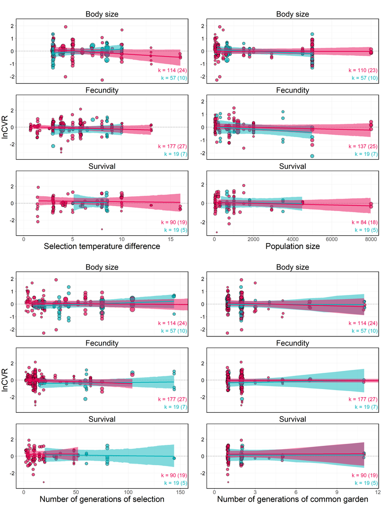

```r
############# Population size ####################

emmeans_pop_size <- as.data.frame(
  emmeans(
    lnCVR_model_pop_size,
    specs = ~ pop_size | trait_type * warm_cold,
    at = list(
      pop_size = seq(
        min(data$pop_size, na.rm = TRUE),
        max(data$pop_size, na.rm = TRUE),
        by = 50
      ),
      assay_temp_diff = 0
    )
  )
)

emmeans_pop_size <- emmeans_pop_size %>%
  dplyr::mutate(
    trait_type = factor(trait_type,
      levels = trait_levels_raw,
      labels = trait_levels_lab
    ),
    warm_cold = factor(warm_cold,
      levels = warm_levels_raw,
      labels = warm_levels_lab
    )
  )

range_df_pop_size <- data_plot %>%
  dplyr::filter(!is.na(pop_size)) %>%
  dplyr::group_by(trait_type, warm_cold) %>%
  dplyr::summarise(
    min_pop_size = min(pop_size, na.rm = TRUE),
    max_pop_size = max(pop_size, na.rm = TRUE),
    .groups = "drop"
  )

emmeans_pop_size <- emmeans_pop_size %>%
  dplyr::left_join(range_df_pop_size, by = c("trait_type", "warm_cold")) %>%
  dplyr::filter(
    pop_size >= min_pop_size,
    pop_size <= max_pop_size
  )

sample_sizes_pop_size <- data_plot %>%
  dplyr::filter(!is.na(pop_size)) %>%
  dplyr::group_by(trait_type, warm_cold) %>%
  dplyr::summarise(
    estimates = dplyr::n(),
    studies = dplyr::n_distinct(ref),
    .groups = "drop"
  )

facet_limits_pop_size <- make_facet_limits(
  data_points = data_plot %>% dplyr::filter(!is.na(pop_size)),
  data_preds = emmeans_pop_size,
  y_point = "lnCVR",
  y_lower = "lower.HPD",
  y_upper = "upper.HPD",
  buffer = 0.05,
  cap = 3.5
)

plot_data_pop_size <- clip_plot_data(
  data_points = data_plot %>% dplyr::filter(!is.na(pop_size)),
  data_preds = emmeans_pop_size,
  facet_limits = facet_limits_pop_size,
  y_point = "lnCVR",
  y_mean = "emmean",
  y_lower = "lower.HPD",
  y_upper = "upper.HPD"
)

sample_sizes_pop_size_pos <- make_sample_size_positions(
  sample_sizes_df = sample_sizes_pop_size,
  facet_limits = facet_limits_pop_size
)

pop_size <- ggplot() +
  geom_blank(data = facet_limits_pop_size, aes(x = 0, y = ymin)) +
  geom_blank(data = facet_limits_pop_size, aes(x = 0, y = ymax)) +
  geom_hline(yintercept = 0, linetype = 2, colour = "black", alpha = 0.75) +
  geom_point(
    data = plot_data_pop_size$points,
    aes(
      x = pop_size,
      y = lnCVR,
      size = 1 / sqrt(var_lnCVR),
      fill = warm_cold
    ),
    shape = 21,
    alpha = 0.7,
    stroke = 1,
    position = position_jitter(width = 0.05)
  ) +
  geom_ribbon(
    data = plot_data_pop_size$preds,
    aes(
      x = pop_size,
      ymin = y_lower_plot,
      ymax = y_upper_plot,
      fill = warm_cold,
      group = warm_cold
    ),
    alpha = 0.5
  ) +
  geom_line(
    data = plot_data_pop_size$preds,
    aes(
      x = pop_size,
      y = y_mean_plot,
      colour = warm_cold,
      group = warm_cold
    ),
    size = 1.5
  ) +
  geom_text(
    data = sample_sizes_pop_size_pos,
    aes(
      x = Inf,
      y = y,
      label = paste0("k = ", estimates, " (", studies, ")"),
      colour = warm_cold
    ),
    hjust = 1.05,
    size = 7,
    show.legend = FALSE
  ) +
  facet_wrap(~ trait_type, ncol = 1, scales = "free_y") +
  scale_fill_manual(values = c("#06B4BA", "#E80756")) +
  scale_color_manual(values = c("#06B4BA", "#E80756")) +
  labs(x = "Population size", y = "", col = "Regime") +
  theme_bw() +
  scale_size_continuous(range = c(2, 8)) +
  theme(
    text = element_text(size = 30, color = "black"),
    legend.title = ggplot2::element_text(size = 18),
    legend.text = ggplot2::element_text(size = 16),
    axis.text.y = ggplot2::element_text(size = 20, colour = "black", hjust = 0.5),
    axis.text.x = ggplot2::element_text(size = 20),
    panel.border = element_rect(color = "black", size = 1.5),
    strip.background = element_blank(),
    strip.text = element_text(color = "black", size = 28),
    plot.margin = unit(c(0, 1, 0, 0.5), "cm")
  ) +
  guides(fill = "none", size = "none", color = "none")

(sel_temp_diff | pop_size) / (gen_selection | gen_common_garden)
```

```r
ggsave(file = "fig/figure_S8.png", width = 20, height = 26, dpi = 400)
```

## **Figure S9**

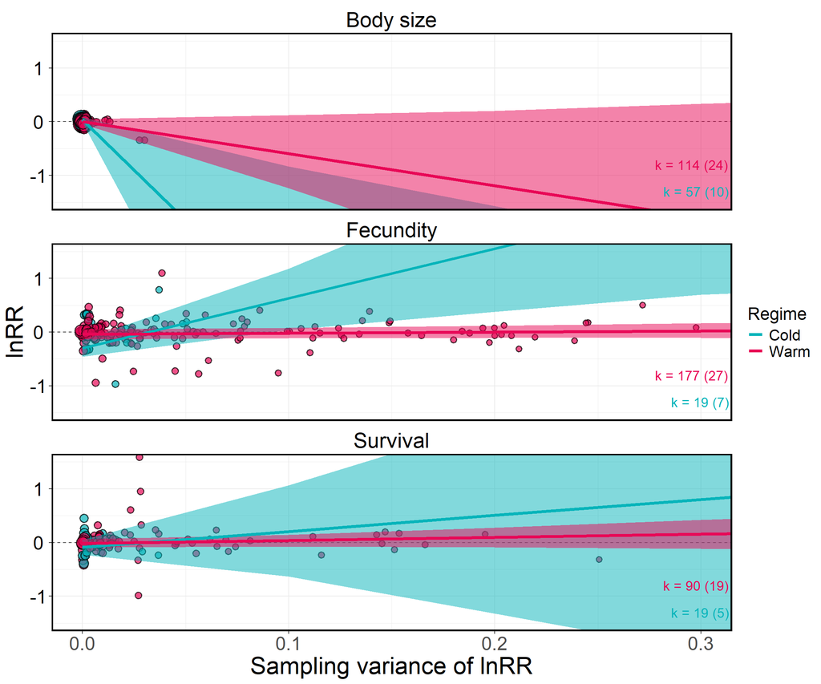

```r
# Load model
lnRR_model_pub_bias_var <- readRDS("RData/lnRR_model_pub_bias_var.rds")

# Generate predictions
emmeans_pub_bias_var <- as.data.frame(emmeans(
  lnRR_model_pub_bias_var,
  specs = ~ var_lnRR | trait_type * warm_cold,
  at = list(var_lnRR = seq(0, max(data$var_lnRR), by = 0.1),
            assay_temp_diff = 0))
  ) # Conditional effects on assay_temp_diff = 0

emmeans_pub_bias_var$trait_type <- factor(emmeans_pub_bias_var$trait_type,
                          levels = c("body_size", "fecundity", "survival"),
                          labels = c("Body size", "Fecundity", "Survival"))

emmeans_pub_bias_var$warm_cold <- factor(emmeans_pub_bias_var$warm_cold,
                          levels = c("cold", "warm"),
                          labels = c("Cold", "Warm"))

# Plot
ggplot() +
    geom_hline(yintercept = 0, # Horizontal line
               linetype = 2,
               colour = "black",
               alpha = 0.75) +
    geom_point(data = data,  # Effect sizes, scaled by precision
                  aes(x = var_lnRR,
                      y = lnRR,
                      size = 1/sqrt(var_lnRR),
                      fill = warm_cold),
                  shape = 21,
                  alpha = 0.7,
                  stroke = 1,
                  position = position_jitter(width = 0.001)) +
     geom_ribbon(data = emmeans_pub_bias_var, # Shaded area for credible intervals
                 aes(x = var_lnRR,
                     ymin = lower.HPD,
                     ymax = upper.HPD,
                     fill = warm_cold,
                     group = warm_cold),
                 alpha = .5) +
     geom_line(data = emmeans_pub_bias_var, # Predicted regression line
               aes(y = emmean,
                   x = var_lnRR,
                   color = warm_cold,
                   group = warm_cold),
               size = 1.5) +
     geom_text(data = sample_sizes,
              aes(x = Inf,
                  y = ifelse(warm_cold == "Warm", -0.8, -1.3),  # Sample sizes
                  label = paste0("k = ", estimates, " (", studies, ")"),
                  color = warm_cold),
              hjust = 1.05, size = 5, show.legend = FALSE) +
  facet_wrap(~ trait_type, ncol = 1) +  # Different panels for each trait
  scale_fill_manual(values = c("#06B4BA", "#E80756"))+
  scale_color_manual(values = c("#06B4BA", "#E80756"))+
  labs(x = "Sampling variance of lnRR", y = "lnRR", col = "Regime") +
  theme_bw() +
  scale_size_continuous(range = c(2, 8))+
  theme(text = element_text(size = 25, color = "black"),
          legend.title = ggplot2::element_text(size = 18),
          legend.text = ggplot2::element_text(size = 16),
          axis.text.y = ggplot2::element_text(size = 20,
                colour = "black", hjust = 0.5),
          axis.text.x = ggplot2::element_text(size = 20),
        panel.border = element_rect(color = "black", size = 1.5),
        strip.background = element_blank(),
        strip.text = element_text(color = "black", size = 22)) +
    guides(fill = "none", size = "none")+
    coord_cartesian(ylim = c(-1.5, 1.5), xlim = c(0, 0.3))
```

```r
ggsave(file = "fig/figure_S9.png", width = 12, height = 10, dpi = 500)
```

## **Figure S10**

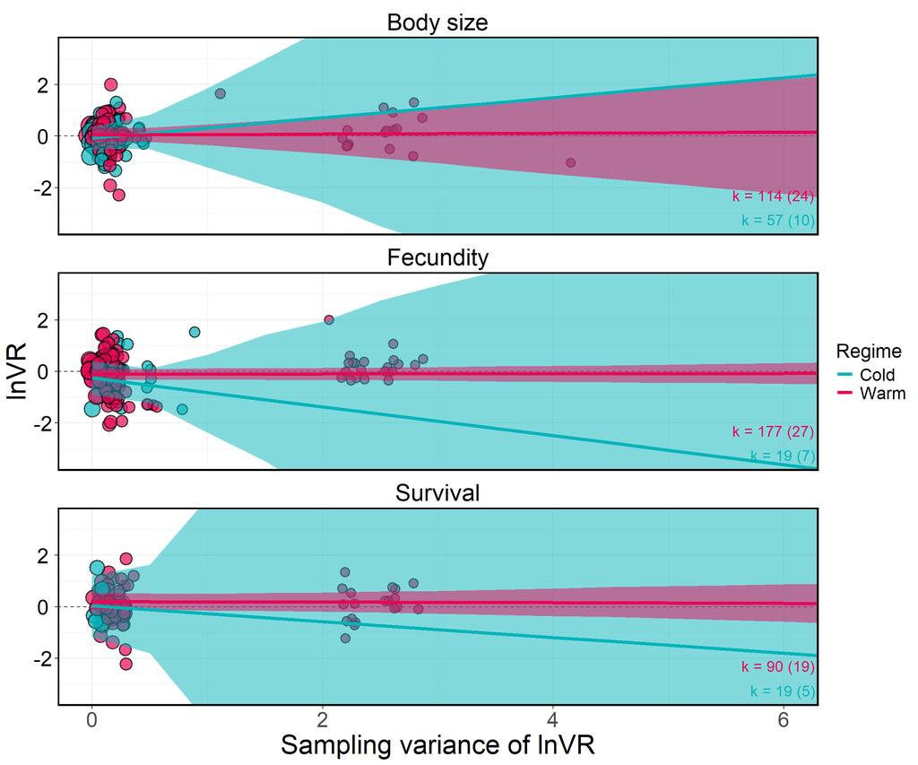

```r
# Load model
lnVR_model_pub_bias_var <- readRDS("RData/lnVR_model_pub_bias_var.rds")

# Generate predictions
emmeans_pub_bias_var <- as.data.frame(emmeans(
  lnVR_model_pub_bias_var,
  specs = ~ var_lnVR | trait_type * warm_cold,
  at = list(var_lnVR = seq(0, 10, by = 0.5),
            assay_temp_diff = 0))
  ) # Conditional effects on assay_temp_diff = 0

emmeans_pub_bias_var$trait_type <- factor(emmeans_pub_bias_var$trait_type,
                          levels = c("body_size", "fecundity", "survival"),
                          labels = c("Body size", "Fecundity", "Survival"))

emmeans_pub_bias_var$warm_cold <- factor(emmeans_pub_bias_var$warm_cold,
                          levels = c("cold", "warm"),
                          labels = c("Cold", "Warm"))

# Plot
ggplot() +
    geom_hline(yintercept = 0, # Horizontal line
               linetype = 2,
               colour = "black",
               alpha = 0.75) +
    geom_point(data = data,  # Effect sizes, scaled by precision
                  aes(x = var_lnVR,
                      y = lnVR,
                      size = 1/sqrt(var_lnVR),
                      fill = warm_cold),
                  shape = 21,
                  alpha = 0.7,
                  stroke = 1,
                  position = position_jitter(width = 0.05)) +
     geom_ribbon(data = emmeans_pub_bias_var, # Shaded area for credible intervals
                 aes(x = var_lnVR,
                     ymin = lower.HPD,
                     ymax = upper.HPD,
                     fill = warm_cold,
                     group = warm_cold),
                 alpha = .5) +
     geom_line(data = emmeans_pub_bias_var, # Predicted regression line
               aes(y = emmean,
                   x = var_lnVR,
                   color = warm_cold,
                   group = warm_cold),
               size = 1.5) +
     geom_text(data = sample_sizes,
              aes(x = Inf,
                  y = ifelse(warm_cold == "Warm", -2.3, -3.25),  # Sample sizes
                  label = paste0("k = ", estimates, " (", studies, ")"),
                  color = warm_cold),
              hjust = 1.05, size = 5, show.legend = FALSE) +
  facet_wrap(~ trait_type, ncol = 1) +  # Different panels for each trait
  scale_fill_manual(values = c("#06B4BA", "#E80756"))+
  scale_color_manual(values = c("#06B4BA", "#E80756"))+
  labs(x = "Sampling variance of lnVR", y = "lnVR", col = "Regime") +
  theme_bw() +
  scale_size_continuous(range = c(2, 8))+
  theme(text = element_text(size = 25, color = "black"),
          legend.title = ggplot2::element_text(size = 18),
          legend.text = ggplot2::element_text(size = 16),
          axis.text.y = ggplot2::element_text(size = 20,
                colour = "black", hjust = 0.5),
          axis.text.x = ggplot2::element_text(size = 20),
        panel.border = element_rect(color = "black", size = 1.5),
        strip.background = element_blank(),
        strip.text = element_text(color = "black", size = 22)) +
    guides(fill = "none", size = "none")+
    coord_cartesian(ylim = c(-3.5, 3.5), xlim = c(0, 6))
```

```r
ggsave(file = "fig/figure_S10.png", width = 12, height = 10, dpi = 500)
```

## **Figure S11**

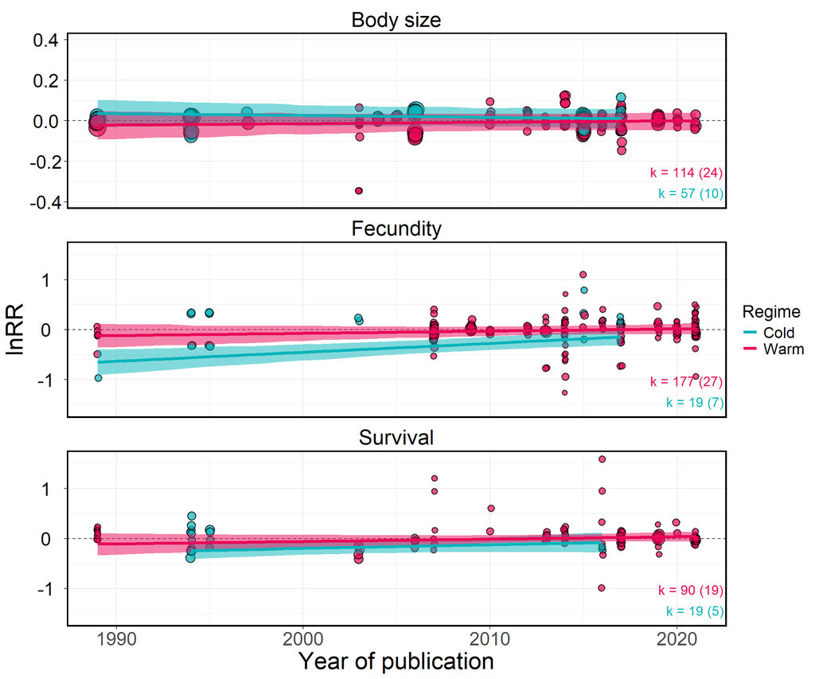

```r
# Load model
lnRR_model_pub_year <- readRDS("RData/lnRR_model_pub_bias_year.rds")

# Generate predictions
emmeans_pub_year <- as.data.frame(emmeans(
  lnRR_model_pub_year,
  specs = ~ pub_year | trait_type * warm_cold,
  at = list(pub_year = seq(min(data$pub_year), max(data$pub_year), by = 1)))
  )

# Calculate range of values for each category
range_df <- data %>%
  group_by(trait_type, warm_cold) %>%
  summarize(
    min_pub_year = min(pub_year),
    max_pub_year = max(pub_year)
  )

emmeans_pub_year$trait_type <- factor(emmeans_pub_year$trait_type,
                          levels = c("body_size", "fecundity", "survival"),
                          labels = c("Body size", "Fecundity", "Survival"))

emmeans_pub_year$warm_cold <- factor(emmeans_pub_year$warm_cold,
                          levels = c("cold", "warm"),
                          labels = c("Cold", "Warm"))

# Tailor predictions to the range of the data
emmeans_pub_year <- emmeans_pub_year %>%
  left_join(range_df, by = c("trait_type", "warm_cold")) %>%
  filter(
    pub_year >= min_pub_year,
    pub_year <= max_pub_year
  )

# Plot
facet_limits_rr <- make_facet_limits(
  data_points = data,
  data_preds = emmeans_pub_year,
  y_point = "lnRR",
  y_lower = "lower.HPD",
  y_upper = "upper.HPD",
  buffer = 0.05,
  cap = 1.6
)

plot_data_rr <- clip_plot_data(
  data_points = data,
  data_preds = emmeans_pub_year,
  facet_limits = facet_limits_rr,
  y_point = "lnRR",
  y_mean = "emmean",
  y_lower = "lower.HPD",
  y_upper = "upper.HPD"
)

sample_sizes_rr <- make_sample_size_positions(
  sample_sizes_df = sample_sizes,
  facet_limits = facet_limits_rr
)

min_pub_year <- min(data$pub_year, na.rm = TRUE)

ggplot() +
  geom_blank(data = facet_limits_rr, aes(x = min_pub_year, y = ymin)) +
  geom_blank(data = facet_limits_rr, aes(x = min_pub_year, y = ymax)) +
  geom_hline(yintercept = 0, linetype = 2, colour = "black", alpha = 0.75) +
  geom_point(
    data = plot_data_rr$points,
    aes(
      x = pub_year,
      y = lnRR,
      size = 1 / sqrt(var_lnRR),
      fill = warm_cold
    ),
    shape = 21,
    alpha = 0.7,
    stroke = 1,
    position = position_jitter(width = 0.05)
  ) +
  geom_ribbon(
    data = plot_data_rr$preds,
    aes(
      x = pub_year,
      ymin = y_lower_plot,
      ymax = y_upper_plot,
      fill = warm_cold,
      group = warm_cold
    ),
    alpha = .5
  ) +
  geom_line(
    data = plot_data_rr$preds,
    aes(
      y = y_mean_plot,
      x = pub_year,
      color = warm_cold,
      group = warm_cold
    ),
    size = 1.5
  ) +
  geom_text(
    data = sample_sizes_rr,
    aes(
      x = Inf,
      y = y,
      label = paste0("k = ", estimates, " (", studies, ")"),
      color = warm_cold
    ),
    hjust = 1.05,
    size = 5,
    show.legend = FALSE
  ) +
  facet_wrap(~ trait_type, ncol = 1, scales = "free_y") +
  scale_fill_manual(values = c("#06B4BA", "#E80756")) +
  scale_color_manual(values = c("#06B4BA", "#E80756")) +
  labs(
    x = "Year of publication",
    y = "lnRR",
    col = "Regime"
  ) +
  theme_bw() +
  scale_size_continuous(range = c(2, 8)) +
  theme(
    text = element_text(size = 25, color = "black"),
    legend.title = ggplot2::element_text(size = 18),
    legend.text = ggplot2::element_text(size = 16),
    axis.text.y = ggplot2::element_text(size = 20, colour = "black", hjust = 0.5),
    axis.text.x = ggplot2::element_text(size = 20),
    panel.border = element_rect(color = "black", size = 1.5),
    strip.background = element_blank(),
    strip.text = element_text(color = "black", size = 22)
  ) +
  guides(fill = "none",  size = "none")
```

```r
ggsave(file = "fig/figure_S11.png", width = 12, height = 10, dpi = 500)
```

## **Figure S12**

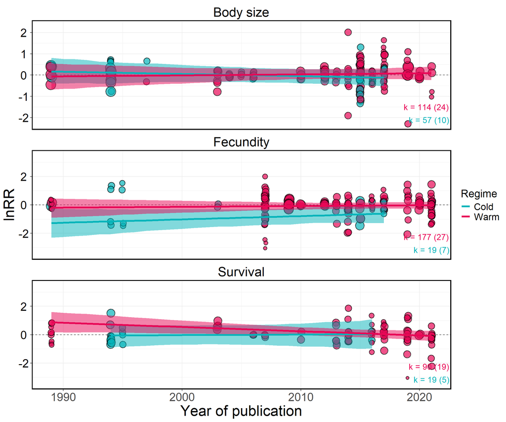

```r
# Load model
lnVR_model_pub_year <- readRDS("RData/lnVR_model_pub_bias_year.rds")

# Generate predictions
emmeans_pub_year <- as.data.frame(emmeans(
  lnVR_model_pub_year,
  specs = ~ pub_year | trait_type * warm_cold,
  at = list(pub_year = seq(min(data$pub_year), max(data$pub_year), by = 1)))
  )

# Calculate range of values for each category
range_df <- data %>%
  group_by(trait_type, warm_cold) %>%
  summarize(
    min_pub_year = min(pub_year),
    max_pub_year = max(pub_year)
  )

emmeans_pub_year$trait_type <- factor(emmeans_pub_year$trait_type,
                          levels = c("body_size", "fecundity", "survival"),
                          labels = c("Body size", "Fecundity", "Survival"))

emmeans_pub_year$warm_cold <- factor(emmeans_pub_year$warm_cold,
                          levels = c("cold", "warm"),
                          labels = c("Cold", "Warm"))

# Tailor predictions to the range of the data
emmeans_pub_year <- emmeans_pub_year %>%
  left_join(range_df, by = c("trait_type", "warm_cold")) %>%
  filter(
    pub_year >= min_pub_year,
    pub_year <= max_pub_year
  )

# Plot
facet_limits_vr <- make_facet_limits(
  data_points = data,
  data_preds = emmeans_pub_year,
  y_point = "lnVR",
  y_lower = "lower.HPD",
  y_upper = "upper.HPD",
  buffer = 0.05,
  cap = 3.5
)

plot_data_vr <- clip_plot_data(
  data_points = data,
  data_preds = emmeans_pub_year,
  facet_limits = facet_limits_vr,
  y_point = "lnVR",
  y_mean = "emmean",
  y_lower = "lower.HPD",
  y_upper = "upper.HPD"
)

sample_sizes_vr <- make_sample_size_positions(
  sample_sizes_df = sample_sizes,
  facet_limits = facet_limits_vr
)

min_pub_year <- min(data$pub_year, na.rm = TRUE)

ggplot() +
  geom_blank(data = facet_limits_vr, aes(x = min_pub_year, y = ymin)) +
  geom_blank(data = facet_limits_vr, aes(x = min_pub_year, y = ymax)) +
  geom_hline(yintercept = 0, linetype = 2, colour = "black", alpha = 0.75) +
  geom_point(
    data = plot_data_vr$points,
    aes(
      x = pub_year,
      y = lnVR,
      size = 1 / sqrt(var_lnVR),
      fill = warm_cold
    ),
    shape = 21,
    alpha = 0.7,
    stroke = 1,
    position = position_jitter(width = 0.05)
  ) +
  geom_ribbon(
    data = plot_data_vr$preds,
    aes(
      x = pub_year,
      ymin = y_lower_plot,
      ymax = y_upper_plot,
      fill = warm_cold,
      group = warm_cold
    ),
    alpha = .5
  ) +
  geom_line(
    data = plot_data_vr$preds,
    aes(
      y = y_mean_plot,
      x = pub_year,
      color = warm_cold,
      group = warm_cold
    ),
    size = 1.5
  ) +
  geom_text(
    data = sample_sizes_vr,
    aes(
      x = Inf,
      y = y,
      label = paste0("k = ", estimates, " (", studies, ")"),
      color = warm_cold
    ),
    hjust = 1.05,
    size = 5,
    show.legend = FALSE
  ) +
  facet_wrap(~ trait_type, ncol = 1, scales = "free_y") +
  scale_fill_manual(values = c("#06B4BA", "#E80756")) +
  scale_color_manual(values = c("#06B4BA", "#E80756")) +
  labs(
    x = "Year of publication",
    y = "lnRR",
    col = "Regime"
  ) +
  theme_bw() +
  scale_size_continuous(range = c(2, 8)) +
  theme(
    text = element_text(size = 25, color = "black"),
    legend.title = ggplot2::element_text(size = 18),
    legend.text = ggplot2::element_text(size = 16),
    axis.text.y = ggplot2::element_text(size = 20, colour = "black", hjust = 0.5),
    axis.text.x = ggplot2::element_text(size = 20),
    panel.border = element_rect(color = "black", size = 1.5),
    strip.background = element_blank(),
    strip.text = element_text(color = "black", size = 22)
  ) +
  guides(fill = "none",  size = "none")
```

```r
ggsave(file = "fig/figure_S12.png", width = 12, height = 10, dpi = 500)
```

## **Figure S13**

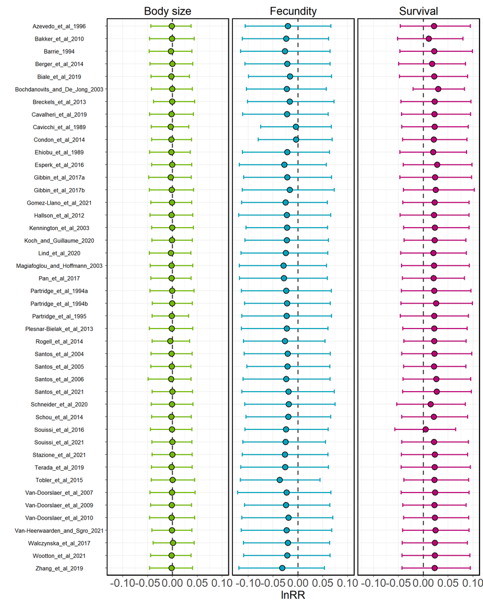

```r
# Load the list of all model outputs
loo_lnRR <- readRDS(file = "RData/lnRR_LOO_results.rds")

# Extract data on fixed effects from each model
loo_results_lnRR <- do.call(rbind, lapply(loo_lnRR, function(x) {
  # Extract study_id and fixed_effects data
  study_id <- x$study_id
  fixed_effects <- x$fixed_effects

  # Convert row names (trait_type) to a column, remove prefix, and add study_id
  fixed_effects <- data.frame(trait_type = sub("trait_type", "", rownames(fixed_effects)), fixed_effects)
  fixed_effects$study_id <- study_id

  # Remove row names
  rownames(fixed_effects) <- NULL

  return(fixed_effects)
}))

loo_results_lnRR$trait_type <- factor(loo_results_lnRR$trait_type,
                          levels = c("body_size", "fecundity", "survival"),
                          labels = c("Body size", "Fecundity", "Survival"))

loo_results_lnRR <- loo_results_lnRR %>%
  mutate(
   study_id = case_when(
      study_id == "Hallsson_et_al_2012_2" ~ "Hallson_et_al_2012",
      study_id == "Gibbin_et_al_2017_1" ~ "Gibbin_et_al_2017a",
      study_id == "Gibbin_et_al_2017_2" ~ "Gibbin_et_al_2017b",
      study_id == "Partridge_et_al_1994" ~ "Partridge_et_al_1994a",
      TRUE ~ study_id
    )
  )

# Plot
ggplot() +
    geom_hline(yintercept = 0, # Horizontal line
               linetype = 2,
               colour = "black",
               alpha = 0.75,
               lwd=1) +
    geom_errorbar(data = loo_results_lnRR,  # Plot the credible intervals in white for background
               aes(x = study_id,
                   y = Estimate,
                   ymin = Q2.5,
                   ymax = Q97.5,
                   color = trait_type),
               shape = 21,
               size = 1,
               width = 0.3) +
    geom_point(data = loo_results_lnRR,
               aes(x = study_id,
                   y = Estimate,
                   fill = trait_type),
               shape = 21,
               size = 4,
               stroke = 1,
               color="black") +
    theme_bw() +
    labs(y = "lnRR", x = "") +
    scale_fill_manual(values = c("#73B706", "#06A2BA", "#B90674"))+
    scale_color_manual(values = c("#73B706", "#06A2BA", "#B90674")) +
    theme(text = element_text(size = 20, color = "black"),
          legend.title = ggplot2::element_text(size = 16),
          legend.text = ggplot2::element_text(size = 14),
          axis.text.y = ggplot2::element_text(size = 10,
                colour = "black", hjust = 0.5),
          axis.text.x = ggplot2::element_text(size = 20),
          panel.border = element_rect(color = "black", size = 1.5),
          strip.background = element_blank(),
        strip.text = element_text(color = "black", size = 20)) +
    guides(fill = "none", color = "none")+
    coord_flip()+
    xlim(-0.15, 0.15) +
    facet_wrap(~trait_type, ncol = 3)+
   scale_x_discrete(limits = rev(levels(as.factor(loo_results_lnRR$study_id))))
```

```r
ggsave(file = "fig/figure_S13.png", width = 14, height = 12, dpi = 500)
```

## **Figure S14**

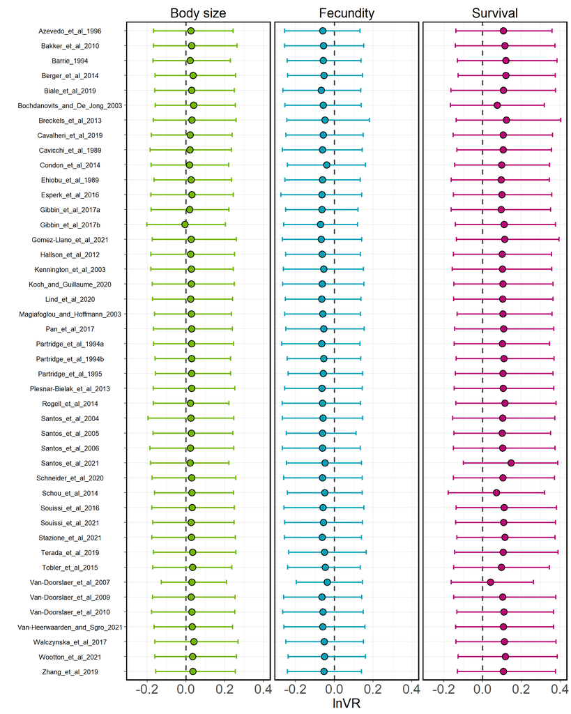

```r
# Load the list of all model outputs
loo_lnVR <- readRDS(file = "RData/lnVR_LOO_results.rds")

# Extract data on fixed effects from each model
loo_results_lnVR <- do.call(rbind, lapply(loo_lnVR, function(x) {
  # Extract study_id and fixed_effects data
  study_id <- x$study_id
  fixed_effects <- x$fixed_effects

  # Convert row names (trait_type) to a column, remove prefix, and add study_id
  fixed_effects <- data.frame(trait_type = sub("trait_type", "", rownames(fixed_effects)), fixed_effects)
  fixed_effects$study_id <- study_id

  # Remove row names
  rownames(fixed_effects) <- NULL

  return(fixed_effects)
}))

loo_results_lnVR$trait_type <- factor(loo_results_lnVR$trait_type,
                          levels = c("body_size", "fecundity", "survival"),
                          labels = c("Body size", "Fecundity", "Survival"))

loo_results_lnVR <- loo_results_lnVR %>%
  mutate(
   study_id = case_when(
      study_id == "Hallsson_et_al_2012_2" ~ "Hallson_et_al_2012",
      study_id == "Gibbin_et_al_2017_1" ~ "Gibbin_et_al_2017a",
      study_id == "Gibbin_et_al_2017_2" ~ "Gibbin_et_al_2017b",
      study_id == "Partridge_et_al_1994" ~ "Partridge_et_al_1994a",
      TRUE ~ study_id
    )
  )

# Plot
ggplot() +
    geom_hline(yintercept = 0, # Horizontal line
               linetype = 2,
               colour = "black",
               alpha = 0.75,
               lwd=1) +
    geom_errorbar(data = loo_results_lnVR,  # Plot the credible intervals in white for background
               aes(x = study_id,
                   y = Estimate,
                   ymin = Q2.5,
                   ymax = Q97.5,
                   color = trait_type),
               shape = 21,
               size = 1,
               width = 0.3) +
    geom_point(data = loo_results_lnVR,
               aes(x = study_id,
                   y = Estimate,
                   fill = trait_type),
               shape = 21,
               size = 4,
               stroke = 1,
               color="black") +
    theme_bw() +
    labs(y = "lnVR", x = "") +
    scale_fill_manual(values = c("#73B706", "#06A2BA", "#B90674"))+
    scale_color_manual(values = c("#73B706", "#06A2BA", "#B90674")) +
    theme(text = element_text(size = 20, color = "black"),
          legend.title = ggplot2::element_text(size = 16),
          legend.text = ggplot2::element_text(size = 14),
          axis.text.y = ggplot2::element_text(size = 10,
                colour = "black", hjust = 0.5),
          axis.text.x = ggplot2::element_text(size = 20),
          panel.border = element_rect(color = "black", size = 1.5),
          strip.background = element_blank(),
        strip.text = element_text(color = "black", size = 20)) +
    guides(fill = "none", color = "none")+
    coord_flip()+
    xlim(-0.5, 0.5) +
    facet_wrap(~trait_type, ncol = 3)+
   scale_x_discrete(limits = rev(levels(as.factor(loo_results_lnVR$study_id))))
```

```r
ggsave(file = "fig/figure_S14.png", width = 14, height = 12, dpi = 500)
```

## **Figure S15**

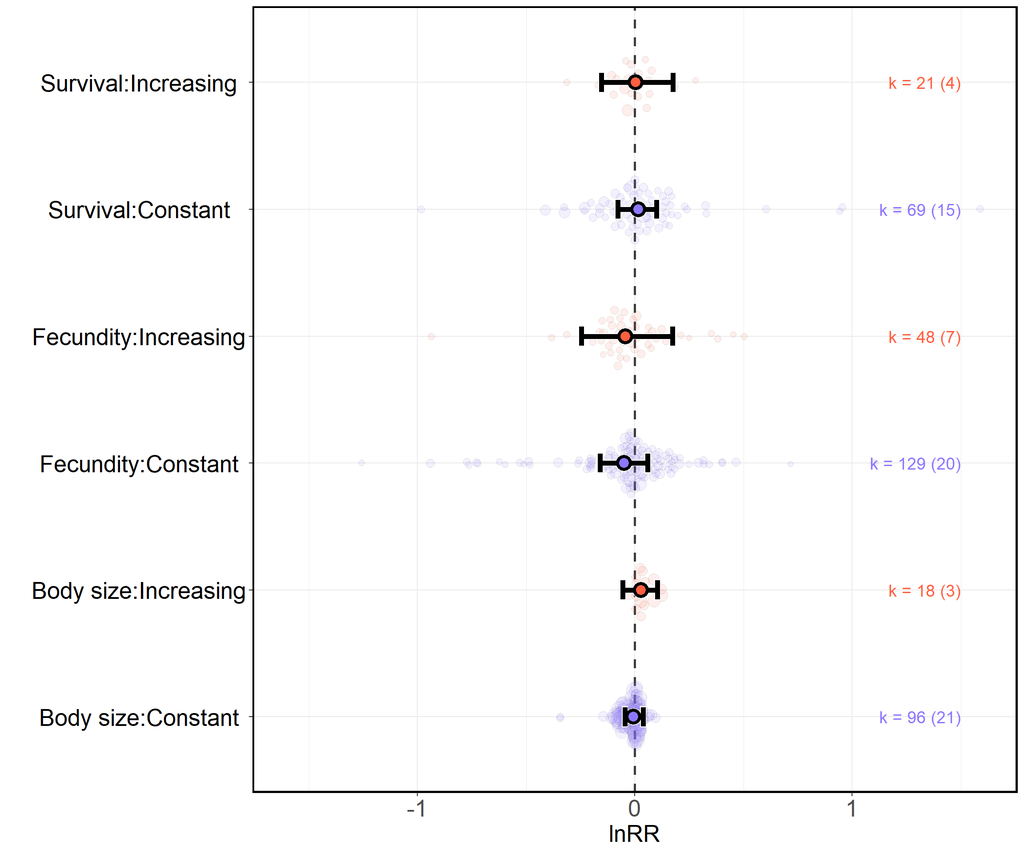

```r
# Load model
lnRR_model_constant_increasing <- readRDS("RData/lnRR_model_constant_increasing.rds")

# Generate predictions
emmeans_constant_increasing <- as.data.frame(emmeans(lnRR_model_constant_increasing,
                                                     specs = ~ constant_increasing | trait_type,
                                                     at = list(assay_temp_diff = 0)))

emmeans_constant_increasing$trait_type <- factor(emmeans_constant_increasing$trait_type,
                          levels = c("body_size", "fecundity", "survival"),
                          labels = c("Body size", "Fecundity", "Survival"))

emmeans_constant_increasing$constant_increasing <- factor(emmeans_constant_increasing$constant_increasing,
                          levels = c("constant", "increasing"),
                          labels = c("Constant", "Increasing"))

# Calculate sample sizes and study counts
sample_sizes_warm <- data_warm %>%
  group_by(trait_type, constant_increasing) %>%
  summarise(
    estimates = n(),
    studies = n_distinct(ref)
  )

# Plot
ggplot() +
    geom_hline(yintercept = 0, # Horizontal line
               linetype = 2,
               colour = "black",
               alpha = 0.75,
               lwd=1) +
    geom_quasirandom(data = data_warm,     # Plot effect sizes, scaled by precision
                     aes(x = trait_type:constant_increasing,
                         y = lnRR,
                         fill = trait_type:constant_increasing,
                         size = 1/sqrt(var_lnRR)),
                     color = "black",
                     shape = 21,
                     width = 0.25,
                     alpha = 0.1) +
    geom_errorbar(data = emmeans_constant_increasing,  # Plot the point estimates in white for background
                  aes(x = trait_type:constant_increasing,
                      ymin = lower.HPD,
                      ymax = upper.HPD),
                  color="white",
                  size = 2.5,
                  width = 0.17) +
    geom_point(data = emmeans_constant_increasing,  # Plot the credible intervals in white for background
               aes(x = trait_type:constant_increasing,
                   y = emmean),
               shape = 21,
               size = 4.5,
               stroke = 2,
               color="white",
               fill = "white") +
    geom_errorbar(data = emmeans_constant_increasing, # Plot the credible intervals
                  aes(x = trait_type:constant_increasing,
                      ymin = lower.HPD,
                      ymax = upper.HPD),
                  size = 2,
                  width = 0.15) +
    geom_point(data = emmeans_constant_increasing, # Plot the point estimates
               aes(x = trait_type:constant_increasing,
                   fill = trait_type:constant_increasing,
                   y = emmean),
               shape = 21,
               size = 4,
               stroke = 2,
               color="black") +
    geom_text(data = sample_sizes_warm,  # Sample size annotations
              aes(x = trait_type:constant_increasing,
                  y = 1.5,
                  label = paste0("k = ", estimates, " (", studies, ")"),
                  color = constant_increasing),
              hjust = 1, size = 5, show.legend = FALSE) +
    theme_bw() +     # Customize the plot
    labs(y = "lnRR", x = "") +
    scale_size_continuous(range = c(2, 8))+
    scale_fill_manual(values = c("#8E77FF", "#FF6040", "#8E77FF", "#FF6040", "#8E77FF", "#FF6040"))+
    scale_color_manual(values = c("Constant" = "#8E77FF", "Increasing" = "#FF6040")) +  # Text colour
    theme(text = element_text(size = 20, color = "black"),
          legend.title = ggplot2::element_text(size = 16),
          legend.text = ggplot2::element_text(size = 14),
          axis.text.y = ggplot2::element_text(size = 20,
                colour = "black", hjust = 0.5),
          axis.text.x = ggplot2::element_text(size = 20),
          panel.border = element_rect(color = "black", size = 1.5)) +
    guides(fill = "none", size = "none")+
    coord_flip() +
    ylim(-1.6, 1.6)
```

```r
ggsave(file = "fig/figure_S15.png", width = 12, height = 7, dpi = 500)
```

## **Figure S16**

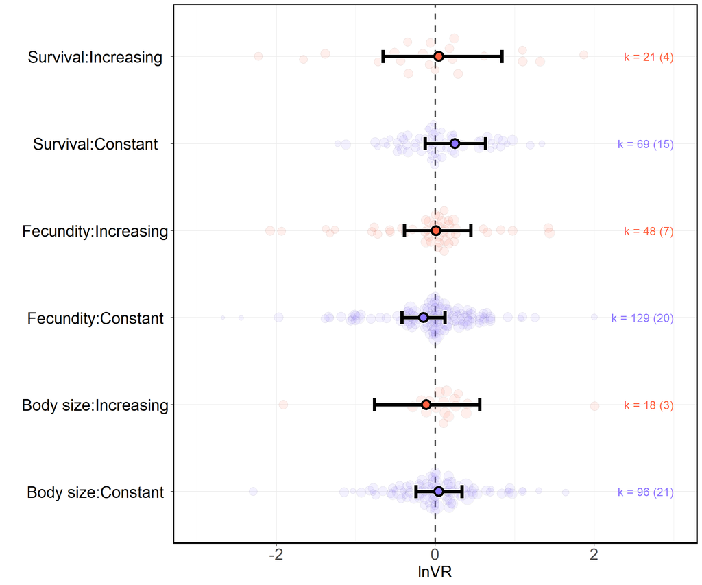

```r
# Load model
lnVR_model_constant_increasing <- readRDS("RData/lnVR_model_constant_increasing.rds")

# Generate predictions
emmeans_constant_increasing <- as.data.frame(emmeans(lnVR_model_constant_increasing,
                                                     specs = ~ constant_increasing | trait_type,
                                                     at = list(assay_temp_diff = 0)))

emmeans_constant_increasing$trait_type <- factor(emmeans_constant_increasing$trait_type,
                          levels = c("body_size", "fecundity", "survival"),
                          labels = c("Body size", "Fecundity", "Survival"))

emmeans_constant_increasing$constant_increasing <- factor(emmeans_constant_increasing$constant_increasing,
                          levels = c("constant", "increasing"),
                          labels = c("Constant", "Increasing"))

# Calculate sample sizes and study counts
sample_sizes_warm <- data_warm %>%
  group_by(trait_type, constant_increasing) %>%
  summarise(
    estimates = n(),
    studies = n_distinct(ref)
  )

# Plot
ggplot() +
    geom_hline(yintercept = 0, # Horizontal line
               linetype = 2,
               colour = "black",
               alpha = 0.75,
               lwd=1) +
    geom_quasirandom(data = data_warm,     # Plot effect sizes, scaled by precision
                     aes(x = trait_type:constant_increasing,
                         y = lnVR,
                         fill = trait_type:constant_increasing,
                         size = 1/sqrt(var_lnVR)),
                     color = "black",
                     shape = 21,
                     width = 0.25,
                     alpha = 0.1) +
    geom_errorbar(data = emmeans_constant_increasing,  # Plot the point estimates in white for background
                  aes(x = trait_type:constant_increasing,
                      ymin = lower.HPD,
                      ymax = upper.HPD),
                  color="white",
                  size = 2.5,
                  width = 0.17) +
    geom_point(data = emmeans_constant_increasing,  # Plot the credible intervals in white for background
               aes(x = trait_type:constant_increasing,
                   y = emmean),
               shape = 21,
               size = 4.5,
               stroke = 2,
               color="white",
               fill = "white") +
    geom_errorbar(data = emmeans_constant_increasing, # Plot the credible intervals
                  aes(x = trait_type:constant_increasing,
                      ymin = lower.HPD,
                      ymax = upper.HPD),
                  size = 2,
                  width = 0.15) +
    geom_point(data = emmeans_constant_increasing, # Plot the point estimates
               aes(x = trait_type:constant_increasing,
                   fill = trait_type:constant_increasing,
                   y = emmean),
               shape = 21,
               size = 4,
               stroke = 2,
               color="black") +
    geom_text(data = sample_sizes_warm,  # Sample size annotations
              aes(x = trait_type:constant_increasing,
                  y = 3,
                  label = paste0("k = ", estimates, " (", studies, ")"),
                  color = constant_increasing),
              hjust = 1, size = 5, show.legend = FALSE) +
    theme_bw() +     # Customize the plot
    labs(y = "lnVR", x = "") +
    scale_size_continuous(range = c(2, 8))+
    scale_fill_manual(values = c("#8E77FF", "#FF6040", "#8E77FF", "#FF6040", "#8E77FF", "#FF6040"))+
    scale_color_manual(values = c("Constant" = "#8E77FF", "Increasing" = "#FF6040")) +  # Text colour
    theme(text = element_text(size = 20, color = "black"),
          legend.title = ggplot2::element_text(size = 16),
          legend.text = ggplot2::element_text(size = 14),
          axis.text.y = ggplot2::element_text(size = 20,
                colour = "black", hjust = 0.5),
          axis.text.x = ggplot2::element_text(size = 20),
          panel.border = element_rect(color = "black", size = 1.5)) +
    guides(fill = "none", size = "none")+
    coord_flip() +
    ylim(-3, 3)
```

```r
ggsave(file = "fig/figure_S16.png", width = 12, height = 7, dpi = 500)
```

## **Figure S17**

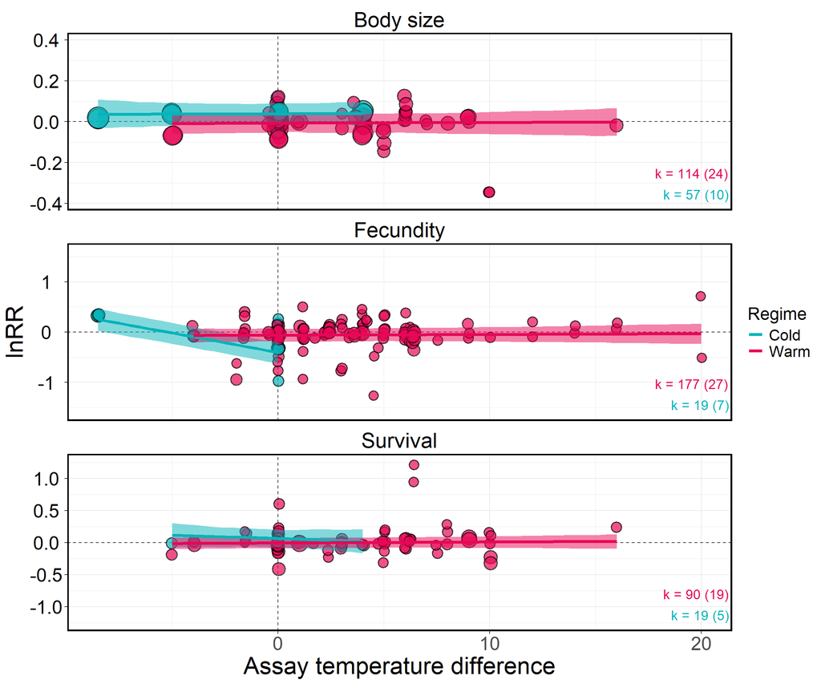

```r
# Load model
lnRR_model_concerns <- readRDS("RData/lnRR_model_concerns.rds")

# Generate predictions
emmeans_concerns <- as.data.frame(emmeans(
  lnRR_model_concerns,
  specs = ~ assay_temp_diff | trait_type * warm_cold,
  at = list(assay_temp_diff = seq(min(data_concerns$assay_temp_diff), max(data_concerns$assay_temp_diff), by = 0.5)))
  )

# Calculate range of values for each category
range_df <- data_concerns %>%
  group_by(trait_type, warm_cold) %>%
  summarize(
    min_assay_temp_diff = min(assay_temp_diff, na.rm = TRUE),
    max_assay_temp_diff = max(assay_temp_diff, na.rm = TRUE),
    .groups = "drop"
  )

# Match emmeans coding to whatever is already in data
emmeans_concerns$trait_type <- factor(
  emmeans_concerns$trait_type,
  levels = c("body_size", "fecundity", "survival"),
  labels = c("Body size", "Fecundity", "Survival")
)

emmeans_concerns$warm_cold <- factor(
  emmeans_concerns$warm_cold,
  levels = c("cold", "warm"),
  labels = c("Cold", "Warm")
)

# Tailor predictions to the range of the data
emmeans_concerns <- emmeans_concerns %>%
  left_join(range_df, by = c("trait_type", "warm_cold")) %>%
  filter(
    assay_temp_diff >= min_assay_temp_diff,
    assay_temp_diff <= max_assay_temp_diff
  )

# Plot objects using helper functions
facet_limits_rr <- make_facet_limits(
  data_points = data_concerns,
  data_preds = emmeans_concerns,
  y_point = "lnRR",
  y_lower = "lower.HPD",
  y_upper = "upper.HPD",
  buffer = 0.05,
  cap = 1.6
)

plot_data_rr <- clip_plot_data(
  data_points = data_concerns,
  data_preds = emmeans_concerns,
  facet_limits = facet_limits_rr,
  y_point = "lnRR",
  y_mean = "emmean",
  y_lower = "lower.HPD",
  y_upper = "upper.HPD"
)

sample_sizes_rr <- make_sample_size_positions(
  sample_sizes_df = sample_sizes,
  facet_limits = facet_limits_rr
)

ggplot() +
  geom_blank(data = facet_limits_rr, aes(x = 0, y = ymin)) +
  geom_blank(data = facet_limits_rr, aes(x = 0, y = ymax)) +
  geom_hline(yintercept = 0, linetype = 2, colour = "black", alpha = 0.75) +
  geom_vline(xintercept = 0, linetype = 2, colour = "black", alpha = 0.75) +
  geom_point(
    data = plot_data_rr$points,
    aes(
      x = assay_temp_diff,
      y = lnRR,
      size = 1 / sqrt(var_lnRR),
      fill = warm_cold
    ),
    shape = 21,
    alpha = 0.7,
    stroke = 1,
    position = position_jitter(width = 0.05)
  ) +
  geom_ribbon(
    data = plot_data_rr$preds,
    aes(
      x = assay_temp_diff,
      ymin = y_lower_plot,
      ymax = y_upper_plot,
      fill = warm_cold,
      group = warm_cold
    ),
    alpha = .5
  ) +
  geom_line(
    data = plot_data_rr$preds,
    aes(
      y = y_mean_plot,
      x = assay_temp_diff,
      color = warm_cold,
      group = warm_cold
    ),
    size = 1.5
  ) +
  geom_text(
    data = sample_sizes_rr,
    aes(
      x = Inf,
      y = y,
      label = paste0("k = ", estimates, " (", studies, ")"),
      color = warm_cold
    ),
    hjust = 1.05,
    size = 5,
    show.legend = FALSE
  ) +
  facet_wrap(~ trait_type, ncol = 1, scales = "free_y") +
  scale_fill_manual(values = c("#06B4BA", "#E80756")) +
  scale_color_manual(values = c("#06B4BA", "#E80756")) +
  labs(
    x = "Assay temperature difference",
    y = "lnRR",
    col = "Regime"
  ) +
  theme_bw() +
  scale_size_continuous(range = c(4, 10)) +
  theme(
    text = element_text(size = 25, color = "black"),
    legend.title = ggplot2::element_text(size = 18),
    legend.text = ggplot2::element_text(size = 16),
    axis.text.y = ggplot2::element_text(size = 20, colour = "black", hjust = 0.5),
    axis.text.x = ggplot2::element_text(size = 20),
    panel.border = element_rect(color = "black", size = 1.5),
    strip.background = element_blank(),
    strip.text = element_text(color = "black", size = 22)
  ) +
  guides(fill = "none",  size = "none")
```

```r
ggsave(file = "fig/figure_S17.png", width = 12, height = 10, dpi = 500)
```

## **Figure S18**

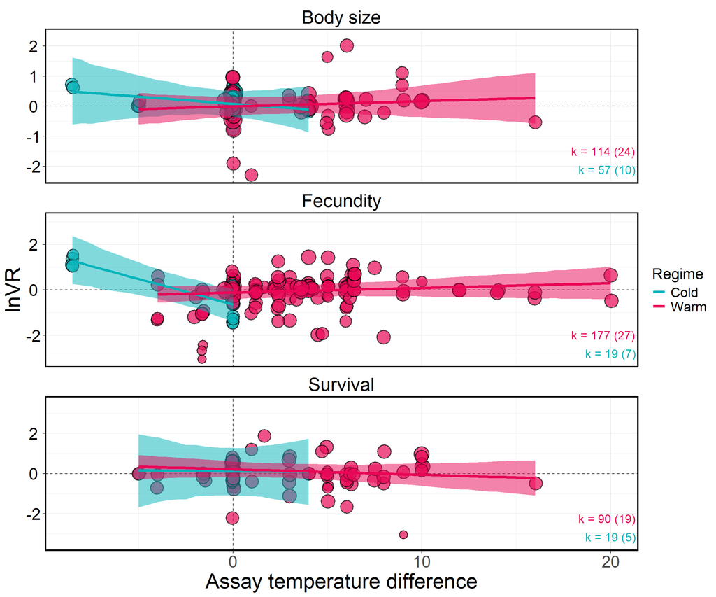

```r
# Load model
lnVR_model_concerns <- readRDS("RData/lnVR_model_concerns.rds")

# Generate predictions
emmeans_concerns <- as.data.frame(emmeans(
  lnVR_model_concerns,
  specs = ~ assay_temp_diff | trait_type * warm_cold,
  at = list(assay_temp_diff = seq(min(data_concerns$assay_temp_diff), max(data_concerns$assay_temp_diff), by = 0.5)))
  )

# Calculate range of values for each category
range_df <- data_concerns %>%
  group_by(trait_type, warm_cold) %>%
  summarize(
    min_assay_temp_diff = min(assay_temp_diff, na.rm = TRUE),
    max_assay_temp_diff = max(assay_temp_diff, na.rm = TRUE),
    .groups = "drop"
  )

# Match emmeans coding to whatever is already in data
emmeans_concerns$trait_type <- factor(
  emmeans_concerns$trait_type,
  levels = c("body_size", "fecundity", "survival"),
  labels = c("Body size", "Fecundity", "Survival")
)

emmeans_concerns$warm_cold <- factor(
  emmeans_concerns$warm_cold,
  levels = c("cold", "warm"),
  labels = c("Cold", "Warm")
)

# Tailor predictions to the range of the data
emmeans_concerns <- emmeans_concerns %>%
  left_join(range_df, by = c("trait_type", "warm_cold")) %>%
  filter(
    assay_temp_diff >= min_assay_temp_diff,
    assay_temp_diff <= max_assay_temp_diff
  )

# Plot objects using helper functions
facet_limits_vr <- make_facet_limits(
  data_points = data_concerns,
  data_preds = emmeans_concerns,
  y_point = "lnVR",
  y_lower = "lower.HPD",
  y_upper = "upper.HPD",
  buffer = 0.05,
  cap = 3.5
)

plot_data_vr <- clip_plot_data(
  data_points = data_concerns,
  data_preds = emmeans_concerns,
  facet_limits = facet_limits_vr,
  y_point = "lnVR",
  y_mean = "emmean",
  y_lower = "lower.HPD",
  y_upper = "upper.HPD"
)

sample_sizes_vr <- make_sample_size_positions(
  sample_sizes_df = sample_sizes,
  facet_limits = facet_limits_vr
)

ggplot() +
  geom_blank(data = facet_limits_vr, aes(x = 0, y = ymin)) +
  geom_blank(data = facet_limits_vr, aes(x = 0, y = ymax)) +
  geom_hline(yintercept = 0, linetype = 2, colour = "black", alpha = 0.75) +
  geom_vline(xintercept = 0, linetype = 2, colour = "black", alpha = 0.75) +
  geom_point(
    data = plot_data_vr$points,
    aes(
      x = assay_temp_diff,
      y = lnVR,
      size = 1 / sqrt(var_lnVR),
      fill = warm_cold
    ),
    shape = 21,
    alpha = 0.7,
    stroke = 1,
    position = position_jitter(width = 0.05)
  ) +
  geom_ribbon(
    data = plot_data_vr$preds,
    aes(
      x = assay_temp_diff,
      ymin = y_lower_plot,
      ymax = y_upper_plot,
      fill = warm_cold,
      group = warm_cold
    ),
    alpha = .5
  ) +
  geom_line(
    data = plot_data_vr$preds,
    aes(
      y = y_mean_plot,
      x = assay_temp_diff,
      color = warm_cold,
      group = warm_cold
    ),
    size = 1.5
  ) +
  geom_text(
    data = sample_sizes_vr,
    aes(
      x = Inf,
      y = y,
      label = paste0("k = ", estimates, " (", studies, ")"),
      color = warm_cold
    ),
    hjust = 1.05,
    size = 5,
    show.legend = FALSE
  ) +
  facet_wrap(~ trait_type, ncol = 1, scales = "free_y") +
  scale_fill_manual(values = c("#06B4BA", "#E80756")) +
  scale_color_manual(values = c("#06B4BA", "#E80756")) +
  labs(
    x = "Assay temperature difference",
    y = "lnVR",
    col = "Regime"
  ) +
  theme_bw() +
  scale_size_continuous(range = c(4, 10)) +
  theme(
    text = element_text(size = 25, color = "black"),
    legend.title = ggplot2::element_text(size = 18),
    legend.text = ggplot2::element_text(size = 16),
    axis.text.y = ggplot2::element_text(size = 20, colour = "black", hjust = 0.5),
    axis.text.x = ggplot2::element_text(size = 20),
    panel.border = element_rect(color = "black", size = 1.5),
    strip.background = element_blank(),
    strip.text = element_text(color = "black", size = 22)
  ) +
  guides(fill = "none",  size = "none")
```

```r
ggsave(file = "fig/figure_S18.png", width = 12, height = 10, dpi = 500)
```